# Ideas that Created the Future_Classic Papers of Computer Science.Lewis2021 — 中英对照

### **4.2.14** 然而，本体系与通常所述的代数体系之间的类比，似乎到这里便止步了。假定类 *x* 中具有某种性质 *z* 的成员，与类 *y* 中具有同一性质 *z* 的成员完全相同，并不能由此推出类 *x* 的全体成员与类 *y* 的成员完全相同。因此，不能由方程 *zx* = *zy,* 推出方程 *x* = *y* 也成立。换言之，代数学家所用的“方程两边可以除以同一个量”这条公理，在这里没有形式上的对应物。我说没有*形式上的对应物*，是因为依照这些研究的总体精神，我们甚至不打算判定：从组合 *zx* 中去掉逻辑符号 *z* 所表示的心理操作，其本身是否类似于算术中的除法。这种心理操作确实就是通常所谓的抽象，后面将会看到，它的规律依赖于本章已经推导出的规律。现在所说明的是：在这些规律中，不存在任何在形式上类似于代数中一条公认公理的东西。**4.2.14** Here, however, the analogy of the present system with that of algebra, as commonly stated, appears to stop. Suppose it true that those members of a class *x* which possess a certain property *z* are identical with those members of a class *y* which possess the same property *z*, it does not follow that the members of the class *x* universally are identical with the members of the class *y*. Hence it cannot be inferred from the equation *zx* = *zy,* that the equation *x* = *y* is also true. In other words, the axiom of algebraists, that both sides of an equation may be divided by the same quantity, has no formal equivalent here. I say no *formal equivalent*, because, in accordance with the general spirit of these inquiries, it is not even sought to determine whether the mental operation which is represented by removing a logical symbol, *z*, from a combination *zx*, is in itself analogous with the operation of division in Arithmetic. That mental operation is indeed identical with what is commonly termed Abstraction, and it will hereafter appear that its laws are dependent upon the laws already deduced in this chapter. What has now been shown is, that there does not exist among those laws anything analogous in form with a commonly received axiom of Algebra.

但稍微考虑一下就会发现，即使在普通代数中，该公理也不具备已考虑的其他公理的一般性。从方程*zx* = *zy*推导出方程*x* = *y*仅当已知*z*不等于 0 时才有效。如果此时值*z* = 0 在代数系统中被认为是可接受的，则上述公理不再适用，并且之前举例的类比至少仍然没有被打破。But a little consideration will show that even in common algebra that axiom does not possess the generality of those other axioms which have been considered. The deduction of the equation *x* = *y* from the equation *zx* = *zy* is only valid when it is known that *z* is not equal to 0. If then the value *z* = 0 is supposed to be admissible in the algebraic system, the axiom above stated ceases to be applicable, and the analogy before exemplified remains at least unbroken.

### **4.2.15** 然而，除了作为推测之外，追踪这种相似性对于一般的数量符号来说并不具有任何重要性。我们已经看到（第4.2.9节）逻辑符号受特殊定律*x*<sup>2</sup> = *x 的约束。*现在数字的符号只有两个，即。0和1，它们遵循相同的形式法则。我们知道 0 <sup>2</sup> = 0，1 2 <sup>2</sup> 1；方程*x*<sup>2</sup> = *x*被视为代数，除了 0 和 1 之外没有其他根。因此，我们不应该确定逻辑符号与一般数字符号的形式一致性程度，而是更直接地建议我们将它们与*仅允许值*0*和*1 的数量符号进行比较。那么，让我们设想一个代数，其中符号*x*、*y*、*z*等无关紧要地允许值 0 和 1 ，并且仅允许这些值。这种代数的定律、公理和过程在整个范围内与逻辑代数的定律、公理和过程是相同的。仅解释的不同就会将它们分开。根据这个原则，建立了以下工作方法。**4.2.15** However, it is not with the symbols of quantity generally that it is of any importance, except as a matter of speculation, to trace such affinities. We have seen (§4.2.9) that the symbols of Logic are subject to the special law, *x*<sup>2</sup> = *x.* Now of the symbols of Number there are but two, viz. 0 and 1, which are subject to the same formal law. We know that 0<sup>2</sup> = 0, and that 1<sup>2</sup> = 1; and the equation *x*<sup>2</sup> = *x*, considered as algebraic, has no other roots than 0 and 1. Hence, instead of determining the measure of formal agreement of the symbols of Logic with those of Number generally, it is more immediately suggested to us to compare them with symbols of quantity *admitting only of the values* 0 *and* 1. Let us conceive, then, of an Algebra in which the symbols *x*, *y*, *z*, etc. admit indifferently of the values 0 and 1, and of these values alone. The laws, the axioms, and the processes, of such an Algebra will be identical in their whole extent with the laws, the axioms, and the processes of an Algebra of Logic. Difference of interpretation will alone divide them. Upon this principle the method of the following work is established.

### **4.2.16** 现在需要表明的是，本章前面几节中没有考虑到的那些普通语言的组成部分，要么可以分解为与已经考虑过的相同的元素，要么通过有助于它们的更精确而成为这些元素的附属部分。定义。**4.2.16** It now remains to show that those constituent parts of ordinary language which have not been considered in the previous sections of this chapter are either resolvable into the same elements as those which have been considered, or are subsidiary to those elements by contributing to their more precise definition.

实词、形容词、动词，以及助词*和*，*except*，我们已经考虑过。代词可以被视为实词或形容词的特定形式。副词修饰动词的含义，但不影响其性质。介词有助于表达环境或关系，因此往往会赋予字面符号的含义精确和细节。连词*if*、*或者*、*或*, 主要用于表达命题之间的关系，下文将证明，相同的关系可以完全用基本符号来表达，这些基本符号在解释上是类似的，并且在形式和规律上与本章已解释其用途和含义。至于任何剩余的言语元素，经过检查，我们会发现它们要么被用来赋予话语术语更明确的意义，从而进入对已经考虑过的文字符号的解释，要么被用来表达某种意义。伴随着一个命题的表达的情感或感觉状态，因此不属于我们目前所关心的理解的范围。其使用经验将证明所采用的分类的充分性。The substantive, the adjective, and the verb, together with the particles *and*, *except*, we have already considered. The pronoun may be regarded as a particular form of the substantive or the adjective. The adverb modifies the meaning of the verb, but does not affect its nature. Prepositions contribute to the expression of circumstance or relation, and thus tend to give precision and detail to the meaning of the literal symbols. The conjunctions *if*, *either*, *or*, are used chiefly in the expression of relation among propositions, and it will hereafter be shown that the same relations can be completely expressed by elementary symbols analogous in interpretation, and identical in form and law with the symbols whose use and meaning have been explained in this chapter. As to any remaining elements of speech, it will, upon examination, be found that they are used either to give a more definite significance to the terms of discourse, and thus enter into the interpretation of the literal symbols already considered, or to express some emotion or state of feeling accompanying the utterance of a proposition, and thus do not belong to the province of the understanding, with which alone our present concern lies. Experience of its use will testify to the sufficiency of the classification which has been adopted.

## **4.3 从人类思维运作规律推导出逻辑符号规律……****4.3 Derivation of the Laws of the Symbols of Logic from the Laws of the Operations of the Human Mind …**

### **4.3.12** 本章的其余部分将讨论与思想法则相关的问题，其表达式为*x*<sup>2</sup> = *x*（第4.2.9节），正如已经暗示的那样（第4.2.15节），该法则形成了以下特征的特征区别：与处理一般数量代数时的思维活动相比，在日常话语和推理中的思维活动。以下探究的一个重要部分将在于证明符号 0 和 1 在逻辑符号中占据一席之地，并且易于解释；首先可能有必要表明特定的符号，例如上面的符号，可以如何适当和有利地用于表示不同的思想体系。**4.3.12** The remainder of this chapter will be occupied with questions relating to that law of thought whose expression is *x*<sup>2</sup> = *x* (§4.2.9), a law which, as has been implied (§4.2.15), forms the characteristic distinction of the operations of the mind in its ordinary discourse and reasoning, as compared with its operations when occupied with the general algebra of quantity. An important part of the following inquiry will consist in proving that the symbols 0 and 1 occupy a place, and are susceptible of an interpretation, among the symbols of Logic; and it may first be necessary to show how particular symbols, such as the above, may with propriety and advantage be employed in the representation of distinct systems of thought.

这种适当性的基础不能存在于任何解释共同体中。因为在像逻辑和算术这样真正不同的思想体系中（我使用后一个术语作为数字科学的最广泛含义），正确地说，不存在主体共同体。他们中的一个熟悉事物的概念，另一个只考虑它们的数字关系。但是，由于任何推理系统的形式和方法都直接取决于符号所遵循的法则，并且仅通过上述联系间接地取决于它们的解释，因此使用相同的符号可能既合适又有利。不同思想体系中的符号，只要可以对它们进行解释，使它们的形式法则相同，并且使用一致。那么，这种雇佣的基础将不再是解释的共同体，而是正式法律的共同体，它们在各自的体系中受到约束。除了仔细观察和比较那些被视为独立于所考虑的系统的解释之外的结果之外，也不能建立在任何其他基础上的正式法律共同体。The ground of this propriety cannot consist in any community of interpretation. For in systems of thought so truly distinct as those of Logic and Arithmetic (I use the latter term in its widest sense as the science of Number), there is, properly speaking, no community of subject. The one of them is conversant with the very conceptions of things, the other takes account solely of their numerical relations. But inasmuch as the forms and methods of any system of reasoning depend immediately upon the laws to which the symbols are subject, and only mediately, through the above link of connexion, upon their interpretation, there may be both propriety and advantage in employing the same symbols in different systems of thought, provided that such interpretations can be assigned to them as shall render their formal laws identical, and their use consistent. The ground of that employment will not then be community of interpretation, but the community of the formal laws, to which in their respective systems they are subject. Nor must that community of formal laws be established upon any other ground than that of a careful observation and comparison of those results which are seen to flow independently from the interpretations of the systems under consideration.

这些考察说明了下一命题所采用的探究过程。逻辑的字母符号普遍服从表达为 *x*<sup>2</sup> = *x* 的法则。在数的符号中，只有 0 和 1 这两个符号满足这一法则。但在数值大小的体系中，这两个符号又各自服从其特有的法则，于是便引出了这样一个问题：应当赋予逻辑的字母符号什么解释，才能使同样的特殊形式法则也在逻辑体系中成立？These observations will explain the process of inquiry adopted in the following Proposition. The literal symbols of Logic are universally subject to the law whose expression is *x*<sup>2</sup> = *x*. Of the symbols of Number there are two only, 0 and 1, which satisfy this law. But each of these symbols is also subject to a law peculiar to itself in the system of numerical magnitude, and this suggests the inquiry, what interpretations must be given to the literal symbols of Logic, in order that the same peculiar and formal laws may be realized in the logical system also.

### **4.3.14** 正如将任何类别的物体视为“人”的概念一样，人们的脑海中也会联想到非人的相反类别的存在物的概念。由于整个宇宙是由这两个类别共同组成的，因为对于它所包含的每个个体，我们都可以断言它是一个人，或者它不是一个人，所以询问这些相反的名称如何与人相联系就变得很重要。予以表达。这就是以下命题的目的。**4.3.14** As with the idea of any class of objects as “men,” there is suggested to the mind the idea of the contrary class of beings which are not men; and as the whole Universe is made up of these two classes together, since of every individual which it comprehends we may affirm either that it is a man, or that it is not a man, it becomes important to inquire how such contrary names are to be expressed. Such is the object of the following Proposition.

*如果 x 代表任何类别的对象，则*1 − *x 代表相反或补充的对象类别，即包括类 x 中未包含的所有对象的类别*。*If x represent any class of objects, then will* 1 − *x represent the contrary or supplementary class of objects., i.e. the class including all objects which are not comprehended in the class x*.

为了使概念更加明确，令 *x* 代表人这一类，并依照上一个命题，用 1 表示全集；现在，如果从由“人”与“非人”构成的全集概念中排除“人”的概念，所得的概念就是相反的类——“非人”。因此，“非人”这一类将由 1 −*x* 表示。一般说来，无论符号 *x* 代表什么对象的类，其相反的类都由 1 − *x* 表示。For greater distinctness of conception let *x* represent the class men, and let us express, according to the last Proposition, the Universe by 1; now if from the conception of the Universe, as consisting of “men” and “not-men,” we exclude the conception of “men,” the resulting conception is that of the contrary class, “not-men.” Hence the class “not-men” will be represented by 1 −*x*. And, in general, whatever class of objects is represented by the symbol *x*, the contrary class will be expressed by 1 − *x*.

### **4.3.15** 尽管下面的命题严格地属于本书的未来章节，专门讨论*格言*或*必然真理*的主题，但是，由于它所涉及的思想法则的重要性，人们认为引入在这里。**4.3.15** Although the following Proposition belongs in strictness to a future chapter of this work, devoted to the subject of *maxims* or *necessary truths*, yet, on account of the great importance of that law of thought to which it relates, it has been thought proper to introduce it here.

*形而上学家的公理被称为矛盾原理，它断言任何存在物都不可能既拥有某种品质，又同时不拥有这种品质，它是基本思想法则的结果，其表达是x* <sup>2</sup> = *x*。*That axiom of metaphysicians which is termed the principle of contradiction, and which affirms that it is impossible for any being to possess a quality, and at the same time not to possess it, is a consequence of the fundamental law of thought, whose expression is x*<sup>2</sup> = *x*.

引入上述解释并不是因为它在现行体系中的直接价值，而是为了说明智力哲学中的一个重要事实，即通常被认为是形而上学的基本公理的是而是数学形式的思想法则的结果。我还希望注意这样的情况，即表达基本思想定律的方程（4.7）是二次方程。……The above interpretation has been introduced not on account of its immediate value in the present system, but as an illustration of a significant fact in the philosophy of the intellectual powers, viz., that what has been commonly regarded as the fundamental axiom of metaphysics is but the consequence of a law of thought, mathematical in its form. I desire to direct attention also to the circumstance that the equation (4.7) thus in which that fundamental law of thought is expressed is an equation of the second degree. …

## **4.4 命题分为“初级”和“次级”两类、这些类的特征以及初级命题的表达规律****4.4 Of the Division of Propositions into the Two Classes of “Primary” and “Secondary,” of the Characteristic Properties of Those Classes, and of the Laws of the Expression of Primary Propositions**

### **4.4.1** 研究了与概念或想象过程有关的那些心理活动的规律，并解释了代表它们的符号的相应规律，我们被引导考虑所获得的结果的实际应用：首先，在命题的复杂术语的表达；其次，在命题的表达上；最后，构建演绎分析的一般方法。在本章中，我们将主要关注这些对象中的第一个，作为介绍，有必要建立以下命题：**4.4.1** The laws of those mental operations which are concerned in the processes of Conception or Imagination having been investigated, and the corresponding laws of the symbols by which they are represented explained, we are led to consider the practical application of the results obtained: first, in the expression of the complex terms of propositions; secondly, in the expression of propositions; and lastly, in the construction of a general method of deductive analysis. In the present chapter we shall be chiefly concerned with the first of these objects, as an introduction to which it is necessary to establish the following Proposition:

*所有逻辑命题都可以被认为属于两个大类中的一个或另一个，它们可以分别被赋予“主要”或“具体命题”以及“次要”或“抽象命题”的名称。**All logical propositions may be considered as belonging to one or the other of two great classes, to which the respective names of “Primary” or “Concrete Propositions,” and “Secondary” or “Abstract Propositions,” may be given.*

我们所做的每一个断言都可以参考以下两种类型中的一种或另一种。*它要么表达事物*之间的关系，要么表达或等同于表达，*命题*之间的关系。正确地说，关于事物的属性、它们所表现的现象或它们所处的环境的断言，就是对事物之间关系的断言。从逻辑的角度来说，说“雪是白色的”就相当于说“雪是白色的东西”。出于相同的目的，关于事实或事件及其相互联系和依赖性的断言通常等同于这样的断言：关于这些事件的这样或那样的命题在它们的相互真或假方面彼此之间具有一定的关系。*前一类与事物*有关的命题，我称之为“初级”；后一类与*命题*有关，我称之为“次要”。这种区别在实践中几乎与命题作为绝对命题或假设命题的常见逻辑区别一样广泛，但并不完全一致。Every assertion that we make may be referred to one or the other of the two following kinds. Either it expresses a relation among *things*, or it expresses, or is equivalent to the expression of, a relation among *propositions*. An assertion respecting the properties of things, or the phænomena which they manifest, or the circumstances in which they are placed, is, properly speaking, the assertion of a relation among things. To say that “snow is white,” is for the ends of logic equivalent to saying, that “snow is a white thing.” An assertion respecting facts or events, their mutual connexion and dependence, is, for the same ends, generally equivalent to the assertion, that such and such propositions concerning those events have a certain relation to each other as respects their mutual truth or falsehood. The former class of propositions, relating to *things*, I call “Primary”; the latter class, relating to *propositions*, I call “Secondary.” The distinction is in practice nearly but not quite co-extensive with the common logical distinction of propositions as categorical or hypothetical.

例如，“太阳照耀”、“地球变暖”等命题是主要的；“如果阳光普照，地球就会变暖”这个命题是次要的。说“太阳发光”就是说“太阳就是发光的东西”，它表达了两类事物之间的关系，即“太阳”和“发光的事物”。然而，上面给出的次要命题表达了两个主要命题“太阳照耀”和“地球变暖”之间的依赖关系。我并不特此断言这些命题之间的关系就像它们所表达的事实之间存在的关系一样，是一种因果关系，而只是说命题之间的关系如此暗示着命题之间的关系，并且被命题之间的关系如此暗示着。事实，为了逻辑的目的，它可以被用作该关系的合适代表。For instance, the propositions, “The sun shines,” “The earth is warmed,” are primary; the proposition, “If the sun shines the earth is warmed,” is secondary. To say, “The sun shines,” is to say, “The sun is that which shines,” and it expresses a relation between two classes of things, viz., “the sun” and “things which shine.” The secondary proposition, however, given above, expresses a relation of dependence between the two primary propositions, “The sun shines,” and “The earth is warmed.” I do not hereby affirm that the relation between these propositions is, like that which exists between the facts which they express, a relation of causality, but only that the relation among the propositions so implies, and is so implied by, the relation among the facts, that it may for the ends of logic be used as a fit representative of that relation.

### **4.4.3** 由于我的目的不是要讨论命题的普通划分的优点或缺点，因此我将在此简单地指出，本分类所依据的原则在其应用中是清晰明确的，它涉及一个真实的和基本的命题的区别，对于一般推理方法的发展至关重要。一个主要命题可能会变成一种次要命题，这一事实与这里所坚持的观点并不冲突。因为在这样假设的情况下，直接考虑的不是主要命题中连接在一起的事物，而是仅考虑被认为是*真*或*假的*命题本身。**4.4.3** As it is not my design to discuss the merits or defects of the ordinary division of propositions, I shall simply remark here, that the principle upon which the present classification is founded is clear and definite in its application, that it involves a real and fundamental distinction in propositions, and that it is of essential importance to the development of a general method of reasoning. Nor does the fact that a primary proposition may be put into a form in which it becomes secondary at all conflict with the views here maintained. For in the case thus supposed, it is not of the things connected together in the primary proposition that any direct account is taken, but only of the proposition itself considered as *true* or as *false*.

### **4.4.4** 在表达主要命题和次要命题时，本著作将使用相同的符号，而且它们似乎服从相同的法则。两种情况之间的差异不是形式上的差异，而是解释上的差异。在这两种情况下，作为命题要表达的对象的实际关系将由符号 = 表示。在基本命题的表达中，如此连接的成员通常代表一个命题的“术语”，或者，更具体地说，代表它的主语和谓语。**4.4.4** In the expression both of primary and of secondary propositions, the same symbols, subject, as it will appear, to the same laws, will be employed in this work. The difference between the two cases is a difference not of form but of interpretation. In both cases the actual relation which it is the object of the proposition to express will be denoted by the sign =. In the expression of primary propositions, the members thus connected will usually represent the “terms” of a proposition, or, as they are more particularly designated, its subject and predicate.

### **4.4.5** *推导出一种基于可能种类的枚举的一般方法，用于表达任何类别或事物集合，这可能构成主要命题的“术语”。***4.4.5** *To deduce a general method, founded upon the enumeration of possible varieties, for the expression of any class or collection of things, which may constitute a “term” of a Primary Proposition.*

首先，如果要表达的事物的类别或集合仅由其组成的所有个体共有的名称或品质来定义，则其表达将由单个术语组成，其中表达这些名称或品质的符号将是没有任何连接符号的组合，就像乘法的代数过程一样。因此，如果*x*代表不透明物质，*y*代表抛光物质，*z*代表石头，我们将有，First, If the class or collection of things to be expressed is defined only by names or qualities common to all the individuals of which it consists, its expression will consist of a single term, in which the symbols expressive of those names or qualities will be combined without any connecting sign, as if by the algebraic process of multiplication. Thus, if *x* represent opaque substances, *y* polished substances, *z* stones, we shall have,

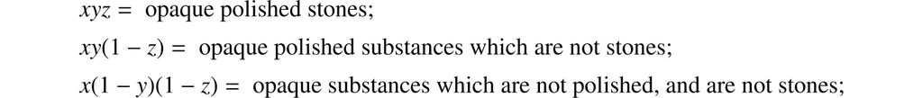

对于任何其他组合，依此类推。值得注意的是，这些表达式中的每一个都满足与它所包含的各个符号相同的二元性定律。因此，and so on for any other combination. Let it be observed, that each of these expressions satisfies the same law of duality, as the individual symbols which it contains. Thus,

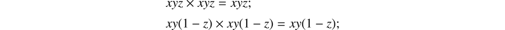

等等。任何上述术语我们都将指定为“类术语”，因为它通过该类中各个成员的共同属性或名称来表达一类事物。and so on. Any such term as the above we shall designate as a “class term,” because it expresses a class of things by means of the common properties or names of the individual members of such class.

其次，如果我们谈论一个事物的集合，其中的不同部分由不同的属性、名称或属性定义，则这些不同部分的表达式必须单独形成，然后通过符号+连接。但是，如果我们想要谈论的集合是通过从某个更广泛的集合中排除其成员的定义部分而形成的，则符号 - 必须在被排除部分的符号表达之前加上前缀。尊重这些符号的使用，可以添加一些进一步的观察。Secondly, If we speak of a collection of things, different portions of which are defined by different properties, names, or attributes, the expressions for those different portions must be separately formed, and then connected by the sign +. But if the collection of which we desire to speak has been formed by excluding from some wider collection a defined portion of its members, the sign − must be prefixed to the symbolical expression of the excluded portion. Respecting the use of these symbols some further observations may be added.

### **4.4.6** 一般来说，符号 + 相当于连词“和”“或”，符号 − 相当于介词“除去”。在“和”与“或”这两个连词中，当所描述的汇集构成命题的主项时，通常使用前者；构成谓项时，则通常使用后者。“学者*和*世故之人都渴望幸福”，可以作为前一种情形的例子。“有用的事物*要么*产生快乐，*要么*防止痛苦”，可以作为后一种情形的例子。现在，每当一个初等命题中出现含有这些虚词的表达式时，弄清它们在思想上所区分的各群或各类是否意在彼此完全不同、互相排斥，就变得十分重要。“学者和世故之人”这一说法，是包括还是排除了兼具这两种身份的人？“要么产生快乐，要么防止痛苦”这一说法，是包括还是排除了兼具这两种性质的事物？我认为，严格说来，连词“和”“或”确实具有这里所说的分离或排除作用；也就是说，“所有 *x* 要么是 *y*，要么是 *z*”这个表述，严格解释就是：“所有 *x* 要么是 *y* 而不是 *z*”，要么“是 *z* 而不是 *y*”。但同时也必须承认，*语言使用的权威和规范*似乎更倾向于相反的解释。“要么是 *y*，要么是 *z*”这一表达，通常会被理解为包括同时属于 *y* 和 *z* 的事物，也包括属于其中一类而不属于另一类的事物。不过，只要记住符号 + 确实具有前面讨论的分离作用，我们就必须把遇到的任何析取表达式分解为在思想上真正分离的各个成分，然后用符号 + 连接它们各自的表达式。**4.4.6** Speaking generally, the symbol + is the equivalent of the conjunctions “and,” “or,” and the symbol −, the equivalent of the preposition “except.” Of the conjunctions “and” and “or,” the former is usually employed when the collection to be described forms the subject, the latter when it forms the predicate, of a proposition. “The scholar *and* the man of the world desire happiness,” may be taken as an illustration of one of these cases. “Things possessing utility are *either* productive of pleasure *or* preventive of pain,” may exemplify the other. Now whenever an expression involving these particles presents itself in a primary proposition, it becomes very important to know whether the groups or classes separated in thought by them are intended to be quite distinct from each other and mutually exclusive, or not. Does the expression, “Scholars and men of the world,” include or exclude those who are both? Does the expression, “Either productive of pleasure or preventive of pain,” include or exclude things which possess both these qualities? I apprehend that in strictness of meaning the conjunctions “and,” “or,” do possess the power of separation or exclusion here referred to; that the formula, “All *x*’s are either *y*’s or *z*’s,” rigorously interpreted, means, “All *x*’s are either *y*’s, but not *z*’s,” or, “*z*’s but not *y*’s.” But it must at the same time be admitted, that the *jus et norma loquendi* seems rather to favour an opposite interpretation. The expression, “Either *y*’s or *z*’s,” would generally be understood to include things that are *y*’s and *z*’s at the same time, together with things which come under the one, but not the other. Remembering, however, that the symbol + does possess the separating power which has been the subject of discussion, we must resolve any disjunctive expression which may come before us into elements really separated in thought, and then connect their respective expressions by the symbol +.

因此，依照所隐含的含义，表达式“属于 *x* 或属于 *y* 的事物”会有两个不同的符号等价式。如果我们的意思是“属于 *x* 但不属于 *y*，或属于 *y* 但不属于 *x* 的事物”，那么表达式就是 *x*(1 − *y*) + *y*(1 − *x*)；其中符号 *x* 代表 *x* 类事物，*y* 代表 *y* 类事物。然而，如果我们的意思是“属于 *x*，或者若不属于 *x* 就属于 *y* 的事物”，表达式就是 *x* + *y*(1 − *x*)。这一表达式容许事物同时属于 *x* 和 *y*。它也可以更完整地写成 *xy* + *x*(1 − *y*) + *y*(1 − *x*) 的形式；但把前两项相加后，这个表达式就只会还原成前一个表达式。And thus, according to the meaning implied, the expression, “Things which are either *x*’s or *y*’s,” will have two different symbolical equivalents. If we mean, “Things which are *x*’s, but not *y*’s, or *y*’s, but not *x*’s,” the expression will be *x*(1 − *y*) + *y*(1 − *x*); the symbol *x* standing for *x*’s, *y* for *y*’s. If, however, we mean, “Things which are either *x*’s, or, if not *x*’s, then *y*’s,” the expression will be *x* + *y*(1 − *x*). This expression supposes the admissibility of things which are both *x*’s and *y*’s at the same time. It might more fully be expressed in the form *xy* + *x*(1 − *y*) + *y*(1 − *x*); but this expression, on addition of the two first terms, only reproduces the former one.

值得注意的是，上面给出的表达式满足对偶基本定律。因此我们有Let it be observed that the expressions above given satisfy the fundamental law of duality. Thus we have

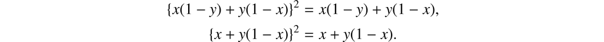

后面将会看到，这不过是表示“事物的类或汇集”的表达式的一条普遍法则的特殊表现。[编者：原文的第二个等式为 {*x* + (1 − *x*)}<sup>2</sup> = *x* + *y*(1 − *x*)，显然有误。]It will be seen hereafter, that this is but a particular manifestation of a general law of expressions representing “classes or collections of things.” [EDITOR: Original has {*x* + (1 − *x*)}<sup>2</sup> = *x* + *y*(1 − *x*) for the second equation, apparently in error.]

### **4.4.7** 这些研究的结果可以体现在以下表达规则中。**4.4.7** The results of these investigations may be embodied in the following rule of expression.

规则——用符号 *x*、*y*、*z* 等表示简单的名称或性质，用 1 − *x*、1 − *y*、1 − *z* 等表示它们的相反者；对于由共同名称或性质界定的事物的类，将相应符号像乘法那样连接起来；对于由彼此不同的部分组成的事物的集合，用符号 + 连接各部分的表达式。特别地，当所指的类互相排斥时，将“属于 *x* 或属于 *y*”这一表达式写为 *x*(1 − *y*) + *y*(1 − *x*)；当 *x* 与 *y* 所指的类不互相排斥时，写为 *x* + *y*(1 − *x*)。类似地，当 *x*、*y* 与 *z* 所指的类被规定为互相排斥时，将“属于 *x*、属于 *y* 或属于 *z*”写为 *x*(1 − *y*)(1 − *z*) + *y*(1 − *x*)(1 − *z*) + *z*(1 − *x*)(1 − *y*)；当它们并非被规定为互相排斥时，写为 *x* + *y*(1 − *x*) + *z*(1 − *x*)(1 − *y*)，依此类推。RULE.—*Express simple names or qualities by the symbols x*, *y*, *z, &c., their contraries by* 1 − *x*, 1 − *y*, 1 − *z, &c.; classes of things defined by common names or qualities, by connecting the corresponding symbols as in multiplication; collections of things, consisting of portions different from each other, by connecting the expressions of those portions by the sign* +*. In particular, let the expression, “Either x’s or y’s,” be expressed by x*(1 − *y*) + *y*(1 − *x*)*, when the classes denoted by x and y are exclusive, by x* + *y*(1 − *x*) *when they are not exclusive. Similarly let the expression, “Either x’s, or y’s, or z’s,” be expressed by x*(1 − *y*)(1 − *z*) + *y*(1 − *x*)(1 − *z*) + *z*(1 − *x*)(1 − *y*)*, when the classes denoted by x*, *y, and z, are designed to be mutually exclusive, by x* + *y*(1 − *x*) + *z*(1 − *x*)(1 − *y*)*, when they are not meant to be exclusive, and so on.*

### **4.4.8** 在这个表达规则的基础上建立了相反的解释规则。也许，这两种情况都将在以下实例中得到充分的例证。为简洁起见，省略普遍主题“事物”或“存在”，让我们假设*x* = 硬*，y* = 弹性*，z* = 金属；我们将得到以下结果：**4.4.8** On this rule of expression is founded the converse rule of interpretation. Both these will be exemplified with, perhaps, sufficient fulness in the following instances. Omitting for brevity the universal subject “things,” or “beings,” let us assume *x* = hard*, y* = elastic*, z* = metals; and we shall have the following results:

“非弹性金属”将表示为 *z*(1 − *y*)；“Non-elastic metals,” will be expressed by *z*(1 − *y*);

“具有非弹性金属的弹性物质”，由*y* + *z* (1 − *y* ) 得出；“Elastic substances with non-elastic metals,” by *y* + *z*(1 − *y*);

“硬质物质，金属除外”，*x* − *z*；“Hard substances, except metals,” by *x* − *z*;

“金属物质，除了那些既不坚硬又没有弹性的物质”“Metallic substances, except those which are neither hard nor elastic,” by

*z* − *z* (1 − *x* )(1 − *y* )，或*z* {1 − (1 − *x* )(1 − *y* )}。*z* − *z*(1 − *x*)(1 − *y*), or by *z*{1 − (1 − *x*)(1 − *y*)}.

在最后一个例子中，我们真正要表达的是“金属，除了不硬、不弹性的金属”。形容词之间使用的连词通常是多余的，因此不能用象征性的方式表达。In the last example, what we had really to express was “Metals, except not hard, not elastic, metals.” Conjunctions used between adjectives are usually superfluous, and, therefore, must not be expressed symbolically.

因此，“坚硬且有弹性的金属”相当于“硬弹性金属”，并用*xyz*表示。Thus, “Metals hard and elastic,” is equivalent to “Hard elastic metals,” and expressed by *xyz*.

接下来的表述是“硬质物质，除了金属和非弹性的物质，以及弹性和非金属的物质”。*这里“那些”*一词表示硬质物质，因此该表达的真正含义是，*除金属、非弹性硬质物质之外的硬质物质，以及非金属、弹性硬质物质*；这个词*除了*扩展到它后面的两个类之外。完整的表达式为*x* −{ *xz* (1 − *y* ) + *xy* (1 − *z* )}; 或者，*x* − *xz* (1 − *y* ) − *xy* (1 − *z* )。Take next the expression, “Hard substances, except those which are metallic and non-elastic, and those which are elastic and non-metallic.” Here the word *those* means hard substances, so that the expression really means, *Hard substances except hard substances, metallic, non-elastic, and hard substances non-metallic, elastic*; the word *except* extending to both the classes which follow it. The complete expression is *x* −{*xz*(1 − *y*) + *xy*(1 − *z*)}; or, *x* − *xz*(1 − *y*) − *xy*(1 − *z*).

## **4.5 符号推理的基本原理，以及涉及逻辑符号的表达式的扩展或发展……****4.5 Of the Fundamental Principles of Symbolical Reasoning, and of the Expansion or Development of Expressions Involving Logical Symbols …**

### **4.5.8** *定义*——任何包含符号 *x* 的代数表达式，都称为 *x* 的函数，并可以用一般的简写形式 *f*(*x*) 表示。任何包含两个符号 *x* 与 *y* 的表达式，同样称为 *x* 与 *y* 的函数，并可以用一般形式 *f*(*x, y*) 表示；其他任何情形也依此类推。…**4.5.8** *Definition*.—Any algebraic expression involving a symbol *x* is termed a function of *x*, and may be represented under the abbreviated general form *f*(*x*). Any expression involving two symbols, *x* and *y*, is similarly termed a function of *x* and *y*, and may be represented under the general form *f*(*x, y*), and so on for any other case. …

### **4.5.9** *定义*：任何函数*f* ( *x* )，其中*x*是逻辑符号，或仅对值 0 和 1 敏感的量符号，当它简化为*ax* + *b* (1 - *x* ), *a*和*b*的确定使得结果等于导出它的函数。**4.5.9** *Definition*.—Any function *f*(*x*), in which *x* is a logical symbol, or a symbol of quantity susceptible only of the values 0 and 1, is said to be developed, when it is reduced to the form *ax* + *b*(1 −*x*), *a* and *b* being so determined as to make the result equivalent to the function from which it was derived.

这个定义假定，任何函数 *f*(*x*) 都可以表示为所设想的形式。下面的命题将证明这一假定成立。This definition assumes, that it is possible to represent any function *f*(*x*) in the form supposed. The assumption is vindicated in the following Proposition.

### **4.5.10 *开发任意函数 f(x)，其中 x 是逻辑符号。*** 根据本章所主张的原则，将*x*视为数量符号是合法的，仅适用于值 0 和 1。**4.5.10 *To develop any function f(x) in which x is a logical symbol.*** By the principle which has been asserted in this chapter, it is lawful to treat *x* as a quantitative symbol, susceptible only of the values 0 and 1.

1. 重印自布尔 (1854)。Reprinted from Boole (1854).

# **5**

# 数学问题（1900）**Mathematical Problems (1900)**

## **大卫·希尔伯特****David Hilbert**

对于科学的进步来说，没有什么比知道要问什么问题更重要的了。哥廷根大学伟大的德国数学家戴维·希尔伯特（David Hilbert，1862-1943）利用二十世纪之交国际数学家大会的契机概括地描述了数学问题及其解决方案，并用一系列数学问题向他的同事提出了挑战。 23个未解决的问题。几个问题很快就得到了解决，但第十个问题花了七十年才解决，而且解决方案以希尔伯特在 1900 年无法阐明的形式——递归不可解性的证明——来解决。第八个问题，黎曼假设，仍然悬而未决。 ; 其他措辞更含糊的问题的地位是有争议的。Nothing is more important to the progress of science than knowing what question to ask. The great German mathematician David Hilbert (1862–1943) of the University of Göttingen used the occasion of the International Congress of Mathematicians at the turn of the twentieth century to characterize mathematical problems and their solutions generally, and to challenge his colleagues with a list of 23 unsolved problems. Several problems were solved quickly, but the tenth problem took seventy years to resolve, and the resolution came in a form—a demonstration of recursive unsolvability—that Hilbert could not have articulated in 1900. The eighth problem, the Riemann hypothesis, is still unresolved; the status of other more ambiguously worded problems is arguable.

2000 年，克莱数学研究所更新了希尔伯特的名单，列出了七个千年奖问题，并为解决每个问题提供 100 万美元的奖励（克莱数学研究所，2000 年）。迄今为止，只有一个——庞加莱猜想——得到了解决。黎曼猜想被列入千年名单；𝒫 = 𝒩𝒫问题也是如此（第 34 章）。In the year 2000, the Clay Mathematics Institute updated Hilbert’s list with a list of seven Millennium Prize problems, offering a $1 million dollar reward for the solution of each (Clay Mathematics Institute, 2000). To date, only one—the Poincaré conjecture—has been solved. The Riemann hypothesis is on the Millennium list; so is the 𝒫 = 𝒩𝒫 problem (chapter 34).

然而，随着数学形式化的尝试变得更加有力，一些不一致和悖论出现了。希尔伯特对其乐观主义的基础不稳固感到不安，他向数学界发起挑战，要求“一劳永逸地解决数学中的基本问题”（Hilbert，1928；Van Heijenoort，1967）。这个挑战被称为希尔伯特计划，只有当挑战提出后，我们才能想象它可能无法实现。Yet as the attempts to formalize mathematics became more robust, several inconsistencies and paradoxes emerged. Hilbert, troubled by the shaky ground on which his optimism was founded, challenged the mathematical community to “dispose of the foundational questions in mathematics as such once and for all” (Hilbert, 1928; Van Heijenoort, 1967). This challenge became known as Hilbert’s program, and only once the challenge was posed was it possible to imagine that it might not be achievable.

在希尔伯特 1900 年的演讲中，并没有太多思考这种不可能。语气是振奋和鼓励的。每个问题都可以以某种方式解决。不存在*无知的情况*（字面意思是，不存在“我们不会知道”——也就是说，不放弃寻找答案）。In Hilbert’s 1900 address, there is not much thinking about such an impossibility. The tone is uplifting and encouraging. Every problem can be solved, one way or another. There is no *ignorabimus* (literally, no “we shall not know”—that is, no giving up on finding the answer).

事实上，这种精神渗透到了当时的人类文化中。二十世纪之交是世界普遍积极的时刻。战争是有限的且规模可控。工业革命带来了繁荣和进步，至少给西方世界带来了繁荣和进步。五千万人参观了巴黎世界*博览会*，亲眼目睹现代世界的奇迹。*新艺术*（“新艺术”）风格的浪漫、旋涡状艺术品表达了人们的普遍感受：生活是温柔的、美丽的、有机繁荣的，而且只会变得更好。In fact this spirit informed much of human culture at the time. The turn of the twentieth century was a moment of general positivity in the world. Wars were limited and of manageable scale. The Industrial Revolution had brought prosperity and progress, at least to the Western world. Fifty million people visited the *Exposition Universelle* (World Fair) in Paris to see first-hand the wonders of the modern world. Romantic, swirly artworks in the *art nouveau* (“new art”) style spoke to the general feelings that life was gentle, beautiful, flourishing organically, and could only get better.

我们摘录希尔伯特演讲的序言。在这 23 个问题中，我们只包括第二个问题和第十个问题。第十个问题是确定丢番图方程是否在整数上可解的问题。这些方程的形式为*p* ( *x*<sub>1</sub>*, … , x* <sub>*k*</sub> ) = 0，其中*p*是多项式，其中项是整数常量乘以变量的整数次方的乘积，例如

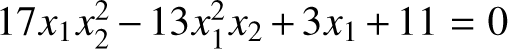

。*x*<sub>1</sub> , … , *x*<sub>*k*</sub>的值为整数的要求将看起来像代数问题的问题变成了组合问题。马丁·戴维斯 (Martin Davis)、希拉里·帕特南 (Hilary Putnam)、朱莉娅·罗宾逊 (Julia Robinson) 和尤里·马蒂亚塞维奇 (Yuri Matiyasevich) 长达数十年的努力最终证明了确定此类方程是否有解的一般问题是无法解决的，而马蒂亚塞维奇 (Matiyasevich)在 1970 年贡献了数论*致命一击*(Matiyasevich) ，1993）。We excerpt the prefatory remarks of Hilbert’s address. Of the 23 problems, we include only the second and the tenth. The tenth is the problem of determining whether a diophantine equation is solvable over the integers. These are equations of the form *p*(*x*<sub>1</sub>*, …, x*<sub>*k*</sub>) = 0, where *p* is a polynomial in which the terms are integer constants multiplied by products of the variables raised to integer powers—for example,

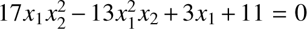

. The requirement that the values of *x*<sub>1</sub>, …, *x*<sub>*k*</sub> be integers turns what looks like an algebraic problem into a combinatorial problem. The decades-long efforts of Martin Davis, Hilary Putnam, Julia Robinson, and Yuri Matiyasevich eventually demonstrated the unsolvability of the general problem of determining whether such an equation has a solution, with Matiyasevich contributing the number-theoretic *coup de grâce* in 1970 (Matiyasevich, 1993).

希尔伯特发表讲话十五年后，欧洲正陷入一场血腥、看似毫无意义且无休无止的战争的深渊。文学变得讽刺和愤世嫉俗；视觉艺术中出现了黑暗和暴力的主题。仿佛反映了悲观主义的转变，在两次世界大战之间，哥德尔和图灵展示了象征性地形式化离散步骤的有限过程的想法所带来的意想不到的后果。正式系统本身似乎有其局限性。Fifteen years after Hilbert’s address, Europe was in the depths of a bloody, seemingly senseless and endless war. Literature turned ironic and cynical; dark and violent themes emerged in the visual arts. As though reflecting the pessimistic shift, between the two World Wars Gödel and Turing demonstrated the unexpected consequences of formalizing symbolically the idea of a finite process of discrete steps. Formal systems themselves have their limits, it seemed.

20 世纪 20 年代，希尔伯特的健康状况每况愈下，而在他周围成长起来的哥廷根数学学院在纳粹清除犹太教授后几乎全部解散。希尔伯特的墓碑上刻着（德语）他的勇敢话语：“我们必须知道。我们会知道的。” 他在 1930 年说过这句话，就在库尔特·哥德尔宣布希尔伯特第二个问题（关于公理的独立性和一致性）的一系列调查结果的前一天。哥德尔证明，在任何强大到足以使基本算术公理化的递归公理化一致逻辑系统中，一些真命题无法被证明，从而混淆了对已知问题的简单答案的任何尝试。Hilbert’s health declined during the 1920s, and the great school of mathematicians that had grown around him at Göttingen was all but dissolved when the Nazis purged it of Jewish professors. Hilbert’s gravestone bears (in German) his brave words, “We must know. We shall know.” He had said this in 1930, on the day before Kurt Gödel announced a result in a line of inquiry stimulated by Hilbert’s second problem, about the independence and consistency of axioms. Gödel proved that in any recursively axiomatizable consistent logical system strong enough to axiomatize basic arithmetic, some true propositions could not be proved—thus confounding any attempt at a simple answer to the question of what can be known.

然而，哥德尔和图灵在关上一扇门的同时，也打开了无数扇门。哥德尔证明数学永远不可能是一个单一的封闭系统，这也意味着它的可能性是无限的。图灵通过定义什么是算法来证明算法不能做什么，开启了算法研究的理论和实践科学分析，并开创了当今的计算世界。And yet, in closing one door, Gödel and Turing opened countless others. Gödel’s proof that mathematics can never be a single closed system also meant that its possibilities are limitless. Turing, in defining what an algorithm is in order to prove what algorithms cannot do, opened the study of algorithms to scientific analysis, both theoretical and practical, and ushered in the computational world of today.

我们谁都不愿意揭开隐藏未来的面纱；看看我们科学的下一步进展及其在未来几个世纪发展的秘密？未来几代领先的数学精神将努力实现哪些具体目标？新世纪将在广阔而丰富的数学思想领域揭示哪些新方法和新事实？WHO of us would not be glad to lift the veil behind which the future lies hidden; to cast a glance at the next advances of our science and at the secrets of its development during future centuries? What particular goals will there be toward which the leading mathematical spirits of coming generations will strive? What new methods and new facts in the wide and rich field of mathematical thought will the new centuries disclose?

历史告诉我们科学发展的连续性。我们知道，每个时代都有自己的问题，下一个时代要么解决了这些问题，要么认为这些问题无利可图而被抛弃并被新的问题所取代。如果我们想了解数学知识在不久的将来可能的发展，我们就必须把悬而未决的问题抛在脑后，并审视当今科学提出的问题以及我们期望未来得到的解决方案。在我看来，在几个世纪的会议上对当今的问题进行这样的回顾是非常适合的。一个伟大时代的结束，不仅让我们回顾过去，也让我们思考未知的未来。History teaches the continuity of the development of science. We know that every age has its own problems, which the following age either solves or casts aside as profitless and replaces by new ones. If we would obtain an idea of the probable development of mathematical knowledge in the immediate future, we must let the unsettled questions pass before our minds and look over the problems which the science of today sets and whose solution we expect from the future. To such a review of problems the present day, lying at the meeting of the centuries, seems to me well adapted. For the close of a great epoch not only invites us to look back into the past but also directs our thoughts to the unknown future.

某些问题对于数学科学整体进步的深刻意义以及它们在个别研究者的工作中所发挥的重要作用是不容否认的。只要科学的一个分支能够提出大量的问题，它就能存在多久；没有问题就预示着消亡或独立发展的停止。正如人类的每一项事业都追求特定的目标一样，数学研究也需要它的问题。调查者通过解决问题来检验他的钢铁品质。他找到了新的方法、新的观点，获得了更广阔、更自由的视野。The deep significance of certain problems for the advance of mathematical science in general and the important role which they play in the work of the individual investigator are not to be denied. As long as a branch of science offers an abundance of problems, so long is it alive; a lack of problems foreshadows extinction or the cessation of independent development. Just as every human undertaking pursues certain objects, so also mathematical research requires its problems. It is by the solution of problems that the investigator tests the temper of his steel; he finds new methods and new outlooks, and gains a wider and freer horizon.

提前正确判断问题的价值是很困难的，而且往往是不可能的；因为最终的奖项取决于科学从问题中获得的收益。尽管如此，我们还是可以问是否存在标志着一个好的数学问题的一般标准。一位法国老数学家说过：“一个数学理论只有在你能够向街上遇到的第一个人解释清楚之后才能被认为是完整的。” 这里对于数学理论所坚持的清晰易懂，我更应该要求数学问题如果要完美的话；因为清晰易懂的事物会吸引我们，复杂的事物会令我们排斥。It is difficult and often impossible to judge the value of a problem correctly in advance; for the final award depends upon the gain which science obtains from the problem. Nevertheless we can ask whether there are general criteria which mark a good mathematical problem. An old French mathematician said: “A mathematical theory is not to be considered complete until you have made it so clear that you can explain it to the first man whom you meet on the street.” This clearness and ease of comprehension, here insisted on for a mathematical theory, I should still more demand for a mathematical problem if it is to be perfect; for what is clear and easily comprehended attracts, the complicated repels us.

此外，数学问题应该很困难才能吸引我们，但又不能完全难以解决，以免它嘲笑我们的努力。对于我们来说，它应该是通往隐藏真相的迷宫之路的指南，并最终提醒我们对成功解决方案的喜悦。过去几个世纪的数学家习惯于以极大的热情致力于解决困难的特定问题。他们知道困难问题的价值。我只提醒你约翰·伯努利提出的“最快下降线问题”。伯努利在公开宣布这个问题时解释说，经验告诉我们，只有通过向他们提出困难但同时又有用的问题，才能引导崇高的思想者为科学的进步而奋斗，因此他希望赢得感谢追随梅森、帕斯卡、费马、维维亚尼等人的榜样，向当时杰出的分析家提出一个问题，作为试金石，他们可以通过这个问题来检验数学世界的发展他们的方法的价值并衡量他们的力量。变分法起源于伯努利问题和类似问题。Moreover a mathematical problem should be difficult in order to entice us, yet not completely inaccessible, lest it mock at our efforts. It should be to us a guide post on the mazy paths to hidden truths, and ultimately a reminder of our pleasure in the successful solution. The mathematicians of past centuries were accustomed to devote themselves to the solution of difficult particular problems with passionate zeal. They knew the value of difficult problems. I remind you only of the “problem of the line of quickest descent,” proposed by John Bernoulli. Experience teaches, explains Bernoulli in the public announcement of this problem, that lofty minds are led to strive for the advance of science by nothing more than by laying before them difficult and at the same time useful problems, and he therefore hopes to earn the thanks of the mathematical world by following the example of men like Mersenne, Pascal, Fermat, Viviani and others and laying before the distinguished analysts of his time a problem by which, as a touchstone, they may test the value of their methods and measure their strength. The calculus of variations owes its origin to this problem of Bernoulli and to similar problems.

谈到一个非常不同的研究领域，我提醒您三个机构的问题。庞加莱在天体力学中引入的富有成效的方法和影响深远的原理，以及今天在实际天文学中得到认可和应用的，都是由于他致力于重新处理这个难题并接近解决方案。To speak of a very different region of research, I remind you of the problem of three bodies. The fruitful methods and the far-reaching principles which Poincaré has brought into celestial mechanics and which are today recognized and applied in practical astronomy are due to the circumstance that he undertook to treat anew that difficult problem and to approach nearer a solution.

最后提到的两个问题——费马问题和三体问题——在我们看来几乎就像相反的两极——前者是纯粹理性的自由发明，属于抽象数论领域，后者是天文学强加给我们的对于理解自然最简单的基本现象是必要的。The two last mentioned problems—that of Fermat and the problem of the three bodies—seem to us almost like opposite poles—the former a free invention of pure reason, belonging to the region of abstract number theory, the latter forced upon us by astronomy and necessary to an understanding of the simplest fundamental phenomena of nature.

但也经常发生这样的情况：同一特殊问题在最不同的数学知识分支中得到应用。因此，例如，最短线问题在几何基础、曲线和曲面理论、力学和变分法中起着主要且具有历史意义的重要作用。F.克莱因在他关于二十面体的著作中，多么令人信服地描绘了正多面体问题在初等几何、群论、方程论和线性微分方程中的重要性。……But it often happens also that the same special problem finds application in the most unlike branches of mathematical knowledge. So, for example, the problem of the shortest line plays a chief and historically important part in the foundations of geometry, in the theory of curved lines and surfaces, in mechanics and in the calculus of variations. And how convincingly has F. Klein, in his work on the icosahedron, pictured the significance which attaches to the problem of the regular polyhedra in elementary geometry, in group theory, in the theory of equations and in that of linear differential equations. …

仍然需要简要讨论解决数学问题时可以合理地规定哪些一般要求。我首先要说的是：通过基于有限数量的假设的有限步骤，可以确定解决方案的正确性，这些假设隐含在问题的陈述中，并且必须始终是完全制定。这种通过有限数量的过程进行逻辑推演的要求，就是对推理严谨性的要求。事实上，严谨性的要求在数学中已成为众所周知，它符合我们理解的普遍哲学必然性。另一方面，只有满足了这一要求，问题的思想内容和暗示性才能充分发挥作用。一个新问题，尤其是当它来自外部经验世界时，就像一根年轻的树枝，它会茁壮成长并结出果实只有当它按照严格的园艺规则小心地嫁接在老茎上时，我们数学科学的既定成就才得以实现。……It remains to discuss briefly what general requirements may be justly laid down for the solution of a mathematical problem. I should say first of all, this: that it shall be possible to establish the correctness of the solution by means of a finite number of steps based upon a finite number of hypotheses which are implied in the statement of the problem and which must always be exactly formulated. This requirement of logical deduction by means of a finite number of processes is simply the requirement of rigor in reasoning. Indeed the requirement of rigor, which has become proverbial in mathematics, corresponds to a universal philosophical necessity of our understanding; and, on the other hand, only by satisfying this requirement do the thought content and the suggestiveness of the problem attain their full effect. A new problem, especially when it comes from the world of outer experience, is like a young twig, which thrives and bears fruit only when it is grafted carefully and in accordance with strict horticultural rules upon the old stem, the established achievements of our mathematical science. …

关于数学问题可能带来的困难以及克服这些困难的方法的一些评论可能在这里。Some remarks upon the difficulties which mathematical problems may offer, and the means of surmounting them, may be in place here.

如果我们没有成功地解决数学问题，原因往往在于我们未能认识到更普遍的观点，从这个观点来看，我们面前的问题只是一系列相关问题中的一个环节。找到了这个立场之后，我们不仅对这个问题的研究往往更容易理解，而且同时我们也掌握了一种同样适用于相关问题的方法。柯西提出的复杂积分路径和库默提出的数论理想概念可以作为例子。这种寻找通用方法的方式无疑是最实用、最确定的；因为，如果一个人在头脑中没有明确的问题而寻求方法，那么他的寻求大部分都是徒劳的。If we do not succeed in solving a mathematical problem, the reason frequently consists in our failure to recognize the more general standpoint from which the problem before us appears only as a single link in a chain of related problems. After finding this standpoint, not only is this problem frequently more accessible to our investigation, but at the same time we come into possession of a method which is applicable also to related problems. The introduction of complex paths of integration by Cauchy and of the notion of the IDEALS in number theory by Kummer may serve as examples. This way for finding general methods is certainly the most practicable and the most certain; for he who seeks for methods without having a definite problem in mind seeks for the most part in vain.

我认为，在处理数学问题时，专业化比泛化发挥着更重要的作用。也许在大多数情况下，我们徒劳地寻找问题的答案，失败的原因在于，比当前问题更简单、更容易的问题要么根本没有解决，要么没有完全解决。那么，一切都取决于找出这些更简单的问题，并通过尽可能完美的设备和能够概括的概念来解决它们。这条规则是克服数学困难的最重要的杠杆之一，在我看来，它几乎总是被使用，尽管可能是无意识的。In dealing with mathematical problems, specialization plays, as I believe, a still more important part than generalization. Perhaps in most cases where we seek in vain the answer to a question, the cause of the failure lies in the fact that problems simpler and easier than the one in hand have been either not at all or incompletely solved. All depends, then, on finding out these easier problems, and on solving them by means of devices as perfect as possible and of concepts capable of generalization. This rule is one of the most important levers for overcoming mathematical difficulties and it seems to me that it is used almost always, though perhaps unconsciously.

有时，我们会在假设不足或理解有误的情况下寻求解答，因而无法成功。于是，问题就变成：证明在给定假设下，或在所设想的意义上，解答是不可能的。古人就作出过这样的不可能性证明，例如他们证明了等腰直角三角形的斜边与直角边之比是无理数。在后来的数学中，某些解答的不可能性问题占有极其重要的地位；我们由此看到，一些古老而困难的问题，例如平行公理的证明、化圆为方、五次方程的根式求解，终于得到了完全令人满意而且严格的解决，尽管解决的意义与最初的意图不同。也许正是这一重要事实，连同其他哲学上的理由，产生了这样一种信念：每一个明确的数学问题，都必然能够得到确切的解决，其形式要么是对所提问题的实际回答，要么是证明问题无解，从而证明所有尝试都必然失败。这一信念为每位数学家所共有，但迄今尚无人用证明来支持它。任取一个明确而尚未解决的问题，例如欧拉—马歇罗尼常数 *C* 是否为无理数，或者形如 2<sup>*n*</sup> + 1 的素数是否有无穷多个。无论这些问题在我们看来多么难以接近，无论面对它们我们多么无能为力，我们仍然坚信，它们的解决必然能够通过有限次纯逻辑过程获得。Occasionally it happens that we seek the solution under insufficient hypotheses or in an incorrect sense, and for this reason do not succeed. The problem then arises: to show the impossibility of the solution under the given hypotheses, or in the sense contemplated. Such proofs of impossibility were effected by the ancients, for instance when they showed that the ratio of the hypotenuse to the side of an isosceles right triangle is irrational. In later mathematics, the question as to the impossibility of certain solutions plays a preeminent part, and we perceive in this way that old and difficult problems, such as the proof of the axiom of parallels, the squaring of the circle, or the solution of equations of the fifth degree by radicals have finally found fully satisfactory and rigorous solutions, although in another sense than that originally intended. It is probably this important fact along with other philosophical reasons that gives rise to the conviction (which every mathematician shares, but which no one has as yet supported by a proof) that every definite mathematical problem must necessarily be susceptible of an exact settlement, either in the form of an actual answer to the question asked, or by the proof of the impossibility of its solution and therewith the necessary failure of all attempts. Take any definite unsolved problem, such as the question as to the irrationality of the Euler-Mascheroni constant *C*, or the existence of an infinite number of prime numbers of the form 2<sup>*n*</sup> + 1. However unapproachable these problems may seem to us and however helpless we stand before them, we have, nevertheless, the firm conviction that their solution must follow by a finite number of purely logical processes.

每个问题都可解决的这一公理是否只是数学思想的独特特征，或者它可能是心灵本质中固有的普遍法则，即它提出的所有问题都必须是可回答的？因为在其他科学中，人们也会遇到老问题，这些问题已通过证明其不可能性而以对科学最令人满意和最有用的方式得到解决。我以永动机问题为例。在徒劳地寻求建造永动机之后，我们研究了如果这种机器不可能实现的话，自然力之间必须存在的关系。这个颠倒的问题导致了能量守恒定律的发现，该定律再次解释了最初意义上的永动机的不可能性。Is this axiom of the solvability of every problem a peculiarity characteristic of mathematical thought alone, or is it possibly a general law inherent in the nature of the mind, that all questions which it asks must be answerable? For in other sciences also one meets old problems which have been settled in a manner most satisfactory and most useful to science by the proof of their impossibility. I instance the problem of perpetual motion. After seeking in vain for the construction of a perpetual motion machine, the relations were investigated which must subsist between the forces of nature if such a machine is to be impossible; and this inverted question led to the discovery of the law of the conservation of energy, which, again, explained the impossibility of perpetual motion in the sense originally intended.

对每个数学问题都可以解决的信念对工人来说是一种强大的激励。我们听到内心不断的呼唤：问题来了。求其解决办法。你可以通过纯粹的理性找到它，因为数学中不存在*无知者*。……This conviction of the solvability of every mathematical problem is a powerful incentive to the worker. We hear within us the perpetual call: There is the problem. Seek its solution. You can find it by pure reason, for in mathematics there is no *ignorabimus*. …

2.算术公理的兼容性_ _ _ _2. THE COMPATIBILITY OF THE ARITHMETICAL AXIOMS

当我们致力于研究一门科学的基础时，我们必须建立一个公理体系，其中包含对该科学基本思想之间存在的关系的准确而完整的描述。如此建立的公理同时也是那些基本思想的定义。在我们正在测试其基础的科学领域内，任何陈述都不能被认为是正确的，除非它可以通过有限数量的逻辑步骤从这些公理中推导出来。经过仔细考虑，问题出现了：*单个公理的某些陈述是否以任何方式相互依赖，以及这些公理是否因此可能不包含某些共同部分，如果人们希望得出一个公理系统，则必须将这些共同部分分离出来彼此之间应完全独立。*When we are engaged in investigating the foundations of a science, we must set up a system of axioms which contains an exact and complete description of the relations subsisting between the elementary ideas of that science. The axioms so set up are at the same time the definitions of those elementary ideas; and no statement within the realm of the science whose foundation we are testing is held to be correct unless it can be derived from those axioms by means of a finite number of logical steps. Upon closer consideration the question arises: *Whether, in any way, certain statements of single axioms depend upon one another, and whether the axioms may not therefore contain certain parts in common, which must be isolated if one wishes to arrive at a system of axioms that shall be altogether independent of one another.*

但最重要的是，我希望将以下问题指定为关于公理可以提出的众多问题中最重要的一个：*证明它们并不矛盾，也就是说，基于它们的有限数量的逻辑步骤永远不可能导致矛盾的结果。* ……But above all I wish to designate the following as the most important among the numerous questions which can be asked with regard to the axioms: *To prove that they are not contradictory, that is, that a finite number of logical steps based upon them can never lead to contradictory results.* …

10.丢番图方程可解性的测定10. DETERMINATION OF THE SOLVABILITY OF A DIOPHANTINE EQUATION

给定一个具有任意数量的未知量和有理积分数值系数的丢番图方程：*设计一个过程，根据该过程可以通过有限数量的运算确定该方程是否可解为有理整数。* ……Given a diophantine equation with any number of unknown quantities and with rational integral numerical coefficients: *To devise a process according to which it can be determined by a finite number of operations whether the equation is solvable in rational integers.* …

1. 重印自希尔伯特 (1902)。Reprinted from Hilbert (1902).

# **6**

# 论可计算数及其在判定问题上的应用（1936）**On Computable Numbers, with an Application to the Entscheidungsproblem (1936)**

## **艾伦·麦森·图灵****Alan Mathison Turing**

“Entscheidungsproblem”是德语，意为“判定问题”；加上定冠词时，特指判定任意数学命题是否可证的问题。到 1928 年，数学的逻辑基础已经确立得足够牢固，使得大卫·希尔伯特和他的学生威廉·阿克曼能够明确规定，所讨论的公理系统就是谓词演算（在这里称作“函数演算 *K*”）。寻找一种程序的竞赛就此展开：它实际上应能回答所有数学问题，从而完成希尔伯特纲领。不同研究者为谓词演算的某些片段提出了判定程序，但起初并没有人认真着手证明这种程序不可能存在——部分原因是，“判定程序”的概念还只是直观的。要设想可能不存在这样的程序，就必须先划定所有程序所组成的类的边界。“Entscheidungsproblem” is German for “decision problem,” and with the definite article refers to the problem of determining whether an arbitrary mathematical proposition is provable. In 1928, the logical foundations of mathematics had been firmly enough established that David Hilbert and his student Wilhelm Ackermann could stipulate that the axiomatic system in question was the predicate calculus (referred to here as the “functional calculus *K*”). The hunt was on to find a procedure that would, in effect, answer all mathematical questions and complete Hilbert’s program. Various researchers offered decision procedures for fragments of the predicate calculus, but there was at first no serious work toward an impossibility proof—in part because the notion of a “decision procedure” was merely intuitive. Imagining that no procedure might exist required that the class of all procedures be circumscribed.

1930 年，库尔特·哥德尔宣布了他那具有开创性的否定性结果（Gödel，1931）：在任何类似《*数学原理*》（Whitehead 和 Russell，1910）或谓词演算的系统中，都有一些命题既不能证明，也不能证伪（除非系统本身不一致；在这种情况下，一切都可以证明）。为此，哥德尔采用了对角线论证的一种变体；康托尔曾在 1891 年用这种论证证明实数不可数（依照图灵的用语，不说“不可枚举”）。哥德尔的另一项创新，是把有限符号串（例如谓词演算中的一个公式）编码为正整数：对于长度为 *k* 的符号串，采用前 *k* 个素数的乘积，并令第 *k*<sup>th</sup> 个素数的指数为一个编码符号串中第 *k*<sup>th</sup> 个符号的数字。In 1930 Kurt Gödel announced his groundbreaking negative result (Gödel, 1931), that in any system like that of *Principia Mathematica* (Whitehead and Russell, 1910) or the predicate calculus, some propositions were neither provable nor disprovable (unless the system itself is inconsistent, in which case everything is provable). To do this, Gödel exploited a version of the diagonalization argument that Cantor had used in 1891 to prove that the real numbers were not countable (not “enumerable,” to follow Turing’s usage). Gödel’s other innovation was to encode a finite string of symbols (a formula of the predicate calculus, for example) as a positive integer, using a product of the first *k* primes for a string of length *k* and making the exponent of the *k*<sup>th</sup> prime a digit encoding the *k*<sup>th</sup> symbol of the string.

哥德尔的结果令人震惊，但它并没有解决Entscheidungs问题。（尽管正如图灵在第 60 页所解释的那样，如果哥德尔证明了与他所证明的相反的结果，他就会从积极的角度解决 Entscheidungs 问题。） 阿朗佐·丘奇和图灵很快以非常不同的方式形式化了“算法”的概念。但同样的方式，Church (1936b) 首先通过 lambda 演算，图灵随后不久通过现在所谓的图灵机。两人都因证明了Entscheidungs问题的不可解决性而受到赞誉。Gödel’s result was stunning, but it did not settle the Entscheidungsproblem. (Though as Turing explains on page 60, had Gödel proved the opposite of what he did prove, he would have settled the Entscheidungsproblem in the positive.) In rapid succession, Alonzo Church and Turing formalized the notion of an “algorithm” in very different but equivalent ways, Church (1936b) first via the lambda-calculus, and Turing shortly after via what are now called Turing machines. Both are credited with showing the unsolvability of the Entscheidungsproblem.

每个作者都面临着双重任务：证明他的定理，并让读者相信他的计算过程类足够大，足以涵盖所有可以想象的计算过程。由于 lambda 演算的深奥性，Church 的论文在后一点上没有说服力——尽管 lambda 演算后来成为函数式编程的基础（第 21 章）。Each author was faced with the dual tasks of proving his theorem, and of convincing his readers that his class of computational procedures was large enough to encompass all imaginable computational processes. Because of the abstruseness of the lambda-calculus, Church’s paper was unpersuasive on the latter point—even though the lambda-calculus would later become the basis for functional programming (chapter 21).

因此，图灵的机器必须足够简单，能够证明它们不能做什么，但又必须足够强大，能够执行任何有理智的人称之为计算的事情。我们包含两个参数的部分内容，但省略了所有代码。事实证明，图灵机器的“在盒子里写一个符号并移动到相邻盒子”的还原论已经被数学家埃米尔·波斯特预见到了，然而，他并没有采取进一步的行动。进行证明所需的步骤。波斯特的作品提到了 Church (1936b)，但当时尚未出版，出现在 Davis (1965，第 289-291 页)中。Thus Turing’s machines had to be simple enough to admit a proof of what they could not do, and yet demonstrably powerful enough to carry out anything that a reasonable person would call a computation. We include parts of both arguments, but we omit all the code. It turned out that the write-a-symbol-in-a-box-and-move-to-an-adjacent-box reductionism of Turing’s machines had been anticipated by the mathematician Emil Post, who, however, did not take the further steps needed to carry out the proof. Post’s work, which refers to Church (1936b) but was unpublished at the time, appears in Davis (1965, pp. 289–291).

解释一下图灵的用语会有所帮助。他的机器（他仅用“computer”一词指执行计算的人，即计算员）的设计方式很简单：从空白纸带启动，然后开始工作。它们印出 0 和 1（他称之为“数字”），中间也许夹杂其他符号。这一可能无限延伸的数字序列，应当在开头加上小数点来读，因而代表 0 与 1 之间的一个实数。这些实数有些是可计算的，有些则不是（因为机器的数量是可数的，而 [0,1] 中实数的数量不可数）。很容易把一个可计算数看作表示一个可计算的非负整数集合的方式（计算 [0, 1] 中某个实数的第 *i* 个二进制位，等价于判定整数 *i* 是否属于与该实数对应的集合），也可以采用另一种编码体系来表示从整数到整数的可计算函数，等等。It will be helpful to gloss Turing’s language. His machines (he used the term “computer” only to refer to a human being carrying out a computation) are designed simply to start up on blank tape and go to work. They print 0s and 1s (what he calls “figures”), perhaps interspersed with other symbols. The possibly infinite series of figures is to be read with a decimal point at the beginning, and so represents a real number between 0 and 1. Some such real numbers are computable, and some are not (because the number of machines is countable but the number of reals in [0,1] is not). It is easy to see a computable number as a way of representing a computable set of nonnegative integers (calculating the *i*<sup>th</sup> bit of a real number in [0, 1] is equivalent to determining whether the integer *i* is or is not in the set corresponding to that real number), or a computable function from integers to integers using a different coding system, etc.

图灵所说的*m*配置现在被称为机器的状态，并且通常使用字母*q*的变体来表示。相比之下，“配置”由状态和扫描符号组成，即决定下一步行动的所有内容，而“完整配置”还包括磁带的全部内容和扫描头的位置 -关于机器在特定运行时刻的所有信息。What Turing calls an *m*-configuration would today be called a state of the machine, and is generally denoted using a variant on the letter *q*. A “configuration,” by contrast, consists of both the state and the scanned symbol, that is, everything that determines the next move, and a “complete configuration” includes also the full contents of the tape and the location of the scanning head—everything there is to say about the machine at a particular moment of its operation.

“圆形”机器是只打印有限多个图形的机器，而“无圆”机器是打印无限系列图形的机器。A “circular” machine is one that prints only finitely many figures, and a “circle-free” machine is one that prints an infinite series of figures.

图灵的“通用”机器是一种可以模拟任何其他机器的机器。为了提供一台机器作为通用机器的输入，图灵需要通过固定字母表对任意机器进行编码。他将状态*q*<sub>*i*</sub>表示为*DA* <sup>*i*</sup>，将符号*S*<sub>*j*</sub>表示为*DC* <sup>*j*</sup>。这样编码的四元组的串联就是图灵称为“标准描述”（SD）的字符串，这是存储程序的第一个清晰实例：通用存储器可以用来存储程序，因此程序之间没有本质区别和数据。图灵用十进制数字替换了通用代码中的几个单独符号，为每台机器导出了一个数值，他称之为“描述号”或 DN——这是一种与哥德尔设计的不同的将字符串编码为数字的技术。从通用机器的存在来看，图灵能够通过对角化证明没有机器能够可靠地区分圆形机器和无圆机器。再经过几个步骤，Entscheidungs 问题就变得无法解决了。（我们省略了逻辑公式中代表机器计算的大部分结构——细节有缺陷，后来得到了纠正[Turing, 1938]。）Turing’s “universal” machine is one that can simulate any other. To provide a machine as input to the universal machine, Turing needed an encoding of arbitrary machines over a fixed alphabet. He represented state *q*<sub>*i*</sub> as *DA*<sup>*i*</sup> and symbol *S*<sub>*j*</sub> by *DC*<sup>*j*</sup>. The concatenation of the quadruples thus encoded was a string Turing called the “standard description” (S.D), the first clear instantiation of a stored program: the general purpose memory could be used to store a program, so there was no essential difference between program and data. Replacing the few individual symbols in this universal code by decimal digits, Turing derived a numerical value for each machine, what he called its “description number” or D.N—a different technique for encoding strings as numbers than the one Gödel had devised. From the existence of the universal machine Turing is able to show by diagonalization that no machine can reliably distinguish circular from circle-free machines. In a couple of further steps, the unsolvability of the Entscheidungsproblem followed. (We omit most of the construction representing a machine computation in a logical formula—the details were flawed and later corrected [Turing, 1938].)

安德鲁·霍奇斯 (Andrew Hodges) 的传记（1983 年）详细记录了艾伦·马西森·图灵（Alan Mathison Turing，1912-1954 年）的一生，电影*《模仿游戏》*就是根据该传记改编的。图灵写了这篇论文两年后获得剑桥数学一等荣誉，然后在普林斯顿大学丘奇学院攻读博士学位。他的数学生涯转向支持二战期间的密码破译工作。他被揭露为同性恋，失去了安全许可并被捕。在接受化学阉割作为监禁的替代方法后，他死于氰化物中毒——显然是自杀，尽管有些人注意到有证据表明死亡可能是意外。他去世时年仅 41 岁，正如科普作家切特·雷莫 (Chet Raymo，1996) 所说，他是“一位输给非理性的逻辑巨人”。2014 年，伊丽莎白女王赦免了图灵，将他的猥亵定罪从记录中抹去；2019 年，英格兰银行宣布他的形象将出现在50*英镑的钞票上。*The life of Alan Mathison Turing (1912–1954) is well documented in the biography by Andrew Hodges (1983), on which the film *The Imitation Game* is based. Turing wrote this paper two years after receiving first class honours in mathemactics from Cambridge, and then studied for his PhD under Church at Princeton. His mathematical career was diverted in support of the codebreaking effort during World War II. Outed as a homosexual, he lost his security clearance and was arrested. Having accepted chemical castration as an alternative to imprisonment, he died of cyanide poisoning—apparently by suicide, though some have noted evidence that the death might have been accidental. Only 41 years old at the time of his death, he was “a giant of logic lost to the irrational,” as science writer Chet Raymo (1996) put it. Queen Elizabeth posthumously pardoned Turing in 2014, wiping his indecency conviction from the record, and in 2019 the Bank of England announced that his image would appear on the *£*50 banknote.

“可计算”数可以简单地描述为实数，其小数形式可以通过有限方式计算。尽管本文的主题表面上是可计算数，但定义和研究整数变量或实数或可计算变量、可计算谓词等的可计算函数几乎同样容易。然而，所涉及的基本问题在每种情况下都是相同的，并且我选择了可计算的数字来进行明确的处理，因为涉及最不麻烦的技术。我希望很快就能对可计算的数字、函数等等之间的关系进行说明。这将包括以可计算数表示的实变量函数理论的发展。根据我的定义，如果一个数字的小数可以被机器写下来，那么这个数字就是可计算的。THE “computable” numbers may be described briefly as the real numbers whose expressions as a decimal are calculable by finite means. Although the subject of this paper is ostensibly the computable numbers, it is almost equally easy to define and investigate computable functions of an integral variable or a real or computable variable, computable predicates, and so forth. The fundamental problems involved are, however, the same in each case, and I have chosen the computable numbers for explicit treatment as involving the least cumbrous technique. I hope shortly to give an account of the relations of the computable numbers, functions, and so forth to one another. This will include a development of the theory of functions of a real variable expressed in terms of computable numbers. According to my definition, a number is computable if its decimal can be written down by a machine.

在第6.9节和6.10中，我给出了一些论证，旨在表明可计算数包括所有自然可以被视为可计算的数。特别是，我证明了某些大类数字是可计算的。例如，它们包括所有代数数的实部、贝塞尔函数零点的实部、数字*π*、*e*等。然而，可计算数并不包括所有可定义的数，一个例子是给定一个不可计算的可定义数字。In §§6.9, 6.10 I give some arguments with the intention of showing that the computable numbers include all numbers which could naturally be regarded as computable. In particular, I show that certain large classes of numbers are computable. They include, for instance, the real parts of all algebraic numbers, the real parts of the zeros of the Bessel functions, the numbers *π*, *e*, etc. The computable numbers do not, however, include all definable numbers, and an example is given of a definable number which is not computable.

尽管可计算数的类别如此之大，并且在许多方面与实数的类别相似，但它仍然是可枚举的。在第6.8节中，我研究了某些似乎证明相反的论点。通过正确应用这些论证之一，得出的结论表面上与哥德尔（1931）的结论相似。这些结果具有有价值的应用。特别是，它表明（§ 6.11）希尔伯特Entscheidungs问题可能没有解决方案。Although the class of computable numbers is so great, and in many ways similar to the class of real numbers, it is nevertheless enumerable. In §6.8 I examine certain arguments which would seem to prove the contrary. By the correct application of one of these arguments, conclusions are reached which are superficially similar to those of Gödel (1931). These results have valuable applications. In particular, it is shown (§6.11) that the Hilbertian Entscheidungsproblem can have no solution.

在最近的一篇论文中，Alonzo Church（1936b）引入了“有效可计算性”的概念，这相当于我的“可计算性”，但定义却截然不同。Church 也对 Entscheidungsproblem 得出了类似的结论（Church，1936a）。本文附录中概述了“可计算性”和“有效可计算性”之间的等价性证明。[编辑：此处省略附录。]In a recent paper Alonzo Church (1936b) has introduced an idea of “effective calculability,” which is equivalent to my “computability,” but is very differently defined. Church also reaches similar conclusions about the Entscheidungsproblem (Church, 1936a). The proof of equivalence between “computability” and “effective calculability” is outlined in an appendix to the present paper. [EDITOR: Appendix omitted here.]

## **6.1 计算机器****6.1 Computing Machines**

我们说过，可计算数是那些小数可以通过有限的方法计算出来的数。这需要更明确的定义。6.9节之前，不会真正尝试证明所给出的定义的合理性。目前我只想说，其合理性在于人类的记忆必然是有限的。We have said that the computable numbers are those whose decimals are calculable by finite means. This requires rather more explicit definition. No real attempt will be made to justify the definitions given until we reach §6.9. For the present I shall only say that the justification lies in the fact that the human memory is necessarily limited.

我们可以把正在计算实数的人，比作只能处于有限多个状态 *q*<sub>1</sub>、*q*<sub>2</sub>、…、*q*<sub>*R*</sub> 的机器；这些状态称为“*m*-格局”。机器配有一条从中穿过的“纸带”（相当于纸张），纸带分成若干段（称为“方格”），每格可以写一个“符号”。任一时刻都恰有一个方格位于“机器内”，设它是第 *r*<sup>th</sup> 格，上面写着符号 𝔖(*r*)。我们可以把这个方格称为“被扫描方格”，把其上的符号称为“被扫描符号”。可以说，“被扫描符号”是机器唯一“直接知晓”的符号。然而，通过改变自身的 *m*-格局，机器实际上可以记住它先前“看见”（扫描）过的一些符号。机器在任一时刻可能采取的行为，由 *m*-格局 *q*<sub>*n*</sub> 和被扫描符号 𝔖(*r*) 决定。这个有序对 *q*<sub>*n*</sub>、𝔖(*r*) 称为“格局”：因此，格局决定机器可能采取的行为。在被扫描方格为空白（即没有符号）的某些格局中，机器在该方格上写入一个新符号；在另一些格局中，它擦除被扫描符号。机器也可以改变正在扫描的方格，但只能向右或向左移动一格。除上述任一操作外，*m*-格局也可以改变。写下的某些符号将组成数字序列，即正在计算的实数的小数表示。其余符号只是用来“帮助记忆”的草稿。只有这些草稿可以被擦除。We may compare a man in the process of computing a real number to a machine which is only capable of a finite number of conditions *q*<sub>1</sub>, *q*<sub>2</sub>, …, *q*<sub>*R*</sub> which will be called “*m*-configurations.” The machine is supplied with a “tape” (the analogue of paper) running through it, and divided into sections (called “squares”) each capable of bearing a “symbol.” At any moment there is just one square, say the *r*<sup>th</sup> bearing the symbol 𝔖(*r*) which is “in the machine.” We may call this square the “scanned square.” The symbol on the scanned square may be called the “scanned symbol.” The “scanned symbol” is the only one of which the machine is, so to speak, “directly aware.” However, by altering its *m*-configuration the machine can effectively remember some of the symbols which it has “seen” (scanned) previously. The possible behaviour of the machine at any moment is determined by the *m*-configuration *q*<sub>*n*</sub> and the scanned symbol 𝔖(*r*). This pair *q*<sub>*n*</sub>, 𝔖(*r*) will be called the “configuration”: thus the configuration determines the possible behaviour of the machine. In some of the configurations in which the scanned square is blank (i.e. bears no symbol) the machine writes down a new symbol on the scanned square: in other configurations it erases the scanned symbol. The machine may also change the square which is being scanned, but only by shifting it one place to right or left. In addition to any of these operations the *m*-configuration may be changed. Some of the symbols written down will form the sequence of figures which is the decimal of the real number which is being computed. The others are just rough notes to “assist the memory.” It will only be these rough notes which will be liable to erasure.

我认为这些操作包括所有用于数字计算的操作。当读者熟悉机器理论时，对这一论点的辩护就会更容易。因此，在下一节中，我将继续理论的发展，并假设人们已经理解“机器”、“磁带”、“扫描”等的含义。It is my contention that these operations include all those which are used in the computation of a number. The defence of this contention will be easier when the theory of the machines is familiar to the reader. In the next section I therefore proceed with the development of the theory and assume that it is understood what is meant by “machine,” “tape,” “scanned,” etc.

## **6.2 定义****6.2 Definitions**

### **6.2.1 自动机** 如果在每一阶段，机器的运动（按 §6.1 的含义）都完全由构形确定，我们就把这台机器称作“自动机”（或 *a*-机）。**6.2.1 Automatic machines** If at each stage the motion of a machine (in the sense of §6.1) is completely determined by the configuration, we shall call the machine an “automatic machine” (or *a*-machine).

为了某些目的，我们或许会使用这样的机器（选择机器，或称 *c*-机器）：其动作仅部分地由格局决定（因此第 6.1 节使用了“可能”一词）。当这种机器到达某个有歧义的格局时，除非外部操作者作出任意选择，否则它无法继续运行。如果用机器处理公理系统，就会出现这种情况。本文只讨论自动机器，因此经常省略前缀 *a*-。For some purposes we might use machines (choice machines or *c*-machines) whose motion is only partially determined by the configuration (hence the use of the word “possible” in §6.1). When such a machine reaches one of these ambiguous configurations, it cannot go on until some arbitrary choice has been made by an external operator. This would be the case if we were using machines to deal with axiomatic systems. In this paper I deal only with automatic machines, and will therefore often omit the prefix *a*-.

### **6.2.2 计算机器** 如果一台*a*机器打印两种符号，其中第一种（称为数字）完全由0和1组成（其他称为第二种符号），那么该机器将被称为计算机。如果机器配备有空白带并启动，从正确的初始*m*配置开始，由其打印的第一类符号的子序列将称为*机器计算的序列*。通过在该序列前面加上小数点而获得以二进制小数表示的实数，称为*机器计算的数*。**6.2.2 Computing machines** If an *a*-machine prints two kinds of symbols, of which the first kind (called figures) consists entirely of 0 and 1 (the others being called symbols of the second kind), then the machine will be called a computing machine. If the machine is supplied with a blank tape and set in motion, starting from the correct initial *m*-configuration, the subsequence of the symbols printed by it which are of the first kind will be called the *sequence computed by the machine*. The real number whose expression as a binary decimal is obtained by prefacing this sequence by a decimal point is called the *number computed by the machine*.

在机器运动的任何阶段，被扫描方格的编号、纸带上所有符号的完整序列，以及 *m*-构形，合起来就称为对该阶段*完整构形*的描述。相继两个完整构形之间机器和纸带的变化，称为机器的*步*。At any stage of the motion of the machine, the number of the scanned square, the complete sequence of all symbols on the tape, and the *m*-configuration will be said to describe the *complete configuration* at that stage. The changes of the machine and tape between successive complete configurations will be called the *moves* of the machine.

### **6.2.3 圆形和非圆形机器** 如果一台计算机从不写下超过有限数量的第一类符号，那么它将被称为*循环的*。否则就被称为*无环的*。**6.2.3 Circular and circle-free machines** If a computing machine never writes down more than a finite number of symbols of the first kind, it will be called *circular*. Otherwise it is said to be *circle-free*.

如果机器达到不可能移动的配置，或者如果它继续移动，并且可能打印第二类符号，但不能打印更多第一类符号，则机器将是圆形的。术语“循环”的意义将在第6.8节中解释。A machine will be circular if it reaches a configuration from which there is no possible move, or if it goes on moving, and possibly printing symbols of the second kind, but cannot print any more symbols of the first kind. The significance of the term “circular” will be explained in §6.8.

### **6.2.4 可计算序列和数字** 如果一个序列可以由无环机器计算，则称该序列是可计算的。如果一个数与无环机器计算的数相差一个整数，则该数是可计算的。**6.2.4 Computable sequences and numbers** A sequence is said to be computable if it can be computed by a circle-free machine. A number is computable if it differs by an integer from the number computed by a circle-free machine.

我们将通过更多地谈论可计算序列而不是可计算数来避免混淆。We shall avoid confusion by speaking more often of computable sequences than of computable numbers.

## **6.3 计算机的例子****6.3 Examples of Computing Machines**

…… “R”的意思是“机器移动，以便扫描紧邻先前扫描的正方形右侧的正方形。“L”也是如此。“E”表示“扫描的符号被删除”，“P”表示“打印”。… [编辑：省略了编码和编程细节。]… “R” means “the machine moves so that it scans the square immediately on the right of the one it was scanning previously. Similarly for “L.” “E” means “the scanned symbol is erased” and “P” stands for “prints.” … [EDITOR: encoding and programming details omitted.]

## **6.4 缩写表……****6.4 Abbreviated tables …**

## **6.5 可计算序列的枚举****6.5 Enumeration of Computable Sequences**

……让我们写下从机器表中形成的所有表达式，并用分号分隔它们。这样我们就获得了机器的完整描述。在本描述中，我们将*q*<sub>*i*</sub>替换为字母“D”，后跟重复*i*次的字母“A”，并将*S*<sub>*j*</sub>替换为“D”，后跟重复*j*次的“C”。这种新的机器描述可以称为标准描述（SD）。它完全由字母“A”、“C”、“D”、“L”、“R”、“N”和“;”组成。… Let us write down all expressions so formed from the table for the machine and separate them by semi-colons. In this way we obtain a complete description of the machine. In this description we shall replace *q*<sub>*i*</sub> by the letter “D” followed by the letter “A” repeated *i* times, and *S*<sub>*j*</sub> by “D” followed by “C” repeated *j* times. This new description of the machine may be called the standard description (S.D). It is made up entirely from the letters “A”, “C”, “D”, “L”, “R”, “N”, and from “;”.

最后，如果把“A”替换为“1”，“C”替换为“2”，“D”替换为“3”，“L”替换为“4”，“R”替换为“5”，“N”替换为“6”，“;”替换为“7”，就会得到一个以阿拉伯数字串形式表示的机器描述。这个数字串所表示的整数，可以称为该机器的描述数（D.N）。D.N 唯一确定 S.D 以及机器的结构。D.N 为 *n* 的机器可以记为 ℳ(*n*)。If finally we replace “A” by “1”, “C” by “2”, “D” by “3”, “L” by “4”, “R” by “5”, “N” by “6”, and “;” by “7”, we shall have a description of the machine in the form of an arabic numeral. The integer represented by this numeral may be called a description number (D.N) of the machine. The D.N determine the S.D and the structure of the machine uniquely. The machine whose D.N is *n* may be described as ℳ(*n*).

每个可计算序列对应至少一个描述编号，而没有描述编号则对应多个可计算序列。因此，可计算的序列和数字是可枚举的。……To each computable sequence there corresponds at least one description number, while to no description number does there correspond more than one computable sequence. The computable sequences and numbers are therefore enumerable. …

说明编号为 31332531173113353111731113322531111731111335317，3133253117311335311173111332253111173111133531731323253117 也是如此。A description number is 31332531173113353111731113322531111731111335317, and so is 3133253117311335311173111332253111173111133531731323253117.

作为无圆机器的描述数字的数字将被称为*令人满意的*数字。6.8节表明，不存在确定给定数字是否令人满意的通用过程。A number which is a description number of a circle-free machine will be called a *satisfactory* number. In §6.8 it is shown that there can be no general process for determining whether a given number is satisfactory or not.

## **6.7 通用机器的详细描述……****6.7 Detailed description of the Universal Machine …**

## **6.8 对角过程的应用****6.8 Application of the Diagonal Process**

人们可能会认为，证明实数不可枚举的论证也将证明可计算的数字和序列不可枚举（Hobson，1921，第 87-88 页）。例如，可以认为可计算数序列的极限必须是可计算的。显然，只有当可计算数字的序列由某种规则定义时，这才是正确的。It may be thought that arguments which prove that the real numbers are not enumerable would also prove that the computable numbers and sequences cannot be enumerable (Hobson, 1921, pp. 87–88). It might, for instance, be thought that the limit of a sequence of computable numbers must be computable. This is clearly only true if the sequence of computable numbers is defined by some rule.

或者，我们可以应用对角线方法。“如果可计算序列是可枚举的，令 *a*<sub>*n*</sub> 为第 *n* 个可计算序列，并令 *ϕ*<sub>*n*</sub>(*m*) 为 *a*<sub>*n*</sub> 中的第 *m* 个数字。令 *β* 为以 1 −*ϕ*<sub>*n*</sub>(*n*) 作为第 *n* 个数字的序列。由于 *β* 是可计算的，存在一个数 *K*，使得对所有 *n* 都有 1 −*ϕ*<sub>*n*</sub>(*n*) = *ϕ*<sub>*K*</sub>(*n*)。令 *n* = *K*，便有 1 = 2*ϕ*<sub>*K*</sub>(*K*)，也就是说，1 是偶数。这是不可能的。因此，可计算序列不可枚举。”Or we might apply the diagonal process. “If the computable sequences are enumerable, let *a*<sub>*n*</sub> be the *n*th computable sequence, and let *ϕ*<sub>*n*</sub>(*m*) be the *m*<sup>th</sup> figure in *a*<sub>*n*</sub>. Let *β* be the sequence with 1 −*ϕ*<sub>*n*</sub>(*n*) as its *n*th figure. Since *β* is computable, there exists a number *K* such that 1 −*ϕ*<sub>*n*</sub>(*n*) = *ϕ*<sub>*K*</sub>(*n*) all *n*. Putting *n* = *K*, we have 1 = 2*ϕ*<sub>*K*</sub>(*K*), i.e. 1 is even. This is impossible. The computable sequences are therefore not enumerable.”

这一论证的谬误在于假定 *β* 是可计算的。如果能够用有限手段枚举可计算序列，这个假定就会成立；但枚举可计算序列的问题，等价于判定一个给定的数是否为某台无循环机器的 D.N 的问题，而我们没有能在有限步骤内完成这种判定的一般过程。事实上，正确运用对角线过程的论证，就能证明不可能存在这样的一般过程。The fallacy in this argument lies in the assumption that *β* is computable. It would be true if we could enumerate the computable sequences by finite means, but the problem of enumerating computable sequences is equivalent to the problem of finding out whether a given number is the D.N of a circle-free machine, and we have no general process for doing this in a finite number of steps. In fact, by applying the diagonal process argument correctly, we can show that there cannot be any such general process.

对此最简单、最直接的证明，是说明：如果这种一般过程存在，那么就存在一台计算 *β* 的机器。这个证明虽然完全正确，却有一个缺点：它可能让读者觉得“这里一定有什么不对”。我将给出的证明没有这个缺点，而且能让我们对“无循环”这一概念的意义有所领会。它不依赖于构造 *β*，而依赖于构造 *β*′，其第 *n* 个数字为 *ϕ*<sub>*n*</sub>(*n*)。The simplest and most direct proof of this is by showing that, if this general process exists, then there is a machine which computes *β*. This proof, although perfectly sound, has the disadvantage that it may leave the reader with a feeling that “there must be something wrong.” The proof which I shall give has not this disadvantage, and gives a certain insight into the significance of the idea “circle-free.” It depends not on constructing *β*, but on constructing *β*′, whose *n*th figure is *ϕ*<sub>*n*</sub>(*n*).

机器 ℋ 的运行分为若干阶段。在前 *N* − 1 个阶段中，除了其他工作以外，整数 1、2、…、*N* − 1 已被写出，并由机器 𝒟 逐一检验。其中有一定数量，记作 *R*(*N* − 1)，被判定为无循环机器的 D.N。在第 *N*th 个阶段，机器 𝒟 检验数 *N*。如果 *N* 合格，即它是一台无循环机器的 D.N，那么 *R*(*N*) = 1 + *R*(*N* − 1)，并计算 D.N 为 *N* 的那个序列的前 *R*(*N*) 位数字。该序列的第 *R*(*N*)th 位数字被写下，作为 ℋ 所计算的序列 *β*′ 的一位数字。如果 *N* 不合格，则 *R*(*N*) = *R*(*N* − 1)，机器继续进入其运行的第 (*N* + 1)th 个阶段。The machine ℋ has its motion divided into sections. In the first *N* − 1 sections, among other things, the integers 1, 2, …, *N* − 1 have been written down and tested by the machine 𝒟. A certain number, say *R*(*N* − 1), of them have been found to be the D.N’s of circle-free machines. In the *N*th section the machine 𝒟 tests the number *N*. If *N* is satisfactory, i.e., if it is the D.N of a circle-free machine, then *R*(*N*) = 1 + *R*(*N* − 1) and the first *R*(*N*) figures of the sequence of which a D.N is *N* are calculated. The *R*(*N*)th figure of this sequence is written down as one of the figures of the sequence *β*′ computed by ℋ. If *N* is not satisfactory, then *R*(*N*) = *R*(*N* − 1) and the machine goes on to the (*N* + 1)th section of its motion.

从 ℋ 的构造可以看出，ℋ 是无循环的。ℋ 的运动的每一段，都会在有限步之后结束。因为，根据我们对 𝒟 的假设，判定 *N* 是否合格，只需要有限步。如果 *N* 不合格，那么第 *N* 段就结束了。如果 *N* 合格，这就意味着描述数（D.N）为 *N* 的机器 ℳ(*N*) 是无循环的，因此其第 *R*(*N*) 个数字可以在有限步内算出。当这个数字算出并作为 *β*′ 的第 *R*(*N*) 个数字写下后，第 *N* 段就结束了。因此，ℋ 是无循环的。From the construction of ℋ we can see that ℋ is circle-free. Each section of the motion of ℋ comes to an end after a finite number of steps. For, by our assumption about 𝒟, the decision as to whether *N* is satisfactory is reached in a finite number of steps. If *N* is not satisfactory, then the *N*th section is finished. If *N* is satisfactory, this means that the machine ℳ(*N*) whose D.N is *N* is circle-free, and therefore its *R*(*N*)th figure can be calculated in a finite number of steps. When this figure has been calculated and written down as the *R*(*N*)th figure of *β*′ the *N*th section is finished. Hence ℋ is circle-free.

现在令 *K* 为 ℋ 的 D.N。ℋ 在其运行的第 *K*<sup>th</sup> 个阶段会做什么？它必须检验 *K* 是否合格，作出“*s*”或“*u*”的判定。由于 *K* 是 ℋ 的 D.N，而 ℋ 是无循环的，判定就不可能是“*u*”。另一方面，判定也不可能是“*s*”。因为若是如此，ℋ 就必须在其运行的第 *K*<sup>th</sup> 个阶段，计算以 *K* 为 D.N 的机器所计算的序列的前 *R*(*K* − 1) + 1 = *R*(*K*) 位数字，并把其中第 *R*(*K*)th 位写下，作为 ℋ 所计算序列的一位数字。前 *R*(*K*) − 1 位的计算可以顺利完成，但计算第 *R*(*K*)th 位的指令将等同于：“计算 ℋ 所计算的前 *R*(*K*) 位数字，并写下第 *R*(*K*)th 位。”这个第 *R*(*K*)th 位数字永远也求不出来。也就是说，ℋ 是有循环的，这既与上一段的结论矛盾，也与“*s*”的判定矛盾。因此，两种判定都不可能，我们断定机器 𝒟 不可能存在。Now let *K* be the D.N of ℋ. What does ℋ do in the *K*<sup>th</sup> section of its motion? It must test whether *K* is satisfactory, giving a verdict “*s*” or “*u*.” Since *K* is the D.N of ℋ and since ℋ is circle-free, the verdict cannot be “*u*.” On the other hand the verdict cannot be “*s*.” For if it were, then in the *K*<sup>th</sup> section of its motion ℋ would be bound to compute the first *R*(*K* − 1) + 1 = *R*(*K*) figures of the sequence computed by the machine with *K* as its D.N and to write down the *R*(*K*)th as a figure of the sequence computed by ℋ. The computation of the first *R*(*K*) − 1 figures would be carried out all right, but the instructions for calculating the *R*(*K*)th would amount to “calculate the first *R*(*K*) figures computed by ℋ and write down the *R*(*K*)th.” This *R*(*K*)th figure would never be found. I.e., ℋ is circular, contrary both to what we have found in the last paragraph and to the verdict “*s*.” Thus both verdicts are impossible and we conclude that there can be no machine 𝒟.

我们还能进一步证明：*不可能存在这样一台机器* ℰ，*当向它提供任意机器* ℳ *的标准描述（S.D）时，它能判定* ℳ *是否会在某个时刻印出指定的符号（例如 0）。*…We can show further that *there can be no machine* ℰ *which, when supplied with the S.D of an arbitrary machine* ℳ*, will determine whether* ℳ *ever prints a given symbol (0 say).* …

## **6.9 可计算数的范围****6.9 The Extent of the Computable Numbers**

尚未尝试表明“可计算”数字包括自然被视为可计算的所有数字。所有可以给出的论证从根本上来说必然诉诸直觉，因此在数学上相当不令人满意。真正有争议的问题是“计算数字时可以执行哪些可能的过程？”No attempt has yet been made to show that the “computable” numbers include all numbers which would naturally be regarded as computable. All arguments which can be given are bound to be, fundamentally, appeals to intuition, and for this reason rather unsatisfactory mathematically. The real question at issue is “What are the possible processes which can be carried out in computing a number?”

我将使用的论据分为三种。The arguments which I shall use are of three kinds.

(a) 直接诉诸直觉。(a) A direct appeal to intuition.

(b) 两个定义的等价性证明（如果新定义具有更大的直观吸引力）。(b) A proof of the equivalence of two definitions (in case the new definition has a greater intuitive appeal).

(c) 给出可计算的大类数字的例子。(c) Giving examples of large classes of numbers which are computable.

一旦承认可计算数都是“可计算的”，其他几个具有相同特征的命题就会随之而来。特别地，如果存在确定希尔伯特函数演算的公式是否可证明的通用过程，则该确定可以由机器来执行。Once it is granted that computable numbers are all “computable,” several other propositions of the same character follow. In particular, it follows that, if there is a general process for determining whether a formula of the Hilbert function calculus is provable, then the determination can be carried out by a machine.

I. [类型(a)]。6.1的思想的阐述。I. [Type (a)]. This argument is only an elaboration of the ideas of §6.1.

计算通常是通过在纸上写下某些符号来完成的。我们可以假设这张纸像孩子的算术书一样被分成几个正方形。在初等算术中，有时会使用纸张的二维特征。但这样的使用总是可以避免的，而且我认为人们会同意纸张的二维特性对于计算来说并不是必需的。我假设计算是在一维纸上进行的，即在分成正方形的带子上进行。我还假设可以打印的符号数量是有限的。如果我们允许无限的符号，那么就会有任意小的符号差异。这种符号数量限制的影响并不是很严重。总是可以使用符号序列来代替单个符号。因此，诸如 17 或 999999999999999 之类的阿拉伯数字通常被视为单个符号。类似地，在任何欧洲语言中，单词都被视为单个符号（然而，中文试图拥有可枚举的无限符号）。从我们的角度来看，单一符号和复合符号的区别在于，复合符号如果太长，一眼就看不出来。这是根据经验得出的。我们无法一眼看出 9999999999999999 和 999999999999999 是否相同。Computing is normally done by writing certain symbols on paper. We may suppose this paper is divided into squares like a child’s arithmetic book. In elementary arithmetic the two-dimensional character of the paper is sometimes used. But such a use is always avoidable, and I think that it will be agreed that the two-dimensional character of paper is no essential of computation. I assume then that the computation is carried out on one-dimensional paper, i.e. on a tape divided into squares. I shall also suppose that the number of symbols which may be printed is finite. If we were to allow an infinity of symbols, then there would be symbols differing to an arbitrarily small extent. The effect of this restriction of the number of symbols is not very serious. It is always possible to use sequences of symbols in the place of single symbols. Thus an Arabic numeral such as 17 or 999999999999999 is normally treated as a single symbol. Similarly in any European language words are treated as single symbols (Chinese, however, attempts to have an enumerable infinity of symbols). The differences from our point of view between the single and compound symbols is that the compound symbols, if they are too lengthy, cannot be observed at one glance. This is in accordance with experience. We cannot tell at a glance whether 9999999999999999 and 999999999999999 are the same.

计算员在任一时刻的行为，由他正在观察的符号以及当时的“心理状态”决定。[编者：这里的“computer”指正在进行计算的人。] 我们可以假定，计算员在一个时刻能够观察的符号或方格的数量有一个上界 *B*。如果想观察更多，他就必须接连进行多次观察。我们还假定，需要考虑的心理状态数目是有限的。其理由与限制符号数目的理由性质相同。如果允许有无穷多个心理状态，其中某些状态就会“任意接近”，从而混淆。同样，这种限制并不会严重影响计算，因为可以通过在纸带上写下更多符号，避免使用更复杂的心理状态。The behaviour of the computer at any moment is determined by the symbols which he is observing, and his “state of mind” at that moment. [EDITOR: Here a “computer” is a person who is performing computations.] We may suppose that there is a bound *B* to the number of symbols or squares which the computer can observe at one moment. If he wishes to observe more, he must use successive observations. We will also suppose that the number of states of mind which need be taken into account is finite. The reasons for this are of the same character as those which restrict the number of symbols. If we admitted an infinity of states of mind, some of them will be “arbitrarily close” and will be confused. Again, the restriction is not one which seriously affects computation, since the use of more complicated states of mind can be avoided by writing more symbols on the tape.

让我们想象一下计算机执行的操作被分成“简单操作”，这些操作是如此基本，以至于很难想象它们进一步划分。每一个这样的操作都包括对由计算机和磁带组成的物理系统进行一些更改。如果我们知道磁带上的符号序列（其中哪些符号是由计算机观察到的（可能具有特殊顺序））以及计算机的思维状态，那么我们就知道系统的状态。我们可以假设在一项简单的操作中不会改变超过一个符号。任何其他更改都可以分解为此类简单更改。关于其符号可以以这种方式改变的方格的情况与关于观察到的方格的情况相同。因此，在不失一般性的情况下，我们可以假设符号发生变化的方格始终是“观察到的”方格。Let us imagine the operations performed by the computer to be split up into “simple operations” which are so elementary that it is not easy to imagine them further divided. Every such operation consists of some change of the physical system consisting of the computer and his tape. We know the state of the system if we know the sequence of symbols on the tape, which of these are observed by the computer (possibly with a special order), and the state of mind of the computer. We may suppose that in a simple operation not more than one symbol is altered. Any other changes can be split up into simple changes of this kind. The situation in regard to the squares whose symbols may be altered in this way is the same as in regard to the observed squares. We may, therefore, without loss of generality, assume that the squares whose symbols are changed are always “observed” squares.

除了这些符号的变化外，简单操作还必须包括所观察方格的分布的变化。新的观察方格必须能被计算员立即识别。我认为，合理的假设是：这些方格与紧接此前所观察的最近方格之间的距离，不能超过某个固定值。我们就说，每个新的观察方格，都在紧接此前某个观察方格的 *L* 格范围内。Besides these changes of symbols, the simple operations must include changes of distribution of observed squares. The new observed squares must be immediately recognisable by the computer. I think it is reasonable to suppose that they can only be squares whose distance from the closest of the immediately previously observed squares does not exceed a certain fixed amount. Let us say that each of the new observed squares is within *L* squares of an immediately previously observed square.

与“立即可识别性”相关，可能会认为还有其他类型的可立即识别的正方形。特别是，用特殊符号标记的方块可能被认为是可立即识别的。现在，如果这些方块仅由单个符号标记，则它们的数量只能是有限的，并且我们不应该通过将这些标记的方块与观察到的方块相连来扰乱我们的理论。另一方面，如果它们由一系列符号标记，我们就不能将识别过程视为一个简单的过程。这是一个基本点，应该加以说明。在大多数数学论文中，方程和定理都有编号。通常这些数字不会超过（比如说）1000。因此，可以通过数字一眼就认出一个定理。但如果论文很长，我们可能会得出定理157767733443477；然后，在本文中，我们可能会发现“ ……因此（应用定理 157767733443477）我们有…… ”。为了确定哪个是相关定理，我们应该逐个比较这两个数字，可能会用铅笔在数字上打勾，以确保它们不会被计算两次。如果尽管如此，仍然认为存在其他“立即可识别”的方块，那么只要这些方块可以通过我的机器类型能够执行的某种过程找到，就不会打乱我的论点。……In connection with “immediate recognisability,” it may be thought that there are other kinds of square which are immediately recognisable. In particular, squares marked by special symbols might be taken as immediately recognisable. Now if these squares are marked only by single symbols there can be only a finite number of them, and we should not upset our theory by adjoining these marked squares to the observed squares. If, on the other hand, they are marked by a sequence of symbols, we cannot regard the process of recognition as a simple process. This is a fundamental point and should be illustrated. In most mathematical papers the equations and theorems are numbered. Normally the numbers do not go beyond (say) 1000. It is, therefore, possible to recognise a theorem at a glance by its number. But if the paper was very long, we might reach Theorem 157767733443477; then, further on in the paper, we might find “… hence (applying Theorem 157767733443477) we have ….” In order to make sure which was the relevant theorem we should have to compare the two numbers figure by figure, possibly ticking the figures off in pencil to make sure of their not being counted twice. If in spite of this it is still thought that there are other “immediately recognisable” squares, it does not upset my contention so long as these squares can be found by some process of which my type of machine is capable. …

因此，简单的操作必须包括：The simple operations must therefore include:

(a) 观察到的方块之一上的符号发生变化。(a) Changes of the symbol on one of the observed squares.

(b) 在先前观察到的一个方格的*L*个方格内观察到的一个方格到另一个方格的变化。(b) Changes of one of the squares observed to another square within *L* squares of one of the previously observed squares.

其中一些变化可能必然涉及心态的变化。因此，最通用的单一操作必须被视为以下操作之一：It may be that some of these changes necessarily involve a change of state of mind. The most general single operation must therefore be taken to be one of the following:

(A) 符号的可能变化 (a) 以及心态的可能变化。(A) A possible change (a) of symbol together with a possible change of state of mind.

(B) 观察到的方格可能发生 (b) 的变化，以及心态可能发生的变化。(B) A possible change (b) of observed squares, together with a possible change of state of mind.

正如所暗示的那样，实际执行的操作是由计算机的思维状态和观察到的符号决定的。特别是，它们决定了计算机在执行操作后的心理状态。The operation actually performed is determined, as has been suggested …, by the state of mind of the computer and the observed symbols. In particular, they determine the state of mind of the computer after the operation is carried out.

现在，我们可以构造一台机器来完成这个计算员的工作。计算员的每一种心理状态，都对应机器的一种“*m*-格局”。机器扫描 *B* 个方格，对应计算员观察的 *B* 个方格。在每一步中，机器可以改变某个被扫描方格上的符号，或者把任意一个被扫描方格换成另一个方格，后者距其他某个被扫描方格不超过 *L* 格。所执行的动作及随后的格局，由被扫描符号和 *m*-格局决定。刚才描述的机器与第 6.2 节定义的计算机器并无本质差别；对于这种类型的任意机器，都可以构造一台计算机器，计算同一序列，也就是该计算员所计算的序列。…We may now construct a machine to do the work of this computer. To each state of mind of the computer corresponds an “*m*-configuration” of the machine. The machine scans *B* squares corresponding to the *B* squares observed by the computer. In any move the machine can change a symbol on a scanned square or can change any one of the scanned squares to another square distant not more than *L* squares from one of the other scanned squares. The move which is done, and the succeeding configuration, are determined by the scanned symbol and the *m*-configuration. The machines just described do not differ very essentially from computing machines as defined in §6.2, and corresponding to any machine of this type a computing machine can be constructed to compute the same sequence, that is to say the sequence computed by the computer. …

## **6.10 可计算的大类数字的例子……****6.10 Examples of Large Classes of Numbers Which are Computable …**

## **6.11 解决问题的应用****6.11 Application to the Entscheidungsproblem**

6.8的结果有一些重要的应用。特别是，它们可以用来证明希尔伯特问题没有解。……The results of §6.8 have some important applications. In particular, they can be used to show that the Hilbert Entscheidungsproblem can have no solution. …

因此，我打算证明：不可能存在一种一般过程，用来判定函数演算 *K* 中给定的公式 𝔄 是否可证；也就是说，不可能存在这样一台机器，向它提供这些公式中的任意一个 𝔄，它最终都能说出 𝔄 是否可证。I propose, therefore, to show that there can be no general process for determining whether a given formula 𝔄 of the functional calculus *K* is provable, i.e. that there can be no machine which, supplied with any one 𝔄 of these formulae, will eventually say whether 𝔄 is provable.

也许应当指出，我将要证明的结论与哥德尔的著名结果很不相同。哥德尔已经证明，在《*数学原理*》的形式体系中，存在命题 𝔄，使得 𝔄 和 − 𝔄 都不可证明。由此可以证明，在这一形式体系内部，无法给出《*数学原理*》（或 *K*）的一致性证明。另一方面，我将证明，不存在一种一般方法，能够判定给定公式 𝔄 在 *K* 中是否可证；等价地，也不存在一般方法判定在 *K* 中加入 − 𝔄 作为额外公理后所形成的系统是否一致。It should perhaps be remarked that what I shall prove is quite different from the well-known results of Gödel. Gödel has shown that (in the formalism of *Principia Mathematica*) there are propositions 𝔄 such that neither 𝔄 nor − 𝔄 is provable. As a consequence of this, it is shown that no proof of consistency of *Principia Mathematica* (or of *K*) can be given within that formalism. On the other hand, I shall show that there is no general method which tells whether a given formula 𝔄 is provable in *K*, or, what comes to the same, whether the system consisting of *K* with − 𝔄 adjoined as an extra axiom is consistent.

如果哥德尔所证明的否定已经被证明，即如果对于每个𝔄，𝔄或 - 𝔄是可证明的，那么我们应该立即得到 Entscheidungs 问题的解。因为我们可以发明一台机器𝒦，它将连续证明所有可证明的公式。迟早𝒦会达到𝔄或 − 𝔄。如果它达到𝔄，那么我们就知道𝔄是可证明的。如果它达到 − 𝔄，那么，由于*K*是一致的（Hilbert 和 Ackermann，第 65 页），我们知道𝔄是不可证明的。If the negation of what Gödel has shown had been proved, i.e. if, for each 𝔄, either 𝔄 or − 𝔄 is provable, then we should have an immediate solution of the Entscheidungsproblem. For we can invent a machine 𝒦 which will prove consecutively all provable formulae. Sooner or later 𝒦 will reach either 𝔄 or − 𝔄. If it reaches 𝔄, then we know that 𝔄 is provable. If it reaches − 𝔄, then, since *K* is consistent (Hilbert and Ackermann, p. 65), we know that 𝔄 is not provable.

由于*K*中没有整数，证明显得有些冗长。基本思想非常简单。Owing to the absence of integers in *K* the proofs appear somewhat lengthy. The underlying ideas are quite straightforward.

对应于每台计算机ℳ，我们构造一个公式 Un( ℳ )，并证明，如果存在一个通用方法来确定 Un( ℳ ) 是否可证明，那么也存在一个通用方法来确定ℳ是否打印过 0。Corresponding to each computing machine ℳ we construct a formula Un(ℳ) and we show that, if there is a general method for determining whether Un(ℳ) is provable, then there is a general method for determining whether ℳ ever prints 0.

涉及的命题函数解释如下：The interpretations of the propositional functions involved are as follows:

*R*<sub>*S*</sub>(*x, y*) 应解释为“在（ℳ 的）完整构形 *x* 中，方格 *y* 上的符号是 *S*”。*I*(*x, y*) 应解释为“在完整构形 *x* 中，扫描的是方格 *y*”。*K*<sub>*q*<sub>*m*</sub></sub>(*x*) 应解释为“在完整构形 *x* 中，*m*-构形为 *q*<sub>*m*</sub>”。*F*(*x, y*) 应解释为“*y* 是 *x* 的直接后继”。…*R*<sub>*S*</sub>(*x, y*) is to be interpreted as “in the complete configuration *x* (of ℳ) the symbol on the square *y* is *S*.” *I*(*x, y*) is to be interpreted as “in the complete configuration *x* the square *y* is scanned.” *K*<sub>*q*<sub>*m*</sub></sub>(*x*) is to be interpreted as “in the complete configuration *x* the *m*-configuration is *q*<sub>*m*</sub>.” *F*(*x, y*) is to be interpreted as “*y* is the immediate successor of *x*.” …

1. 经伦敦数学会许可，转载自图灵 (1936)。Reprinted from Turing (1936), with permission from the London Mathematical Society.

# **7**

# 一台拟议的自动计算机（1937）**A Proposed Automatic Calculating Machine (1937)**

## **霍华德·海瑟薇·艾肯****Howard Hathaway Aiken**

进入二十世纪，关于数学函数值（例如十位对数）的书籍出现在每一位物理科学家和工程师的办公桌上。计算尺是有用的辅助工具，但精度有限。机电台式计算器是商业和科学实践的重要机器，但其操作员（大多是被称为“计算机”的女性）的工作极其乏味。Well into the twentieth century, books of the values of mathematical functions, ten-place logarithms for example, were on the desk of every practicing physical scientist and engineer. Slide rules were useful aids but of limited precision. Electromechanical desk calculators were important machines for the practice of both business and science, but the work of their human operators (mostly women known as “computers”) was tedious in the extreme.

霍华德·海瑟薇·艾肯（Howard Hathaway Aiken，1900-1973 年）是哈佛大学物理学教授，曾获得美国海军预备役司令军衔。33 岁时，他在西屋电气和其他电力行业公司担任工程师，之后成为哈佛大学的研究生。在研究论文所需方程的近似解的过程中，艾肯厌倦了使用可用的机械计算器和数值表进行计算。巴贝奇的齿轮和轮子引起了他的注意并成为他的灵感，尽管只是在他开始设计自己的自动计算器之后（Cohen，1999，第 67 页）。他似乎不知道巴贝奇设计的细节以及洛夫莱斯夫人对其如何编程的解释，也没有证据表明他了解艾伦·图灵 1936 年的开创性数学工作或图灵在第二次世界大战期间设计的密码机器。二.Howard Hathaway Aiken (1900–1973) was a physics professor at Harvard who attained the rank of Commander in the U.S. Naval Reserve. He became a graduate student at Harvard at the age of 33 after working as an engineer for Westinghouse and other companies in the electric industries. In the course of grinding out approximate solutions to equations he needed for his thesis, Aiken tired of doing calculations with the available mechanical calculators and numerical tables. Babbage’s gears and wheels came to his attention and served as an inspiration, though only after he had begun to design his own automatic calculator (Cohen, 1999, p. 67). He seems to have been unaware of the details of Babbage’s design and of Lady Lovelace’s explanation of how it would be programmed, and there is no evidence that he knew anything of Alan Turing’s groundbreaking mathematical work of 1936 or the cryptologic machinery Turing designed during World War II.

这一选择是艾肯为建造有史以来最大的机电机器而提交的工业支持提案。自动序列控制计算器，后来被称为 Mark I，是在 IBM 的帮助下开发的，并于 1944 年投入使用。它的一部分至今仍陈列在哈佛。最初长约 50 英尺，高 8 英尺，深 3 英尺，重近 5 吨，它是一个奇迹，有 530 英里的电线、数千个用于开关的电磁继电器、用于保存数字常数的十进制刻度盘以及用于中间存储的十进制计数器。输入内容是在卡片纸上打孔的；输出是用电动打字机打印的。几十年来，我几乎每天都会经过这台机器。停下来并检查它，就等于对一系列进化死胡同感到困惑，从数字系统到接线。这些部件通过坚固的钟形线连接，绝缘层为未褪色的黄色、蓝色和红色。但是，Mark I 中的所有黄色电线、所有蓝色电线和所有红色电线都捆绑在一起，而不是像现代带状电缆那样将不同颜色的电线捆绑在一起，以便同一根电线的末端可以轻松匹配。这些包裹很大，有几英寸厚，今天很难想象颜色变化的用途。This selection is the proposal Aiken submitted for industrial support in constructing the largest electromechanical machine that had ever been built. The Automatic Sequence Controlled Calculator, later dubbed the Mark I, was developed with the assistance of IBM and put into service in 1944. Part of it remains on display at Harvard. Originally some 50 feet long, 8 feet high, and 3 feet deep, weighing nearly 5 tons, it was a marvel of 530 miles of wire, thousands of electromagnetic relays for switches, decimal dials to hold numerical constants, and decimal counters for intermediate storage. Input was punched on card stock; output was printed on an electric typewriter. For decades I walked past this machine almost daily. To pause and examine it is to puzzle over a set of evolutionary dead ends, from the number system to the wiring. The parts are connected by sturdy bell wire, with insulation in unfaded yellow, blue, and red. But rather than bundling different colors together as in modern ribbon cables, so the ends of the same wire could be matched up easily, all the yellow wires in the Mark I are bundled together, as are all the blue and all the red. The bundles are massive, several inches thick, and it is hard today to imagine what purpose the color variation was supposed to serve.

最重要的是，Mark I 的程序被打孔到由 IBM 卡片所用纸料制成的胶带环中。因此，该机器是为重复操作而设计的，例如对一系列项求和，但无法执行递归算法、嵌套循环，甚至无法执行最初构建的条件分支。即使在艾肯后来的机器（Mark IV 是最后一台）中，也没有存储程序的概念。因此，虽然 Mark I 确实是可编程的——从某种意义上说，一些研究人员可以准备新程序，而其他人则使用机器做有用的工作——但它不具备我们所知道的软件。艾肯对后来被称为“哈佛架构”（数据和程序存储在不同类型的存储中）的承诺使艾肯的机器陷入了智力的歧途。这一行动扩展到了其他大学和企业，艾肯在 60 岁时从哈佛退休。Most importantly, the Mark I’s program was punched into a loop of tape made from the paper stock used for IBM cards. So the machine was designed for repetitive operations, such as summing the terms of a series, but was incapable of executing a recursive algorithm, nested loop, or even, as originally built, a conditional branch. Even in Aiken’s later machines (the Mark IV was the last), there was no concept of a stored program. So while the Mark I was certainly programmable—in the sense that some researchers could prepare new programs while others were using the machine to do useful work—it enjoyed nothing of what we know as software. Aiken’s commitment to what came to be known as the “Harvard architecture”—data and programs in separate kinds of storage—left Aiken’s machines in an intellectual sidetrack. The action moved to other universities and to corporations, and Aiken retired from Harvard at the age of 60.

Mark I 噪音大且笨重，但它确实有效。23位小数的加减法耗时0.3秒；乘法，最多 6 秒；分度，最多 15.6 秒；log *x*、*e*<sup>*x*</sup>或 sin *x*，一分钟或更长时间。这些速度足以对十几个联立线性方程进行数值求解，哈佛大学经济学家 Wassily Leontief 在发展他的输入输出理论时使用了该机器。艾肯笑到了最后。如今大多数工作计算机都采用嵌入式系统，它们的程序冻结在固件中，不会在机器运行时意外更改，就像 Mark I 的磁带循环一样。The Mark I was noisy and clunky, but it worked. Addition or subtraction of 23 decimal digits took 0.3 sec.; multiplication, up to 6 sec.; division, up to 15.6 sec.; log *x*, *e*<sup>*x*</sup>, or sin *x*, a minute or more. These speeds were sufficient for the numerical solution of a dozen simultaneous linear equations, an application for which Harvard economist Wassily Leontief used the machine while developing his input–output theory. And Aiken got the last laugh. Most working computers today are in embedded systems, their programs frozen in firmware that cannot accidentally be altered as the machine is running, just like the Mark I’s tape loop.

在算术计算中节省时间和脑力以及消除人类容易出错的愿望可能与算术科学本身一样古老。这种愿望导致了各种计算辅助工具的设计和构造，从一组小物体开始，例如卵石，首先松散地使用，后来作为格板上的计数器，后来仍然作为安装在固定在一个盒子中的电线上的珠子。框架，如算盘。这种乐器很可能是由闪族人发明的，后来传入印度，并向西传播到整个欧洲，向东传播到中国和日本。THE desire to economize time and mental effort in arithmetical computations, and to eliminate human liability to error, is probably as old as the science of arithmetic itself. This desire has led to the design and construction of a variety of aids to calculation, beginning with groups of small objects, such as pebbles, first used loosely, later as counters on ruled boards, and later still as beads mounted on wires fixed in a frame, as in the abacus. This instrument was probably invented by the Semitic races and later adopted in India, whence it spread westward throughout Europe and eastward to China and Japan.

算盘发展后，没有取得进一步的进展，直到 1617 年约翰·纳皮尔 (John Napier) 设计了他的算数棒，或称为“纳皮尔骨”。出现了各种形式的算盘，其中一些接近机械计算的开端，但直到 1642 年布莱斯才发现算盘。帕斯卡为我们带来了第一台机械计算机，这个术语在今天使用的意义上是这样的。他的机器的应用仅限于加法和减法，但在 1666 年，塞缪尔·莫兰 (Samuel Morland) 将其改编为通过重复加法进行乘法。[编辑：莫兰 (1673) 中描述]After the development of the abacus, no further advances were made until John Napier devised his numbering rods, or Napier’s Bones, in 1617. Various forms of the Bones appeared, some approaching the beginning of mechanical computation, but it was not until 1642 that Blaise Pascal gave us the first mechanical calculating machine in the sense that the term is used today. The application of his machine was restricted to addition and subtraction, but in 1666 Samuel Morland adapted it to multiplication by repeated additions. [EDITOR: Described in Morland (1673)]

下一个进步是莱布尼茨取得的，他在 1671 年构思了一台乘法机，并于 1694 年完成了它的建造。 [编辑：事实上，它在 1674 年就已经开始工作，并且今天仍然有效。] 在设计这台机器的过程中，莱布尼茨发明了两项重要的技术：今天仍然作为现代计算机组件出现的设备：步进计算器和针轮。The next advance was made by Leibniz who conceived a multiplying machine in 1671 and finished its construction in 1694. [EDITOR: In fact, it was working by 1674 and still works today.] In the process of designing this machine Leibniz invented two important devices which still occur as components of modern calculating machines today: the stepped reckoner, and the pin wheel.

与此同时，继纳皮尔发明对数之后，奥特雷德、约翰·布朗、科格歇尔、埃弗拉德等人正在开发计算尺。由于其成本低且容易计算尺早在 1700 年就得到了科学家的广泛认可。直到今天，计算尺仍在继续进一步发展，越来越多地应用于解决要求精度不超过三到四位有效数字的科学问题，当计算总量不太大时。特别是在工程设计中，计算尺被证明是一种非常宝贵的工具。Meanwhile, following the invention of logarithms by Napier, the slide rule was being developed by Oughtred, John Brown, Coggeshall, Everard, and others. Owing to its low cost and ease of construction, the slide rule received wide recognition from scientific men as early as 1700. Further development has continued up to the present time, with ever increasing application to the solution of scientific problems requiring an accuracy of not more than three or four significant figures, and when the total bulk of the computation is not too great. Particularly in engineering design has the slide rule proved to be an invaluable instrument.

尽管计算尺被广泛接受，但它从未阻碍更精确的机械计算方法的发展。因此，我们发现一些有史以来最伟大的数学家和物理学家的名字与计算机器的发展有关。很自然，为了设计科学进步的手段，这些人主要从自己的角度考虑机械计算。一个值得注意的例外是帕斯卡，他发明了计算器，目的是帮助他的父亲进行金钱计算。尽管科学兴趣广泛，但现代计算机器的发展进展缓慢，直到商业企业的发展和会计日益复杂使得机械计算成为经济必需品。因此，物理学家和数学家的想法，他们预见到了可能性并给出了基础，已经转向了极好的目的，但与他们最初的目的有很大不同。Though the slide rule was widely accepted, at no time, however, did it act as a deterrent to the development of the more precise methods of mechanical computation. Thus we find the names of some of the greatest mathematicians and physicists of all time associated with the development of calculating machinery. Naturally enough, in an effort to devise means of scientific advancement, these men considered mechanical calculation largely from their own point of view. A notable exception was Pascal who invented his calculating machine for the purpose of assisting his father in computations with sums of money. Despite this widespread scientific interest, the development of modern calculating machinery proceeded slowly until the growth of commercial enterprises and the increasing complexity of accounting made mechanical computation an economic necessity. Thus the ideas of the physicists and mathematicians, who foresaw the possibilities and gave the fundamentals, have been turned to excellent purposes, but differing greatly from those for which they were originally intended.

很少有计算机是严格为科学研究而设计的，值得注意的例外是查尔斯·巴贝奇和其他追随他的人的计算机。1812 年，巴贝奇提出了一种比以前建造的计算机更高级的计算机的想法，用于计算和打印数学函数表。这台机器通过差分方法工作，被称为差分机。巴贝奇的第一个模型于 1822 年制成，并于 1823 年在英国政府的资助下开始建造该机器。该工程一直持续到 1833 年，国家援助在花费近20,000*英镑*后被撤回。目前该机器收藏于南肯辛顿科学博物馆。……Few calculating machines have been designed strictly for application to scientific investigations, the notable exceptions being those of Charles Babbage and others who followed him. In 1812 Babbage conceived the idea of a calculating machine of a higher type than those previously constructed, to be used for calculating and printing tables of mathematical functions. This machine worked by the method of differences, and was known as a difference engine. Babbage’s first model was made in 1822, and in 1823 the construction of the machine was begun with the aid of a grant from the British Government. The construction was continued until 1833 when state aid was withdrawn after an expenditure of nearly *£*20 000. At present the machine is in the collection of the Science Museum, South Kensington. …

自巴贝奇时代以来，计算机器的发展一直在加速发展。专为加、减、乘、除等单一算术运算而设计的按键驱动计算器已达到高度完美。然而，在大型商业企业中，会计工作量如此之大，以至于这些机器已经无法满足需要。Since the time of Babbage, the development of calculating machinery has continued at an increasing rate. Key-driven calculators designed for single arithmetical operations such as addition, subtraction, multiplication, and division, have been brought to a high degree of perfection. In large commercial enterprises, however, the volume of accounting work is so great that these machines are no longer adequate in scope.

因此，霍勒里斯又回到了巴贝奇首次在计算机器中使用的打孔卡，并为制表、计数、排序和算术机器（例如现在在工业中广泛使用的机器）的发展奠定了基础。电气设备和技术的发展在国际商业机器公司制造的这些机器中得到了应用，直到今天，巴贝奇希望完成的许多事情每天都在世界各地工业企业的会计办公室中完成。Hollerith, therefore, returned to the punched card first employed in calculating machinery by Babbage and with it laid the groundwork for the development of tabulating, counting, sorting, and arithmetical machinery such as is now widely utilized in industry. The development of electrical apparatus and technique found application in these machines as manufactured by the International Business Machines Company, until today many of the things Babbage wished to accomplish are being done daily in the accounting offices of industrial enterprises all over the world.

如前所述，这些机器都是针对会计的特殊应用而设计的。在每种情况下，他们都关心算术的四种基本运算，而不是代数性质的运算。然而，它们的存在使得构建专门为数学科学目的而设计的自动计算机成为可能。As previously stated, these machines are all designed with a view to special applications to accounting. In every case they are concerned with the four fundamental operations of arithmetic, and not with operations of algebraic character. Their existence, however, makes possible the construction of an automatic calculating machine specially designed for the purposes of the mathematical sciences.

## **7.1 数学和物理科学中需要更强大的计算方法****7.1 The Need for More Powerful Calculating Methods in the Mathematical and Physical Sciences**

已经表明，从科学诞生之日起，人们就感受到了计算中对机械辅助的需求，但目前这种需求比以往任何时候都更加强烈。近年来数学和物理科学的深入发展包括许多新的有用函数的定义，几乎所有这些函数都是由无穷级数或其他无穷过程定义的。其中大多数都没有充分列出，因此阻碍了它们在科学问题上的应用。It has already been indicated that the need for mechanical assistance in computation has been felt from the beginning of science, but at present this need is greater than ever before. The intensive development of the mathematical and physical sciences in recent years has included the definition of many new and useful functions, nearly all of which are defined by infinite series or other infinite processes. Most of these are inadequately tabulated and their application to scientific problems is thereby retarded.

物理测量精度的提高使得物理理论中的计算变得更加精确，经验表明，计算的理论结果和实验结果之间的微小差异可能会导致新的物理效应的发现，有时具有最大的科学和工业重要性。The increased accuracy of physical measurement has made necessary more accurate computation in physical theory, and experience has shown that small differences between computed theoretical and experimental results may lead to the discovery of a new physical effect, sometimes of the greatest scientific and industrial importance.

许多最新的科学发展，包括热电子真空管等设备，都是基于非线性效应。通常，用来表示这些物理效应的微分方程与之前研究过的任何形式都不对应，因此无法用于积分的所有方法。在这种情况下唯一可用的解决方法是无限级数展开和数值积分。这两种方法都涉及大量的计算工作。Many of the most recent scientific developments, including such devices as the thermionic vacuum tube, are based on nonlinear effects. Only too often the differential equations designed to represent these physical effects correspond to no previously studied forms, and thus defy all methods available for their integration. The only methods of solution available in such cases are expansions in infinite series and numerical integration. Both these methods involve enormous amounts of computational labor.

当前理论物理学通过波力学的发展完全基于数学概念，并清楚地表明物理科学的未来取决于实验指导的数学推理。目前存在一些我们无法解决的问题，不是因为理论困难，而是因为机械计算手段不够。The present development of theoretical physics through wave mechanics is based entirely on mathematical concepts and clearly indicates that the future of the physical sciences rests in mathematical reasoning directed by experiment. At present there exist problems beyond our ability to solve, not because of theoretical difficulties, but because of insufficient means of mechanical computation.

在物理科学的某些研究领域中，例如在电离层的研究中，表示现象所需的数学表达式太长且复杂，无法在印刷页上写成几行，但对此类现象的数值研究表达式对于我们研究高层大气物理是绝对必要的，无线电通信和电视的未来就依赖于此类研究。In some fields of investigation in the physical sciences as, for instance, in the study of the ionosphere, the mathematical expressions required to represent the phenomena are too long and complicated to write in several lines across a printed page, yet the numerical investigation of such expressions is an absolute necessity to our study of the physics of the upper atmosphere, and on this type of research rests the future of radio communication and television.

这些只是物理和数学科学所面临的计算困难的几个例子，除此之外还可以添加来自天文学、相对论、甚至快速发展的数学经济学的许多其他困难。所有这些计算困难都可以通过设计合适的自动计算机器来消除。These are but a few examples of the computational difficulties with which the physical and mathematical sciences are faced, and to these may be added many others taken from astronomy, the theory of relativity, and even the rapidly growing science of mathematical economy. All these computational difficulties can be removed by the design of suitable automatic calculating machinery.

## **7.2 穿孔卡会计机与科学要求的计算机的区别****7.2 Points of Difference between Punched Card Accounting Machinery and Calculating Machinery as Required in the Sciences**

专门为快速解决科学问题而设计的计算机器具有以下功能，而在为会计目的而制造的计算机器中则没有这些功能：The features to be incorporated in calculating machinery specially designed for rapid work on scientific problems, and not to be found in calculating machines as manufactured for accounting purposes, are the following:

1. 普通的会计机器几乎完全涉及正数问题，而为数学目的而设计的机器必须能够处理正数和负数。1. Ordinary accounting machines are concerned almost entirely with problems of positive numbers, while machines designed for mathematical purposes must be able to handle both positive and negative quantities.

2.出于数学目的，计算机器应该能够提供和利用各种超越函数，例如三角函数；椭圆函数、贝塞尔函数和概率函数；以及许多其他人。幸运的是，并非所有这些函数都发生在一次计算中；因此，可以设计一种从一种功能改变到另一种功能的方法，并提供适当的灵活性。2. For mathematical purposes, calculating machinery should be able to supply and utilize a wide variety of transcendental functions, as the trigonometric functions; elliptic, Bessel, and probability functions; and many others. Fortunately, not all these functions occur in a single computation; therefore a means of changing from one function to another may be designed and the proper flexibility provided.

3. 大多数数学计算，如函数的级数计算、公式的求值、数值积分求解微分方程等，都是由重复的过程组成的。一旦建立了一个过程，它就可以无限地继续下去，直到覆盖自变量的范围，并且通常可以通过连续的相等步骤来覆盖自变量的范围。因此，一旦建立了一个过程，为数学科学应用而设计的计算机器就应该全自动运行。3. Most of the computations of mathematics, as the calculation of a function by series, the evaluation of a formula, the solution of a differential equation by numerical integration, etc., consist of repetitive processes. Once a process is established it may continue indefinitely until the range of the independent variables is covered, and usually the range of the independent variables may be covered by successive equal steps. For this reason calculating machinery designed for application to the mathematical sciences should be fully automatic in its operation once a process is established.

4. 现有的计算机械能够分步骤计算作为 *x* 的函数的 *ϕ*(*x*)。例如，如果 *x* 定义在区间 *a < x < b* 内，而 *ϕ*(*x*) 由 *x* 经过一系列算术运算得到，那么现行程序是先对区间 *a < x < b* 内 *x* 的所有值执行步骤 (1)，再对步骤 (1) 的所有结果执行步骤 (2)，如此继续，直到得到 *ϕ*(*x*)。然而，这个过程与许多数学运算所要求的顺序恰好相反。为应用于数学科学而设计的计算机械，应当能够按行而非按列进行计算，因为在很多情况下，例如数值求解微分方程时，所计算的函数表中第二个值的计算依赖于前一个或前几个值。4. Existing calculating machinery is capable of calculating *ϕ*(*x*) as a function of *x* by steps. Thus, if *x* is defined in the interval *a < x < b* and *ϕ*(*x*) is obtained from *x* by a series of arithmetical operations, the existing procedure is to compute step (1) for all values of *x* in the interval *a < x < b*. Then step (2) is accomplished for all values of the result of step (1), and so on until *ϕ*(*x*) is reached. This process, however, is the reverse of that required in many mathematical operations. Calculating machinery designed for application to the mathematical sciences should be capable of computing lines instead of columns, for very often, as in the numerical solution of a differential equation, the computation of the second value in the computed table of a function depends on the preceding value or values.

从根本上说，这四个功能是将现有的打孔卡计算机（例如由国际商业机器公司制造的计算机）转换为专门适合科学目的的机器所需要的。由于科学问题比会计问题更加复杂，所涉及的算术元素的数量必须大大增加。Fundamentally, these four features are all that are required to convert existing punched-card calculating machines such as those manufactured by the International Business Machines Company into machines specially adapted to scientific purposes. Because of the greater complexity of scientific problems as compared to accounting problems, the number of arithmetical elements involved would have to be greatly increased.

## **7.3 应包括的数学运算****7.3 Mathematical Operations Which Should Be Included**

自动计算器应包含的数学运算有：The mathematical operations which should be included in an automatic calculating machine are:

1.算术的基本运算：加、减、乘、除 1. The fundamental operations of arithmetic: addition, subtraction, multiplication, and division

2. 正数和负数 2. Positive and negative numbers

3. 圆括号和中括号：( ) + ( )、[( ) + ( )] · [( ) + ( )] 等。 3. Parentheses and brackets: ( ) + ( ), [( ) + ( )] · [( ) + ( )], etc.

4. 数的幂：整数、分数 4. Powers of numbers: integral, fractional

5. 对数：以 10 为底和所有其他底数的乘法 5. Logarithms: base 10 and all other bases by multiplication

6.反对数或指数函数：以10为底和其他底数 6. Antilogarithms or exponential functions: base 10 and other bases

7. 三角函数 7. Trigonometric functions

8. 反三角函数 8. Antitrigonometric functions

9.双曲函数 9. Hyperbolic functions

10.反双曲函数10. Antihyperbolic functions

11. 优越超越函数：概率积分、椭圆函数、贝塞尔函数  
借助这些函数，要执行的过程应该是：11. Superior transcendentals: probability integral, elliptic function, and Bessel function  
With the aid of these functions, the processes to be carried out should be:

12. 公式评估和结果列表12. Evaluation of formulae and tabulation of results

13.级数的计算13. Computation of series

14.一阶、二阶常微分方程的解14. Solution of ordinary differential equations of the first and second order

15.经验数据的数值积分15. Numerical integration of empirical data

16.经验数据的数值微分16. Numerical differentiation of empirical data

## **7.4 完成运算的数学方法****7.4 The Mathematical Means of Accomplishing the Operations**

以下数学过程可以作为自动计算机器设计的基础：The following mathematical processes may be made the basis of design of an automatic calculating machine:

1. 基本算术运算不需要注释，因为它们已经可用，除了所有其他运算最终必须简化为这些运算以便可以使用机械设备。 1. The fundamental arithmetical operations require no comment, as they are already available, save that all the other operations must eventually be reduced to these in order that a mechanical device may be utilized.

2. 幸运的是，正负号的代数非常简单。无论如何，只提供两种可能性。稍后将表明，出于机械计算的目的，这些符号可以被视为数字。 2. Fortunately the algebra of positive and negative signs is extremely simple. In any case only two possibilities are offered. Later on it will be shown that these signs may be treated as numbers for the purposes of mechanical calculation.

3. 写公式时使用圆括号和中括号要求计算必须分段进行。因此，获得了结果的一部分并且必须将其保留以待确定其他部分，等等。这意味着计算机必须配备临时存储数字的装置，直到需要进一步使用为止。这些手段可以在柜台中找到。 3. The use of parentheses and brackets in writing a formula requires that the computation must proceed piecewise. Thus, a portion of the result is obtained and must be held pending the determination of some other portion, and so on. This means that a calculating machine must be equipped with means of temporarily storing numbers until they are required for further use. Such means are available in counters.

4. 数的整数幂可以通过逐次相乘得到，分数幂可以通过迭代的方法得到。因此，如果需要找到 5 <sup>1/3</sup>， 4. Integral powers of numbers may be obtained by successive multiplication, and fractional powers by the method of iteration. Thus, if it is required to find 5<sup>1/3</sup>,

[figure not shown]

和and

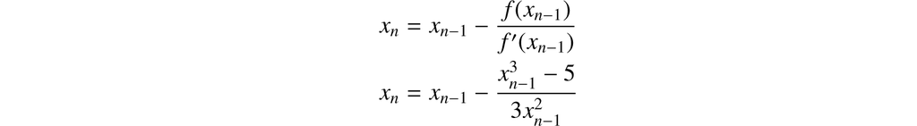

或者or

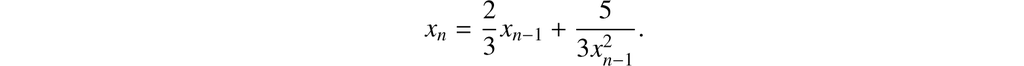

让Let

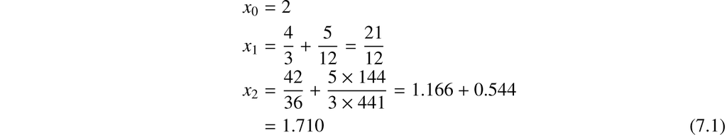

这就是精确到四位有效数字的 5 的立方根。一般而言，*θ* 的 *r* 次根可通过迭代下列表达式得到which is the cube root of 5 to four significant figures. In general the *r*<sup>th</sup> root of *θ* is given by the iteration of the expression

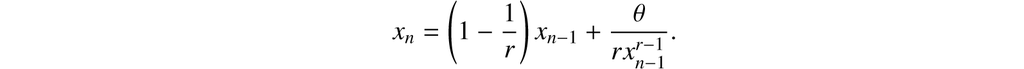

最后，如果*r*不是整数，则可以求助于稍后描述的机械对数表。……Finally, if *r* is not an integer, recourse may be had to the mechanical table of logarithms later to be described. …

16. 经验数据的数值积分可以用辛普森、韦德尔、高斯等人的公式进行。所有这些公式都涉及将 *y* 的连续各值乘以指定的数值系数后求和。因此，所需的唯一新机械部件，就是一种以机械方式输入一串数的装置。实现这一点的方法将在后面讨论。16. The numerical integration of empirical data may be carried out by the rules of Simpson, Weddle, Gauss, and others. All these rules involve sums of successive values of *y* multiplied by specified numerical coefficients. Hence the only new mechanical component involved is a means of mechanically introducing a list of numbers. Means of accomplishing this will be discussed later.

17. 经验数据的数值微分最好通过差分公式来完成。大多数实验观察结果的准确性很高，通过将观察结果足够靠近地进行观察，可以忽略第五个差异。那么，如果可以忽略第五个以上的所有差异，则可以通过诸如巴贝奇最初设计的第五个差异引擎来执行数值微分过程。然而，这样的设备可以通过标准加减法机器组装而成，只需进行一些更改。该微分装置也适用于许多其他问题。事实上，已经讨论的大多数问题在某些情况下都可以通过应用差分公式来解决。17. Numerical differentiation of empirical data is best accomplished by means of a difference formula. Most experimental observations are of such an accuracy that fifth differences may be neglected by taking observations sufficiently close together. If, then, all differences above the fifth may be neglected, the process of numerical differentiation may be carried out by a fifth difference engine such as originally designed by Babbage. Such a device can, however, be assembled from standard addition-subtraction machines with but a few changes. The differentiating apparatus would also be applicable to many other problems. In fact, most of the problems already discussed may under certain circumstances be solved by application of difference formulae.

## **7.5 机械注意事项****7.5 Mechanical Considerations**

上一节表明，即使是复杂的数学运算也可以简化为涉及算术基本规则的重复过程。目前国际商业机器公司的计算机能够执行以下操作：In the last section it was shown that even complicated mathematical operations may be reduced to a repetitive process involving the fundamental rules of arithmetic. At present the calculating machines of the International Business Machines Company are capable of carrying out such operations as:

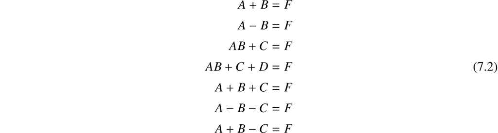

在这些方程中，*A*、*B*、*C*、*D* 是穿孔卡片上的数值表，而结果 *F* 也通过穿孔卡片得到。随后，可以把 *F* 卡片送入另一台机器加以打印，或者在另一项计算中用作 *A*、*B*、… 卡片。In these equations *A*, *B*, *C*, *D* are tabulations of numbers on punched cards, and *F*, the result, is also obtained through punched cards. The *F* cards may then be put through another machine and printed or utilized as *A*, *B*, …, cards in another computation.

将给定机器从任何操作（7.2）更改为任何其他操作是通过插板上的电线来完成的。在熟练的操作员手中，这种改变可以在几分钟内完成。Changing a given machine from any of the operations (7.2) to any other is accomplished by means of electrical wiring on a plug board. In the hands of a skilled operator such changes can be made in a few minutes.

这里不再进一步描述IBM机器的机制。只要说上一节中描述的所有操作都可以通过这些现有的机器来完成，只要配备适当的控制装置并组装足够的数量即可。因此，适用于数学运算的自动计算机的整个设计问题被简化为合适的控制设计问题，甚至对于简单的算术运算，该问题也已得到解决。No further effort will be made here to describe the mechanism of the IBM machines. Suffice it to say that all the operations described in the last section can be accomplished by these existing machines when equipped with suitable controls, and assembled in sufficient number. The whole problem of design of an automatic calculating machine suitable for mathematical operations is thus reduced to a problem of suitable control design, and even this problem has been solved for simple arithmetical operations.

专用控制装置的主要特点是机器切换和用连续穿孔带替换穿孔卡。为了使切换顺序能够快速地改变为任何可能的顺序，切换机构本身应当利用纸带控制，其中数学公式可以由适当设置的穿孔来表示。The main features of the specialized controls are machine switching and replacement of the punched cards by continuous perforated tapes. In order that the switching sequence can be changed quickly to any possible sequence, the switching mechanism should itself utilize a paper tape control in which mathematical formulae may be represented by suitable disposed perforations.

## **7.6 装置的当前构想****7.6 Present Conceptions of the Apparatus**

目前，自动计算器被想象为一个交换机，其上安装有各种计算机设备。配电盘的每个面板都进行一定的数学运算。At present the automatic calculator is visualized as a switchboard on which are mounted various pieces of calculating machine apparatus. Each panel of the switchboard is given over to definite mathematical operations.

以下是所需设备的粗略轮廓：The following is a rough outline of the apparatus required:

1. IBM 机器使用两种电势：用于电机操作的 120 伏交流电，以及用于继电器操作的 32 伏直流电等。必须提供主电源面板，包括对 110 伏交流电/32 伏交流电的控制。直流电动发电机和所有电路的足够保险丝保护。 1. IBM machines utilize two electric potentials: 120 volts ac for motor operation, and 32 volts dc for relay operation, etc. A main power supply panel would have to be provided including control for a 110-volt-ac/32-volt-dc motor generator and adequate fuse protection for all circuits.

2. 主控制面板：这一控制装置的用途，是安排数字在各机器之间的流向并启动运算。所涉及的过程是：(a) 将位置 (*x*) 的数传送到位置 (*y*)；(b) 启动位置 (*y*) 所负责的运算。主控制本身必须受联锁约束，以防止在数值尚未确定时就试图将它取走，或在位置 (*y*) 的前一次运算尚未结束时就开始第二次运算。 2. Master control panel: The purpose of this control is to route the flow of numbers through the machines and to start operation. The processes involved are: (a) Deliver the number in position (*x*) to position (*y*); and (b) start the operation for which position (*y*) is intended. The master control must itself be subject to interlocking to prevent the attempt to remove a number before its value is determined, or to begin a second operation in position (*y*) before a previous operation is finished.

需要有四个这样的主控制器，每个主控制器都能够控制整个机器或其任何部件。因此，对于复杂的问题，可以将所有资源集中在一起；对于较简单的问题，需要较少的资源，并且可以同时处理多个问题。It would be desirable to have four such master controls, each capable of controlling the entire machine or any of its parts. Thus, for complicated problems the entire resources could be thrown together; for simpler problems fewer resources are required and several problems could be in progress at the same time.

3. 任何计算中自变量的进度均等步前进，但可根据增量变化进行手动调整。获得此类算术序列的最简单方法是将第一个值*x*<sub>0</sub>Δ*x*一起提供给加法机。然后连续添加Δ*x*将得到所需的序列。 3. The progress of the independent variable in any calculation would go forward by equal steps subject to manual readjustment for change in the increment. The easiest way to obtain such an arithmetical sequence is to supply a first value, *x*<sub>0</sub>, to an adding machine, together with an increment Δ*x*. Then successive additions of Δ*x* will give the sequence desired.

应该有四个这样的自变量装置，以便 (a) 计算涉及四个变量的公式；(b) 独立操作四个主控制器。There should be four such independent variable devices in order to (a) calculate formulae involving four variables; and (b) operate four master controls independently.

4. 某些常数：许多数学公式都涉及某些常数，例如*e*、*π*、 log <sub>10</sub> *e*等。这些常量应永久安装并随时可用。 4. Certain constants: many mathematical formulae involve certain constants such as *e*, *π*, log<sub>10</sub> *e*, and so forth. These constants should be permanently installed and available at all times.

5. 数学公式几乎总是涉及常数。在计算作为自变量函数的公式时，这些常数会被反复使用。因此，机器应为这些常量提供 24 个可调节的数字位置。 5. Mathematical formulae nearly always involve constant quantities. In the computation of a formula as a function of an independent variable these constants are used over and over again. Hence the machine should be supplied with 24 adjustable number positions for these constants.

6. 在无穷级数的计算中，24这个数字可能会大大超过。为了解决这种情况，应该可以通过穿孔带引入特定值，通过将带向前移动一个位置来提供连续值。应提供两个这样的设备。 6. In the evaluation of infinite series the number 24 might be greatly exceeded. To take care of this case it should be possible to introduce specific values by means of a perforated tape, the successive values being supplied by moving the tape ahead one position. Two such devices should be supplied.

7. 对于非重复性操作的经验数据的引入可以通过标准穿孔卡杂志进给来最好地完成。应提供一台这样的设备。 7. The introduction of empirical data for nonrepetitive operations can be accomplished best by standard punched-card magazine feed. One such device should be supplied.

8. 在涉及圆括号和方括号的计算的各个阶段，可能有必要在计算其他部分之前保留结果的一部分。如果结果保存在计算单元中，则这些元素不可用于执行后续步骤。因此，有必要将数字从计算单元中移除并暂时存储在存储位置中。应该有十二个这样的职位。 8. At various stages of a computation involving parentheses and brackets it may be necessary to hold a part of the result pending the computation of some other part. If results are held in the calculating units, these elements are not available for carrying out succeeding steps. Therefore it is necessary that numbers may be removed from the calculating units and temporarily stored in storage positions. Twelve such positions should be available.

9. 算术的基本运算可以在三种机器上进行：加法和减法、乘法和除法。除了与超越函数直接相关的单元之外，还应提供每个单元的四个单元。 9. The fundamental operations of arithmetic may be carried on three machines: addition and subtraction, multiplication, and division. Four units of each should be supplied in addition to those directly associated with the transcendental functions.

10. 永久安装的数学函数应包括：对数、反对数、正弦、余弦、反正弦和反正切。10. The permanently installed mathematical functions should include: logarithms, antilogarithms, sines, cosines, inverse sines, and inverse tangents.

11. 两个单元，用于 MacLauren 系列根据需要扩展其他功能。11. Two units for MacLauren series expansion of other functions as needed.

12. 为了对经验数据进行微分和积分过程，应提供足够的加法和减法累加器来计算五次差值。12. In order to carry out the process of differentiation and integration on empirical data, adding and subtracting accumulators should be provided sufficient to compute out to fifth differences.

13. 所有结果均应打印、随意打孔在纸带上或卡片上。最终结果将被打印。中间结果将被打孔，为进一步的计算做准备。13. All results should be printed, punched in paper tapes, or in cards, at will. Final results would be printed. Intermediate results would be punched in preparation for further calculations.

据信，刚刚列举的由自动切换控制的装置应该能够解决所遇到的大多数问题。It is believed that the apparatus just enumerated, controlled by automatic switching, should care for most of the problems encountered.

## **7.7 可能的计算速度****7.7 Probable Speed of Computation**

IBM 机器所达到的速度可以从下面的乘法表中了解，其中 2 × 8 指的是 8 位有效数字与 2 位有效数字的乘法，零不计算在内（图 7.1 ）。An idea of the speed attained by the IBM machines can be had from the following tabulation of multiplication in which 2 × 8 refers to the multiplication of an 8 significant figure number by a 2 significant figure number, zeros not counted (Figure 7.1).

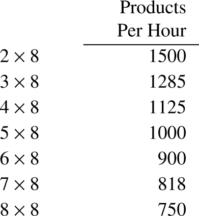

图 7.1： 预期的乘法速度Figure 7.1: Expected multiplication speed

## **7.8 建议精度****7.8 Suggested Accuracy**

上述示例中使用了十位有效数字。如果所有数字都达到这一精度，则需要在大多数计算组件上提供 23 个数字位置，其中小数点左边 10 个，右边 12 个，以及一个用于加减的位置。右边的十二个中，有两个将作为守卫位置并被丢弃。Ten significant figures have been used in the above examples. If all numbers were to be given to this accuracy it would be necessary to provide 23 number positions on most of the computing components, 10 to the left of the decimal point, 12 to the right, and one for plus and minus. Of the twelve to the right, two would be guard places and thrown away.

## **7.9 易于发布结果****7.9 Ease of Publication of Results**

正如已经提到的，所有计算结果都将以表格形式打印。通过光刻，这些结果可以直接打印，无需排版或校对。这不仅表明数学函数的出版大大节省了，而且还消除了许多错误的可能性。As already mentioned, all computed results would be printed in tabular form. By means of photolithography these results could be printed directly without type setting or proof reading. Not only does this indicate a great saving in the publishing of mathematical functions, but it also eliminates many possibilities of error.

1. 转载自艾肯等人。（1964），经哈佛大学档案馆许可。Reprinted from Aiken et al. (1964), with permission from the Harvard University Archives.

# **8**

# 继电器与开关电路的符号分析（1938）**A Symbolic Analysis of Relay and Switching Circuits (1938)**

## **克劳德·香农****Claude Shannon**

由开关连接的电线要么导电，要么不导电，具体取决于互连模式和开关的设置。早在 1886 年，哲学家查尔斯·桑德斯·皮尔斯 (Charles Sanders Peirce) 就认识到逻辑连接词与串联和并联电路的关系。但克劳德·香农（Claude Shannon，1916-2001）对布尔思维定律进行了令人震惊的解释。香农在密歇根州北部农村长大，曾修理过电路，并为朋友家安装了铁丝网电报机。到 20 世纪 30 年代，无线电和电话行业蓬勃发展，香农在密歇根大学学习电气工程。他在哲学课上遇到了布尔的著作，作为麻省理工学院的研究生，他在两个二进制值系统之间建立了联系，从而催生了一种管理复杂电路设计问题的极其优雅的方法。Electric wires connected by switches either conduct electricity or don’t, depending on the interconnection pattern and the settings of the switches. As early as 1886, the philosopher Charles Sanders Peirce had recognized the relation of logical connectives to series and parallel electric circuits. But it was Claude Shannon (1916–2001) who exploited the electric interpretation of Boole’s laws of thought. Shannon had tinkered with electric circuits while growing up in rural northern Michigan and had built a barbed wire telegraph to a friend’s house. By the 1930s the radio and telephone industries were flourishing, and Shannon studied electrical engineering at the University of Michigan. He encountered Boole’s writings in a philosophy class, and as an MIT graduate student he made the connection between the two binary-valued systems—thus giving birth to a profoundly elegant methodology for managing complex circuit design problems.

今天，我们理所当然地认为电路的预期行为可以用数学方法描述，并且可以使用数学规则操纵所得公式，然后将其“编译”到硬件中。香农在他的硕士论文中是第一个这样做的。本文摘录自一篇论文，该论文成为该论文的一部分；从那时起，它对电路设计产生了巨大的影响。它涉及电路的分析和综合，其中一些电路比我们简短选择的简单电路复杂得多。在我们没有包含的一段文章中，香农的论文继续证明了某些布尔函数在这些电路形式的特定限制下的电路大小的上限和下限，从而预示了电路复杂性的丰富而重要的领域。Today we take it for granted that the intended behavior of a circuit can be described mathematically, and that the resulting formulas can be manipulated using mathematical rules and then “compiled” into hardware. Shannon, in his Master’s thesis, was the first to do it. This selection is an excerpt from a paper that became part of that thesis; it has had immense impact on circuit design ever since. It deals with the analysis and synthesis of electrical circuits, some far more complicated than the simple ones in our brief selection. In a passage we do not include, Shannon’s paper goes on to prove upper and lower bounds on the size of circuits for certain boolean functions under particular restrictions about the form of those circuits, thus foreshadowing the rich and important field of circuit complexity.

## **8.1 简介****8.1 Introduction**

在复杂电气系统的控制和保护电路中，经常需要对继电器触点和开关进行复杂的互连。这些电路的示例出现在自动电话交换机、工业电机控制设备以及几乎所有设计用于自动执行复杂操作的电路中。在本文中，将对此类网络的某些特性进行数学分析。将特别关注网络综合问题。给定某些特性，需要找到一种结合这些特性的电路。此类问题的解不唯一且将研究寻找需要最少数量的继电器触点和开关刀片的特定电路的方法。还将描述用于寻找在所有操作特性方面与给定电路等效的任意数量的电路的方法。将证明阻抗网络上的几个著名定理在继电器电路中具有大致相似的定理。其中值得注意的是 delta-wye 和星形网格变换以及对偶定理。IN the control and protective circuits of complex electrical systems it is frequently necessary to make intricate interconnections of relay contacts and switches. Examples of these circuits occur in automatic telephone exchanges, industrial motor-control equipment, and in almost any circuits designed to perform complex operations automatically. In this paper a mathematical analysis of certain of the properties of such networks will be made. Particular attention will be given to the problem of network synthesis. Given certain characteristics, it is required to find a circuit incorporating these characteristics. The solution of this type of problem is not unique and methods of finding those particular circuits requiring the least number of relay contacts and switch blades will be studied. Methods will also be described for finding any number of circuits equivalent to a given circuit in all operating characteristics. It will be shown that several of the well-known theorems on impedance networks have roughly analogous theorems in relay circuits. Notable among these are the delta-wye and star-mesh transformations, and the duality theorem.

解决这些问题的方法可以简单描述如下：任何电路都由一组方程表示，方程的项对应于电路中的各种继电器和开关。微积分是为了通过简单的数学过程来处理这些方程而开发的，其中大多数与普通代数算法类似。这种演算被证明与逻辑符号研究中使用的命题演算完全相似。对于综合问题，首先将所需的特性写成方程组，然后将方程处理成代表最简单电路的形式。然后可以立即从方程中得出电路。通过这种方法，总是可以找到仅包含串联和并联连接的最简单电路，并且在某些情况下找到包含任何类型连接的最简单电路。The method of attack on these problems may be described briefly as follows: any circuit is represented by a set of equations, the terms of the equations corresponding to the various relays and switches in the circuit. A calculus is developed for manipulating these equations by simple mathematical processes, most of which are similar to ordinary algebraic algorithms. This calculus is shown to be exactly analogous to the calculus of propositions used in the symbolic study of logic. For the synthesis problem the desired characteristics are first written as a system of equations, and the equations are then manipulated into the form representing the simplest circuit. The circuit may then be immediately drawn from the equations. By this method it is always possible to find the simplest circuit containing only series and parallel connections, and in some cases the simplest circuit containing any type of connection.

我们的符号主要取自符号逻辑。在许多常用的系统中，我们选择了一个看起来最简单、对我们的解释最具启发性的系统。我们的一些术语，例如节点、网状、三角形、星形等，是从普通网络理论中借用的，用于表示开关电路中的简单概念。Our notation is taken chiefly from symbolic logic. Of the many systems in common use we have chosen the one which seems simplest and most suggestive for our interpretation. Some or our phraseology, such as node, mesh, delta, wye, etc., is borrowed from ordinary network theory for simple concepts in switching circuits.

## **8.2 串并联二端电路：定义和假设****8.2 Series-Parallel Two-Terminal Circuits: Definitions and Postulates**

我们只讨论仅包含继电器触点和开关的电路，因此，在任意给定时刻，任意两个端子之间的电路必定不是断开（阻抗无穷大），就是闭合（阻抗为零）。给端子 *a* 和 *b* 配上一个符号 *X*<sub>*ab*</sub>，或简写为 *X*。这个随时间变化的变量，称为两端电路 *a* − *b* 的阻碍值。用符号 0（零）表示闭合电路的阻碍值，用符号 1（一）表示断开电路的阻碍值。因此，当电路 *a* − *b* 断开时，*X*<sub>*ab*</sub> = 1；闭合时，*X*<sub>*ab*</sub> = 0。如果每当电路 *a* − *b* 断开，电路 *c* − *d* 也断开，而每当 *a* − *b* 闭合，*c* − *d* 也闭合，就称两个阻碍值 *X*<sub>*ab*</sub> 和 *X*<sub>*cd*</sub> 相等。现在定义符号 +（加号），表示将阻碍值相加的两个两端电路串联。因此，当 *b* 与 *c* 连接起来时，*X*<sub>*ab*</sub> + *X*<sub>*cd*</sub> 就是电路 *a* − *d* 的阻碍值。同样，将两个阻碍值的乘积 *X*<sub>*ab*</sub> · *X*<sub>*cd*</sub>，或简写 *X*<sub>*ab*</sub>*X*<sub>*cd*</sub>，定义为电路 *a* − *b* 与 *c* − *d* 并联所得电路的阻碍值。电路中的继电器触点或开关，用图 8.1 中的符号表示，其中的字母就是相应的阻碍值函数。图 8.2 展示了加号的解释，图 8.3 展示了乘号的解释。这样选择符号，使得阻碍值的运算与普通的数值代数十分相似。We shall limit our treatment of circuits containing only relay contacts and switches, and therefore at any given time the circuit between any two terminals must be either open (infinite impedance) or closed (zero impedance). Let us associate a symbol *X*<sub>*ab*</sub> or more simply *X*, with the terminals *a* and *b*. This variable, a function of time, will be called the hindrance of the two-terminal circuit *a* − *b*. The symbol 0 (zero) will be used to represent the hindrance of a closed circuit, and the symbol 1 (unity) to represent the hindrance of an open circuit. Thus when the circuit *a* − *b* is open *X*<sub>*ab*</sub> = 1 and when closed *X*<sub>*ab*</sub> = 0. Two hindrances *X*<sub>*ab*</sub> and *X*<sub>*cd*</sub> will be said to be equal if whenever the circuit *a* − *b* is open, the circuit *c* − *d* is open, and whenever *a* − *b* is closed, *c* − *d* is closed. Now let the symbol + (plus) be defined to mean the series connection of the two-terminal circuits whose hindrances are added together. Thus *X*<sub>*ab*</sub> + *X*<sub>*cd*</sub> is the hindrance of the circuit *a* − *d* when *b* and *c* are connected together. Similarly the product of two hindrances *X*<sub>*ab*</sub> · *X*<sub>*cd*</sub>, or more briefly *X*<sub>*ab*</sub>*X*<sub>*cd*</sub> will be defined to mean the hindrance of the circuit formed by connecting the circuits *a* − *b* and *c* − *d* in parallel. A relay contact or switch will be represented in a circuit by the symbol in Figure 8.1, the letter being the corresponding hindrance function. Figure 8.2 shows the interpretation of the plus sign and Figure 8.3 the multiplication sign. This choice of symbols makes the manipulation of hindrances very similar to ordinary numerical algebra.

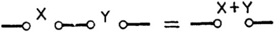

图 8.2： 加法的解释Figure 8.2: Interpretation of addition

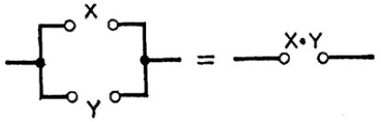

图 8.3： 乘法的解释Figure 8.3: Interpretation of multiplication

显然，根据上述定义，以下假设成立：It is evident that with the above definitions, the following postulates will hold:

|  |  |  | **假设** **Postulates** |
| --- | --- | --- | --- |
| 1. | *a.* | 0 · 0 = 0 | 与闭合电路并联的闭合电路是闭合电路。A closed circuit in parallel with a closed circuit is a closed circuit. |
|  | *b*. | 1 + 1 = 1 | 开路与开路串联就是开路。An open circuit in series with an open circuit is an open circuit. |
| 2. | *a.* | 1 + 0 = 0 + 1 = 1 | 开路与闭路串联的任何顺序（即，无论开路在闭路的右侧还是左侧）都是开路。An open circuit in series with a closed circuit in either order (i.e., whether the open circuit is to the right or left of the closed circuit) is an open circuit. |
|  | *b.* | 0·1 = 1·0 = 0 | 闭路与开路以任一顺序并联都是闭路。A closed circuit in parallel with an open circuit in either order is a closed circuit. |
| 3. | *a.* | 0 + 0 = 0 | 闭合电路与闭合电路串联就是闭合电路。A closed circuit in series with a closed circuit is a closed circuit. |
|  | *b*. | 1 · 1 = 1 | 与开路并联的开路是开路。An open circuit in parallel with an open circuit is an open circuit. |
| 4. |  |  | 在任何给定时间，*X* = 0 或*X* = 1。At any given time either *X* = 0 or *X* = 1. |

这些足以发展将用于仅包含串联和并联连接的电路的所有定理。这些公设成对排列，以强调加法和乘法运算与数量零和一之间的对偶关系。因此，如果在任何*a*假设中，将 0 替换为 1，将乘法替换为加法，反之亦然，则将得到相应的*b*假设。这个事实非常重要。它为每个定理提供了一个对偶定理，只需证明一个定理即可建立两个定理。这些假设中唯一与普通代数不同的是 1 *b*。然而，这使得这些符号的操作变得非常简单。These are sufficient to develop all the theorems which will be used in connection with circuits containing only series and parallel connections. The postulates are arranged in pairs to emphasize a duality relationship between the operations of addition and multiplication and the quantities zero and one. Thus if in any of the *a* postulates the zero’s are replaced by one’s and the multiplications by additions and vice versa, the corresponding *b* postulate will result. This fact is of great importance. It gives each theorem a dual theorem, it being necessary to prove only one to establish both. The only one of these postulates which differs from ordinary algebra is 1*b*. However, this enables great simplifications in the manipulation of these symbols.

### **8.2.1 定理** 在本节中，将给出一些控制障碍组合的定理。由于任何定理都可以通过非常简单的过程来证明，因此除了说明性示例之外将不给出证明。证明方法是“完美归纳法”，即对所有可能的情况验证定理。由于根据公设 4，每个变量都限制为值 0 和 1，因此这是一个简单的问题。有些定理可以通过引用以前的定理来更优雅地证明，但是完美归纳法是如此普遍，以至于它可能是首选。**8.2.1 Theorems** In this section a number of theorems governing the combination of hindrances will be given. Inasmuch as any of the theorems may be proved by a very simple process, the proofs will not be given except for an illustrative example. The method of proof is that of “perfect induction,” i.e., the verification of the theorem for all possible cases. Since by Postulate 4 each variable is limited to the values 0 and 1, this is a simple matter. Some of the theorems may be proved more elegantly by recourse to previous theorems, but the method of perfect induction is so universal that it is probably to be preferred.

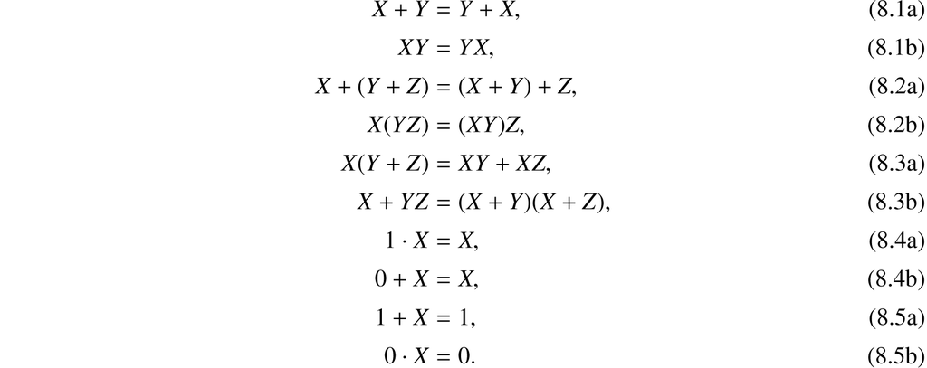

例如，要证明定理 8.4a，请注意*X*为 0 或 1。如果为 0，则该定理由公设 2b 得出：如果为 1，则由公设 3b 得出。定理 8.4b 现在遵循对偶原理，用 0 代替 1，用 + 代替·。For example, to prove Theorem 8.4a, note that *X* is either 0 or 1. If it is 0, the theorem follows from Postulate 2b: if 1, it follows from Postulate 3b. Theorem 8.4b now follows by the duality principle, replacing the 1 by 0 and the · by +.

由于结合律（8.2a 和 8.2b），在几个项的和或乘积中可以省略括号而不会产生歧义。Σ和ΣΠ使用方式与普通代数相同。Due to the associative laws (8.2a and 8.2b) parentheses may be omitted in a sum or product of several terms without ambiguity. The Σ and Π symbols will be used as in ordinary algebra.

分配律（8.3a）使得“相乘”乘积和因式求和成为可能。然而，该定理 (8.3b) 的对偶在数值代数中并不成立。The distributive law (8.3a) makes it possible to “multiply out” products and to factor sums. The dual of this theorem, (8.3b), however, is not true in numerical algebra.

现在定义一种称为否定的新运算。阻断量 *X* 的否定记为 *X*′，其定义是一个变量：当 *X* 等于 0 时它等于 1，当 *X* 等于 1 时它等于 0。如果 *X* 是某继电器常开触点的阻断量，那么 *X*′ 就是同一继电器常闭触点的阻断量。阻断量的否定这一定义给出以下定理：We shall now define a new operation to be called negation. The negative of a hindrance *X* will be written *X*′ and is defined to be a variable which is equal to 1 when *X* equals 0 and equal to 0 when *X* equals 1. If *X* is the hindrance of the make contacts of a relay, then *X*′ is the hindrance of the break contacts of the same relay. The definition of the negative of a hindrance gives the following theorems:

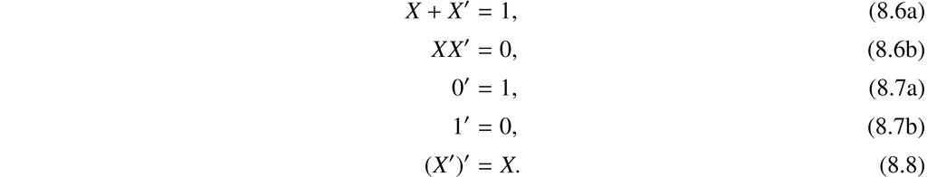

### **8.2.2 与命题演算的类比** 我们现在可以证明这种演算与命题演算的某些基本部分的等价性。逻辑代数由乔治·布尔创立，是一种研究逻辑关系的符号方法。布尔代数的符号允许两种逻辑解释。如果按照类来解释，变量不限于两个可能值 0 和 1。这种解释称为类代数。然而，如果这些术语被用来代表命题，我们有命题演算，其中变量被限制为值 0 和 1，就像上面的阻碍函数一样。通常，这两个科目是从同一组假设同时发展起来的，除了在命题微积分的情况下添加了相当于上述假设 4 的假设。EV Huntington 给出了以下一组符号逻辑假设：**8.2.2 Analogue with the calculus of propositions** We are now in a position to demonstrate the equivalence of this calculus with certain elementary parts of the calculus of propositions. The algebra of logic, originated by George Boole, is a symbolic method of investigating logical relationships. The symbols of boolean algebra admit of two logical interpretations. If interpreted in terms of classes, the variables are not limited to the two possible values 0 and 1. This interpretation is known as the algebra of classes. If, however, the terms are taken to represent propositions, we have the calculus of propositions in which variables are limited to the values 0 and 1, as are the hindrance functions above. Usually the two subjects are developed simultaneously from the same set of postulates, except for the addition in the case of the calculus of propositions of a postulate equivalent to Postulate 4 above. E. V. Huntington gives the following set of postulates for symbolic logic:

1. 类 *K* 至少包含两个不同的元素。1. The class *K* contains at least two distinct elements.

2. 如果 *a* 和 *b* 属于类 *K*，那么 *a* + *b* 也属于类 *K*。2. If *a* and *b* are in the class *K* then *a* + *b* is in the class *K*.

3. *a* + *b* = *b* + *a*.

4. (*a* + *b*) + *c* = *a* + (*b* + *c*).

5. *a* + *a* = *a*.

6. *ab* + *ab* ' = *a*其中*ab*定义为 ( *a* ' + *b* ')'。6. *ab* + *ab*′ = *a* where *ab* is defined as (*a*′ + *b*′)′.

如果我们让类*K*是由两个元素 0 和 1 组成的类，那么这些假设就来自第一部分中给出的假设。给出的假设 1、2 和 3 也可以从亨廷顿假设中推导出来。添加 4 并将我们的讨论限制在命题演算上，显然，开关电路演算与符号逻辑的这个分支之间存在完美的类比。符号的两种解释如图 8.4所示。If we let the class *K* be the class consisting of the two elements 0 and 1, then these postulates follow from those given in the first section. Also Postulates 1, 2, and 3 given there can be deduced from Huntington’s postulates. Adding 4 and restricting our discussion to the calculus of propositions, it is evident that a perfect analogy exists between the calculus for switching circuits and this branch of symbolic logic. The two interpretations of the symbols are shown in Figure 8.4.

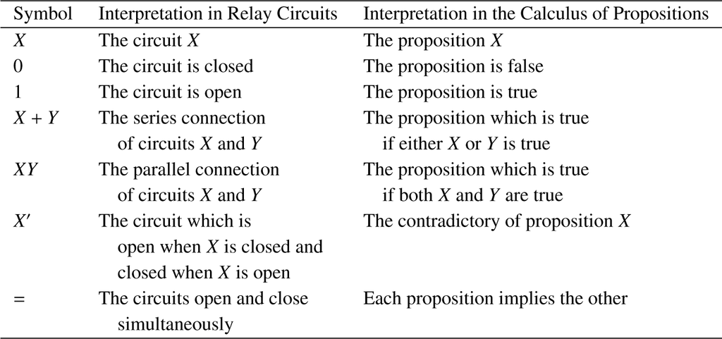

图 8.4： 命题演算和符号中继分析之间的类比Figure 8.4: Analogue between the calculus of propositions and the symbolic relay analysis

由于这种类比，如果用中继电路来解释，命题演算的任何定理也是真定理。本节中的其余定理直接取自该领域。Due to this analogy any theorem of the calculus of propositions is also a true theorem if interpreted in terms of relay circuits. The remaining theorems in this section are taken directly from this field.

德摩根定理：De Morgan’s theorem:

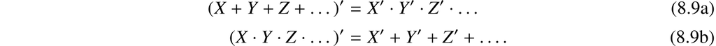

这一定理用各加数或因子的否定，表示和或积的否定。对于两项的情形，代入所有可能值即可容易地验证它，然后可以通过数学归纳法将其推广到任意数目 *n* 个变量。This theorem gives the negative of a sum or product in terms of the negatives of the summands or factors. It may be easily verified for two terms by substituting all possible values and then extended to any number *n* of variables by mathematical induction.

某些变量*X*<sub>1</sub> , *X*<sub>2</sub> , … , *X*<sub>*n*</sub>的函数是由变量通过加法、乘法和求反运算形成的任何表达式。符号*f* ( *X*<sub>1</sub>*, X* <sub>2</sub>*, … , X* <sub>*n*</sub> ) 将用于表示函数。因此我们可能有*f* ( *X, Y, Z* ) = *XY* + *X* ′( *Y* ′ + *Z* ′)。在无穷小微积分中，表明任何函数（只要它是连续的并且所有导数都是连续的）都可以展开为泰勒级数。在命题演算中可能存在某种类似的扩展。要开发函数的级数展开式，首先请注意以下等式： [编辑： Cf. 布尔，第 44 页]A function of certain variables *X*<sub>1</sub>, *X*<sub>2</sub>, …, *X*<sub>*n*</sub> is any expression formed from the variables with the operations of addition, multiplication, and negation. The notation *f*(*X*<sub>1</sub>*, X*<sub>2</sub>*, …, X*<sub>*n*</sub>) will be used to represent a function. Thus we might have *f*(*X, Y, Z*) = *XY* + *X*′(*Y* ′ + *Z*′). In infinitesimal calculus it is shown that any function (providing it is continuous and all derivatives are continuous) may be expanded in a Taylor series. A somewhat similar expansion is possible in the calculus of propositions. To develop the series expansion of functions first note the following equations: [EDITOR: Cf. Boole, page 44]

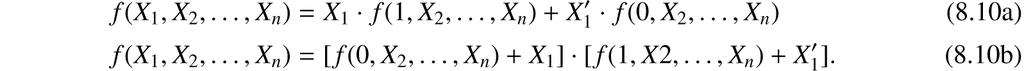

令 *X*<sub>1</sub> 等于 0 或 1，这些式子就化为恒等式。在这些方程中，我们称函数 *f* 按 *X*<sub>1</sub> 展开。在（8.10a）中，*X*<sub>1</sub> 与 的系数是（*n* − 1）个变量 *X*<sub>2</sub>*, …, X*<sub>*n*</sub> 的函数，因此可以用同样的方法按这些变量中的任意一个展开。（8.10b）中的各加项也可以这样展开。按 *X*<sub>2</sub> 展开，得到：These reduce to identities if we let *X*<sub>1</sub> equal either 0 or 1. In these equations the function *f* is said to be expanded about *X*<sub>1</sub>. The coefficients of *X*<sub>1</sub> and in (8.10a) are functions of the (*n* − 1) variables *X*<sub>2</sub>*, …, X*<sub>*n*</sub> and may thus be expanded about any of these variables in the same manner. The additive terms in (8.10b) also may be expanded in this manner. Expanding about *X*<sub>2</sub> we have:

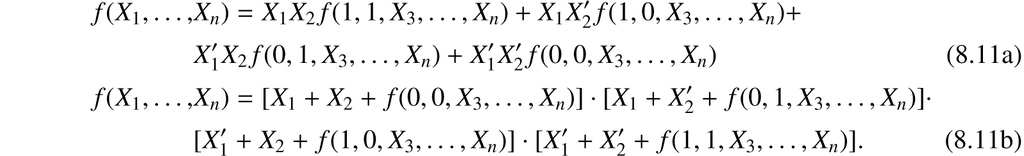

继续这个过程*n*次，我们将得到完整的级数展开式，其形式为：Continuing this process *n* times we will arrive at the complete series expansion having the form:

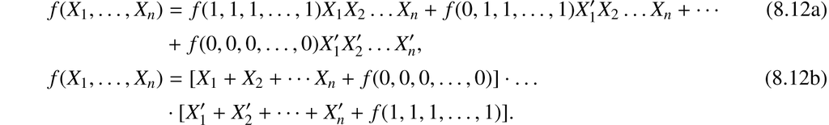

根据（8.12a），*f* 等于如下各乘积之和：以所有可能方式在 *X*<sub>1</sub>、*X*<sub>2</sub>、…、*X*<sub>*n*</sub> 各项上配置撇号，构成各乘积，并给每个乘积赋予一个系数，其值等于该乘积为 1 时函数的值。（8.12b）的情形类似。By (8.12a), *f* is equal to the sum of the products formed by permuting primes on the terms of *X*<sub>1</sub>, *X*<sub>2</sub>, …, *X*<sub>*n*</sub> in all possible ways and giving each product a coefficient equal to the value of the function when that product is 1. Similarly for (8.12b).

作为级数展开式的应用，应该注意的是，如果我们希望找到代表任何给定函数的电路，我们总是可以通过（ 8.10a）或（8.10b ）来展开函数，使得任何给定变量出现在最多两次，一次作为接通接触，一次作为断开接触。如图 8.5所示。类似地，根据（8.11a）和（8.11b），任何其他变量需要出现不超过四次（两个接通和两个断开触点），等等。As an application of the series expansion it should be noted that if we wish to find a circuit representing any given function we can always expand the function by either (8.10a) or (8.10b) in such a way that any given variable appears at most twice, once as a make contact and once as a break contact. This is shown in Figure 8.5. Similarly by (8.11a) and (8.11b) any other variable need appear no more than four times (two make and two break contacts), etc.

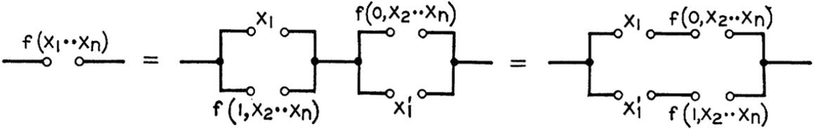

图 8.5： 关于一个变量的展开Figure 8.5: Expansion about one variable

德摩根定理的推广用以下等式象征性地表示：A generalization of De Morgan’s theorem is represented symbolically in the following equation:

[figure not shown]

我们的意思是，任何函数的负数都可以通过将每个变量替换为其负数并交换+和·符号来获得。当然，显式和隐式括号将保留在相同的位置。例如，*X* + *Y* ( *Z* + *WX* ') 的负数将为*X* '[ *Y* ' + *Z* '( *W* ' + *X* )]。By this we mean that the negative of any function may be obtained by replacing each variable by its negative and interchanging the + and · symbols. Explicit and implicit parentheses will, of course, remain in the same places. For example, the negative of *X* + *Y*(*Z* + *WX*′) will be *X*′[*Y*′ + *Z*′(*W*′ + *X*)].

下面给出了一些有助于简化表达式的其他定理：Some other theorems useful in simplifying expressions are given below:

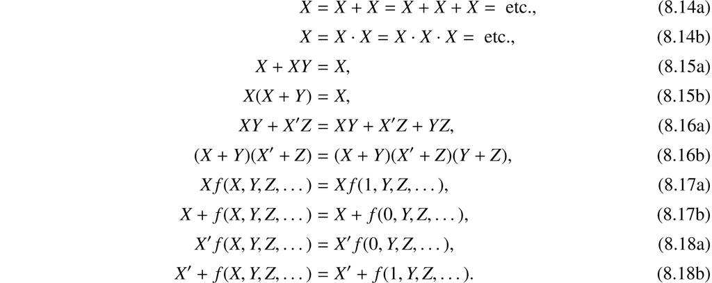

所有这些定理都可以用完美归纳法来证明。All of these theorems may be proved by the method of perfect induction.

任何由加法、乘法和求反运算形成的表达式都明确表示仅包含串联和并联连接的电路。这样的电路称为串并联电路。此类表达式中的每个字母代表一个接通或断开继电器触点，或一个开关刀片和触点。因此，为了找到需要最少触点数的电路，有必要将表达式处理成其中最少触点数的形式：出现字母。上面给出的定理总是足以做到这一点。只需要稍微练习一下这些符号的操作即可。幸运的是，大多数定理与数值代数的定理完全相同——代数的结合律、交换律和分配律在这里成立。作者发现（8.3）、（8.6）、（8.9）、（8.14）、（8.15）、（8.16a）、（8.17）和（8.18）对于简化复杂表达式特别有用。通常，一个函数可以用多种方式编写，每种方式都需要相同的最小数量的元素。在这种情况下，可以从这些电路中或从其他考虑中任意地选择电路。Any expression formed with the operations of addition, multiplication, and negation represents explicitly a circuit containing only series and parallel connections. Such a circuit will be called a series-parallel circuit. Each letter in an expression of this sort represents a make or break relay contact, or a switch blade and contact. To find the circuit requiring the least number of contacts, it is therefore necessary to manipulate the expression into the form in which the least number of letters appear. The theorems given above are always sufficient to do this. A little practice in the manipulation of these symbols is all that is required. Fortunately most of the theorems are exactly the same as those of numerical algebra—the associative, commutative, and distributive laws of algebra hold here. The writer has found (8.3), (8.6), (8.9), (8.14), (8.15), (8.16a), (8.17), and (8.18) to be especially useful in the simplification of complex expressions. Frequently a function may be written in several ways, each requiring the same minimum number of elements. In such a case the choice of circuit may be made arbitrarily from among these, or from other considerations.

作为表达式简化的示例，请考虑图 8.6中所示的电路。该电路的阻碍函数*X*<sub>*ab*</sub>为：As an example of the simplification of expressions consider the circuit shown in Figure 8.6. The hindrance function *X*<sub>*ab*</sub> for this circuit will be:

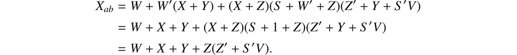

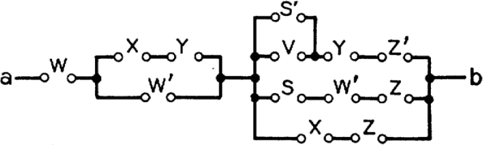

图 8.6： 要简化的电路Figure 8.6: Circuit to be simplified

这些归约是通过（8.17b）首先使用*W*，然后使用*X*和*Y*作为（ 8.17b ）的“ *X* ”来实现的。现在相乘：These reductions were made with (8.17b) using first *W*, then *X* and *Y* as the “*X*” of (8.17b). Now multiplying out:

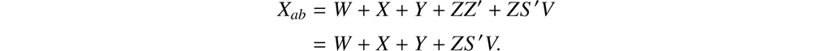

与该表达式对应的电路如图8.7所示。请注意元素数量的大幅减少。……The circuit corresponding to this expression is shown in Figure 8.7. Note the large reduction in the number of elements. …

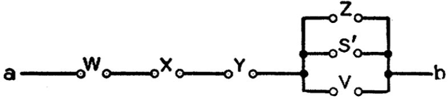

图 8.7： 图 8.6的简化Figure 8.7: Simplification of Figure 8.6

1. 经麻省理工学院许可，转载自 Shannon（1938）。Reprinted from Shannon (1938), with permission from the Massachusetts Institute of Technology.

# **9**

# 神经活动中内在观念的逻辑演算（1943）**A Logical Calculus of the Ideas Immanent in Nervous Activity (1943)**

## **沃伦·麦卡洛克和沃尔特·皮茨****Warren McCulloch and Walter Pitts**

这是一篇奇怪而精彩的论文，技术上错综复杂，预言性傲慢，是湿漉漉的神经科学和严谨的数学抽象的混合体，与以前写的任何文章都不同。它的记法很复杂，其主张也很夸张。它的目标无非就是将人脑的功能简化为数学逻辑，从而解释思想、记忆和心智。尽管它的不谦虚和天真，它是数十年来滋养计算机科学的思想源泉。This is a strange and wonderful paper, technically convoluted and hubristically prophetic, an admixture of wet neuroscience and austere mathematical abstraction unlike anything written before. It is complex in its notation and extravagant in its pretensions. Its goal is nothing less than to reduce the functioning of the human brain to mathematical logic, and thereby to explain thought, memory, and mind. In all its immodesty and naïveté, it is the bubbling source of ideas that have nourished computer science for decades.

作者们设想了一个由两类神经元组成的神经网络。有些神经元不接收其他神经元的输入；它们承载感觉数据，称为“外周传入神经元”。其余神经元则是开关，可以处于两种状态之一：放电或不放电。一个全局时钟使系统同步，每个神经元在时刻 *t* + 1 的状态取决于其各输入在时刻 *t* 的状态。神经元的输入来自外周传入神经元，或来自其他神经元的输出（“传出端”）；输入到达神经元的连接点就是突触。麦卡洛克–皮茨神经元 *i* 具有阈值 *θ*<sub>*i*</sub>；当放电的输入数超过 *θ*<sub>*i*</sub> 时，神经元 *i* 就会放电——但它还有一个抑制性输入，如果该输入被激活，就不会放电。在他们的神经元示意图中（第 86 页的图 9.1），兴奋性输入位于三角形的斜边上，抑制性输入位于左侧顶点，而输出或传出端从右侧的竖边引出。The authors picture a neural network consisting of two kinds of neurons. Some receive inputs from no other neurons; they are the bearers of sensory data and are referred to as “peripheral afferents.” The others are switches, and can be in one of two states, either firing or not. A global clock synchronizes the system, and the state of each neuron at time *t* + 1 depends on the states of its inputs at time *t*. The inputs to a neuron are from peripheral afferents or from the outputs (“efferents”) of other neurons; the junction points, where the inputs arrive at a neuron, are synapses. A McCulloch–Pitts neuron *i* has a threshold *θ*<sub>*i*</sub>; neuron *i* fires if more than *θ*<sub>*i*</sub> of its inputs fire—except that the neuron also has an inhibitory input, and will not fire if the inhibitory input is activated. In their drawings of neurons (Figure 9.1 on page 86), the excitatory inputs are on the slanted sides of the triangular diagram, the inhibitory input is at the point on the left, and the output or efferent comes from the vertical side on the right.

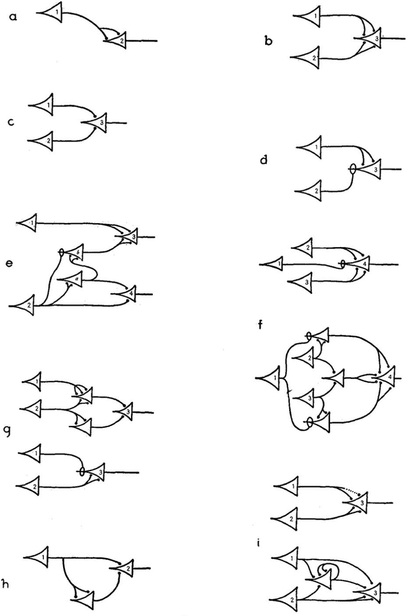

图 9.1：神经元 *c*<sub>*i*</sub> 的细胞体上始终标有数字 *i*，相应的活动则以带下标 *i* 的“*N*”表示，与正文相同。Figure 9.1: The neuron *c*<sub>*i*</sub> is always marked with the numeral *i* upon the body of the cell, and the corresponding action is denoted by “*N*” with *i* as subscript, as in the text.

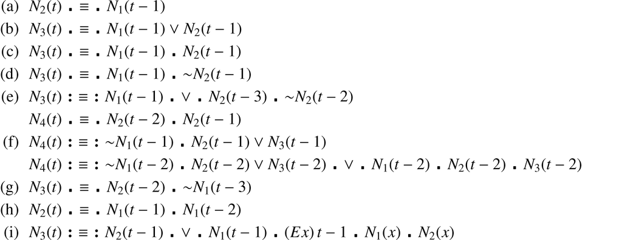

简言之，这篇论文把大脑及其全部功能建模为一个数字系统。图 9.1 中的神经元，是今天所谓阈值逻辑中的逻辑门。作者的目标是确定这样的网络能够执行哪些计算。他们为每个神经元 *i* 配上一个谓词 *N*<sub>*i*</sub>(*t*)：当神经元 *i* 在时刻 *t* 放电时，该谓词为真。了解这些背景后，在开始阅读论文之前，值得先推敲一下图 9.1 中的一些图和公式。（单点和竖排双点是括号的替代记号；它们倾向于把公式分隔开，双点的分隔作用比单点更强。单点也可以表示合取。因此，(e) 部分的第一行对应于 *N*<sub>3</sub>(*t*) *≡* [*N*<sub>1</sub>(*t* − 1) ∨ (*N*<sub>2</sub>(*t* − 3) ∧ *∼ N*<sub>2</sub>(*t* − 2))]，其中 *∼* 表示“非”，∨ 表示“或”，∧ 表示“与”。）In short, this paper models the brain and all its functions as a digital system. The neurons of Figure 9.1 are gates in what would today be called a threshold logic. The authors’ goal is to determine what kinds of computations such a network can carry out. They do this by associating with each neuron *i* a predicate *N*<sub>*i*</sub>(*t*) that is true if neuron *i* is firing at time *t*. With this background, it is worth working through some of the diagrams and formulas of Figure 9.1 before beginning to read the paper. (The single dots and vertical double dots are an alternative to parentheses; they tend to push formulas apart, two dots more strongly than one. A single dot can also denote conjunction. So the first line of part (e) corresponds to *N*<sub>3</sub>(*t*) *≡* [*N*<sub>1</sub>(*t* − 1) ∨ (*N*<sub>2</sub>(*t* − 3) ∧ *∼ N*<sub>2</sub>(*t* − 2))], where *∼* stands for “not,” ∨ for “or,” and ∧ for “and.”)

论文的具体技术成就是证明神经网络可计算的谓词集合与某种极富表现力的逻辑可表达的谓词集合完全相同。特别关注具有反馈的网络，其中一个神经元的输出在影响一系列其他神经元后，作为原始神经元的输入循环返回。作者认为，这种活动周期可以解释记忆。因此，他们推断，鉴于对网络的完整描述，“对于预测而言，历史记录从来都不是必要的”（第 88 页）。大脑是我们现在所说的确定性有限状态机：它的未来完全由它当前的状态和未来的输入决定。The specific technical accomplishment of the paper is to prove that the set of predicates computable by neural nets is exactly the same as the set of predicates expressible in a certain very expressive logic. Particular attention is given to networks with feedback, in which the output of one neuron, after affecting a series of other neurons, loops back as an input to the original neuron. Such cycles of activity, the authors suggest, explain memory. So given a complete account of the network, they reasoned, “for prognosis, history is never necessary” (page 88). The brain is what we would now call a deterministic finite-state machine: its future is completely determined by its present state and its inputs going forward.

这篇论文的公式充满了错误和不恰当——“ *S* ”命名了后继函数，但粗体“ *S* ”是一个不相关的变量，代表“句子”。Stephen Cole Kleene 简化了该模型，并于 1951 年将其用作有限自动机和正则表达式形式化的基础。觉得《逻辑微积分》很难读的读者应该会对克莱恩的看法感到放心：“本文部分是对麦卡洛克-皮茨结果的阐述；但我们发现他们论文中涉及任意神经网络的部分晦涩难懂…… ” （克莱恩，1951）。The paper’s formulas are ridden with errors and infelicities—“*S*” names the successor function, but boldface “*S*” is an unrelated variable standing for “sentence.” Stephen Cole Kleene simplified the model and used it in 1951 as the basis for his formalization of finite automata and regular expressions. Readers who find “A Logical Calculus” tough going should be reassured by Kleene’s take on it: “The present article is partly an exposition of the McCulloch–Pitts results; but we found the part of their paper which treats of arbitrary nerve nets obscure ….” (Kleene, 1951).

很快人们就发现，麦卡洛克和皮茨所描述的数字装置对于大脑来说并不是一个糟糕的模型。“青蛙的眼睛告诉青蛙的大脑”（Lettvin et al., 1959）并不是位图这一发现似乎粉碎了皮茨对世界进行逻辑理解的希望。然而，麦卡洛克和皮茨不仅催生了有限自动机理论，而且催生了庞大的神经计算领域。他们的大胆行为得到了回报——只不过不是以他们希望的方式。It soon became evident that the digital contraption McCulloch and Pitts described was a poor model for the brain. The discovery that “what the frog’s eye tells the frog’s brain” (Lettvin et al., 1959) was not a bitmap seemed to shatter Pitts’s hope of making logical sense of the world. And yet McCulloch and Pitts had given birth not just to finite automata theory but to the sprawling field of neural computing. Their audacity paid off—just not in the way they had hoped.

《逻辑演算》是一段非凡而悲惨的伙伴关系的产物。沃伦·麦卡洛克（Warren McCulloch，1898-1969）是一位渴望科学地理解心灵的神经科学家。作为一个成功的律师和工程师家庭的成员，麦卡洛克对主导二十世纪中叶心理学的弗洛伊德理论持怀疑态度。*他接触过怀特海和罗素的数学原理*的逻辑，但无法将其与他对神经解剖学和功能的理解结合起来。沃尔特·皮茨（Walter Pitts，1923-1969 年）是底特律一位虐待工人的父亲的儿子，小时候在公共图书馆找到了庇护所。他通过独自学习变得博学多才，特别是在 12 岁时阅读了《*原理》 ，并与伯特兰·罗素就该书进行了通信。*几年后，听说罗素要到芝加哥大学讲学，他离家出走，再也没有回来。他在大学闲逛，在那里认识了麦卡洛克。*（你想到《善意狩猎》*不会错。）当时 42 岁的教授麦卡洛克和 18 岁无家可归的离家出走的皮茨都读过莱布尼茨的著作，并决心发展莱布尼茨的思想演算。具有良好的数学和神经解剖学基础。这篇论文就是结果。麦卡洛克后来第一次宣称，“我们知道我们是如何知道的。” 在最后一节中，它提出，在解释了精神功能之后，精神障碍将来将被理解为特定的神经网络功能障碍。“A Logical Calculus” is the product of an extraordinary and tragic partnership. Warren McCulloch (1898–1969) was a neuroscientist who longed to understand the mind scientifically. A member of a successful family of lawyers and engineers, McCulloch was skeptical of the Freudian theories that dominated mid-twentieth century psychology. He had encountered the logic of Whitehead and Russell’s *Principia Mathematica* but could not marry it to his understanding of neural anatomy and function. Walter Pitts (1923–1969), the son of an abusive working-class father in Detroit, found shelter as a boy in a public library. He became remarkably learned through solitary study, and in particular read the *Principia* at the age of 12 and entered into a correspondence about it with Bertrand Russell. A few years later, hearing that Russell was lecturing at the University of Chicago, he ran away from home, never to return. He hung around the University, where he met McCulloch. (You would not be wrong to think of *Good Will Hunting*.) McCulloch, 42 at the time and a professor, and Pitts, a homeless 18-year-old runaway, had both read Leibniz and were determined to develop a Leibnizian calculus of thought with a sound mathematical and neuroanatomical basis. This paper is the upshot. For the first time, McCulloch later declared, “we know how we know.” In the last section, it proposes that mental functioning having been explained, mental disorders would in the future be understood as specific neural net malfunctions.

唉，皮茨本人也患上了精神疾病。他和麦卡洛克最终都进入了麻省理工学院皮茨分校，尽管他从未上过高中，作为控制论先驱诺伯特·维纳（第 19 章的作者）的研究生。三人之间的私人关系破裂使皮茨陷入抑郁和酗酒的漩涡，最终于 46 岁时去世。比他大 25 岁的麦卡洛克在几个月后去世（Gefter，2015）。Pitts, alas, himself fell prey to mental illness. Both he and McCulloch wound up at MIT—Pitts, though he had never attended high school, as a graduate student for the pioneering cybernetician Norbert Wiener (the author of chapter 19). A fracture in the personal relationship between the three men sent Pitts into a spiral of depression and alcoholism from which he died at age 46. McCulloch, 25 years his senior, died a few months later (Gefter, 2015).

## **9.0 摘要****9.0 Abstract**

由于神经活动的“全有或全无”特征，神经事件及其之间的关系可以用命题逻辑来处理。我们发现每个网络的行为都可以用这些术语来描述，并为包含圆圈的网络添加更复杂的逻辑手段；对于任何满足特定条件的逻辑表达式，我们都可以找到一个以其所描述的方式表现的网络。结果表明，可能的神经生理学假设中的许多特定选择是等效的，即对于在一种假设下表现的每个网络，都存在另一个在另一种假设下表现的网络，并给出相同的结果，尽管可能不同时。讨论了微积分的各种应用。BECAUSE of the “all-or-none” character of nervous activity, neural events and the relations among them can be treated by means of propositional logic. It is found that the behavior of every net can be described in these terms, with the addition of more complicated logical means for nets containing circles; and that for any logical expression satisfying certain conditions, one can find a net behaving in the fashion it describes. It is shown that many particular choices among possible neurophysiological assumptions are equivalent, in the sense that for every net behaving under one assumption, there exists another net which behaves under the other and gives the same results, although perhaps not in the same time. Various applications of the calculus are discussed.

## **9.1 简介****9.1 Introduction**

许多年前，我们中的一个人出于与这一论点无关的考虑，被引导认为任何神经元的反应实际上等同于提出其充分刺激的命题。因此，他试图用命题的符号逻辑的符号来记录复杂网络的行为。神经活动的“全有或全无”定律足以确保任何神经元的活动都可以表示为一个命题。神经活动之间存在的生理关系当然对应于命题之间的关系；表征的效用取决于这些关系与命题逻辑关系的同一性。对于任何神经元的每个反应，都有一个简单命题的相应断言。反过来，根据突触的配置和所讨论的神经元的阈值，这意味着一些其他简单命题或相似命题的合取（有或没有否定）的析取。出现了两个困难。第一个涉及促进和消退，其中先前的活动暂时改变对网络的一个或同一部分的后续刺激的反应。第二个涉及学习，其中先前某个时间同时发生的活动永久地改变了网络，因此以前不充分的刺激现在已经足够了。但对于经历这两种改变的网络，我们可以替换由连接和阈值未改变的神经元组成的等效虚拟网络。但必须明确一点：我们都不认为形式上的等价是一种事实解释。*每反对！*-我们认为促进和消光取决于与电学和化学变量相关的阈值的连续变化，例如后电位和离子浓度；学习是一种持久的变化，可以在睡眠、麻醉、抽搐和昏迷中幸存下来。形式对等的重要性在于：实际上促进、灭绝和学习决不会影响对神经网络活动进行形式化处理所得出的结论，相应命题的关系仍然是命题逻辑的关系。Many years ago one of us, by considerations impertinent to this argument, was led to conceive of the response of any neuron as factually equivalent to a proposition which proposed its adequate stimulus. He therefore attempted to record the behavior of complicated nets in the notation of the symbolic logic of propositions. The “all-or-none” law of nervous activity is sufficient to insure that the activity of any neuron may be represented as a proposition. Physiological relations existing among nervous activities correspond, of course, to relations among the propositions; and the utility of the representation depends upon the identity of these relations with those of the logic of propositions. To each reaction of any neuron there is a corresponding assertion of a simple proposition. This, in turn, implies either some other simple proposition or the disjunction of the conjunction, with or without negation, of similar propositions, according to the configuration of the synapses upon and the threshold of the neuron in question. Two difficulties appeared. The first concerns facilitation and extinction, in which antecedent activity temporarily alters responsiveness to subsequent stimulation of one and the same part of the net. The second concerns learning, in which activities concurrent at some previous time have altered the net permanently, so that a stimulus which would previously have been inadequate is now adequate. But for nets undergoing both alterations, we can substitute equivalent fictitious nets composed of neurons whose connections and thresholds are unaltered. But one point must be made clear: neither of us conceives the formal equivalence to be a factual explanation. *Per contra!*—we regard facilitation and extinction as dependent upon continuous changes in threshold related to electrical and chemical variables, such as after-potentials and ionic concentrations; and learning as an enduring change which can survive sleep, anaesthesia, convulsions and coma. The importance of the formal equivalence lies in this: that the alterations actually underlying facilitation, extinction and learning in no way affect the conclusions which follow from the formal treatment of the activity of nervous nets, and the relations of the corresponding propositions remain those of the logic of propositions.

神经系统包含许多循环路径，其活动会重新产生任何参与神经元的兴奋，以至于对过去的时间的引用变得不确定，尽管它仍然意味着传入活动随着时间的推移已经实现了某一类配置中的一种。通过递归函数对这些含义的精确说明，以及对神经网络活动中可以体现的含义的确定，完成了该理论。The nervous system contains many circular paths, whose activity so regenerates the excitation of any participant neuron that reference to time past becomes indefinite, although it still implies that afferent activity has realized one of a certain class of configurations over time. Precise specification of these implications by means of recursive functions, and determination of those that can be embodied in the activity of nervous nets, completes the theory.

## **9.2 理论：无圆网****9.2 The Theory: Nets without Circles**

我们将为我们的微积分做出以下物理假设。We shall make the following physical assumptions for our calculus.

1. 神经元的活动是一个“全有或全无”的过程。1. The activity of the neuron is an “all-or-none” process.

2.为了在任何时刻激发神经元，必须在潜在添加期间激发一定固定数量的突触，并且该数量与神经元先前的活动和位置无关。2. A certain fixed number of synapses must be excited within the period of latent addition in order to excite a neuron at any time, and this number is independent of previous activity and position on the neuron.

3. 神经系统内唯一显着的延迟是突触延迟。3. The only significant delay within the nervous system is synaptic delay.

4.任何抑制性突触的活动都绝对阻止神经元当时的兴奋。4. The activity of any inhibitory synapse absolutely prevents excitation of the neuron at that time.

5.网络的结构不随时间改变。5. The structure of the net does not change with time.

为了表述这一理论，最合适的符号体系是卡尔纳普（1937）的语言 II，再补充从怀特海和罗素（1910）那里借用的各种记号，包括《*数学原理*》中使用圆点的约定。不过，由于排印上的需要，我们不得不用正立的“*E*”而非倒置的字母表示存在算子，并用箭头（*→*）而非马蹄形符号表示蕴涵。我们还将使用卡尔纳普的句法记号，但改用粗体而非德文字体印出；并引入一个函子 *S*：对于性质 *P*，其值是这样一个性质，当 *P* 对某个数的前驱成立时，该性质对这个数成立。它由“*S*(*P*)(*t*) ▪ *≡* ▪ *P*(*x*) ▪ *t* = *x*′”定义 [编者：此处根据推测对原文作了修正]；其自变量两侧的括号往往省略，这时应将其自变量理解为右侧最近的谓词表达式 [*Pr*]。此外，我们用 *S*<sup>2</sup>*Pr* 表示 *S*(*S*(*Pr*))，依此类推。To present the theory, the most appropriate symbolism is that of Language II of Carnap (1937), augmented with various notations drawn from Whitehead and Russell (1910), including the *Principia* conventions for dots. Typographical necessity, however, will compel us to use the upright “*E*” for the existential operator instead of the inverted, and an arrow (*→*) for implication instead of the horseshoe. We shall also use the Carnap syntactical notations, but print them in boldface rather than German type; and we shall introduce a functor *S*, whose value for a property *P* is the property which holds of a number when *P* holds of its predecessor; it is defined by “*S*(*P*)(*t*) ▪ *≡* ▪ *P*(*x*) ▪ *t* = *x*′” [EDITOR: speculatively corrected from the original]; the brackets around its argument will often be omitted, in which case this is understood to be the nearest predicate-expression [*Pr*] on the right. Moreover, we shall write *S*<sup>2</sup>*Pr* for *S*(*S*(*Pr*)), etc.

给定网络 𝒩 的神经元，可以分别命名为“*c*<sub>1</sub>”、“*c*<sub>2</sub>”、…、“*c*<sub>*n*</sub>”。命名之后，我们用带有数码下标 *i* 的“*N*”，表示一个数所具有的如下性质：神经元 *c*<sub>*i*</sub> 在从时间原点起经过该数个突触延迟的时刻放电；因此，*N*<sub>*i*</sub>(*t*) 断言 *c*<sub>*i*</sub> 在时刻 *t* 放电。*N*<sub>*i*</sub> 称为 *c*<sub>*i*</sub> 的*活动*。我们有时把“*N*”的数码下标视为属于对象语言、占据一个函子自变量的位置，因此它可以被数变量 [*z*] 替换并加以量化；这样，我们就能用算子来缩写冗长但有限的析取与合取。我们将对 *Pr* 的序列普遍采用这种说法；在形式上，可以通过一个显然的析取定义来保证其合法性。谓词“*N*<sub>1</sub>”、“*N*<sub>2</sub>”、… 构成句法类“*N*”。The neurons of a given net 𝒩 may be assigned designations “*c*<sub>1</sub>,” “*c*<sub>2</sub>,” …, “*c*<sub>*n*</sub>.” This done, we shall denote the property of a number, that a neuron *c*<sub>*i*</sub> fires at a time which is that number of synaptic delays from the origin of time, by “*N*” with the numeral *i* as subscript, so that *N*<sub>*i*</sub>(*t*) asserts that *c*<sub>*i*</sub> fires at the time *t*. *N*<sub>*i*</sub> is called the *action* of *c*<sub>*i*</sub>. We shall sometimes regard the subscripted numeral of “*N*” as if it belonged to the object-language, and were in a place for a functoral argument, so that it might be replaced by a number-variable [*z*] and quantified; this enables us to abbreviate long but finite disjunctions and conjunctions by the use of an operator. We shall employ this locution quite generally for sequences of *Pr*; it may be secured formally by an obvious disjunctive definition. The predicates “*N*<sub>1</sub>,” “*N*<sub>2</sub>,” …, comprise the syntactical class “*N*.”

我们把 𝒩 的*外围传入神经元*定义为 𝒩 中没有任何轴突在其上形成突触的神经元。用 *N*<sub>1</sub>、…、*N*<sub>*p*</sub> 表示这些神经元的活动，用 *N*<sub>*p*+1</sub>、*N*<sub>*p*+2</sub>、…、*N*<sub>*n*</sub> 表示其余神经元的活动。那么，𝒩 的一个*解*，就是一类形式为 *S*<sub>*i*</sub>: *N*<sub>*p*+1</sub>(*z*<sub>1</sub>) ▪ *≡* ▪ *Pr*<sub>*i*</sub>(*N*<sub>1</sub>, *N*<sub>2</sub>*, …*, *N*<sub>*p*</sub>, *z*<sub>1</sub>) 的语句，其中 *Pr*<sub>*i*</sub> 除 *z*<sub>1</sub> 外不含其他自由变量，除自变量 [*Arg*] 中的 *N* 以及可能存在的某些常量语句 [*sa*] 外，不含其他描述性符号；并且每个 *S*<sub>*i*</sub> 对 𝒩 都为真。反过来，给定一个

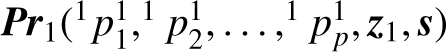

，它除了自身 *Arg* 中的自由变量外不含其他自由变量；如果存在一个网络 𝒩 及其中的一系列 *N*<sub>*i*</sub>，使得 *N*<sub>1</sub>(*z*<sub>1</sub>) ▪ *≡* ▪ *Pr*<sub>1</sub>(*N*<sub>1</sub>, *N*<sub>2</sub>*, …*, *z*<sub>1</sub>, *sa*<sub>1</sub>) 对该网络为真，其中 *sa*<sub>1</sub> 具有 *N* (0) 的形式，我们就称它*在狭义上可实现*。如果对于某个 *n*，*S*<sup>*n*</sup>(*Pr*<sub>1</sub>)(*p*<sub>1</sub>*, …*, *p*<sub>*p*</sub>, *z*<sub>1</sub>, *s*) 在上述意义上可实现，我们就称它*在广义上可实现*，或简称*可实现*。这里 *c*<sub>*pi*</sub> 是实现它的神经元。对于两条神经兴奋规律，如果在其中一种假设下按某一意义可实现的每个 *S*，在另一种假设下也可实现，尽管可能由不同的网络实现，我们就称它们是在该意义下等价的假设。Let us define the *peripheral afferents* of 𝒩 as the neurons of 𝒩 with no axons synapsing upon them. Let *N*<sub>1</sub>, …, *N*<sub>*p*</sub> denote the actions of such neurons and *N*<sub>*p*+1</sub>, *N*<sub>*p*+2</sub>, …, *N*<sub>*n*</sub> those of the rest. Then a *solution* of 𝒩 will be a class of sentences of the form *S*<sub>*i*</sub>: *N*<sub>*p*+1</sub>(*z*<sub>1</sub>) ▪ *≡* ▪ *Pr*<sub>*i*</sub>(*N*<sub>1</sub>, *N*<sub>2</sub>*, …*, *N*<sub>*p*</sub>, *z*<sub>1</sub>), where *Pr*<sub>*i*</sub> contains no free variable save *z*<sub>1</sub> and no descriptive symbols save the *N* in the argument [*Arg*], and possibly some constant sentences [*sa*]; and such that each *S*<sub>*i*</sub> is true of 𝒩. Conversely, given a

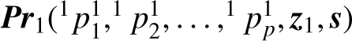

, containing no free variable save those in its *Arg*, we shall say that it is *realizable in the narrow sense* if there exists a net 𝒩 and a series of *N*<sub>*i*</sub> in it such that *N*<sub>1</sub>(*z*<sub>1</sub>) ▪ *≡* ▪ *Pr*<sub>1</sub>(*N*<sub>1</sub>, *N*<sub>2</sub>*, …*, *z*<sub>1</sub>, *sa*<sub>1</sub>) is true of it, where *sa*<sub>1</sub> has the form *N* (0). We shall call it *realizable in the extended sense*, or simply *realizable*, if for some *n*, *S*<sup>*n*</sup>(*Pr*<sub>1</sub>)(*p*<sub>1</sub>*, …*, *p*<sub>*p*</sub>, *z*<sub>1</sub>, *s*) is realizable in the above sense. *c*<sub>*pi*</sub> is here the realizing neuron. We shall say of two laws of nervous excitation which are such that every *S* which is realizable in either sense upon one supposition is also realizable, perhaps by a different net, upon the other, that they are equivalent assumptions, in that sense.

以下关于可实现性的定理都是指扩展意义上的。在某些情况下，可以获得关于窄可实现性的更清晰的定理；但是，除了陈述更加复杂之外，这几乎没有实际价值，因为我们目前的神经生理学知识仅将激发定律确定为扩展等效性，并且根据我们做出的可能假设，更精确的定理会有所不同。然而，我们不太精确的定理在等价条件下是不变的，并且仍然足以满足脉冲通过整个网络的确切时间并不重要的所有目的。The following theorems about realizability all refer to the extended sense. In some cases, sharper theorems about narrow realizability can be obtained; but in addition to greater complication in statement this were of little practical value, since our present neurophysiological knowledge determines the law of excitation only to extended equivalence, and the more precise theorems differ according to which possible assumption we make. Our less precise theorems, however, are invariant under equivalence, and are still sufficient for all purposes in which the exact time for impulses to pass through the whole net is not crucial.

现在可以精确陈述我们的核心问题：第一，找到一种有效方法，求出一组可计算的 *S*，构成任意给定网络的一个解；第二，以有效的方式刻画可实现的 *S* 所组成的类。用实质性的说法，这些问题就是：计算任意网络的行为，以及在确实存在这样的网络时，找出一个能以指定方式行动的网络。Our central problems may now be stated exactly: first, to find an effective method of obtaining a set of computable *S* constituting a solution of any given net; and second, to characterize the class of realizable *S* in an effective fashion. Materially stated, the problems are to calculate the behavior of any net, and to find a net which will behave in a specified way, when such a net exists.

如果一个网络包含环，就称它为*有环*网络；也就是说，其中存在一条神经元链 *c*<sub>*i*</sub>、*c*<sub>*i*+1</sub>、…，链中每个成员都在下一个成员上形成突触，且起点与终点相同。如果它的一组神经元 *c*<sub>1</sub>、*c*<sub>2</sub>、…、*c*<sub>*p*</sub> 满足如下条件：将它们从 𝒩 中移除后，网络便不再有环，而且没有更小的神经元类具有这种性质，那么这一组就称为一个*环集*，其基数称为 𝒩 的*阶*。我们将会看到，在一个重要意义上，网络的阶是其行为复杂程度的指标。特别是，零阶网络具有格外简单的性质；我们将首先讨论它们。A net will be called *cyclic* if it contains a circle, i.e. if there exists a chain *c*<sub>*i*</sub>, *c*<sub>*i*+1</sub>, … of neurons on it, each member of the chain synapsing upon the next, with the same beginning and end. If a set of its neurons *c*<sub>1</sub>, *c*<sub>2</sub>, …, *c*<sub>*p*</sub> is such that its removal from 𝒩 leaves it without circles, and no smaller class of neurons has this property, the set is called a *cyclic* set, and its cardinality is the *order* of 𝒩. In an important sense, as we shall see, the order of a net is an index of the complexity of its behaviour. In particular, nets of zero order have especially simple properties; we shall discuss them first.

让我们通过以下递归定义一个*时间命题表达式*（*TPE*），指定一个时间命题函数（*TPF ）。*Let us define a *temporal propositional expression* (a *TPE*), designating a temporal propositional function (*TPF*), by the following recursion.

1. A <sup>1</sup>*p*<sup>1</sup> [ *z*<sub>1</sub> ] 是一个*TPE*，其中*p*<sub>1</sub>是谓词变量。1. A <sup>1</sup>*p*<sup>1</sup>[*z*<sub>1</sub>] is a *TPE*, where *p*<sub>1</sub> is a predicate-variable.

2. 如果*S*<sub>1</sub>和*S*<sub>2</sub>是包含相同自由个体变量的*TPE*，则*S**S*<sub>1</sub>、*S*<sub>1</sub> ∨ *S*<sub>2</sub>、*S*<sub>1</sub> ▪ *S*<sub>2</sub>和*S*<sub>1</sub> ▪ *∼* *S*<sub>2</sub>也是如此。2. If *S*<sub>1</sub> and *S*<sub>2</sub> are *TPE* containing the same free individual variable, so are *S**S*<sub>1</sub>, *S*<sub>1</sub> ∨*S*<sub>2</sub>, *S*<sub>1</sub> ▪ *S*<sub>2</sub>, and *S*<sub>1</sub> ▪ *∼* *S*<sub>2</sub>.

3.其他都不是*TPE*。3. Nothing else is a *TPE*.

定理1.每个 0 阶网络都*可以用时间命题表达式来求解。*THEOREM 1. *Every net of order 0 can be solved in terms of temporal propositional expressions.*

令 *c*<sub>*i*</sub> 为 𝒩 中任意一个阈值为 *θ*<sub>*i*</sub> > 0 的神经元，设 *c*<sub>*i*1</sub>、*c*<sub>*i*2</sub>、…、*c*<sub>*ip*</sub> 分别在它上面形成 *n*<sub>*i*1</sub>、*n*<sub>*i*2</sub>、…、*n*<sub>*ip*</sub> 个兴奋性突触。设 *c*<sub>*j*1</sub>、*c*<sub>*j*2</sub>、…、*c*<sub>*jq*</sub> 在它上面形成抑制性突触。令 *κ*<sub>*i*</sub> 为 {*n*<sub>*i*1</sub>*, n*<sub>*i*2</sub>*, …, n*<sub>*ip*</sub>} 的所有满足成员之和超过 *θ*<sub>*i*</sub> 的子类所组成的集合。于是，根据上述假设，我们可以写出：Let *c*<sub>*i*</sub> be any neuron of 𝒩 with a threshold *θ*<sub>*i*</sub> > 0, and let *c*<sub>*i*1</sub>, *c*<sub>*i*2</sub>, …, *c*<sub>*ip*</sub> have respectively *n*<sub>*i*1</sub>, *n*<sub>*i*2</sub>, …, *n*<sub>*ip*</sub> excitatory synapses upon it. Let *c*<sub>*j*1</sub>, *c*<sub>*j*2</sub>, …, *c*<sub>*jq*</sub> have inhibitory synapses upon it. Let *κ*<sub>*i*</sub> be the set of the subclasses of {*n*<sub>*i*1</sub>*, n*<sub>*i*2</sub>*, …, n*<sub>*ip*</sub>} such that the sum of their members exceeds *θ*<sub>*i*</sub>. We shall then be able to write, in accordance with the assumptions mentioned above:

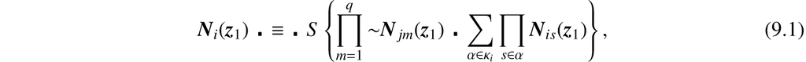

其中，“∑”和“‘∏”是分别表示析取和合取的句法符号，每一种情形下的析取与合取都是有限的。对于每个不是外围传入神经元的 *c*<sub>*i*</sub>，都可以写出这种形式的表达式；因此，由于 𝒩 无环，我们可以在（9.1）中，把神经元不属于外围传入神经元的每个 *N*<sub>*jm*</sub> 或 *N*<sub>*is*</sub> 替换为相应表达式，并对所得结果重复这一过程，最终得到仅以外围传入的 *N* 表示 *N*<sub>*i*</sub> 的表达式。此外，这个表达式将是一个 *TPE*，因为（9.1）显然就是 *TPE*；而根据定义，在一个 *TPE* 中用 *TPE* 替换一个组成部分 *p*(*z*)，所得结果显然也仍是 *TPE*。where the “∑” and “‘∏” are syntactical symbols for disjunctions and conjunctions which are finite in each case. Since an expression of this form can be written for each *c*<sub>*i*</sub> which is not a peripheral afferent, we can, by substituting the corresponding expression in (9.1) for each *N*<sub>*jm*</sub> or *N*<sub>*is*</sub> whose neuron is not a peripheral afferent, and repeating the process on the result, ultimately come to an expression for *N*<sub>*i*</sub> in terms solely of peripherally afferent *N*, since 𝒩 is without circles. Moreover, this expression will be a *TPE*, since obviously (9.1) is; and it follows immediately from the definition that the result of substituting a *TPE* for a constituent *p*(*z*) in a *TPE* is also one.

定理2.*每个*TPE都*可以通过零阶网络实现。*THEOREM 2. *Every* TPE *is realizable by a net of order zero.*

学习现象具有在神经活动的大多数生理变化中持续存在的特征，似乎需要网络结构发生永久性改变的可能性。最简单的这种改变是新突触的形成或等效的局部阈值降低。我们假设某些轴突末端一开始不能刺激随后的神经元；但是，如果神经元在任何时候放电，并且轴突末端同时被激发，它们就会变成普通类型的突触，从此能够激发神经元。抑制性突触的丧失给出了完全等同的结果。然后我们将有The phenomena of learning, which are of a character persisting over most physiological changes in nervous activity, seem to require the possibility of permanent alterations in the structure of nets. The simplest such alteration is the formation of new synapses or equivalent local depressions of threshold. We suppose that some axonal terminations cannot at first excite the succeeding neuron; but if at any time the neuron fires, and the axonal terminations are simultaneously excited, they become synapses of the ordinary kind, henceforth capable of exciting the neuron. The loss of an inhibitory synapse gives an entirely equivalent result. We shall then have

定理7.可改变的突触可以用*圆圈代替。*THEOREM 7. *Alterable synapses can be replaced by circles.*

## **9.3 理论：带圆圈的网****9.3 The Theory: Nets with Circles**

最后还要指出一件事。很容易证明：首先，每个网络如果配有磁带、连接传入神经的扫描仪以及执行必要的运动操作的合适传出神经，则只能计算图灵机那样的数字；其次，后面的每个数字都可以通过这样的网络来计算；并且可以通过这样的网络来计算带有圆圈的网络；带有圆圈的网络可以在没有扫描仪和磁带的情况下计算机器可以计算的一些数字，但不能计算其他数字，也不能计算全部数字。这很有趣，因为它为可计算性的图灵定义及其等价物、丘奇的*λ*可定义性和克莱恩的原始递归性提供了心理学上的证明：如果有机体可以计算任何数字，那么它就可以通过这些定义进行计算，反之亦然。One more thing is to be remarked in conclusion. It is easily shown: first, that every net, if furnished with a tape, scanners connected to afferents, and suitable efferents to perform the necessary motor-operations, can compute only such numbers as can a Turing machine; second, that each of the latter numbers can be computed by such a net; and that nets with circles can be computed by such a net; and that nets with circles can compute, without scanners and a tape, some of the numbers the machine can, but no others, and not all of them. This is of interest as affording a psychological justification of the Turing definition of computability and its equivalents, Church’s *λ*-definability and Kleene’s primitive recursiveness: if any number can be computed by an organism, it is computable by these definitions, and conversely.

## **9.4 后果****9.4 Consequences**

因果关系需要对状态的描述以及与它们相关的必然联系法则，它在多种科学中以多种形式出现，但除了统计学之外，它从来没有像这一理论中那样具有互反性。对任何一次传入刺激和所有组成神经元活动的规范（每一个都是“全有或全无”事件）决定了状态。神经网络的规范提供了必要连接法则，人们可以根据任何状态的描述来计算后续状态，但是包含析取关系会阻止对前一个状态的完全确定。此外，构成圈的再生活动使得过去的时间变得不确定。因此，我们对世界的认识，包括我们自己，在空间上是不完整的，在时间上是不确定的。这种无知隐含在我们所有的大脑中，是使我们的知识变得有用的抽象的对应物。大脑在确定我们的理论与我们的观察以及这些理论与事实的认知关系方面的作用是非常清楚的，因为很明显，每一个想法和每一种感觉都是通过该网络内的活动来实现的，并且没有这样的活动是可以实现的。实际的传入完全确定。Causality, which requires description of states and a law of necessary connection relating them, has appeared in several forms in several sciences, but never, except in statistics, has it been as irreciprocal as in this theory. Specification for any one time of afferent stimulation and of the activity of all constituent neurons, each an “all-or-none” affair, determines the state. Specification of the nervous net provides the law of necessary connection whereby one can compute from the description of any state that of the succeeding state, but the inclusion of disjunctive relations prevents complete determination of the one before. Moreover, the regenerative activity of constituent circles renders reference indefinite as to time past. Thus our knowledge of the world, including ourselves, is incomplete as to space and indefinite as to time. This ignorance, implicit in all our brains, is the counterpart of the abstraction which renders our knowledge useful. The role of brains in determining the epistemic relations of our theories to our observations and of these to the facts is all too clear, for it is apparent that every idea and every sensation is realized by activity within that net, and by no such activity are the actual afferents fully determined.

如果网络发生改变，我们可以持有的理论和我们可以做出的任何观察都无法保留其对事实的旧有缺陷的参考。耳鸣、感觉异常、幻觉、妄想、混乱和迷失方向会介入。因此，经验证实，如果我们的网络是不确定的，那么我们的事实也是不确定的，并且我们不能将“真实”归因于一种品质或“形式”。有了网络的决定，不可知的知识对象，即“事物本身”，就不再是不可知的。There is no theory we may hold and no observation we can make that will retain so much as its old defective reference to the facts if the net be altered. Tinitus, paraesthesias, hallucinations, delusions, confusions and disorientation intervene. Thus empiry confirms that if our nets are undefined, our facts are undefined, and to the “real” we can attribute not so much as one quality or “form.” With determination of the net, the unknowable object of knowledge, the “thing in itself,” ceases to be unknowable.

对于心理学来说，无论如何定义，网络的规范都将贡献该领域所能实现的一切——即使分析被推向最终的心理单位或“psychons”，因为一个psychons可能不亚于单个神经元的活动。由于这种活动本质上是命题性的，所以所有的心理事件都具有有意的或“符号学”的特征。这些活动的“全有或全无”法则，以及它们的关系与命题逻辑关系的一致性，确保了心理关系是命题二值逻辑的关系。因此，在心理学、内省心理学、行为主义心理学或生理学中，基本关系是二值逻辑的关系。To psychology, however defined, specification of the net would contribute all that could be achieved in that field—even if the analysis were pushed to ultimate psychic units or “psychons,” for a psychon can be no less than the activity of a single neuron. Since that activity is inherently propositional, all psychic events have an intentional, or “semiotic,” character. The “all-or-none” law of these activities, and the conformity of their relations to those of the logic of propositions, insure that the relations of psychons are those of the two-valued logic of propositions. Thus in psychology, introspective, behavioristic or physiological, the fundamental relations are those of two-valued logic.

因此，出现了整体问题的结构性解决方案，涉及感官意识的差异化连续体以及感知和执行的规范性、完善性和解决性属性。从因果关系的不互易性可以看出，即使网络是已知的，尽管我们可以从当前的活动预测未来，但我们既不能从中枢推断出传入，也不能从传出中推断出中枢，也不能从当前的活动中推断出过去——这些结论被矛盾的事实所强化。目击者的证词，难以区分诊断器质性疾病、歇斯底里症和装病者，以及将自己的记忆或回忆与同时代的记录进行比较。此外，系统对再生网络的传入物与该网络内的某些活动之间的差异作出反应，以减少差异，从而表现出有目的的行为。众所周知，生物体拥有许多这样的系统，促进体内平衡、食欲和注意力。因此，我们通常所说的*心理*活动的形式和最终方面都可以从当前的神经生理学中严格推论出来。精神病学家可能会从关于因果关系的明显结论中得到安慰——对于预后来说，病史从来都不是必要的。他无法从同样有效的结论中得出什么结论，即他的观察结果只能用神经活动来解释，而直到最近，神经活动仍然超出了他的知识范围。这种无知的症结在于，从任何公开行为样本对神经网络的推论都不是唯一的，而在可想象的网络中，实际上只有一个存在，并且可能在任何时刻表现出某种不可预测的活动。当然，对于精神病学家来说，更重要的是，在这样的系统中，“心灵”不再“比幽灵更幽灵”。相反，用神经生理学的科学术语来说，可以在不丧失范围或严谨性的情况下理解病态心态。对于神经学来说，该理论加深了特定活动所必需或仅仅足够的网络之间的区别，从而阐明了受干扰的结构与受干扰的功能的关系。在其自身领域，等效网络和狭义网络等效之间的差异表明了神经活动时间研究的适当使用和重要性：并且对于数学生物物理学，该理论提供了一种对已知网络进行严格符号处理的工具以及一种简单的方法构建所需属性的假设网络。Hence arise constructional solutions of holistic problems involving the differentiated continuum of sense awareness and the normative, perfective and resolvent properties of perception and execution. From the irreciprocity of causality it follows that even if the net be known, though we may predict future from present activities, we can deduce neither afferent from central, nor central from efferent, nor past from present activities—conclusions which are reinforced by the contradictory testimony of eye-witnesses, by the difficulty of diagnosing differentially the organically diseased, the hysteric and the malingerer, and by comparing one’s own memories or recollections with his contemporaneous records. Moreover, systems which so respond to the difference between afferents to a regenerative net and certain activity within that net, as to reduce the difference, exhibit purposive behavior; and organisms are known to possess many such systems, subserving homeostasis, appetition and attention. Thus both the formal and the final aspects of that activity which we are wont to call *mental* are rigorously deducible from present neurophysiology. The psychiatrist may take comfort from the obvious conclusion concerning causality—that, for prognosis, history is never necessary. He can take little from the equally valid conclusion that his observables are explicable only in terms of nervous activities which, until recently, have been beyond his ken. The crux of this ignorance is that inference from any sample of overt behavior to nervous nets is not unique, whereas, of imaginable nets, only one in fact exists, and may, at any moment, exhibit some unpredictable activity. Certainly for the psychiatrist it is more to the point that in such systems “Mind” no longer “goes more ghostly than a ghost.” Instead, diseased mentality can be understood without loss of scope or rigor, in the scientific terms of neurophysiology. For neurology, the theory sharpens the distinction between nets necessary or merely sufficient for given activities, and so clarifies the relations of disturbed structure to disturbed function. In its own domain the difference between equivalent nets and nets equivalent in the narrow sense indicates the appropriate use and importance of temporal studies of nervous activity: and to mathematical biophysics the theory contributes a tool for rigorous symbolic treatment of known nets and an easy method of constructing hypothetical nets of required properties.

1. 经 Springer 许可，由 McCulloch 和 Pitts (1943) 转载。Reprinted from McCulloch and Pitts (1943), with permission from Springer.

# **10**

# 关于 EDVAC 的报告初稿（1945）**First Draft of a Report on the EDVAC (1945)**

## **约翰·冯·诺依曼****John von Neumann**

本报告中描述但未命名的所谓“冯·诺依曼架构”具有图灵（1936 年，此处第 6 章）描述的“通用计算机”的逻辑结构，尽管这种相似性似乎有些巧合（参见第十八页）。保存程序运行数据的同一存储器也保存程序本身（第 94、104 页）。艾伦·图灵在他的自动计算引擎计划中引用了这份报告，但没有引用他自己的理论工作（图灵，1945）。The so-called “von Neumann architecture” described but not named in this report has the logical structure of the “universal computing machine” described by Turing (1936, here chapter 6), though the similarity seems to be something of a coincidence (see page xviii). The same memory that holds the data on which a program operates holds the program itself (pages 94, 104). Alan Turing cites this report but not his own theoretical work in his plan for an Automatic Calculating Engine (Turing, 1945).

1944 年，宾夕法尼亚大学摩尔学院的 Presper Eckert 和 John Mauchly 领导的团队中的两名成员 Arthur Burks（1915-2008）和 Herman Goldstine（1913-2004）设计了一台名为 EDVAC 的电子计算机，该计算机是其后继者埃克特-莫奇利 ENIAC 已经在为美国陆军进行弹道计算。在 Goldstine 偶然遇见了著名数学家约翰·冯·诺依曼（John von Neumann，1903-1957）并向他介绍了 EDVAC 项目后，冯·诺依曼加入了该小组。约翰·冯·诺依曼 (John von Neumann) 在这份备忘录中写下了这一设计，戈德斯坦 (Goldstine) 于 1945 年打印并发布了这份备忘录，其中仅列出了冯·诺依曼 (von Neumann) 作为作者。令人遗憾的是：该文档是冯·诺依曼的，但设计是该小组的，并且存储的程序已经是 ENIAC 的一部分（尽管在该机器中，该程序驻留在只读存储器中）。In 1944 Arthur Burks (1915–2008) and Herman Goldstine (1913–2004) were two members of the team led by Presper Eckert and John Mauchly designing an electronic computer known as the EDVAC at the Moore School of the University of Pennsylvania—the successor to the Eckert–Mauchly ENIAC that was already grinding out ballistics calculations for the U.S. Army. After Goldstine happened to meet the eminent mathematician John von Neumann (1903–1957) and told him about the EDVAC project, von Neumann joined the group. John von Neumann wrote up the design in this memo, which Goldstine typed and released in 1945, listing only von Neumann as author. That was regrettable: the document was von Neumann’s, but the design was the group’s, and the stored program was already part of the ENIAC (though in that machine, the program resided in read-only memory).

图10.1显示了打字稿的封面页，非常粗糙。在可能的情况下，我们提供了原文中的部分交叉引用，留待以后填写。1946 年，一份修订后的报告（Burks 等人，1947 年）发表，题为“电子计算仪器逻辑设计的初步讨论”，并添加了 Goldstine 和 Burks 作为合著者。Figure 10.1 shows the cover page of the typescript, which is very rough. Where possible, we have supplied section cross-references that in the original were left to be filled in later. A revised report (Burks et al., 1947) was issued in 1946 under the name “Preliminary discussion of the logical design of an electronic computing instrument,” adding Goldstine and Burks as co-authors.

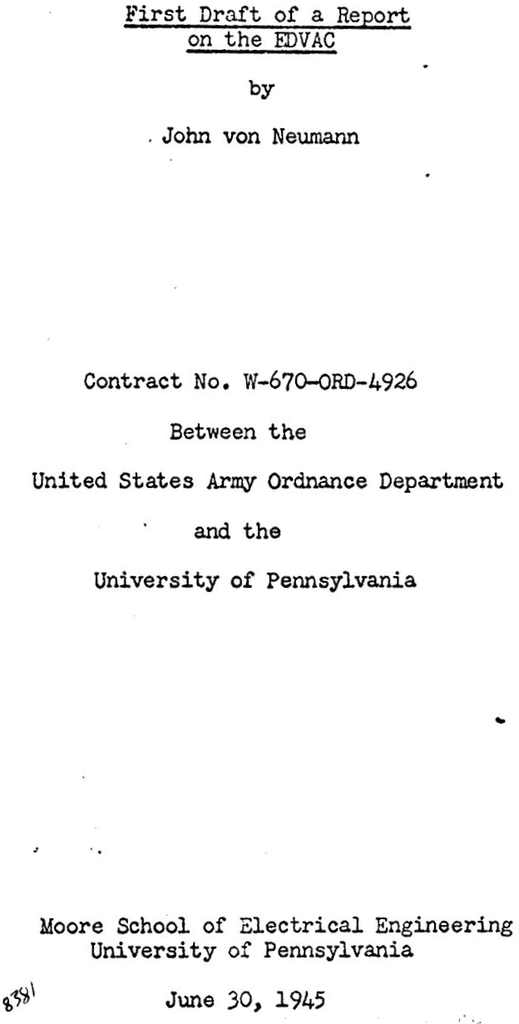

图 10.1： “初稿”打字稿的标题页Figure 10.1: Title page of “First draft” typescript

这些报告为计算机设计确定了方向，最终使软件行业成为可能，因为程序可以像任何其他类型的数据一样被处理并加载到内存中。报告使用二进制记数法将设备分析为内存和控制单元（“器官”），后面的“初步讨论”增加了对内存地址（“位置编号”）、各种寄存器、浮点表示和使用罗马字母表的前六个字母作为十六进制数字。但从短期来看，报告未能承认其他人的贡献，引起了设计团队创始成员的不满，尤其是 Mauchly，他起草了 EDVAC 及其前身机器 ENIAC 获得资助的提案，并且设计的。战争结束后，1947 年，莫奇利和埃克特中断了业务，开始了计算机业务，申请了专利，但由于本报告的提前发布，这些专利最终被宣告无效。（埃克特-莫奇利计算机公司后来的历史在第 169 页有概述。）伯克斯和戈德斯坦追求学术生涯，加入普林斯顿大学的冯·诺依曼。These reports set the direction for computer design that would eventually make the software industry possible, since programs could be processed and loaded into memory like any other kind of data. The reports analyze the device into memory and control units (“organs”) using binary notation, and the later “Preliminary discussion” adds explanations of memory addresses (“location-numbers”), registers of various kinds, floating-point representation, and use of the first six letters of the Roman alphabet as hexadecimal digits. But in the short run, the reports’ failure to acknowledge the contributions of others caused resentment among the founding members of the design team—in particular Mauchly, who had authored the proposal under which the EDVAC and its predecessor machine the ENIAC had been funded and designed. After the war, Mauchly and Eckert broke off to start a computer business, in 1947 filing patents that were ultimately invalidated because of the prior release of this report. (The subsequent history of the Eckert–Mauchly Computer Corporation is sketched on page 169.) Burks and Goldstine pursued academic careers, joining von Neumann at Princeton.

当冯·诺依曼加入 EDVAC 团队时，他已经是世界上最有成就的数学家之一，为众多数学领域、数理经济学和量子力学做出了贡献。他在匈牙利出生并接受教育，1930 年移居柏林，成为大卫·希尔伯特 (David Hilbert) 周围圈子的一员（见第 5 章）。他在第二次世界大战爆发前移居美国，是设计原子弹的曼哈顿计划的重要贡献者。他亲眼目睹了数百台人类“计算机”使用单独的机械计算器来求解他在裂变炸弹设计中得出的方程，尽管他无法与他在摩尔学院工作的小组讨论这项机密工作在普林斯顿大学，这为他开发高速自动计算机的工作提供了动力。By the time von Neumann joined the EDVAC team, he was already one of the most accomplished mathematicians in the world, having made contributions to a great variety of mathematical fields, to mathematical economics, and to quantum mechanics. Born and educated in Hungary, he moved to Berlin in 1930 to be part of the circle surrounding David Hilbert (see chapter 5). He emigrated to the US before the outbreak of the Second World War and was an important contributor to the Manhattan Project, which designed the atomic bomb. He witnessed the work of hundreds of human “computers” using individual mechanical calculators to solve the equations he had worked out in the design of a fission bomb, and though he could not discuss that classified work with the groups he worked with at the Moore School or at Princeton, it provided motivation for his work developing high-speed automatic computers.

“初稿”中的一些术语是特定于实施的，令人困惑。存储器采用延迟线的形式，以我们今天所说的 32 位字进行组织——冯·诺依曼将其称为“小周期”。32 位中的一位是一个标志，用于指示该字是代表数字还是代表指令（“顺序”）。数字使用另一位作为符号，其余位代表 - 1 和 1 之间的二进制分数。32 个小周期构成一个“主周期”或延迟线器官 (DLA)。整个存储器由 256 个 DLA 组成，因此，例如，要指定存储器中数字的地址，需要 8 位来标识 DLA，并需要另外 5 位来选出小周期。Some of the terminology of the “First draft” is confusingly implementation-specific. The memory was in the form of a delay line, organized in what we would today call 32-bit words—von Neumann called them “minor cycles.” One of the 32 bits was a flag to indicate whether the word represented a number or an instruction (“order”). Numbers used another bit for the sign, with the remaining bits representing a binary fraction between − 1 and 1. 32 minor cycles constituted a “major cycle” or delay line organ (DLA). The full memory comprised 256 DLAs, so to specify, for example, the address of a number in memory required 8 bits to identify the DLA and 5 more bits to single out the minor cycle.

为了达到一定程度的设计抽象，“初稿”提出了一个可能具有多种物理实现的双稳态“元素”。在第10.4.2节中，冯·诺依曼详细引用了麦卡洛克和皮茨，但他没有提到图灵。在省略的部分中，报告继续指出“刺激自身的元素将无限期地保持刺激”，正如“逻辑演算”中对神经元所说的那样（第 87 页）。冯·诺依曼使用的同步电路时钟让人想起麦卡洛克和皮茨施加在神经元电路上的离散时间变量，以使它们的行为接受逻辑分析。事实上，真空管和神经元之间的类比在设计中并没有被大量使用，尽管冯·诺依曼对大脑计算能力的推测很感兴趣，而且 EDVAC 的程序存储在快速存储器中，而不是存储在快速存储器中。像艾肯的 Mark I 那样，存储在卡或磁带上，这样就可以以电子速度访问连续的指令。To achieve a level of design abstraction, the “First draft” posits a bistable “element” that might have a variety of physical realizations. In §10.4.2, von Neumann cites McCulloch and Pitts at some length, but he does not mention Turing. In an omitted section, the report goes on to note that “an element which stimulates itself will hold a stimulus indefinitely,” exactly as “A Logical Calculus” had said of neurons (page 87). And von Neumann’s use of circuitry synchronized by a clock is reminiscent of the discrete time variable McCulloch and Pitts imposed on neuronal circuits to subject their behavior to logical analysis. In fact the analogy between a vacuum tube and a neuron is not heavily used in the design, though it was of interest to von Neumann in his speculations about the computational power of the brain, and the EDVAC’s program was stored in fast memory, rather than on cards or tape as in Aiken’s Mark I, simply so that successive instructions could be accessed at electronic speeds.

“初稿”中关于神经元计算的讨论在“初步讨论”中消失了，但冯·诺依曼从未对大脑作为计算机的想法失去兴趣，并且在他因癌症去世时仍在研究它53. *《计算机与大脑》*（冯·诺依曼，2000 年）在死后出版。The discussion of neuronal computing in this “First draft” disappeared in the “Preliminary discussion,” but von Neumann never lost interest in the idea of the brain as a computer and was still working on it at the time of his death from cancer at age 53. *The Computer and the Brain* (von Neumann, 2000) was published posthumously.

## **10.1 定义****10.1 Definitions**

### **10.1.1** 接下来的考虑涉及*超高速自动数字计算系统*的结构，特别是其*逻辑控制*。在讨论具体细节之前，对这些概念进行一些一般性解释可能是合适的。**10.1.1** The considerations which follow deal with the structure of a *very high speed automatic digital computing system*, and in particular with its *logical control*. Before going into specific details, some general explanatory remarks regarding these concepts may be appropriate.

### **10.1.2** *自动计算系统*是一种（通常是高度复合的）设备，它可以执行指令来执行相当复杂的计算，例如以数值方式求解 2 或 3 个自变量的非线性偏微分方程。**10.1.2** An *automatic computing system* is a (usually highly composite) device, which can carry out instructions to perform calculations of a considerable order of complexity—e.g. to solve a non-linear partial differential equation in 2 or 3 independent variables numerically.

控制该操作的指令必须以绝对详尽的细节提供给设备。它们包括解决所考虑的问题所需的所有数字信息：因变量的初始值和边界值、固定参数（常数）的值、问题陈述中出现的固定函数表。这些指令必须以设备可以感知的某种形式给出：打入打孔卡系统或电传打字带上，以磁性方式压印在钢带或钢丝上，以照相方式压印在电影胶片上，连接到一个或多个固定或可更换的插板中——这个列表并不一定完整。所有这些过程都需要使用一些代码来表达所考虑问题的逻辑和代数定义，以及必要的数字材料（参见上文）。The instructions which govern this operation must be given to the device in absolutely exhaustive detail. They include all numerical information which is required to solve the problem under consideration: Initial and boundary values of the dependent variables, values of fixed parameters (constants), tables of fixed functions which occur in the statement of the problem. These instructions must be given in some form which the device can sense: Punched into a system of punchcards or on teletype tape, magnetically impressed on steel tape or wire, photographically impressed on motion picture film, wired into one or more fixed or exchangeable plugboards—this list being by no means necessarily complete. All these procedures require the use of some code to express the logical and the algebraical definition of the problem under consideration, as well as the necessary numerical material (cf. above).

一旦向设备发出这些指令，它必须能够完全执行它们，而无需进一步的智能人工干预。在所需操作结束时，设备必须以上述形式之一再次记录结果。结果是数值数据；它们是设备在执行上述指令的过程中产生的数字材料的指定部分。Once these instructions are given to the device, it must be able to carry them out completely and without any need for further intelligent human intervention. At the end of the required operations the device must record the results again in one of the forms referred to above. The results are numerical data; they are a specified part of the numerical material produced by the device in the process of carrying out the instructions referred to above.

### **10.1.3** 然而，值得注意的是，该设备通常会产生比提到的（最终）结果更多的数值材料（为了达到结果）。因此，只需记录其数字输出的一小部分，如第10.1.2节所示，其余部分只会在设备内部循环，永远不会被记录下来供人类感知。这一点将在随后得到更仔细的考虑……。**10.1.3** It is worth noting, however, that the device will in general produce essentially more numerical material (in order to reach the results) than the (final) results mentioned. Thus only a fraction of its numerical output will have to be recorded as indicated in §10.1.2, the remainder will only circulate in the interior of the device, and never be recorded for human sensing. This point will receive closer consideration subsequently ….

### **10.1.4** 当然，第10.1.2节中有关设备所需自动功能的评论必须假定其功能正常。然而，任何设备发生故障的概率总是有限的，对于复杂的设备和长序列的操作来说，不可能使这种概率可以忽略不计。任何错误都可能损害设备的整个输出。为了识别和纠正此类故障，通常需要智能的人工干预。**10.1.4** The remarks of §10.1.2 on the desired automatic functioning of the device must, of course, assume that it functions faultlessly. Malfunctioning of any device has, however, always a finite probability—and for a complicated device and a long sequence of operations it may not be possible to keep this probability negligible. Any error may vitiate the entire output of the device. For the recognition and correction of such malfunctions intelligent human intervention will in general be necessary.

然而，在某种程度上甚至可以避免这些现象。该设备可以自动识别最常见的故障，通过外部可见的标志指示其存在和位置，然后停止。在某些条件下，它甚至可能自动执行必要的校正并继续（参见第10.3.3节）。However, it may be possible to avoid even these phenomena to some extent. The device may recognize the most frequent malfunctions automatically, indicate their presence and location by externally visible signs, and then stop. Under certain conditions it might even carry out the necessary correction automatically and continue (cf. §10.3.3).

## **10.2 系统主要细分****10.2 Main Subdivision of the System**

### **10.2.1** 在分析预期装置的功能时，某些分类区别立即显现出来。**10.2.1** In analyzing the functioning of the contemplated device, certain classificatory distinctions suggest themselves immediately.

### **10.2.2** 第一：由于该设备主要是计算机，因此它必须最频繁地执行算术的基本运算。它们是加法、减法、乘法和除法：+、−、×、÷。因此，它应该包含专门负责这些操作的专门机构，这是合理的。**10.2.2** First: Since the device is primarily a computer, it will have to perform the elementary operations of arithmetics most frequently. These are addition, subtraction, multiplication and division: +, −, ×, ÷. It is therefore reasonable that it should contain specialized organs for just these operations.

然而，必须指出的是，虽然这一原则本身可能是合理的，但其实现的具体方式需要仔细审查。即使是上面的运算列表：+、−、×、÷，也不是毫无疑问的。它可以扩展为包括诸如sgn、|之类的操作。|，还有 log <sub>10</sub>、 log <sub>2</sub>、ln、sin 及其倒数等。也可以考虑对其进行限制，例如省略 ÷ 甚至 ×。人们还可以考虑更具弹性的安排。对于某些操作，可以设想完全不同的过程，例如使用逐次逼近方法或函数表。……无论如何，设备的*中央算术*部分可能必须存在，这构成了*第一个特定部分：CA*。It must be observed, however, that while this principle as such is probably sound, the specific way in which it is realized requires close scrutiny. Even the above list of operations: +, −, ×, ÷, is not beyond doubt. It may be extended to include such operation as sgn, | |, also log<sub>10</sub>, log<sub>2</sub>, ln, sin and their inverses, etc. One might also consider restricting it, e.g. omitting ÷ and even ×. One might also consider more elastic arrangements. For some operations radically different procedures are conceivable, e.g. using successive approximation methods or function tables. … At any rate a *central arithmetical* part of the device will probably have to exist, and this constitutes *the first specific part: CA*.

### **10.2.3** 第二：设备的逻辑控制，即其操作的正确顺序，可以由中央控制机构最有效地执行。如果设备要具有*弹性*，即尽可能实现*所有目的*，那么必须区分针对特定问题给出和定义特定问题的具体指令与确保这些指令（无论如何）的一般控制机构之间的区别。它们是什么——都被执行了。10.1.2节中所示完成的——后者由设备的明确操作部分表示。我们所说的*中央控制*仅指后一种功能，执行该功能的器官形成*第二个特定部分：CC*。**10.2.3** Second: The logical control of the device, that is the proper sequencing of its operations, can be most efficiently carried out by a central control organ. If the device is to be *elastic*, that is as nearly as possible *all purpose*, then a distinction must be made between the specific instructions given for and defining a particular problem, and the general control organs which see to it that these instructions—no matter what they are—are carried out. The former must be stored in some way—in existing devices this is done as indicated in §10.1.2—the latter are represented by definite operating parts of the device. By the *central control* we mean this latter function only, and the organs which perform it form *the second specific part: CC*.

### **10.2.4** 第三：任何要执行长而复杂的操作序列（特别是计算）的设备都必须具有相当大的内存。其操作至少有以下四个阶段需要内存：**10.2.4** Third: Any device which is to carry out long and complicated sequences of operations (specifically of calculations) must have a considerable memory. At least the four following phases of its operation require a memory:

(c) 在许多问题中，特定函数起着至关重要的作用。它们通常以表格的形式给出。事实上，在某些情况下，这是通过经验给出它们的方式（例如，许多流体动力学问题中物质的状态方程），在其他情况下，它们可以通过解析表达式给出，但无论如何，它可能更简单、更快从固定表格中获取它们的值，而不是在需要值时重新计算它们（基于分析定义）。通常，只有中等数量的条目（100-200）的表并使用插值法是很方便的。在大多数情况下，线性甚至二次插值是不够的，因此最好依靠三次或双二次（甚至更高阶）插值标准……。(c) In many problems specific functions play an essential role. They are usually given in form of a table. Indeed in some cases this is the way in which they are given by experience (e.g. the equation of state of a substance in many hydrodynamical problems), in other cases they may be given by analytical expressions, but it may nevertheless be simpler and quicker to obtain their values from a fixed tabulation, than to compute them anew (on the basis of the analytical definition) whenever a value is required. It is usually convenient to have tables of a moderate number of entries only (100–200) and to use interpolation. Linear and even quadratic interpolation will not be sufficient in most cases, so it is best to count on a standard of cubic or biquadratic (or even higher order) interpolation ….

(d) 对于偏微分方程，初始条件和边界条件可能构成广泛的数值材料，必须在整个给定问题中记住它们。(d) For partial differential equations the initial conditions and the boundary conditions may constitute an extensive numerical material, which must be remembered throughout a given problem.

(e) 对于沿变量 *t* 积分的双曲型或抛物型偏微分方程，必须记住属于周期 *t* 的（中间）结果，才能计算周期 *t* + *dt*。这类材料大体属于 (d) 型，只不过它不是由操作人员输入装置，而是由装置自身在自动运行过程中产生的（随后也很可能由装置自行移除，并用 *t* + *dt* 的相应数据替换）。(e) For partial differential equations of the hyperbolic or parabolic type, integrated along a variable *t*, the (intermediate) results belonging to the cycle *t* must be remembered for the calculation of the cycle *t* + *dt*. This material is much of the type (d), except that it is not put into the device by human operators, but produced (and probably subsequently again removed and replaced by the corresponding data for *t* + *dt*) by the device itself, in the course of its automatic operation.

(f) 对于全微分方程(d)、(e)也适用，但它们需要较小的存储容量。在依赖于给定常量、固定参数等的问题中，需要类型 (d) 的进一步内存需求。(f) For total differential equations (d), (e) apply too, but they require smaller memory capacities. Further memory requirements of the type (d) are required in problems which depend on given constants, fixed parameters, etc.

(g) 通过逐次逼近解决的问题（例如椭圆型偏微分方程，用松弛方法处理）需要类型（e）的存储器：必须记住每个逼近的（中间）结果，而正在计算下一个。(g) Problems which are solved by successive approximations (e.g. partial differential equations of the elliptic type, treated by relaxation methods) require a memory of the type (e): The (intermediate) results of each approximation must be remembered, while those of the next one are being computed.

(h) 分类问题和某些统计实验（非常高速的设备为此提供了一个有趣的机会）需要对正在处理的材料进行记忆。(h) Sorting problems and certain statistical experiments (for which a very high speed device offers an interesting opportunity) require a memory for the material which is being treated.

### **10.2.5** 总结第三点：设备需要相当大的内存。虽然看起来该存储器的各个部分必须执行有些不同的功能然而，就其性质和相当大的目的而言，人们很容易将整个存储器视为一个器官，并使其各部分尽可能可以互换以实现上述列举的各种功能。这点将详细考虑……。**10.2.5** To sum up the third remark: The device requires a considerable memory. While it appeared that various parts of this memory have to perform functions which differ somewhat in their nature and considerably in their purpose, it is nevertheless tempting to treat the entire memory as one organ, and to have its parts even as interchangeable as possible for the various functions enumerated above. This point will be considered in detail ….

无论如何，总*内存*构成了*设备的第三个特定部分：M*。At any rate the total *memory* constitutes *the third specific part of the device: M*.

### **10.2.6** 三个特定部分 CA、CC（统称为 C）和 M 对应于人类神经系统中的*关联神经元。*仍有待讨论*感觉*或*传入神经元*和*运动*或*传出神经*元的等同物。这些是设备的*输入*和*输出器官，现在我们将简要考虑它们。***10.2.6** The three specific parts CA, CC (together C) and M correspond to the *associative* neurons in the human nervous system. It remains to discuss the equivalents of the *sensory* or *afferent* and the *motor* or *efferent* neurons. These are the *input* and the *output* organs of the device, and we shall now consider them briefly.

换句话说：设备的 C 部分和 M 部分之间的所有数字（或其他）信息传输都必须通过这些部分中包含的机制来实现。然而，仍然需要将原始确定信息从外部获取到设备中，以及将最终信息、结果从设备获取到外部。In other words: All transfers of numerical (or other) information between the parts C and M of the device must be effected by the mechanisms contained in these parts. There remains, however, the necessity of getting the original definitory information from outside into the device, and also of getting the final information, the results, from the device into the outside.

我们所说的外部是指第10.1.2节中描述的类型的介质：这里的信息或多或少可以直接通过人类行为产生（打字、打孔、拍摄由相同类型的按键产生的光脉冲、磁化金属带或电线）某种类似的方式等），它可以被静态存储，最终或多或少地被人体器官直接感知。By the outside we mean media of the type described in §10.1.2: Here information can be produced more or less directly by human action (typing, punching, photographing light impulses produced by keys of the same type, magnetizing metal tape or wire in some analogous manner, etc.), it can be statically stored, and finally sensed more or less directly by human organs.

该设备必须能够保持输入和输出（感觉和运动）与此类特定介质的接触（参见§ 10.1.2）：该介质将被称为*设备的外部记录介质：* R . 现在我们有：The device must be endowed with the ability to maintain the input and output (sensory and motor) contact with some specific medium of this type (cf. §10.1.2): That medium will be called the *outside recording medium of the device:* R. Now we have:

### **10.2.7** 第四：设备必须具有将（数字或其他）信息从 R 传输到其特定部分 C 和 M 的器官。这些器官形成其*输入*，*第四个特定部分：I*。可以看出，最好将所有从 R（通过 I）的传输转移到 M，而不是直接转移到 C（参见第10.14.1节）。**10.2.7** Fourth: The device must have organs to transfer (numerical or other) information from R into its specific parts, C and M. These organs form its *input*, the *fourth specific part: I*. It will be seen that it is best to make all transfers from R (by I) into M, and never directly into C (cf. §10.14.1).

### **10.2.8** 第五：该设备必须具有将（大概只有数字信息）从其特定部分 C 和 M 传输到 R 的器官。这些器官形成其输出，第五个特定部分：O。可以看出，最好再次使所有从 M（通过 O）转移到 R，而不是直接从 C 转移（参见 § 10.14.1）。**10.2.8** Fifth: The device must have organs to transfer (presumably only numerical information) from its specific parts C and M into R. These organs form its output, the fifth specific part: O. It will be seen that it is again best to make all transfers from M (by O) into R, and never directly from C, (cf. §10.14.1).

### **10.2.9** 当然，进入 R 的输出信息代表了设备对所考虑问题的操作的最终结果。这些必须与中间结果区分开来，例如在第10.2.4节（e）-（g）中讨论的中间结果，这些结果保留在 M 内部。此时出现了一个重要问题：除了其或多或少直接可访问性的属性之外，人类的行为和感知 R 也具有记忆的特性。事实上，它是长期存储自动设备获得的有关各种问题的所有信息的天然介质。那么为什么需要在设备M内提供另一种类型的存储器呢？难道 M 的全部或至少部分功能（最好是那些涉及大量信息的功能）不能被 R 接管吗？**10.2.9** The output information, which goes into R, represents, of course, the final results of the operation of the device on the problem under consideration. These must be distinguished from the intermediate results, discussed e.g. in §10.2.4, (e)–(g), which remain inside M. At this point an important question arises: Quite apart from its attribute of more or less direct accessibility to human action and perception R has also the properties of a memory. Indeed, it is the natural medium for long time storage of all the information obtained by the automatic device on various problems. Why is it then necessary to provide for another type of memory within the device M? Could not all, or at least some functions of M—preferably those which involve great bulks of information—be taken over by R?

事实上，所有现有的（全自动或部分自动）计算设备都使用 R（作为一堆打孔卡或一段电传打字带）来实现所有这些目的（除了 (a)，如上所述）。然而，看起来真正的高速设备的用途将非常有限，除非它可以依靠 M，而不是 R，来实现第 10.2.4 节（a）-（h）中列举的所有目的，并且10.2.4某些(e)、(g)、(h) …情况下的限制。Indeed, all existing (fully or partially automatic) computing devices use R—as a stack of punchcards or a length of teletype tape—for all these purposes (excepting (a), as pointed out above). Nevertheless it will appear that a really high speed device would be very limited in its usefulness unless it can rely on M, rather than on R, for all the purposes enumerated in §10.2.4, (a)–(h), with certain limitations in the case of (e), (g), (h) ….

## **10.3 讨论程序****10.3 Procedure of Discussion**

### **10.3.1** 10.2节的分类已经完成，现在可以将设备细分为五个具体部分，并一一进行讨论。这样的讨论必须揭示出这些部分本身及其相互关系所需的特征。它还必须确定从设备的角度处理数字、执行算术运算以及提供一般逻辑控制所使用的具体过程。所有关于时机和速度的问题，以及各种因素的相对重要性问题，都必须在这些考虑因素的框架内得到解决。**10.3.1** The classification of §10.2 being completed, it is now possible to take up the five specific parts into which the device was seen to be subdivided, and to discuss them one by one. Such a discussion must bring out the features required for each one of these parts in itself, as well as in their relations to each other. It must also determine the specific procedures to be used in dealing with numbers from the point of view of the device, in carrying out arithmetical operations, and providing for the general logical control. All questions of timing and of speed, and of the relative importance of various factors, must be settled within the framework of these considerations.

### **10.3.2** 理想的程序是，按照某种确定的顺序处理五个特定部分，详尽地处理其中的每一个部分，只有在完全处理掉前一个部分后才继续进行下一个部分。然而，这似乎不太可行。各个部分的理想特征以及基于它们的决策只有在经过一些曲折的讨论之后才会出现。因此，有必要先讨论一个部分，在不完整的讨论后转到第二部分，在对后者同样不完整的讨论后返回第一部分，并结合结果返回第一部分，在尚未结束的情况下扩展第一部分的讨论，然后可能继续到第三部分，等等。此外，这些特定部分的讨论将与一般原理、算术过程、要使用的元素等的讨论混合在一起。**10.3.2** The ideal procedure would be, to take up the five specific parts in some definite order, to treat each one of them exhaustively, and go on to the next one only after the predecessor is completely disposed of. However, this seems hardly feasible. The desirable features of the various parts, and the decisions based on them, emerge only after a somewhat zigzagging discussion. It is therefore necessary to take up one part first, pass after an incomplete discussion to a second part, return after an equally incomplete discussion of the latter with the combined results to the first part, extend the discussion of the first part without yet concluding it, then possibly go on to a third part, etc. Furthermore, these discussions of specific parts will be mixed with discussions of general principles, of arithmetical procedures, of the elements to be used, etc.

在这样的讨论过程中，所需的特征和似乎最适合保护它们的布置将逐渐具体化，直到设备及其控制呈现出相当明确的形状。正如之前所强调的，这适用于物理设备以及控制其功能的算术和逻辑安排。In the course of such a discussion the desired features and the arrangements which seem best suited to secure them will crystallize gradually until the device and its control assume a fairly definite shape. As emphasized before, this applies to the physical device as well as to the arithmetical and logical arrangements which govern its functioning.

### **10.3.3** 在讨论过程中，第10.1.4节涉及故障的检测、定位以及在某些条件下甚至纠正的观点也必须受到一些关注。考虑。也就是说，必须注意检查错误的设施。我们无法完全公正地对待这个重要的主题，但每当这看起来很重要时，我们都会尝试至少粗略地考虑它……。**10.3.3** In the course of this discussion the viewpoints of §10.1.4, concerned with the detection, location, and under certain conditions even correction, of malfunctions must also receive some consideration. That is, attention must be given to facilities for checking errors. We will not be able to do anything like full justice to this important subject, but we will try to consider it at least cursorily whenever this seems essential ….

## **10.4 元素、同步性、神经元类比****10.4 Elements, Synchronism, Neuron Analogy**

### **10.4.1** 我们以一些一般性评论开始讨论：**10.4.1** We begin the discussion with some general remarks:

每个数字计算设备都包含某些具有离散平衡的类似继电器的*元件*。这样的元素具有两种或多种不同的状态，在这些状态中它可以无限期地存在。这些可能是完美的平衡，在每种平衡中，元素将在没有任何外部支持的情况下保持不变，而适当的外部刺激会将其从一种平衡转移到另一种平衡。或者，可能有两种状态，其中一种是在没有外部支持时存在的平衡，而另一种则取决于外部刺激的存在。中继动作表现为每当元件本身接收到上述类型的刺激时元件就会忽略刺激。发出的刺激必须与接收到的刺激属于同一类型，也就是说，它们必须能够刺激其他元素。然而，接收到的刺激和发出的刺激之间一定不存在能量关系，也就是说，接收到一个刺激的元件必须能够发出多个相同强度的刺激。换句话说：作为一个继电器，该元件必须从另一个来源接收能量供应，而不是输入刺激。Every digital computing device contains certain relay like *elements*, with discrete equilibria. Such an element has two or more distinct states in which it can exist indefinitely. These may be perfect equilibria, in each of which the element will remain without any outside support, while appropriate outside stimuli will transfer it from one equilibrium into another. Or, alternatively, there may be two states, one of which is an equilibrium which exists when there is no outside support, while the other depends for its existence upon the presence of an outside stimulus. The relay action manifests itself in the omission of stimuli by the element whenever it has itself received a stimulus of the type indicated above. The emitted stimuli must be of the same kind as the received one, that is, they must be able to stimulate other elements. There must, however, be no energy relation between the received and the emitted stimuli, that is, an element which has received one stimulus, must be able to emit several of the same intensity. In other words: Being a relay, the element must receive its energy supply from another source than the incoming stimulus.

在现有的数字计算设备中，各种机械或电气设备已被用作元件： 轮子，可以锁定到十个（或更多）重要位置中的任何一个，并且在从一个位置移动到另一个位置时发射可能导致其他位置的电脉冲。类似的轮子移动；由电磁体驱动并打开或关闭电路的单个或组合电报继电器；这两个元素的组合；——最后，存在使用真空管的合理且诱人的可能性，栅极充当阴极板电路的阀门。在最后提到的情况下，栅极也可能被偏转装置所取代，即真空管被阴极射线管取代——但很可能在未来一段时间内，真空管的更大可用性和各种电气优势将使第一个程序在前台运行。In existing digital computing devices various mechanical or electrical devices have been used as elements: Wheels, which can be locked into any one of ten (or more) significant positions, and which on moving from one position to another transmit electric pulses that may cause other similar wheels to move; single or combined telegraph relays, actuated by an electromagnet and opening or closing electric circuits; combinations of these two elements;—and finally there exists the plausible and tempting possibility of using vacuum tubes, the grid acting as a valve for the cathode-plate circuit. In the last mentioned case the grid may also be replaced by deflecting organs, i.e. the vacuum tube by a cathode ray tube—but it is likely that for some time to come the greater availability and various electrical advantages of the vacuum tubes proper will keep the first procedure in the foreground.

任何这样的设备都可以通过其元件的连续反应时间来自主计时。在这种情况下，所有刺激最终都必须源自输入。或者，他们的计时可能受到固定时钟的影响，固定时钟提供了其在确定的周期性重复时刻发挥作用所必需的某些刺激。该时钟可以是机械或混合机电装置中的旋转轴；它可能是纯电气设备中的电振荡器（可能是晶体控制的）。如果依赖于设备同时执行的几个不同操作序列的同步性，则时钟印象定时显然是更可取的。我们将在上述定义的技术意义上使用术语“*元素”* ，并根据其时序是由时钟还是自主来调用设备，并将其称为*同步*或*异步，如上所述。*Any such device may time itself autonomously, by the successive reaction times of its elements. In this case all stimuli must ultimately originate in the input. Alternatively, they may have their timing impressed by a fixed clock, which provides certain stimuli that are necessary for its functioning at definite periodically recurrent moments. This clock may be a rotating axis in a mechanical or a mixed, mechanico-electrical device; and it may be an electrical oscillator (possibly crystal controlled) in a purely electrical device. If reliance is to be placed on synchronisms of several distinct sequences of operations performed simultaneously by the device, the clock impressed timing is obviously preferable. We will use the term *element* in the above defined technical sense, and call the device *synchronous* or *asynchronous*, according to whether its timing is impressed by a clock or autonomous, as described above.

### **10.4.2** 值得一提的是，高等动物的神经元绝对是上述意义上的要素。它们具有全有或全无的性格，即两种状态：静止和兴奋。10.4.1的要求：兴奋的神经元沿着许多线（轴突）发出标准刺激。然而，这样的线可以通过两种不同的方式连接到下一个神经元：第一：在*兴奋性突触*中，以便刺激引起神经元的兴奋。第二：在*抑制性突触*中，刺激绝对阻止任何其他（兴奋性）突触上的任何刺激对神经元的兴奋。神经元在接受刺激和发出刺激之间也有一定的反应时间，即*突触延迟*。**10.4.2** It is worth mentioning, that the neurons of the higher animals are definitely elements in the above sense. They have all-or-none character, that is two states: Quiescent and excited. They fulfill the requirements of §10.4.1 with an interesting variant: An excited neuron emits the standard stimulus along many lines (axons). Such a line can, however, be connected in two different ways to the next neuron: First: In an *excitatory synapse*, so that the stimulus causes the excitation of the neuron. Second: In an *inhibitory synapse*, so that the stimulus absolutely prevents the excitation of the neuron by any stimulus on any other (excitatory) synapse. The neuron also has a definite reaction time, between the reception of a stimulus and the emission of the stimuli caused by it, the *synaptic delay*.

遵循 McCulloch 和 Pitts（1943 年，此处第 9 章），我们忽略了神经元功能的更复杂的方面：阈值、时间求和、相对抑制、突触延迟之外的刺激后效应引起的阈值变化等。然而，它是，方便偶尔考虑具有固定阈值 2 和 3 的神经元，即只能通过 2 或 3 个兴奋性突触上的（同时）刺激（而抑制性突触上没有）刺激的神经元。……Following McCulloch and Pitts (1943, here chapter 9) we ignore the more complicated aspects of neuron functioning: Thresholds, temporal summation, relative inhibition, changes of the threshold by after-effects of stimulation beyond the synaptic delay, etc. It is, however, convenient to consider occasionally neurons with fixed thresholds 2 and 3, that is, neurons which can be excited only by (simultaneous) stimuli on 2 or 3 excitatory synapses (and none on an inhibitory synapse). …

很容易看出，这些简化的神经元功能可以通过电报继电器或真空管来模拟。尽管神经系统可能是异步的（对于突触延迟），但可以通过使用同步设置获得精确的突触延迟。……It is easily seen that these simplified neuron functions can be imitated by telegraph relays or by vacuum tubes. Although the nervous system is presumably asynchronous (for the synaptic delays), precise synaptic delays can be obtained by using synchronous setups. …

### **10.4.3** 显然，超高速计算设备理想地应该具有真空管元件。计数器和定标器等真空管聚合器已被使用，并且发现反应时间（突触延迟）短至一微秒（= 10 <sup>−6</sup>秒）是可靠的，这是其他设备无法近似的性能。事实上：纯粹的机械设备可以完全忽略，实际的电报继电器反应时间约为 10 毫秒（= 10 <sup>−2</sup>秒）或更长。有趣的是，人类神经元的突触时间约为毫秒（= 10 <sup>−3</sup>秒）。**10.4.3** It is clear that a very high speed computing device should ideally have vacuum tube elements. Vacuum tube aggregates like counters and scalers have been used and found reliable at reaction times (synaptic delays) as short as a microsecond ( = 10<sup>−6</sup> seconds), this is a performance which no other device can approximate. Indeed: Purely mechanical devices may be entirely disregarded and practical telegraph relay reaction times are of the order of 10 milliseconds ( = 10<sup>−2</sup> seconds) or more. It is interesting to note that the synaptic time of a human neuron is of the order of a millisecond ( = 10<sup>−3</sup> seconds).

在接下来的考虑中，我们将相应地假设该设备具有真空管作为元件。我们还将尝试在所使用的管子类型是传统的和市售的管子的基础上，对所涉及的管子数量、时间等进行所有估计。也就是说，不使用异常复杂或具有全新功能的管子。在对传统类型（或一些等效元素……）进行彻底分析后，使用新型管的可能性实际上会变得更加清晰和明确。In the considerations which follow we will assume accordingly, that the device has vacuum tubes as elements. We will also try to make all estimates of numbers of tubes involved, timing, etc., on the basis that the types of tubes used are the conventional and commercially available ones. That is, that no tubes of unusual complexity or with fundamentally new functions are to be used. The possibilities for the use of new types of tubes will actually become clearer and more definite after a thorough analysis with the conventional types (or some equivalent elements …) has been carried out.

最后，同步设备似乎具有相当大的优势……。Finally, it will appear that a synchronous device has considerable advantages ….

## **10.5 算术运算的指导原则****10.5 Principles Governing the Arithmetical Operations**

### **10.5.1** 现在让我们考虑第一个特定部分的某些功能：中央算术部分 CA。**10.5.1** Let us now consider certain functions of the first specific part: The central arithmetical part CA.

10.4.3意义上的元件，用作电流阀或*门的*真空管，是一种全有或全无的装置，或者至少它近似于一种：根据栅极偏压是否高于或低于截止值，它是否会通过电流。确实，它的所有电极上都需要确定的电势才能维持任一状态，但是真空管的组合具有完美的平衡：每种组合都可以无限期地存在几种状态，无需任何外部支持，只要适当外部刺激（电脉冲）会将其从一种平衡转移到另一种平衡。这些就是所谓的触发电路，基本电路有两个平衡点并包含两个三极管或一个五极管。具有两个以上平衡点的触发电路所涉及的程度要高得多。The element in the sense of §10.4.3, the vacuum tube used as a current valve or *gate*, is an all-or-none device, or at least it approximates one: According to whether the grid bias is above or below cut-off, it will pass current or not. It is true that it needs definite potentials on all its electrodes in order to maintain either state, but there are combinations of vacuum tubes which have perfect equilibria: Several states in each of which the combination can exist indefinitely, without any outside support, while appropriate outside stimuli (electric pulses) will transfer it from one equilibrium into another. These are the so called trigger circuits, the basic one having two equilibria and containing two triodes or one pentode. The trigger circuits with more than two equilibria are disproportionately more involved.

因此，无论管子用作门还是触发器，全有或全无的两种平衡布置都是最简单的布置。由于这些管装置是通过数字来处理数字的，因此很自然地使用数字也是二值的算术系统。这表明使用二进制系统。Thus, whether the tubes are used as gates or as triggers, the all-or-none, two equilibrium, arrangements are the simplest ones. Since these tube arrangements are to handle numbers by means of their digits, it is natural to use a system of arithmetic in which the digits are also two valued. This suggests the use of the binary system.

10.4.2 – 10.4.3中讨论的人类神经元的类似物同样是全有或全无元素。看起来它们对于真空管系统的所有初步、定向、考虑非常有用（参见§§ 10.6.1 – 10.6.2）。因此，令人满意的是，这里要处理的自然算术系统也是二进制系统。The analogs of human neurons, discussed in §§10.4.2–10.4.3, are equally all-or-none elements. It will appear that they are quite useful for all preliminary, orienting, considerations of vacuum tube systems (cf. §§10.6.1–10.6.2). It is therefore satisfactory that here too the natural arithmetical system to handle is the binary one.

### **10.5.2** 二进制系统的一致使用也可能大大简化乘法和除法的运算。具体来说，它取消了十进制乘法表，或者取消了另一种双倍程序，即首先通过加法建立每个乘数或商数字的倍数，然后通过第二个加法或减法序列将它们组合起来（根据位置值）。换句话说：二进制算术比任何其他算术（尤其是十进制算术）具有更简单、更单一的逻辑结构。**10.5.2** A consistent use of the binary system is also likely to simplify the operations of multiplication and division considerably. Specifically it does away with the decimal multiplication table, or with the alternative double procedure of building up the multiples of each multiplier or quotient digit by additions first, and then combining these (according to positional value) by a second sequence of additions or subtractions. In other words: Binary arithmetics has a simpler and more one-piece logical structure than any other, particularly than the decimal one.

当然，必须记住，人类直接使用的数字材料很可能必须以十进制表示。因此，R 中使用的符号应该是十进制。但无论如何，最好在 CA 中以及在可能进入中央控制 CC 的任何数字材料中使用严格的二进制程序。因此 M 应该只存储二进制材料。It must be remembered, of course, that the numerical material which is directly in human use, is likely to have to be expressed in the decimal system. Hence, the notations used in R should be decimal. But it is nevertheless preferable to use strictly binary procedures in CA, and also in whatever numerical material may enter into the central control CC. Hence M should store binary material only.

这就需要将十进制-二进制和二进制-十进制转换设施合并到 I 和 O 中。由于这些转换需要大量算术操作，因此使用 CA 是最经济的，因此为了协调目的，也使用 CC，与 I 和 O 相关然而，CA 的使用意味着两种转换中使用的所有算术都必须严格是二进制的。……This necessitates incorporating decimal-binary and binary-decimal conversion facilities into I and O. Since these conversions require a good deal of arithmetical manipulating, it is most economical to use CA, and hence for coordinating purposes also CC, in connection with I and O. The use of CA implies, however, that all arithmetics used in both conversions must be strictly binary. …

### **10.5.3** 这时又出现了另一个原则问题。在元件不是真空管的所有现有装置中，元件的反应时间足够长，以使得涉及加法、减法、尤其是乘法和除法的步骤具有一定的伸缩性，这是期望的。以特定情况为例，考虑二进制乘法。许多微分方程问题的合理精度是通过保留 8 位有效小数位来给出的，即通过将相对舍入误差保持在 10 <sup>−8</sup>以下。这对应于二进制系统中的2 <sup>−27</sup>，即携带27个有效二进制数字。因此，乘法包括将 27 个被乘数数字中的每一位与 27 个乘数数字中的每一位配对，并且相应地形成乘积数字0和1，然后将它们定位并组合。这些本质上是 27 <sup>2</sup> = 729 个步骤，而收集和组合操作的数量可能大约是其数量的两倍。所以 1000-1500 步基本上是正确的。**10.5.3** At this point there arises another question of principle. In all existing devices where the element is not a vacuum tube the reaction time of the element is sufficiently long to make a certain telescoping of the steps involved in addition, subtraction, and still more in multiplication and division, desirable. To take a specific case consider binary multiplication. A reasonable precision for many differential equation problems is given by carrying 8 significant decimal digits, that is by keeping the relative rounding-off errors below 10<sup>−8</sup>. This corresponds to 2<sup>−27</sup> in the binary system, that is to carrying 27 significant binary digits. Hence a multiplication consists of pairing each one of 27 multiplicand digits with each one of 27 multiplier digits, and forming product digits 0 and 1 accordingly, and then positioning and combining them. These are essentially 27<sup>2</sup> = 729 steps, and the operations of collecting and combining may about double their number. So 1000–1500 steps are essentially right.

很自然地观察到，在十进制系统中，相当少的步数可以获得 8 <sup>2</sup> = 64 步，可能加倍，即大约 100 步。然而，如此低的数字是以使用乘法表或以其他方式增加或复杂化设备的代价购买的。以这个价格，也可以通过更直接的二进制技巧来缩短该过程，这将在目前考虑。因此，似乎没有必要单独讨论十进制过程。It is natural to observe that in the decimal system a considerably smaller number of steps obtains 8<sup>2</sup> = 64 steps, possibly doubled, that is about 100 steps. However, this low number is purchased at the price of using a multiplication table or otherwise increasing or complicating the equipment. At this price the procedure can be shortened by more direct binary artifices, too, which will be considered presently. For this reason it seems not necessary to discuss the decimal procedure separately.

### **10.5.4** 如前所述，每次乘法 1000-1500 个连续步骤将使任何非真空管设备慢得令人无法接受。除一些最新的特殊继电器外，所有此类设备的反应时间都超过10毫秒，而这些最新的继电器（其反应时间可能低至5毫秒）使用的时间并不长。这将给出每次（8 位十进制数字）乘法的最短 10-15 秒的时间，而对于快速现代台式计算机来说，这个时间是 10 秒，对于标准 IBM 乘法器来说，这个时间是 6 秒。（对于这些持续时间的重要性，以及可能的真空管装置在应用于典型问题时的重要性，参见……）**10.5.4** As pointed out before, 1000–1500 successive steps per multiplication would make any non vacuum tube device unacceptably slow. All such devices, excepting some of the latest special relays, have reaction times of more than 10 milliseconds, and these newest relays (which may have reaction times down to 5 milliseconds) have not been in use very long. This would give an extreme minimum of 10–15 seconds per (8 decimal digit) multiplication, whereas this time is 10 seconds for fast modern desk computing machines, and 6 seconds for the standard IBM multipliers. (For the significance of these durations, as well as of those of possible vacuum tube devices, when applied to typical problems, cf. ….)

避免这些长时间持续的逻辑过程包括*伸缩操作*，即同时执行尽可能多的操作。由于携带的复杂性，甚至连加法或减法这样简单的运算也无法立即执行。在除法中，除非已知其左边的所有数字，否则数字的计算甚至无法开始。然而，相当多的同时化是可能的：除了加法或减法之外，所有对应数字对可以立即组合，所有第一个进位数字可以在下一步中一起应用，等等。在乘法中，所有部分积的形式为（被乘数）×（乘数位）可以同时形成和定位——在二进制系统中，这样的部分积为零或被乘数，因此这只是定位问题。在加法和乘法中，可以使用上述加速形式的加法和减法。此外，在乘法中，通过将第一对与第二对、第三对等同时相加，可以快速对部分积求和；然后将第一对对和与第二对、第三对和等同时相加；依此类推，直到收集完所有条款。（由于 27 ≤ 2 <sup>5</sup>，这允许在 5 次加法中收集 27 个部分和（假设有 27 个二进制数字乘数）。该方案由 H. Aiken 提出。）The logical procedure to avoid these long durations, consists of *telescoping operations*, that is of carrying out simultaneously as many as possible. The complexities of carrying prevent even such simple operations as addition or subtraction to be carried out at once. In division the calculation of a digit cannot even begin unless all digits to its left are already known. Nevertheless considerable simultaneisations are possible: In addition or subtraction all pairs of corresponding digits can be combined at once, all first carry digits can be applied together in the next step, etc. In multiplication all the partial products of the form (multiplicand) × (multiplier digit) can be formed and positioned simultaneously—in the binary system such a partial product is zero or the multiplicand, hence this is only a matter of positioning. In both addition and multiplication the above mentioned accelerated forms of addition and subtraction can be used. Also, in multiplication the partial products can be summed up quickly by adding the first pair together simultaneously with the second pair, the third pair, etc.; then adding the first pair of pair sums together simultaneously with the second one, the third one, etc.; and so on until all terms are collected. (Since 27 ≤ 2<sup>5</sup>, this allows to collect 27 partial sums—assuming a 27 binary digit multiplier—in 5 addition times. This scheme is due to H. Aiken.)

这种加速、伸缩程序正在所有现有设备中使用。10.5.3节末尾所指出的。它实际上比纯粹的二进过程效率要低一些。第10.5.1 – 10.5.2反对在这里考虑它。）但是，它们仅以精确地增加必要设备的速率（即设备中的元件数量）节省时间：显然，如果通过系统地执行来将持续时间减半二一次添加，需要双重添加设备（即使假设可以在没有不成比例的控制设施的情况下使用并且完全有效）等。Such accelerating, telescoping procedures are being used in all existing devices. (The use of the decimal system, with or without further telescoping artifices is also of this type, as pointed out at the end of §10.5.3. It is actually somewhat less efficient than purely dyadic procedures. The arguments of §§10.5.1–10.5.2 speak against considering it here.) However, they save time only at exactly the rate at which they multiply the necessary equipment, that is the number of elements in the device: Clearly if a duration is halved by systematically carrying out two additions at once, double adding equipment will be required (even assuming that it can be used without disproportionate control facilities and fully efficiently), etc.

这种通过增加设备来赢得时间的方式在非真空管元件设备中是完全合理的，在非真空管元件设备中，赢得时间至关重要，并且在处理包含许多元件的相关设备方面可以获得丰富的工程经验。根据所有可用的经验，按照这些思路构建的真正通用的自动数字计算系统必须包含超过 10,000 个元素。This way of gaining time by increasing equipment is fully justified in non vacuum tube element devices, where gaining time is of the essence, and extensive engineering experience is available regarding the handling of involved devices containing many elements. A really all-purpose automatic digital computing system constructed along these lines must, according to all available experience, contain over 10,000 elements.

### **10.5.5** 另一方面，对于真空管元件装置来说，相反的过程似乎更有希望。**10.5.5** For a vacuum tube element device on the other hand, it would seem that the opposite procedure holds more promise.

10.4.3节所指出的，不太复杂的真空管装置的反应时间可以缩短至一微秒。10.5.3节中获得的未操纵的乘法持续时间也是可以接受的：1000-1500 个反应时间相当于 1-1.5 毫秒，这比任何可以想象的非真空管设备快得多，以至于它实际上产生保持设备平衡的一个严重问题，即保持其输入和输出端之外的必要的人类监督与其操作同步。……As pointed out in §10.4.3, the reaction time of a not too complicated vacuum tube device can be made as short as one microsecond. Now at this rate even the unmanipulated duration of the multiplication, obtained in §10.5.3 is acceptable: 1000–1500 reaction times amount to 1–1.5 milliseconds, and this is so much faster than any conceivable non vacuum tube device, that it actually produces a serious problem of keeping the device balanced, that is to keep the necessarily human supervision beyond its input and output ends in step with its operations. …

关于其他算术运算，可以这样说：加法和减法显然比乘法快得多。以 27 个二进制数字为基础（参见第10.5.3节）并考虑进位，每个数字最多需要 27 个步骤的两倍，即大约 30-50 个步骤或反应时间。这相当于 0.03–0.05 毫秒。在该方案中，在乘法中没有尝试捷径和伸缩并且使用二进制系统，除法所花费的步数与乘法大约相同。……平方根通常（在这个方案中也是如此）本质上并不比除法长。Regarding other arithmetical operations this can be said: Addition and subtraction are clearly much faster than multiplication. On a basis of 27 binary digits (cf. §10.5.3) and taking carrying into consideration, each should take at most twice 27 steps, that is about 30–50 steps or reaction times. This amounts to.03–.05 milliseconds. Division takes, in this scheme where shortcuts and telescoping have not been attempted in multiplying and the binary system is being used, about the same number of steps as multiplication. … Square rooting is usually, and in this scheme too, not essentially longer than dividing.

### **10.5.6** 因此，加速这些算术运算似乎没有必要——至少在我们彻底、实际地熟悉这种超高速设备的使用，并且正确理解并开始探索复杂数值处理的全新可能性之前。他们提出的问题。此外，在这种情况下，以增加所需元件数量为代价的伸缩过程加速方法是否能达到其目的似乎值得怀疑：真空管设备越复杂，即所需元件数量越多——公差必须越宽。因此，在这个方向上的任何增加也将需要比上述一微秒更长的反应时间。这一因素的精确定量影响很难以一般方式估计，但它们对于真空管元件来说肯定比电报继电器元件重要得多。**10.5.6** Accelerating these arithmetical operations does therefore not seem necessary—at least not until we have become thoroughly and practically familiar with the use of very high speed devices of this kind, and also properly understood and started to exploit the entirely new possibilities for numerical treatment of complicated problems which they open up. Furthermore it seems questionable whether the method of acceleration by telescoping processes at the price of multiplying the number of elements required would in this situation achieve its purpose at all: The more complicated the vacuum tube equipment—that is, the greater the number of elements required—the wider the tolerances must be. Consequently any increase in this direction will also necessitate working with longer reaction times than the above mentioned one of one microsecond. The precise quantitative effects of this factor are hard to estimate in a general way—but they are certainly much more important for vacuum tube elements than for telegraph relay ones.

因此，似乎值得考虑以下观点：设备应该尽可能简单，即包含尽可能少的元素。这可以通过从不同时执行两个操作来实现，如果这会导致所需元素数量的显着增加。结果将是该设备将工作得更可靠，并且真空管可以被驱动到比其他方式更短的反应时间。Thus it seems worthwhile to consider the following viewpoint: The device should be as simple as possible, that is, contain as few elements as possible. This can be achieved by never performing two operations simultaneously, if this would cause a significant increase in the number of elements required. The result will be that the device will work more reliably and the vacuum tubes can be driven to shorter reaction times than otherwise.

### **10.5.7** 当然，该原理的应用可以有利地推动到什么程度，取决于可用真空管元件的实际物理特性。也许，最佳方案并不是 100% 应用该原理，而是会发现一些折衷方案是最佳方案。然而，这始终取决于真空管技术的瞬时状态，显然，在这种情况下可靠运行的管速度越快，就越有理由毫不妥协地应用这一原理。看起来，就目前的技术可能性而言，最佳方案已经接近于这种不妥协的解决方案。**10.5.7** The point to which the application of this principle can be profitably pushed will, of course, depend on the actual physical characteristics of the available vacuum tube elements. It may be, that the optimum is not at a 100% application of this principle and that some compromise will be found to be optimal. However, this will always depend on the momentary state of the vacuum tube technique, clearly the faster the tubes are which will function reliably in this situation, the stronger the case is for uncompromising application of this principle. It would seem that already with the present technical possibilities the optimum is rather nearly at this uncompromising solution.

还值得强调的是，到目前为止，所有关于高速数字计算设备的思考都倾向于相反的方向：以倍增所需元件数量为代价，通过伸缩过程来加速。因此，尝试尽可能完整地思考相反的观点似乎更具启发性：绝对避免上述程序，即始终如一地执行第 10.5.6 节中阐述的10.5.6。It is also worth emphasizing that up to now all thinking about high speed digital computing devices has tended in the opposite direction: Towards acceleration by telescoping processes at the price of multiplying the number of elements required. It would therefore seem to be more instructive to try to think out as completely as possible the opposite viewpoint: That of absolutely refraining from the procedure mentioned above, that is of carrying out consistently the principle formulated in §10.5.6.

因此，我们将朝这个方向前进。……We will therefore proceed in this direction. …

## **10.6 E 元素****10.6 E-Elements**

### **10.6.1** 10.5的考虑因素定义了治疗 CA 的主要原则。我们现在在此基础上继续，并提供一些更具体和技术上的细节。**10.6.1** The considerations of §10.5 have defined the main principles for the treatment of CA. We continue now on this basis, with somewhat more specific and technical detail.

为了做到这一点，有必要使用一些示意图来了解设备标准元件的功能：实际上，有关设备的算术和逻辑控制程序及其其他功能的决策只能是是基于对元素功能的一些假设而做出的。In order to do this it is necessary to use some schematic picture for the functioning of the standard element of the device: Indeed, the decisions regarding the arithmetical and the logical control procedures of the device, as well as its other functions, can only be made on the basis of some assumptions about the functioning of the elements.

理想的程序是将这些元件按照其应有的样子处理：作为真空管。然而，这需要在讨论的早期阶段对特定的无线电工程问题进行详细分析，因为仍有太多的替代方案需要进行详尽而详细的处理。此外，从实际性能等角度来看，安排算术程序、逻辑控制等的众多替代可能性将叠加在选择真空管和其他电路元件的类型和尺寸的同样众多的可能性上。这将产生一种复杂和不透明的局面，在这种情况下，我们现在正在尝试的初步方向几乎不可能实现。The ideal procedure would be to treat the elements as what they are intended to be: as vacuum tubes. However, this would necessitate a detailed analysis of specific radio engineering questions at this early stage of the discussion, when too many alternatives are still open to be treated all exhaustively and in detail. Also, the numerous alternative possibilities for arranging arithmetical procedures, logical control, etc., would superpose on the equally numerous possibilities for the choice of types and sizes of vacuum tubes and other circuit elements from the point of view of practical performance, etc. All this would produce an involved and opaque situation in which the preliminary orientation which we are now attempting would be hardly possible.

为了避免这种情况，我们将基于一个假设的元件进行考虑，该元件的功能本质上类似于真空管，例如具有适当关联 RLC 电路的三极管，但可以将其作为一个孤立的实体进行讨论，而无需详细讨论无线电频率电磁考虑。我们再次强调：这种简化只是暂时的，只是一个暂时的立场，以使目前的初步讨论成为可能。在初步讨论得出结论后，必须重新考虑这些元素的真实电磁性质。但届时初步讨论的决定将会公布，相应的替代方案也会相应地被消除。In order to avoid this we will base our considerations on a hypothetical element, which functions essentially like a vacuum tube—e.g. like a triode with an appropriate associated RLC-circuit—but which can be discussed as an isolated entity, without going into detailed radio frequency electromagnetic considerations. We re-emphasize: This simplification is only temporary, only a transient standpoint, to make the present preliminary discussion possible. After the conclusions of the preliminary discussion the elements will have to be reconsidered in their true electromagnetic nature. But at that time the decisions of the preliminary discussion will be available, and the corresponding alternatives accordingly eliminated.

### **10.6.3** 这里必须指出以下一点。在人的神经系统中，沿线路（轴突）的传导时间可能比突触延迟更长，因此，我们上面相对于 *t* 忽略传导时间的做法会是不妥的。然而，在实际拟采用的真空管解释中，这样做是合理的：*t* 约为一微秒，电磁脉冲在这段时间内传播 300 米，而线路长度很可能远小于这个距离，因此传导时间确实可以忽略。（只有超高频装置——*t* = 10<sup>−8</sup> 秒或更短——才会使这一论证失效。）**10.6.3** At this point the following observation is necessary. In the human nervous system the conduction times along the lines (axons) can be longer than the synaptic delays, hence our above procedure of neglecting them aside of *t* would be unsound. In the actually intended vacuum tube interpretation, however, this procedure is justified: *t* is to be about a microsecond, an electromagnetic impulse travels in this time 300 meters, and as the lines are likely to be short compared to this, the conduction times may indeed be neglected. (It would take an ultra high frequency device—*t* = 10<sup>−8</sup> seconds or less—to vitiate this argument.)

人类神经系统与我们预期应用之间的另一个本质区别在于，我们采用一个明确、无离散性的突触延迟 *t*，所有 E 元件均相同。（重点在于排除延迟的离散分布。实际上，我们也将使用突触延迟为 2*t*、… 的 E 元件。）我们打算把延迟 *t* 用作绝对时间单位，依靠它使装置各部分的功能同步。这种安排的优点一望即知，具体的技术理由将见于 [编者：句子至此结束]。Another point of essential divergence between the human nervous system and our intended application consists in our use of a well-defined dispersionless synaptic delay *t*, common to all E-elements. (The emphasis is on the exclusion of a dispersion. We will actually use E-elements with a synaptic delay 2*t*, …) We propose to use the delays *t* as absolute units of time which can be relied upon to synchronize the functions of various parts of the device. The advantages of such an arrangement are immediately plausible, specific technical reasons will appear in [EDITOR: sentence ends here].

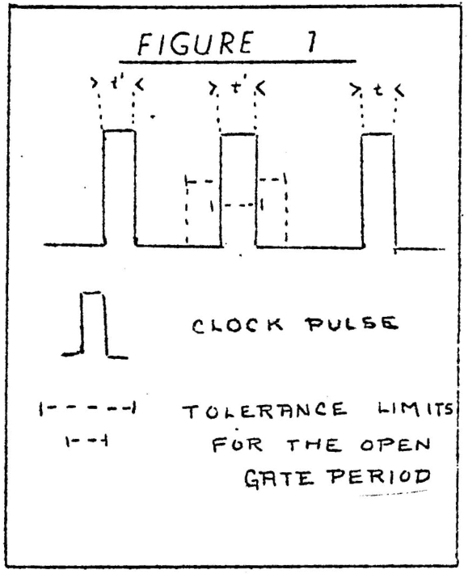

图 10.2： 时钟脉冲Figure 10.2: Clock pulses

## **10.12 存储器M的容量，一般原则****10.12 Capacity of the Memory M, General Principles**

### **10.12.1** 接下来我们考虑第三个具体部分：内存 M。……**10.12.1** We consider next the third specific part: the memory M. …

### **10.12.2** 然而，在这个讨论之前，我们必须考虑我们所期望的 M 的能力。它是这个器官可以记住的刺激的数量，或者更准确地说，它可以记住刺激是否存在的场合的数量。刺激的存在或不存在（在给定场合，即在给定时刻的给定线上）可用于表达二进制数字（在给定位置）的值1或0。因此，存储器的容量是它可以保留的二进制数字（值）的数量。换句话说：**10.12.2** Preceding this discussion, however, we must consider the capacity which we desire in M. It is the number of stimuli which this organ can remember, or more precisely, the number of occasions for which it can remember whether or not a stimulus was present. The presence or absence of a stimulus (at a given occasion, i.e. on a given line in a given moment) can be used to express the value 1 or 0 for a binary digit (in a given position). Hence the capacity of a memory is the number of binary digits (the values of) which it can retain. In other words:

*存储器的（容量）单位*是保留一位二进制数字的值的能力。The *(capacity) unit of memory* is the ability to retain the value of one binary digit.

我们现在可以表达这些记忆单元中各类信息的“成本”。We can now express the “cost” of various types of information in these memory units.

事实上，一个数字需要 32 个内存单元，因此建议以这种方式细分整个内存：首先，显然，细分为单元，其次细分为 32 个单元的组，称为*小循环*。……每个标准（实数）数相应地恰好占据一个小周期。如果存储器的所有其他常量也适合这种细分为小周期，则它简化了整个存储器的组织以及设备的各种同步问题。……The fact that a number requires 32 memory units, makes it advisable to subdivide the entire memory in this way: First, obviously, into units, second into groups of 32 units, to be called *minor cycles*. … Each standard (real) number accordingly occupies precisely one minor cycle. It simplifies the organization of the entire memory, and various synchronization problems of the device along with it, if all other constants of the memory are also made to fit into this subdivision into minor cycles. …

## **10.14 CC 和 M****10.14 CC and M**

### **10.14.1** 我们的下一个目标是更深入地分析CC。然而，这样的分析依赖于对用于控制设备的命令系统的精确了解，因为 CC 的功能是接收这些命令，解释它们，然后执行它们，或者适当地激励执行这些任务的机构。因此，我们当前的任务是提供控制设备的命令列表，即描述设备中使用的*代码，并定义其**码字*的数学和逻辑含义及其操作意义。**10.14.1** Our next aim is to go deeper into the analysis of CC. Such an analysis, however, is dependent upon a precise knowledge of the system of orders used in controlling the device, since the function of CC is to receive these orders, to interpret them, and then either to carry them out, or to stimulate properly those organs which will carry them out. It is therefore our immediate task to provide a list of the orders which control the device, i.e. to describe the *code* to be used in the device, and to define the mathematical and logical meaning and the operational significance of its *code words*.

在我们制定这个代码之前，我们必须对 CC 的功能及其与 M 的关系进行一些一般性的考虑。Before we can formulate this code, we must go through some general considerations concerning the functions of CC and its relation to M.

CC 收到的订单来自M，即来自存储数字材料的同一位置。(参见§ 10.2.4 … .) M 的内容由小循环…组成，因此根据上述，每个小循环必须包含一个区别标记，表明它是标准数还是顺序。The orders which are received by CC come from M, i.e. from the same place where the numerical material is stored. (Cf. §10.2.4 ….) The content of M consists of minor cycles …, hence by the above each minor cycle must contain a distinguishing mark which indicates whether it is a standard number or an order.

CC 收到的命令自然分为以下四类： (a) CC 指示 CA 执行其十项具体操作之一的命令……；(b) 命令CC将标准号码从一地转移到另一地；(c)命令CC将其与M的连接转移到M中的不同点，以便从那里获得下一个命令；(d) 控制设备输入和输出操作的命令（即第10.2.710.2.8节中的 O ）。The orders which CC receives fall naturally into these four classes: (a) orders for CC to instruct CA to carry out one of its ten specific operations …; (b) orders for CC to cause the transfer of a standard number from one place to another; (c) orders for CC to transfer its own connection with M to a different point in M, with the purpose of getting its next order from there; (d) orders controlling the operation of the input and the output of the device (i.e. I of §10.2.7 and O of §10.2.8).

现在让我们分别考虑这些类别 (a)–(d)。我们目前无法在……有关 (a) 的陈述中添加任何内容……。(d) 的讨论也最好推迟一下……。然而，我们建议现在讨论（b）和（c）。Let us now consider these classes (a)–(d) separately. We cannot at this time add anything to the statements … concerning (a) …. The discussion of (d) is also better delayed …. We propose, however, to discuss (b) and (c) now.

### **10.14.2** *Ad* (b)：这些传输可以发生在 M 内，或在 CA 内，或在 M 和 CA 之间。第一种总是可以用最后一种的两个操作来代替，即M内的所有传输都可以通过CA进行路由。我们建议这样做，因为这符合§ 10.5.6 …的一般原则，这样我们就消除了所有第一类转移。第二种转移显然是由 CA 的操作控制来处理的。因此，仅剩下最后一种。它们显然分为两类：从M到CA的传输和从CA到M的传输。我们可以相应地将(b)分解为(b′)和(b′′)，对应于这两个操作。**10.14.2** *Ad* (b): These transfers can occur within M, or within CA, or between M and CA. The first kind can always be replaced by two operations of the last kind, i.e. all transfers within M can be routed through CA. We propose to do this, since this is in accord with the general principle of §10.5.6 …, and in this way we eliminate all transfers of the first kind. Transfers of the second kind are obviously handled by the operating controls of CA. Hence those of the last kind alone remain. They fall obviously into two classes: Transfers from M to CA and transfers from CA to M. We may break up accordingly (b) into (b′) and (b′′), corresponding to these two operations.

### **10.14.3** *Ad* (c)：原则上，在每个订单之后，应指示 CC 在哪里找到要执行的下一个订单。然而，我们看到，这本身是不可取的，并且应该保留在特殊情况下，而作为正常例程，CC 应该遵守时间顺序中的顺序，其中它们自然地出现在 DLA 器官的输出处连接了哪个 CC（参见圣像镜存储器的相应讨论……）。然而，必须有可用的命令，可以在所提到的特殊情况下使用这些命令来指示 CC 将其连接转移到 M 中的任何其他所需点。这主要是将此连接转移到不同的 DLA 机构（即延迟线风琴……）。然而，由于实际想要的连接必须具有确定的小周期，因此所讨论的命令必须包含两个指令：首先，CC的连接将被转移到确定的DLA机构。其次，CC 将在那里等待，直到一个确定的 r 周期，在该 r 周期中，所需的小周期出现在该 DLA 的输出处，并且 CC 仅在此时接受订单。**10.14.3** *Ad* (c): In principle CC should be instructed, after each order, where to find the next order that it is to carry out. We saw, however, that this is undesirable per se, and that it should be reserved for exceptional occasions, while as a normal routine CC should obey the orders in the temporal sequence, in which they naturally appear at the output of the DLA organ to which CC is connected (cf. the corresponding discussion for the iconoscope memory …). There must, however, be orders available, which may be used at the exceptional occasions referred to, to instruct CC to transfer its connection to any other desired point in M. This is primarily a transfer of this connection to a different DLA organ (i.e. a delay line organ …). Since, however, the connection actually wanted must be with a definite minor cycle, the order in question must consist of two instructions: First, the connection of CC is to be transferred to a definite DLA organ. Second, CC is to wait there until a definite r-period, the one in which the desired minor cycle appears at the output of this DLA, and CC is to accept an order at this time only.

除此之外，这样的转移指令可能规定，在期望的小周期中接收并执行该指令后，CC应将其与包含转移指令的小周期之后的小周期的DLA机构返回其连接，等待直到这个小循环出现在输出处，然后继续以自然时间顺序接受从那里开始的订单。或者，在所需的小周期中接收并执行命令后，CC 应继续该连接，并在自然的时间内接受来自该连接的命令。时间顺序。*为了方便起见，将第一种类型的传输称为瞬时*传输，将第二种类型的传输称为*永久*传输。Apart from this, such a transfer order might provide that, after receiving and carrying out the order in the desired minor cycle, CC should return its connection to the DLA organ which contains the minor cycle that follows upon the one containing the transfer order, wait until this minor cycle appears at the output, and then continue to accept orders from there on in the natural temporal sequence. Alternatively, after receiving and carrying out the order in the desired minor cycle, CC should continue with that connection, and accept orders from there on in the natural temporal sequence. It is convenient to call a transfer of the first type a *transient* one, and one of the second type a *permanent* one.

## **10.15 准则****10.15 The Code**

### **10.15.1** 10.14的考虑为 M 的内容提供了完整分类的基础，即它们列举了一个连续的析取系统，这些系统将这个分类结合在一起。这种分类将使我们能够制定影响 CC 逻辑控制的代码，从而影响整个设备的逻辑控制。**10.15.1** The considerations of §10.14 provide the basis for a complete classification of the contents of M, i.e. they enumerate a system of successive disjunctions which give together this classification. This classification will put us into the position to formulate the code which effects the logical control of CC, and hence of the entire device.

因此，让我们重申相关的定义和析取。Let us therefore restate the pertinent definitions and disjunctions.

M 的内容是记忆单元，每个记忆单元都以刺激的存在或不存在为特征。它可以用来相应地表示二进制数字1或0，并且我们无论如何将通过它以这种方式对应的二进制数字*i* = 1或0来指定其内容。…这些单元组合在一起形成 32 个单元的小循环，这些小循环是在我们将介绍的代码中具有直接意义的实体。…我们用*i*<sub>0</sub> , *i*<sub>1</sub> , *i*<sub>2</sub> , … , *i*<sub>31</sub>表示组成小周期 32 个单位的二进制数字，按其自然时间顺序。这些单位的小循环可以写成*I* = ( *i*<sub>0</sub>*, i* <sub>1</sub>*, i* <sub>2</sub>*, … , i* <sub>31</sub> ) = ( *i*<sub>*v*</sub> )。The contents of M are the memory units, each one being characterized by the presence or absence of a stimulus. It can be used to represent accordingly the binary digit 1 or 0, and we will at any rate designate its content by the binary digit *i* = 1 or 0 to which it corresponds in this manner. …These units are grouped together to form 32-unit minor cycles, and these minor cycles are the entities which will acquire direct significance in the code which we will introduce. … We denote the binary digits which make up the 32 units of a minor cycle, in their natural temporal sequence, by *i*<sub>0</sub>, *i*<sub>1</sub>, *i*<sub>2</sub>, …, *i*<sub>31</sub>. The minor cycles with these units may be written *I* = (*i*<sub>0</sub>*, i*<sub>1</sub>*, i*<sub>2</sub>*, …, i*<sub>31</sub>) = (*i*<sub>*v*</sub>).

### **10.15.2** 一个标准数其余的 31 个单位表示其二进制数字和符号。所有算术运算的性质，特别是进位数字的作用，都要求参与运算的数的二进制数字必须从右向左送入，即位值最低的数字在先。（这是因为这些数字按时间先后出现，而非同时出现…。有关细节，在讨论加法器时最容易看清…。）符号起着最左侧数字，也就是最高位值数字的作用…。因此它最后出现，即 *i*<sub>31</sub> = 0 表示 + 号，*i*<sub>31</sub> = 1 表示 − 号。最后…，二进制小数点紧跟符号位之后，这样表示的数 *ξ* 必须按模 2 移入区间 − 1, 1。也就是说， ，− 1 ≤ *ξ <* 1。**10.15.2** The remaining 31 units of a standard number express its binary digits and its sign. It is in the nature of all arithmetical operations, specifically because of the role of carry digits, that the binary digits of the numbers which enter into them must be fed in from right to left, i.e. those with the lowest positional values first. (This is so because the digits appear in a temporal succession and not simultaneously…. The details are most simply evident in the discussion of the adder ….) The sign plays the role of the digit farthest left, i.e. of the highest positional value …. Hence it comes last, i.e. *i*<sub>31</sub> = 0 designates the + sign and *i*<sub>31</sub> = 1 the − sign. Finally … the binary point follows immediately after the sign digit, and the number *ξ* thus represented must be moved mod 2 into the interval − 1, 1. That is , − 1 ≤ *ξ <* 1.

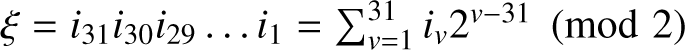

[figure not shown]

### **10.15.3** 另一方面，订单的其余 31 个单位必须表达该订单的性质。这些命令在第10.14.1节中分为四类 (a)–(d)，并进一步细分……。[编辑：图 10.3以表格形式显示了订单。]**10.15.3** The remaining 31 units of an order, on the other hand, must express the nature of this order. The orders were classified in §10.14.1 into four classes (a)–(d), and these were subdivided further …. [EDITOR: Figure 10.3 shows the orders in tabular form.]

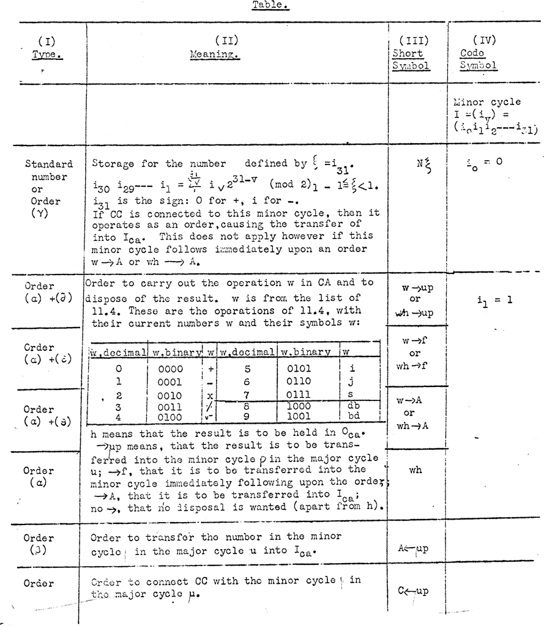

图 10.3： EDVAC“命令”初稿（说明）Figure 10.3: First draft EDVAC “orders” (instructions)

1. 经电气和电子工程师协会许可，转载自冯·诺依曼 (1993)。Reprinted from von Neumann (1993), with permission from the Institute for Electrical and Electronics Engineers.

# **11**

# 诚如所思（1945）**As We May Think (1945)**

## **万尼瓦尔·布什****Vannevar Bush**

在麻省理工学院教授工程学期间，Vannevar Bush（1890-1974）建造了一台称为*微分分析仪*的模拟计算机，用于求解微分方程。以现代标准来看，这是一个笨拙的设备，大部分是机械设备，只有一些电气元件，但它确实有效。1936 年，布什聘请克劳德·香农 (Claude Shannon) 作为研究助理来运行该设备，这次经历让香农系统地思考了开关电路，并促成了他著名的硕士论文（第 8 章）。布什转向考虑信息存储和检索。受最近扩大的缩微胶卷商业用途（《*纽约时报》*于 1935 年开始以缩微形式出版）的影响，布什将他在 1945 年这篇预言性文章中描述的设备想象为模*因转换器*。微电影也同样启发了科幻作家 HG Wells (1938)。他写道：“现在，为所有人类知识、思想和成就创建一个有效的索引，即为全人类创建一个完整的地球记忆，已经不存在任何实际障碍了。” ……整个人类记忆可以而且可能在很短的时间内为每个人提供。”While teaching engineering at MIT, Vannevar Bush (1890–1974) built an analog computer called a *differential analyzer* for solving differential equations. It was a clumsy device by modern standards, mostly mechanical with a few electrical components, but it worked. Bush hired Claude Shannon as a research assistant in 1936 to run the device, an experience that got Shannon thinking systematically about switching circuits and led to his famous Master’s thesis (chapter 8). Bush turned to thinking about information storage and retrieval. Influenced by the recently expanded commercial use of microfilm (the *New York Times* began publishing in microform in 1935), Bush imagined the device he describes in this prophetic 1945 article as a *memex*. Microfilm had similarly inspired science fiction writer H. G. Wells (1938). “There is no practical obstacle whatever now,” he wrote, “to the creation of an efficient index to all human knowledge, ideas and achievements, to the creation, that is, of a complete planetary memory for all mankind. …The whole human memory can be, and probably in a short time will be, made accessible to every individual.”

相比之下，布什是以工程师的身份写作的，而不仅仅是普通的工程师。第二次世界大战期间，他曾担任科学研究与发展办公室主任，协调美国科学界援助战争的努力。例如，他非常了解哈佛大学的艾肯 Mark I，以及作为曼哈顿计划的一部分来设计原子武器所进行的困难计算。这篇文章发表的时间与布什向杜鲁门总统提交《科学，无尽的前沿》（布什，1945c）有关，这是一份关于科学未来的报告，该报告导致了国家科学基金会的成立。*布什在《大西洋月刊》*上发表了这篇文章，不久之后又在*《生活》* （Bush，1945b）中以缩写和戏剧性插图的形式发表了这篇文章，作为他努力增加公众对科学研究的支持的一部分。Bush, by contrast, was writing as an engineer, and not just any engineer. He had served as Director of the Office of Scientific Research and Development during World War II, marshaling the American scientific community’s efforts to aid the war effort. He was well aware, for example, of Aiken’s Mark I at Harvard and of the difficult computations done as part of the Manhattan Project to design an atomic weapon. This article appeared about the same time as Bush submitted to President Truman “Science, the Endless Frontier” (Bush, 1945c), a report on the future of science that led to the creation of the National Science Foundation. Bush published this piece in the *Atlantic*—and soon after in abbreviated and dramatically illustrated form in *Life* (Bush, 1945b)—as part of his effort to increase public support for scientific research.

布什在这里询问科学可以为人类的和平未来做出什么贡献，并提出了即时、无处不在、关联信息检索的愿景。当时可用的存储介质无法支持这样的成就——这篇文章仅因其对可用计算和存储技术的回顾以及对其改进的预测而令人着迷——但从那时起，他的功能愿景启发了许多电子系统。Bush here asks what science can contribute to the peaceful future of humankind, and offers in response a vision of instantaneous, ubiquitous, associative information retrieval. The storage media available at the time could not support such an achievement—the article is fascinating just for its review of the available computing and storage technologies and the projections for their improvement—but his functional vision has inspired many an electronic system since then.

这不是一场科学家的战争；这是一场科学家的战争。这是一场所有人都参与的战争。科学家们将过去的职业竞争埋葬在共同事业的需求中，分享了很多东西，学到了很多东西。能够以有效的伙伴关系开展工作是令人兴奋的。现在，对于许多人来说，这似乎即将结束。科学家接下来要做什么？对于生物学家，特别是对于医学科学家来说，几乎没有优柔寡断的余地，因为他们的战争几乎不需要他们离开旧的道路。许多人确实能够在他们熟悉的和平时期实验室中进行战争研究。他们的目标基本相同。THIS has not been a scientist’s war; it has been a war in which all have had a part. The scientists, burying their old professional competition in the demand of a common cause, have shared greatly and learned much. It has been exhilarating to work in effective partnership. Now, for many, this appears to be approaching an end. What are the scientists to do next? For the biologists, and particularly for the medical scientists, there can be little indecision, for their war has hardly required them to leave the old paths. Many indeed have been able to carry on their war research in their familiar peacetime laboratories. Their objectives remain much the same.

物理学家们的步伐受到了最猛烈的冲击，他们放弃了学术追求，转而制造奇怪的破坏性装置，他们不得不为他们意想不到的任务设计新的方法。他们在能够击退敌人的设备上尽了自己的一份力量，并与我们盟友的物理学家共同努力。他们内心感受到了成就的激动。他们是一支伟大团队的一部分。现在，随着和平的临近，人们会问，他们在哪里才能找到最值得实现的目标。It is the physicists who have been thrown most violently off stride, who have left academic pursuits for the making of strange destructive gadgets, who have had to devise new methods for their unanticipated assignments. They have done their part on the devices that made it possible to turn back the enemy, have worked in combined effort with the physicists of our allies. They have felt within themselves the stir of achievement. They have been part of a great team. Now, as peace approaches, one asks where they will find objectives worthy of their best.

## **11.1**

人类对科学和他的研究带来的新仪器的使用有什么持久的好处？首先，他们增强了他对物质环境的控制。他们改善了他的食物、衣服和住所；他们增强了他的安全感，使他部分地摆脱了赤裸裸的存在的束缚。他们让他对自己的生物过程有了更多的了解，从而逐渐摆脱疾病的困扰，并延长了寿命。它们阐明了他的生理和心理功能的相互作用，有望改善他的心理健康。科学提供了人与人之间最快捷的沟通；它提供了思想记录，并使人类能够操纵该记录并从中进行摘录，以便知识在整个种族而不是个人的一生中不断发展和延续。研究成果不断涌现。但越来越多的证据表明，随着专业化的扩展，我们今天正陷入困境。调查员对数千名其他工作人员的发现和结论感到震惊——他没有时间去理解这些结论，更不用说记住这些结论了。然而，专业化对于进步变得越来越必要，而在学科之间建立桥梁的努力相应地是肤浅的。Of what lasting benefit has been man’s use of science and of the new instruments which his research brought into existence? First, they have increased his control of his material environment. They have improved his food, his clothing, his shelter; they have increased his security and released him partly from the bondage of bare existence. They have given him increased knowledge of his own biological processes so that he has had a progressive freedom from disease and an increased span of life. They are illuminating the interactions of his physiological and psychological functions, giving the promise of an improved mental health. Science has provided the swiftest communication between individuals; it has provided a record of ideas and has enabled man to manipulate and to make extracts from that record so that knowledge evolves and endures throughout the life of a race rather than that of an individual. There is a growing mountain of research. But there is increased evidence that we are being bogged down today as specialization extends. The investigator is staggered by the findings and conclusions of thousands of other workers—conclusions which he cannot find time to grasp, much less to remember, as they appear. Yet specialization becomes increasingly necessary for progress, and the effort to bridge between disciplines is correspondingly superficial.

从专业角度来说，我们传播和审查研究结果的方法已经有几代人的历史了，但迄今为止完全不足以达到其目的。如果可以评估撰写学术著作和阅读学术著作所花费的总时间，那么这些时间之间的比例很可能会令人震惊。那些认真地试图通过仔细和持续的阅读来跟上当前思想的人，即使是在有限的领域，很可能会回避一项旨在显示上个月的努力有多少可以随叫随到的考试。孟德尔的遗传学定律概念在一代人的时间里被世人遗忘了，因为他的出版物没有被少数有能力掌握和扩展它的人所接受。和这种毫无疑问，灾难正在我们周围重演，因为真正重要的成就被淹没在大量无关紧要的事情中。Professionally our methods of transmitting and reviewing the results of research are generations old and by now are totally inadequate for their purpose. If the aggregate time spent in writing scholarly works and in reading them could be evaluated, the ratio between these amounts of time might well be startling. Those who conscientiously attempt to keep abreast of current thought, even in restricted fields, by close and continuous reading might well shy away from an examination calculated to show how much of the previous month’s efforts could be produced on call. Mendel’s concept of the laws of genetics was lost to the world for a generation because his publication did not reach the few who were capable of grasping and extending it; and this sort of catastrophe is undoubtedly being repeated all about us, as truly significant attainments become lost in the mass of the inconsequential.

困难似乎并不在于我们鉴于当今兴趣的范围和多样性而过度出版，而是出版已经远远超出了我们目前真正利用记录的能力。人类经验的总结正在以惊人的速度扩展，我们用来穿过随后的迷宫到达暂时重要的物品的手段与方帆船舶时代所使用的手段相同。但随着新的、强大的工具的投入使用，出现了变化的迹象。能够从物理意义上看到事物的光电管，能够记录所见甚至未见事物的先进摄影术，能够在比蚊子振动翅膀所用的功率更少的功率引导下控制强大力量的热电子管，阴极射线管渲染可见，事件如此短暂，相比之下，一微秒就是很长的时间，继电器组合将比任何人类操作员更可靠地执行所涉及的运动序列，并且速度快数千倍——有大量的机械辅助工具可以用来实现转换在科学记录中。The difficulty seems to be, not so much that we publish unduly in view of the extent and variety of present day interests, but rather that publication has been extended far beyond our present ability to make real use of the record. The summation of human experience is being expanded at a prodigious rate, and the means we use for threading through the consequent maze to the momentarily important item is the same as was used in the days of square-rigged ships. But there are signs of a change as new and powerful instrumentalities come into use. Photocells capable of seeing things in a physical sense, advanced photography which can record what is seen or even what is not, thermionic tubes capable of controlling potent forces under the guidance of less power than a mosquito uses to vibrate his wings, cathode ray tubes rendering visible an occurrence so brief that by comparison a microsecond is a long time, relay combinations which will carry out involved sequences of movements more reliably than any human operator and thousands of times as fast—there are plenty of mechanical aids with which to effect a transformation in scientific records.

两个世纪前，莱布尼茨发明了一台计算机，它体现了现代键盘设备的大部分基本特征，但当时它无法投入使用。这种情况的经济学是不利的：在大规模生产之前，建造它所涉及的劳动力超过了它的使用所节省的劳动力，因为它所能完成的一切都可以通过充分使用铅笔和纸来复制。而且，它会经常发生故障，因此不能被依赖；因为在当时和之后很长一段时间里，复杂性和不可靠性是同义词。Two centuries ago Leibniz invented a calculating machine which embodied most of the essential features of recent keyboard devices, but it could not then come into use. The economics of the situation were against it: the labor involved in constructing it, before the days of mass production, exceeded the labor to be saved by its use, since all it could accomplish could be duplicated by sufficient use of pencil and paper. Moreover, it would have been subject to frequent breakdown, so that it could not have been depended upon; for at that time and long after, complexity and unreliability were synonymous.

巴贝奇即使在他的时代得到了非常慷慨的支持，也无法生产出他伟大的算术机器。他的想法很合理，但建造和维护成本太高了。如果法老得到了详细而明确的汽车设计，并且他完全理解了这些设计，那么为一辆汽车制造数千个零件就会耗费他王国的资源，而那辆汽车就会在不久的将来抛锚。第一次去吉萨。Babbage, even with remarkably generous support for his time, could not produce his great arithmetical machine. His idea was sound enough, but construction and maintenance costs were then too heavy. Had a Pharaoh been given detailed and explicit designs of an automobile, and had he understood them completely, it would have taxed the resources of his kingdom to have fashioned the thousands of parts for a single car, and that car would have broken down on the first trip to Giza.

现在可以非常经济地建造具有可互换零件的机器。尽管很复杂，但它们的性能可靠。看看不起眼的打字机、电影摄影机或汽车。当彻底理解后，电触点就不再粘连了。请注意自动电话交换机，它有数十万个这样的联系人，但仍然可靠。密封在薄玻璃容器中的金属蜘蛛网，加热到发出耀眼光芒的电线，简而言之，收音机的热电子管，是由亿万个制成的，在包装中扔来扔去，插入插座中 - 并且它可以工作！它的游丝部件，以及其建造过程中涉及的精确位置和对齐方式，需要行会的工匠大师花费数月的时间；现在它的建造成本为三十美分。世界已经进入了一个廉价复杂设备具有极高可靠性的时代。必然会有一些结果。Machines with interchangeable parts can now be constructed with great economy of effort. In spite of much complexity, they perform reliably. Witness the humble typewriter, or the movie camera, or the automobile. Electrical contacts have ceased to stick when thoroughly understood. Note the automatic telephone exchange, which has hundreds of thousands of such contacts, and yet is reliable. A spider web of metal, sealed in a thin glass container, a wire heated to brilliant glow, in short, the thermionic tube of radio sets, is made by the hundred million, tossed about in packages, plugged into sockets—and it works! Its gossamer parts, the precise location and alignment involved in its construction, would have occupied a master craftsman of the guild for months; now it is built for thirty cents. The world has arrived at an age of cheap complex devices of great reliability; and something is bound to come of it.

## **11.2**

记录如果要对科学有用，就必须不断扩展，必须存储，最重要的是必须可供查阅。今天，我们传统上通过书写和摄影来记录，然后是印刷；但我们也在胶片、蜡盘和磁线上进行记录。即使没有出现全新的记录程序，现有的这些程序也肯定处于修改和扩展的过程中。A record if it is to be useful to science, must be continuously extended, it must be stored, and above all it must be consulted. Today we make the record conventionally by writing and photography, followed by printing; but we also record on film, on wax disks, and on magnetic wires. Even if utterly new recording procedures do not appear, these present ones are certainly in the process of modification and extension.

当然，摄影的进步不会停止。Certainly progress in photography is not going to stop.

更快的材料和镜头、更自动的相机、更细粒度的敏感化合物以允许扩展微型相机的想法，这些都迫在眉睫。让我们将这一趋势预测为一个合乎逻辑的（即使不是不可避免的）结果。未来的相机猎手额头上有一个比核桃稍大的肿块。它拍摄3毫米见方的照片，然后进行投影或放大，毕竟只涉及到目前实践的10倍。该镜头具有通用焦距，可达到肉眼所能容纳的任何距离，仅仅是因为它的焦距较短。胡桃木上有一个内置光电管，就像我们现在至少在一台相机上一样，它可以自动调整曝光以适应各种照明。胡桃木内装有可进行一百次曝光的胶片，插入胶片夹后，操作快门和移动胶片的弹簧就一次上紧。它以全彩形式产生结果。它很可能是立体的，并用两个间隔开的玻璃眼睛进行记录，因为立体技术的显着改进指日可待。Faster material and lenses, more automatic cameras, finer-grained sensitive compounds to allow an extension of the minicamera idea, are all imminent. Let us project this trend ahead to a logical, if not inevitable, outcome. The camera hound of the future wears on his forehead a lump a little larger than a walnut. It takes pictures 3 millimeters square, later to be projected or enlarged, which after all involves only a factor of 10 beyond present practice. The lens is of universal focus, down to any distance accommodated by the unaided eye, simply because it is of short focal length. There is a built-in photocell on the walnut such as we now have on at least one camera, which automatically adjusts exposure for a wide range of illumination. There is film in the walnut for a hundred exposures, and the spring for operating its shutter and shifting its film is wound once for all when the film clip is inserted. It produces its result in full color. It may well be stereoscopic, and record with two spaced glass eyes, for striking improvements in stereoscopic technique are just around the corner.

触发百叶窗的绳子可能会伸到人的袖子里，他的手指就能轻松够到。快速挤压，照片就拍好了。一副普通眼镜的镜片顶部附近有一条方形细纹，该细纹不妨碍普通视力。当一个物体出现在那个方块中时，它就会按照它的图片排列起来。当未来的科学家在实验室或现场走动时，每当他看到一些值得记录的东西时，他都会按下快门，然后将其放入，甚至没有听到咔嗒声。这一切都太棒了吗？它唯一奇妙的地方是可以通过使用它来制作尽可能多的图片。The cord which trips its shutter may reach down a man’s sleeve within easy reach of his fingers. A quick squeeze, and the picture is taken. On a pair of ordinary glasses is a square of fine lines near the top of one lens, where it is out of the way of ordinary vision. When an object appears in that square, it is lined up for its picture. As the scientist of the future moves about the laboratory or the field, every time he looks at something worthy of the record, he trips the shutter and in it goes, without even an audible click. Is this all fantastic? The only fantastic thing about it is the idea of making as many pictures as would result from its use.

会有干摄影吗？它已经以两种形式出现了。当布雷迪拍摄内战照片时，曝光时底版必须是湿的。现在在开发过程中它必须是湿的。将来也许根本不需要弄湿它。长期以来，存在着用重氮染料浸渍的胶片，其无需显影即可形成图像，因此只要相机被操作，图像就已经存在。暴露在氨气中会破坏未曝光的染料，然后可以将照片取出到光线下进行检查。这个过程现在很慢，但有人可能会加快它的速度，而且它不存在像现在让摄影研究人员忙碌的颗粒困难。通常，能够拍摄相机并立即查看照片是有利的。Will there be dry photography? It is already here in two forms. When Brady made his Civil War pictures, the plate had to be wet at the time of exposure. Now it has to be wet during development instead. In the future perhaps it need not be wetted at all. There have long been films impregnated with diazo dyes which form a picture without development, so that it is already there as soon as the camera has been operated. An exposure to ammonia gas destroys the unexposed dye, and the picture can then be taken out into the light and examined. The process is now slow, but someone may speed it up, and it has no grain difficulties such as now keep photographic researchers busy. Often it would be advantageous to be able to snap the camera and to look at the picture immediately.

现在使用的另一个过程也很慢，而且或多或少有些笨拙。五十年来一直使用浸渍纸，由于纸中包含的碘化合物产生化学变化，在电接触接触到它们的每个点处都会变黑。它们被用来做记录，因为指针在它们上面移动会留下痕迹。如果指针上的电位随着其移动而变化，则线条根据电位变亮或变暗。Another process now in use is also slow, and more or less clumsy. For fifty years impregnated papers have been used which turn dark at every point where an electrical contact touches them, by reason of the chemical change thus produced in an iodine compound included in the paper. They have been used to make records, for a pointer moving across them can leave a trail behind. If the electrical potential on the pointer is varied as it moves, the line becomes light or dark in accordance with the potential.

该方案现在用于传真传输。指针在纸上一条一条地画出一组间隔很近的线。当它移动时，它的电势会根据从远处站通过电线接收到的变化电流而变化，这些变化是由类似地扫描图片的光电管产生的。在每一瞬间，所画线的暗度都等于光电管观察到的图片上点的暗度。因此，当整个图片被覆盖时，接收端就会出现一个副本。……This scheme is now used in facsimile transmission. The pointer draws a set of closely spaced lines across the paper one after another. As it moves, its potential is varied in accordance with a varying current received over wires from a distant station, where these variations are produced by a photocell which is similarly scanning a picture. At every instant the darkness of the line being drawn is made equal to the darkness of the point on the picture being observed by the photocell. Thus, when the whole picture has been covered, a replica appears at the receiving end. …

与干摄影一样，显微摄影还有很长的路要走。…假设线性比率为 100 以供将来使用。考虑与纸张厚度相同的薄膜，尽管更薄的薄膜当然也可以使用。即使在这些条件下，大部分普通书籍记录与其缩微胶卷复制品之间的总因数仍为 10,000。*大英百科全书*可以缩小到火柴盒的大小。一个拥有一百万册图书的图书馆可以压缩到一张桌子的一端。如果自从活字印刷术发明以来，人类已经以杂志、报纸、书籍、小册子、广告简介、信件的形式制作了一份总记录，其卷数相当于十亿本书，那么整个事件，经过组装和压缩，可以用移动货车拖走。当然，仅仅压缩是不够的。不仅要制作、保存记录，还要能够查阅，这方面的事情以后再说。即使是现代的大型图书馆也不被普遍查阅；它被一些人啃食。Like dry photography, microphotography still has a long way to go. …Assume a linear ratio of 100 for future use. Consider film of the same thickness as paper, although thinner film will certainly be usable. Even under these conditions there would be a total factor of 10,000 between the bulk of the ordinary record on books, and its microfilm replica. The *Encyclopedia Britannica* could be reduced to the volume of a matchbox. A library of a million volumes could be compressed into one end of a desk. If the human race has produced since the invention of movable type a total record, in the form of magazines, newspapers, books, tracts, advertising blurbs, correspondence, having a volume corresponding to a billion books, the whole affair, assembled and compressed, could be lugged off in a moving van. Mere compression, of course, is not enough; one needs not only to make and store a record but also be able to consult it, and this aspect of the matter comes later. Even the modern great library is not generally consulted; it is nibbled at by a few.

然而，就成本而言，压缩很重要。《大英百科全书》的微缩胶卷的材料成本为五分钱，而且只要一美分就可以邮寄到任何地方。印刷一百万份需要花费多少钱？打印一张大版报纸的成本仅为一美分的一小部分。《大英百科全书》的全部材料以缩微胶卷的形式呈现在一张八又二分之一乘十一英寸的纸上。一旦可用，通过未来的照相复制方法，大批量复制品的价格可能会超出材料成本，每件一美分。准备原件吗？这就介绍了该主题的下一个方面。Compression is important, however, when it comes to costs. The material for the microfilm Britannica would cost a nickel, and it could be mailed anywhere for a cent. What would it cost to print a million copies? To print a sheet of newspaper, in a large edition, costs a small fraction of a cent. The entire material of the Britannica in reduced microfilm form would go on a sheet eight and one-half by eleven inches. Once it is available, with the photographic reproduction methods of the future, duplicates in large quantities could probably be turned out for a cent apiece beyond the cost of materials. The preparation of the original copy? That introduces the next aspect of the subject.

## **11.3**

为了进行记录，我们现在按下铅笔或敲击打字机。然后是消化和修正的过程，然后是复杂的排版、印刷和分发过程。考虑到该程序的第一阶段，未来的作者是否会停止用手或打字机书写并直接与记录对话？他通过与速记员或蜡筒交谈来间接做到这一点；但如果他希望他的演讲直接产生打印记录，那么这些要素都存在。他需要做的就是利用现有的机制并改变他的语言。To make the record, we now push a pencil or tap a typewriter. Then comes the process of digestion and correction, followed by an intricate process of typesetting, printing, and distribution. To consider the first stage of the procedure, will the author of the future cease writing by hand or typewriter and talk directly to the record? He does so indirectly, by talking to a stenographer or a wax cylinder; but the elements are all present if he wishes to have his talk directly produce a typed record. All he needs to do is to take advantage of existing mechanisms and to alter his language.

在最近的一次世界博览会上，展示了一种称为语音合成器的机器。一个女孩敲击了它的按键，它发出了可辨认的语言。在任何时候都没有人类声带参与该过程；这些按键只是结合了一些电力产生的振动，并将这些振动传递到扬声器。在贝尔实验室有一种与此相反的机器，称为声码器。扬声器被麦克风取代，麦克风拾取声音。对它说话，相应的键就会移动。这可能是假定系统的要素之一。At a recent World Fair a machine called a Voder was shown. A girl stroked its keys and it emitted recognizable speech. No human vocal chords entered into the procedure at any point; the keys simply combined some electrically produced vibrations and passed these on to a loud-speaker. In the Bell Laboratories there is the converse of this machine, called a Vocoder. The loudspeaker is replaced by a microphone, which picks up sound. Speak to it, and the corresponding keys move. This may be one element of the postulated system.

另一个要素是速记，这是公共会议上经常遇到的有点令人不安的装置。一个女孩懒洋洋地敲击着琴键，环视房间，有时用令人不安的目光看着扬声器。从中出现一条打印条，以语音简化的语言记录了说话者应该说的话。后来，这条条带被重新打印成普通语言，因为在它的新生形式中，只有入门者才能理解。将这两个元素结合起来，让声码器运行速记，结果就是一台在与人交谈时会打字的机器。The other element is found in the stenotype, that somewhat disconcerting device encountered usually at public meetings. A girl strokes its keys languidly and looks about the room and sometimes at the speaker with a disquieting gaze. From it emerges a typed strip which records in a phonetically simplified language a record of what the speaker is supposed to have said. Later this strip is retyped into ordinary language, for in its nascent form it is intelligible only to the initiated. Combine these two elements, let the Vocoder run the stenotype, and the result is a machine which types when talked to.

确实，我们现在的语言并不是特别适应这种机械化。奇怪的是，通用语言的发明者并没有抓住创造一种更适合传输和记录语音技术的语言的想法。机械化可能会迫使这个问题发生，特别是在科学领域；因此，科学术语对于外行来说将变得更加难以理解。Our present languages are not especially adapted to this sort of mechanization, it is true. It is strange that the inventors of universal languages have not seized upon the idea of producing one which better fitted the technique for transmitting and recording speech. Mechanization may yet force the issue, especially in the scientific field; whereupon scientific jargon would become still less intelligible to the layman.

人们现在可以想象一位未来的调查员在他的实验室里。他的双手是自由的，他没有被固定。当他四处走动和观察时，他会拍照和评论。时间会自动记录，将两个记录联系在一起。如果他进入现场，他可以通过无线电连接到他的录音机。晚上，当他思考笔记时，他再次将自己的评论记录下来。他的打字记录和他的照片都可能是微型的，以便他将它们投影以供检查。One can now picture a future investigator in his laboratory. His hands are free, and he is not anchored. As he moves about and observes, he photographs and comments. Time is automatically recorded to tie the two records together. If he goes into the field, he may be connected by radio to his recorder. As he ponders over his notes in the evening, he again talks his comments into the record. His typed record, as well as his photographs, may both be in miniature, so that he projects them for examination.

然而，在数据和观察的收集、从现有记录中提取平行材料以及最终将新材料插入到共同记录的总体中之间需要发生很多事情。对于成熟的思想来说，没有机械的替代品。但创造性思维和本质上的重复性思维是非常不同的事情。对于后者，存在并且可能存在强大的机械辅助装置。Much needs to occur, however, between the collection of data and observations, the extraction of parallel material from the existing record, and the final insertion of new material into the general body of the common record. For mature thought there is no mechanical substitute. But creative thought and essentially repetitive thought are very different things. For the latter there are, and may be, powerful mechanical aids.

添加一列数字是一个重复的思维过程，很久以前它就被正确地归咎于机器。诚然，机器有时是由键盘控制的，在读取数字并按下相应的键时会产生某种想法，但即使这样也是可以避免的。机器已经被制造出来，可以通过光电管读取键入的数字，然后按下相应的键；这些是用于扫描类型的光电管、用于对随后的变化进行分类的电路以及用于将结果解释为螺线管的动作以拉下按键的继电器电路的组合。Adding a column of figures is a repetitive thought process, and it was long ago properly relegated to the machine. True, the machine is sometimes controlled by a keyboard, and thought of a sort enters in reading the figures and poking the corresponding keys, but even this is avoidable. Machines have been made which will read typed figures by photocells and then depress the corresponding keys; these are combinations of photocells for scanning the type, electric circuits for sorting the consequent variations, and relay circuits for interpreting the result into the action of solenoids to pull the keys down.

所有这些复杂的事情都是需要的，因为我们学会了书写数字的笨拙方式。如果我们简单地通过卡片上一组点的配置来记录它们的位置，自动读取机制将变得相对简单。事实上，如果这些点是孔，我们就有 Hollerith 很久以前生产的用于人口普查的打孔卡机，现在在整个商业中使用。如果没有这些机器，某些类型的复杂企业几乎无法运营。All this complication is needed because of the clumsy way in which we have learned to write figures. If we recorded them positionally, simply by the configuration of a set of dots on a card, the automatic reading mechanism would become comparatively simple. In fact if the dots are holes, we have the punched-card machine long ago produced by Hollerith for the purposes of the census, and now used throughout business. Some types of complex businesses could hardly operate without these machines.

添加只是一项操作。执行算术计算还涉及减法、乘法和除法，此外还涉及一些临时存储结果、从存储中取出以进行进一步操作以及通过打印记录最终结果的方法。用于这些目的的机器现在有两种类型：用于会计等的键盘机，手动控制插入数据，并且就操作顺序而言通常自动控制；打孔卡机通常将单独的操作委托给一系列机器，然后将卡片从一台机器转移到另一台机器。两种形式都非常有用；但就复杂计算而言，两者仍处于萌芽状态。Adding is only one operation. To perform arithmetical computation involves also subtraction, multiplication, and division, and in addition some method for temporary storage of results, removal from storage for further manipulation, and recording of final results by printing. Machines for these purposes are now of two types: keyboard machines for accounting and the like, manually controlled for the insertion of data, and usually automatically controlled as far as the sequence of operations is concerned; and punched-card machines in which separate operations are usually delegated to a series of machines, and the cards then transferred bodily from one to another. Both forms are very useful; but as far as complex computations are concerned, both are still in embryo.

在物理学家发现计算宇宙射线是可取的之后不久，快速电子计数就出现了。为了自己的目的，物理学家立即建造了能够以每秒 100,000 次的速度计算电脉冲的热电子管设备。未来的先进算术机器本质上将是电动的，它们的运行速度将是现在的 100 倍，甚至更高。Rapid electrical counting appeared soon after the physicists found it desirable to count cosmic rays. For their own purposes the physicists promptly constructed thermionic-tube equipment capable of counting electrical impulses at the rate of 100,000 a second. The advanced arithmetical machines of the future will be electrical in nature, and they will perform at 100 times present speeds, or more.

此外，它们将比现有的商用机器更加通用，因此可以轻松适应各种操作。它们将由控制卡或胶片控制，它们将选择自己的数据并根据插入的指令对其进行操作，它们将以极高的速度执行复杂的算术计算，并以以下形式记录结果：易于分发或供以后进一步操作。这样的机器将会有巨大的需求。其中一个将从一屋子女孩那里获取指令和数据，这些女孩配备了简单的键盘，并每隔几分钟提供计算结果表。在数百万人做复杂事情的详细事务中，总会有大量的事情需要计算。Moreover, they will be far more versatile than present commercial machines, so that they may readily be adapted for a wide variety of operations. They will be controlled by a control card or film, they will select their own data and manipulate it in accordance with the instructions thus inserted, they will perform complex arithmetical computations at exceedingly high speeds, and they will record results in such form as to be readily available for distribution or for later further manipulation. Such machines will have enormous appetites. One of them will take instructions and data from a whole roomful of girls armed with simple key board punches, and will deliver sheets of computed results every few minutes. There will always be plenty of things to compute in the detailed affairs of millions of people doing complicated things.

## **11.4**

然而，重复的思维过程并不局限于算术和统计问题。事实上，每当人们按照既定的逻辑过程组合和记录事实时，思维的创造性方面只涉及数据的选择和所采用的过程，而其后的操作本质上是重复性的，因此是合适的事情被降级为机器。沿着这些思路，除了算术的界限之外，还没有做太多的事情，而主要是由于经济形势的原因，可能会做更多的事情。一旦生产方法足够先进，商业需求和广阔的市场显然在等待，保证了大规模生产的算术机器的出现。The repetitive processes of thought are not confined however, to matters of arithmetic and statistics. In fact, every time one combines and records facts in accordance with established logical processes, the creative aspect of thinking is concerned only with the selection of the data and the process to be employed and the manipulation thereafter is repetitive in nature and hence a fit matter to be relegated to the machine. Not so much has been done along these lines, beyond the bounds of arithmetic, as might be done, primarily because of the economics of the situation. The needs of business and the extensive market obviously waiting, assured the advent of mass-produced arithmetical machines just as soon as production methods were sufficiently advanced.

对于高级分析机器来说，这种情况就不存在了；因为无论过去还是现在都不存在广阔的市场；使用先进数据处理方法的用户只是人口中的一小部分。然而，有一些机器可以求解微分方程以及函数方程和积分方程。有许多特殊的机器，例如预测潮汐的谐波合成器。还会有更多，肯定首先出现在科学家手中，而且数量很少。With machines for advanced analysis no such situation existed; for there was and is no extensive market; the users of advanced methods of manipulating data are a very small part of the population. There are, however, machines for solving differential equations—and functional and integral equations, for that matter. There are many special machines, such as the harmonic synthesizer which predicts the tides. There will be many more, appearing certainly first in the hands of the scientist and in small numbers.

如果科学推理仅限于算术的逻辑过程，那么我们对物理世界的理解就不会走得太远。人们不妨尝试完全通过使用概率数学来掌握扑克游戏。算盘的珠子串在平行的电线上，使阿拉伯人比世界其他地区早几个世纪就掌握了位置计数和零的概念。它是一个有用的工具——非常有用，以至于它仍然存在。If scientific reasoning were limited to the logical processes of arithmetic, we should not get far in our understanding of the physical world. One might as well attempt to grasp the game of poker entirely by the use of the mathematics of probability. The abacus, with its beads strung on parallel wires, led the Arabs to positional numeration and the concept of zero many centuries before the rest of the world; and it was a useful tool—so useful that it still exists.

这与算盘和现代键盘记账机相差甚远。这将是迈向未来算术机器的同等一步。但即使是这台新机器也无法将科学家带到他需要去的地方。如果高等数学的使用者想要将他们的大脑解放出来，去做一些比按照既定规则进行重复的详细转换更多的事情，那么就必须从对高等数学的繁琐的详细操作中获得解脱。数学家不是一个可以轻易操纵数字的人；他常常做不到。他甚至不是一个能够轻易地用微积分进行方程变换的人。他主要是一个善于在高层次上使用符号逻辑的人，尤其是他在选择他所采用的操作过程时具有直觉判断力。It is a far cry from the abacus to the modern keyboard accounting machine. It will be an equal step to the arithmetical machine of the future. But even this new machine will not take the scientist where he needs to go. Relief must be secured from laborious detailed manipulation of higher mathematics as well, if the users of it are to free their brains for something more than repetitive detailed transformations in accordance with established rules. A mathematician is not a man who can readily manipulate figures; often he cannot. He is not even a man who can readily perform the transformations of equations by the use of calculus. He is primarily an individual who is skilled in the use of symbolic logic on a high plane, and especially he is a man of intuitive judgment in the choice of the manipulative processes he employs.

他应该能够将所有其他事情交给他的机械装置，就像他将汽车的推进交给引擎盖下的复杂机械装置一样自信。只有这样，数学才能真正有效地将不断增长的原子学知识有效地解决化学、冶金和生物学的高级问题。出于这个原因，仍然有更多的机器来为科学家处理高级数学。其中一些非常奇特，足以满足当今文明文物最挑剔的鉴赏家的需求。All else he should be able to turn over to his mechanism, just as confidently as he turns over the propelling of his car to the intricate mechanism under the hood. Only then will mathematics be practically effective in bringing the growing knowledge of atomistics to the useful solution of the advanced problems of chemistry, metallurgy, and biology. For this reason there still come more machines to handle advanced mathematics for the scientist. Some of them will be sufficiently bizarre to suit the most fastidious connoisseur of the present artifacts of civilization.

## **11.5**

然而，科学家并不是唯一一个通过使用逻辑过程来操纵数据和检查他周围的世界的人，尽管他有时通过采用任何变得有逻辑性的人来保留这种外观，就像英国人的方式一样。劳工领袖被提升为爵士。每当采用思维的逻辑过程时——也就是说，每当思维沿着公认的轨道运行时——机器就有机会。形式逻辑曾经是教师手中试探学生灵魂的利器。只需巧妙地使用继电器电路，就可以很容易地构造一台能够根据形式逻辑操纵前提的机器。The scientist, however, is not the only person who manipulates data and examines the world about him by the use of logical processes, although he sometimes preserves this appearance by adopting into the fold anyone who becomes logical, much in the manner in which a British labor leader is elevated to knighthood. Whenever logical processes of thought are employed—that is, whenever thought for a time runs along an accepted groove—there is an opportunity for the machine. Formal logic used to be a keen instrument in the hands of the teacher in his trying of students’ souls. It is readily possible to construct a machine which will manipulate premises in accordance with formal logic, simply by the clever use of relay circuits.

将一组前提放入这样的设备中并转动曲柄，它会很容易地得出一个又一个的结论，所有这些都符合逻辑定律，并且不会比键盘加法机预期的更多错误。[编辑：与第 8 页比较。]Put a set of premises into such a device and turn the crank, and it will readily pass out conclusion after conclusion, all in accordance with logical law, and with no more slips than would be expected of a keyboard adding machine. [EDITOR: Compare to page 8.]

逻辑可能变得非常困难，毫无疑问，在使用逻辑时提供更多保证会更好。用于高级分析的机器通常是方程求解器。方程变换器的想法开始出现，它将根据严格且相当先进的逻辑重新排列方程所表达的关系。数学家表达其关系的极其粗糙的方式阻碍了进步。他们使用的象征主义与托普西一样，缺乏一致性。在这个最符合逻辑的领域里，这是一个奇怪的事实。Logic can become enormously difficult, and it would undoubtedly be well to produce more assurance in its use. The machines for higher analysis have usually been equation solvers. Ideas are beginning to appear for equation transformers, which will rearrange the relationship expressed by an equation in accordance with strict and rather advanced logic. Progress is inhibited by the exceedingly crude way in which mathematicians express their relationships. They employ a symbolism which grew like Topsy and has little consistency; a strange fact in that most logical field.

显然，一种新的象征主义（可能是位置象征主义）必须先于将数学变换简化为机器过程。然后，超越数学家的严格逻辑，就是逻辑在日常事务中的应用。有一天，我们可能会在一台机器上结束争论，就像我们现在在收银机上输入销售数据一样。但逻辑机器看起来不会像收银机，即使是精简模型也是如此。A new symbolism, probably positional, must apparently precede the reduction of mathematical transformations to machine processes. Then, on beyond the strict logic of the mathematician, lies the application of logic in everyday affairs. We may some day click off arguments on a machine with the same assurance that we now enter sales on a cash register. But the machine of logic will not look like a cash register, even of the streamlined model.

关于想法的操纵和将它们插入记录就到此为止了。到目前为止，我们的情况似乎比以前更糟——因为我们可以极大地扩大记录；然而，即使就目前的规模而言，我们也很难查阅它。这不仅仅是为了科学研究目的而提取数据的问题。它涉及人类通过继承所获得的知识而获利的整个过程。使用的主要行为是选择，但在这里我们确实停下来了。可能有数百万个美好的想法，以及它们所基于的经验的描述，都被封装在可接受的建筑形式的石墙内；但如果学者通过勤奋的搜索每周只能得到一篇，那么他的综合就不可能跟上当前的情况。So much for the manipulation of ideas and their insertion into the record. Thus far we seem to be worse off than before—for we can enormously extend the record; yet even in its present bulk we can hardly consult it. This is a much larger matter than merely the extraction of data for the purposes of scientific research; it involves the entire process by which man profits by his inheritance of acquired knowledge. The prime action of use is selection, and here we are halting indeed. There may be millions of fine thoughts, and the account of the experience on which they are based, all encased within stone walls of acceptable architectural form; but if the scholar can get at only one a week by diligent search, his syntheses are not likely to keep up with the current scene.

广义上的选择，就是木工手中的石锛。然而，从狭义上讲，在其他领域，选择已经机械地做了一些事情。一家工厂的人事官员将一叠几千张员工卡放入选择机中，按照既定惯例设置代码，并在短时间内生成一份居住在特伦顿且懂西班牙语的所有员工的名单。即使是这样的设备，例如将一组指纹与存档的 500 万个指纹进行匹配时也太慢了。此类选择设备很快就会从目前每分钟数百次的数据审查速度加快。通过使用光电管和缩微胶卷，他们将以每秒一千次的速度调查物品，并打印出所选物品的副本。Selection, in this broad sense, is a stone adze in the hands of a cabinetmaker. Yet, in a narrow sense and in other areas, something has already been done mechanically on selection. The personnel officer of a factory drops a stack of a few thousand employee cards into a selecting machine, sets a code in accordance with an established convention, and produces in a short time a list of all employees who live in Trenton and know Spanish. Even such devices are much too slow when it comes, for example, to matching a set of fingerprints with one of five million on file. Selection devices of this sort will soon be speeded up from their present rate of reviewing data at a few hundred a minute. By the use of photocells and microfilm they will survey items at the rate of a thousand a second, and will print out duplicates of those selected.

然而，这个过程是简单的选择：它通过依次检查一大组项目中的每一个项目，并挑选出具有某些特定特征的项目来进行。还有另一种选择形式，最好的例子就是自动电话交换机。您拨打一个号码，机器就会选择并连接一百万个可能的电台中的一个。它并没有涵盖所有这些。它仅关注由第一个数字给出的类，然后仅关注由第二个数字给出的该类的子类，依此类推；从而快速且几乎准确无误地到达选定的车站。做出选择需要几秒钟的时间，但如果经济上可以保证提高速度，则可以加快该过程。如有必要，可以通过用热电子管开关代替机械开关来使其速度极快，从而可以在百分之一秒内完成完整的选择。没有人愿意花费必要的钱来对电话系统进行这种改变，但总体想法适用于其他地方。This process, however, is simple selection: it proceeds by examining in turn every one of a large set of items, and by picking out those which have certain specified characteristics. There is another form of selection best illustrated by the automatic telephone exchange. You dial a number and the machine selects and connects just one of a million possible stations. It does not run over them all. It pays attention only to a class given by a first digit, then only to a subclass of this given by the second digit, and so on; and thus proceeds rapidly and almost unerringly to the selected station. It requires a few seconds to make the selection, although the process could be speeded up if increased speed were economically warranted. If necessary, it could be made extremely fast by substituting thermionic-tube switching for mechanical switching, so that the full selection could be made in one one-hundredth of a second. No one would wish to spend the money necessary to make this change in the telephone system, but the general idea is applicable elsewhere.

以大型百货商店的平淡问题为例。每次进行收费销售时，都有很多事情要做。库存需要修改，销售人员需要获得销售信用，一般账户需要录入，最重要的是，需要向客户收费。已经开发了一个中央记录设备，其中大部分工作很方便地完成。推销员将顾客的身份证、他自己的卡以及从所售商品中取出的卡放在架子上——所有这些都是打孔卡。当他拉动杠杆时，通过孔进行接触，中心点的机械进行必要的计算和输入，并打印正确的收据以供销售员传递给客户。Take the prosaic problem of the great department store. Every time a charge sale is made, there are a number of things to be done. The inventory needs to be revised, the salesman needs to be given credit for the sale, the general accounts need an entry, and, most important, the customer needs to be charged. A central records device has been developed in which much of this work is done conveniently. The salesman places on a stand the customer’s identification card, his own card, and the card taken from the article sold—all punched cards. When he pulls a lever, contacts are made through the holes, machinery at a central point makes the necessary computations and entries, and the proper receipt is printed for the salesman to pass to the customer.

但可能有一万个收费客户与商店做生意，在完成全部操作之前，必须有人选择正确的卡并将其插入中央办公室。现在，快速选择可以在一两瞬间将正确的卡片滑入到位，然后将其返回。然而，另一个困难出现了。必须有人读取卡上的总计，以便机器可以将其计算的项目添加到其中。可以想象，这些卡片可能属于我所描述的干摄影类型。然后可以通过光电管读取现有的总数，并通过电子束输入新的总数。But there may be ten thousand charge customers doing business with the store, and before the full operation can be completed someone has to select the right card and insert it at the central office. Now rapid selection can slide just the proper card into position in an instant or two, and return it afterward. Another difficulty occurs, however. Someone must read a total on the card, so that the machine can add its computed item to it. Conceivably the cards might be of the dry photography type I have described. Existing totals could then be read by photocell, and the new total entered by an electron beam.

这些卡片可能是微型的，因此它们占用的空间很小。他们必须迅速行动。它们不需要被转移很远，而只需转移到适当的位置，以便光电管和记录器可以对它们进行操作。位置点可以输入数据。到月底，机器就可以轻松地读取这些信息并打印普通账单。通过管选择，开关中不涉及机械部件，只需很少的时间即可将正确的卡投入使用——整个操作一秒钟就足够了。如果需要的话，卡上的整个记录可以由钢板上的磁点制成，而不是通过光学观察的点，遵循波尔森很久以前在磁线上放置语音的方案。该方法具有简单、易于擦除的优点。然而，通过使用摄影，人们可以利用电视设备中常见的过程以放大的形式在远处投影该记录。The cards may be in miniature, so that they occupy little space. They must move quickly. They need not be transferred far, but merely into position so that the photocell and recorder can operate on them. Positional dots can enter the data. At the end of the month a machine can readily be made to read these and to print an ordinary bill. With tube selection, in which no mechanical parts are involved in the switches, little time need be occupied in bringing the correct card into use—a second should suffice for the entire operation. The whole record on the card may be made by magnetic dots on a steel sheet if desired, instead of dots to be observed optically, following the scheme by which Poulsen long ago put speech on a magnetic wire. This method has the advantage of simplicity and ease of erasure. By using photography, however one can arrange to project the record in enlarged form and at a distance by using the process common in television equipment.

人们可以考虑快速选择这种形式，并将远距离投影用于其他目的。能够在操作员面前在一两秒内键入一百万张纸，然后可以在其中添加注释，这在很多方面都具有启发性。它甚至可能在图书馆中有用，但那是另一回事了。无论如何，现在可能出现一些有趣的组合。例如，人们可以以结合语音控制打字机描述的方式对着麦克风说话，从而做出他的选择。它肯定会击败普通的档案管理员。One can consider rapid selection of this form, and distant projection for other purposes. To be able to key one sheet of a million before an operator in a second or two, with the possibility of then adding notes thereto, is suggestive in many ways. It might even be of use in libraries, but that is another story. At any rate, there are now some interesting combinations possible. One might, for example, speak to a microphone, in the manner described in connection with the speech controlled typewriter, and thus make his selections. It would certainly beat the usual file clerk.

## **11.6**

然而，选择问题的真正核心不仅仅是图书馆采用机制的滞后，或者缺乏可供其使用的设备的开发。我们在获取记录方面的无能很大程度上是由于索引系统的人为性造成的。当任何类型的数据放入存储中时，它们都会按字母或数字顺序归档，并且通过从子类到子类追踪来找到信息（如果有）。它只能位于一处，除非使用重复项；必须有规则来确定哪条路径将找到它，而这些规则很麻烦。此外，找到一件物品后，就必须从系统中出来，重新进入一条新的道路。The real heart of the matter of selection, however, goes deeper than a lag in the adoption of mechanisms by libraries, or a lack of development of devices for their use. Our ineptitude in getting at the record is largely caused by the artificiality of systems of indexing. When data of any sort are placed in storage, they are filed alphabetically or numerically, and information is found (when it is) by tracing it down from subclass to subclass. It can be in only one place, unless duplicates are used; one has to have rules as to which path will locate it, and the rules are cumbersome. Having found one item, moreover, one has to emerge from the system and re-enter on a new path.

人类的思维并不是这样运作的。它通过协会运作。当它抓住一件物品时，它会根据大脑细胞所携带的某种复杂的轨迹网，立即捕捉到由思想联想所暗示的下一件物品。当然，它还有其他特征；不经常遵循的踪迹很容易消失，物品不是完全永久的，记忆是短暂的。然而，行动的速度、轨迹的错综复杂、脑海中画面的细节，都比自然界中的其他一切更令人惊叹。The human mind does not work that way. It operates by association. With one item in its grasp, it snaps instantly to the next that is suggested by the association of thoughts, in accordance with some intricate web of trails carried by the cells of the brain. It has other characteristics, of course; trails that are not frequently followed are prone to fade, items are not fully permanent, memory is transitory. Yet the speed of action, the intricacy of trails, the detail of mental pictures, is awe-inspiring beyond all else in nature.

人类不能完全希望人为地复制这种心理过程，但他当然应该能够从中学习。他甚至可能在一些小方面有所进步，因为他的记录相对来说是永久性的。然而，从类比中得出的第一个想法涉及选择。通过关联而不是索引进行选择可能仍会被机械化。因此，我们不能指望能够与大脑追随联想轨迹的速度和灵活性相媲美，但在从存储中复活的物品的持久性和清晰度方面，应该可以果断地击败大脑。Man cannot hope fully to duplicate this mental process artificially, but he certainly ought to be able to learn from it. In minor ways he may even improve, for his records have relative permanency. The first idea, however, to be drawn from the analogy concerns selection. Selection by association, rather than indexing, may yet be mechanized. One cannot hope thus to equal the speed and flexibility with which the mind follows an associative trail, but it should be possible to beat the mind decisively in regard to the permanence and clarity of the items resurrected from storage.

考虑未来供个人使用的设备，它是一种机械化的私人文件和图书馆。它需要一个名字，随便造一个名字，“memex”就可以了。memex 是一种个人存储所有书籍、记录和通讯的设备，并且是机械化的，因此可以以超快的速度和灵活性进行查阅。这是对他记忆的扩大的亲密补充。Consider a future device for individual use, which is a sort of mechanized private file and library. It needs a name, and, to coin one at random, “memex” will do. A memex is a device in which an individual stores all his books, records, and communications, and which is mechanized so that it may be consulted with exceeding speed and flexibility. It is an enlarged intimate supplement to his memory.

它由一张桌子组成，虽然它可能可以远距离操作，但它主要是他工作的家具。顶部是倾斜的半透明屏幕，可以将材料投影在屏幕上，方便阅读。有一个键盘、一组按钮和控制杆。否则它看起来就像一张普通的桌子。It consists of a desk, and while it can presumably be operated from a distance, it is primarily the piece of furniture at which he works. On the top are slanting translucent screens, on which material can be projected for convenient reading. There is a keyboard, and sets of buttons and levers. Otherwise it looks like an ordinary desk.

一端是存储的材料。改进的缩微胶卷很好地解决了体积问题。麦麦克斯内部只有一小部分用于存储，其余部分用于机械装置。然而，如果用户每天插入 5000 页材料，他将需要数百年才能填满存储库，因此他可以随意输入材料。In one end is the stored material. The matter of bulk is well taken care of by improved microfilm. Only a small part of the interior of the memex is devoted to storage, the rest to mechanism. Yet if the user inserted 5000 pages of material a day it would take him hundreds of years to fill the repository, so he can be profligate and enter material freely.

大多数 memex 内容都是以缩微胶片形式购买的，可以随时插入。各种书籍、图片、最新期刊、报纸就这样被获取并放置到位。商务信函也走同样的道路。并且有直接进入的规定。memex 的顶部是一个透明的压板。上面放着手写笔记、照片、备忘录和各种各样的东西。当其中一个就位时，按下控制杆即可将其拍摄到模因胶片的一部分中的下一个空白区域，采用干式摄影。当然，可以通过通常的索引方案来查询记录。如果用户想要查阅某本书，他在键盘上敲击该书的代码，该书的扉页立即出现在他面前，投影到他的一个观看位置。常用的密码很容易记忆，所以他很少查阅密码本；但当他这样做时，只需轻按一个键即可将其投射出来供他使用。此外，他还有补充杠杆。当他将其中一个杠杆向右偏转时，他会浏览面前的书，每一页依次以仅允许一眼认出每一页的速度投影。如果他将球进一步向右偏转，他就会迈步一次浏览这本书 10 页；更进一步，一次100页。向左偏转给了他同样的向后控制能力。Most of the memex contents are purchased on microfilm ready for insertion. Books of all sorts, pictures, current periodicals, newspapers, are thus obtained and dropped into place. Business correspondence takes the same path. And there is provision for direct entry. On the top of the memex is a transparent platen. On this are placed longhand notes, photographs, memoranda, all sorts of things. When one is in place, the depression of a lever causes it to be photographed onto the next blank space in a section of the memex film, dry photography being employed. There is, of course, provision for consultation of the record by the usual scheme of indexing. If the user wishes to consult a certain book, he taps its code on the keyboard, and the title page of the book promptly appears before him, projected onto one of his viewing positions. Frequently-used codes are mnemonic, so that he seldom consults his code book; but when he does, a single tap of a key projects it for his use. Moreover, he has supplemental levers. On deflecting one of these levers to the right he runs through the book before him, each page in turn being projected at a speed which just allows a recognizing glance at each. If he deflects it further to the right, he steps through the book 10 pages at a time; still further at 100 pages at a time. Deflection to the left gives him the same control backwards.

一个特殊的按钮可以立即将他转到索引的第一页。因此，他的图书馆中的任何一本书都可以比从书架上取出来更方便地调用和查阅。由于他有多个投影位置，因此他可以将一个项目留在原位，同时调用另一个项目。他可以利用一种可能的干摄影类型来添加旁注和评论，甚至可以进行安排，以便他可以通过手写笔方案来完成此操作，例如现在在铁路候车室中看到的电话记录仪中使用的方法，只是就好像他面前有实体页面一样。A special button transfers him immediately to the first page of the index. Any given book of his library can thus be called up and consulted with far greater facility than if it were taken from a shelf. As he has several projection positions, he can leave one item in position while he calls up another. He can add marginal notes and comments, taking advantage of one possible type of dry photography, and it could even be arranged so that he can do this by a stylus scheme, such as is now employed in the telautograph seen in railroad waiting rooms, just as though he had the physical page before him.

## **11.7**

所有这些都是传统的，除了当今机制和小工具的向前发展。然而，它为关联索引提供了直接的步骤，其基本思想是可以使任何项目随意立即自动选择另一个项目。这是memex 的基本特征。将两个物品绑在一起的过程很重要。All this is conventional, except for the projection forward of present-day mechanisms and gadgetry. It affords an immediate step, however, to associative indexing, the basic idea of which is a provision whereby any item may be caused at will to select immediately and automatically another. This is the essential feature of the memex. The process of tying two items together is the important thing.

当用户构建路径时，他会为其命名，将名称插入其密码本中，然后在键盘上敲击它。在他面前是要连接的两个项目，投影到相邻的观看位置。每个项目的底部都有许多空白代码空间，并且设置了一个指针来指示每个项目上的其中一个。用户点击一个键，项目就会永久连接。在每个代码空间中出现码字。在代码空间之外的视图之外，插入了一组用于光电管查看的点；在每个项目上，这些点按其位置指定其他项目的索引号。When the user is building a trail, he names it, inserts the name in his code book, and taps it out on his keyboard. Before him are the two items to be joined, projected onto adjacent viewing positions. At the bottom of each there are a number of blank code spaces, and a pointer is set to indicate one of these on each item. The user taps a single key, and the items are permanently joined. In each code space appears the code word. Out of view, but also in the code space, is inserted a set of dots for photocell viewing; and on each item these dots by their positions designate the index number of the other item.

此后，在任何时候，当这些项目之一出现在视图中时，只需点击相应代码空间下方的按钮即可立即调用另一个项目。此外，当许多项目如此连接在一起形成一条轨迹时，可以通过像用于翻书页那样偏转杠杆来快速或缓慢地依次查看它们。就好像这些物理物品是从分散的来源收集在一起并装订在一起形成一本新书一样。不仅如此，任何项目都可以连接成许多路径。Thereafter, at any time, when one of these items is in view, the other can be instantly recalled merely by tapping a button below the corresponding code space. Moreover, when numerous items have been thus joined together to form a trail, they can be reviewed in turn, rapidly or slowly, by deflecting a lever like that used for turning the pages of a book. It is exactly as though the physical items had been gathered together from widely separated sources and bound together to form a new book. It is more than this, for any item can be joined into numerous trails.

可以说，模因的所有者对弓箭的起源和特性感兴趣。具体来说，他正在研究为什么土耳其短弓在十字军东征的小冲突中明显优于英国长弓。他的模因中有数十本可能相关的书籍和文章。首先，他浏览了一本百科全书，找到一篇有趣但粗略的文章，然后将其投影出来。接下来，在历史中，他找到了另一个相关项目，并将两者联系在一起。他就这样走着，建立了一条由许多物品组成的踪迹。有时，他会插入自己的评论，要么将其链接到主路径中，要么通过旁路将其连接到特定项目。当很明显可用材料的弹性特性与弓有很大关系时，他又开始了一条小路，这带他浏览了有关弹性的教科书和表格物理常数。他插入了一页他自己的手写分析。因此，他通过他可用的材料迷宫建立了一条他的兴趣轨迹。The owner of the memex, let us say, is interested in the origin and properties of the bow and arrow. Specifically he is studying why the short Turkish bow was apparently superior to the English long bow in the skirmishes of the Crusades. He has dozens of possibly pertinent books and articles in his memex. First he runs through an encyclopedia, finds an interesting but sketchy article, leaves it projected. Next, in a history, he finds another pertinent item, and ties the two together. Thus he goes, building a trail of many items. Occasionally he inserts a comment of his own, either linking it into the main trail or joining it by a side trail to a particular item. When it becomes evident that the elastic properties of available materials had a great deal to do with the bow, he branches off on a side trail which takes him through textbooks on elasticity and tables of physical constants. He inserts a page of longhand analysis of his own. Thus he builds a trail of his interest through the maze of materials available to him.

而他的足迹也不会消失。几年后，他与一位朋友的谈话转向了人们抵制创新的奇怪方式，即使是至关重要的创新。他有一个例子，事实上，愤怒的欧洲人仍然没有采用土耳其弓。事实上他有踪迹。触摸即可调出密码本。点击几个按键即可投射出路线的头部。一根杠杆可以随意穿过它，停在有趣的物品上，或者去进行一些短途旅行。这是一条有趣的线索，与讨论相关。因此，他设置了一个运行中的复制器，拍摄整个踪迹，并将其传递给他的朋友，以便插入到他自己的模因中，在那里链接到更一般的踪迹。And his trails do not fade. Several years later, his talk with a friend turns to the queer ways in which a people resist innovations, even of vital interest. He has an example, in the fact that the outraged Europeans still failed to adopt the Turkish bow. In fact he has a trail on it. A touch brings up the code book. Tapping a few keys projects the head of the trail. A lever runs through it at will, stopping at interesting items, going off on side excursions. It is an interesting trail, pertinent to the discussion. So he sets a reproducer in action, photographs the whole trail out, and passes it to his friend for insertion in his own memex, there to be linked into the more general trail.

## **11.8**

全新形式的百科全书将会出现，已经准备好，其中有贯穿其中的一系列关联路径，准备好放入模因并在那里放大。律师可以接触到他的整个经历以及朋友和当局的经历的相关意见和决定。专利律师随时待命数以百万计的已授权专利，并熟悉客户感兴趣的每一点。医生对病人的反应感到困惑，于是沿着研究早期类似病例时建立的线索，快速浏览类似的病例史，并侧面参考相关解剖学和组织学的经典著作。化学家正在努力合成一种有机化合物，他的实验室里摆满了所有的化学文献，其中有化合物类比的线索，以及它们的物理和化学行为的侧面线索。Wholly new forms of encyclopedias will appear, ready made with a mesh of associative trails running through them, ready to be dropped into the memex and there amplified. The lawyer has at his touch the associated opinions and decisions of his whole experience, and of the experience of friends and authorities. The patent attorney has on call the millions of issued patents, with familiar trails to every point of his client’s interest. The physician, puzzled by a patient’s reactions, strikes the trail established in studying an earlier similar case, and runs rapidly through analogous case histories, with side references to the classics for the pertinent anatomy and histology. The chemist, struggling with the synthesis of an organic compound, has all the chemical literature before him in his laboratory, with trails following the analogies of compounds, and side trails to their physical and chemical behavior.

历史学家对一个民族进行了大量按时间顺序的记述，将其与只停在显着项目上的跳跃轨迹平行，并且可以随时追踪当代轨迹，这些轨迹引导他了解特定时代的文明。开拓者是一种新的职业，他们乐于通过大量的共同记录建立有用的道路。大师的遗产不仅成为他对世界记录的补充，而且对他的弟子来说，成为他们搭建的整个脚手架。The historian, with a vast chronological account of a people, parallels it with a skip trail which stops only on the salient items, and can follow at any time contemporary trails which lead him all over civilization at a particular epoch. There is a new profession of trail blazers, those who find delight in the task of establishing useful trails through the enormous mass of the common record. The inheritance from the master becomes, not only his additions to the world’s record, but for his disciples the entire scaffolding by which they were erected.

因此，科学可以实现人类生产、存储和查阅种族记录的方式。更引人注目地勾勒出未来的工具，而不是像这里所做的那样，严格遵守现在已知并正在快速发展的方法和元素，可能会令人震惊。当然，各种各样的技术难题都被忽视了，但也忽视了那些未知的手段，这些手段可能会像热电子管的出现一样猛烈地加速技术进步。为了使图片不会太普遍，由于坚持当今的模式，最好提及这样一种可能性，不是预言，而只是暗示，因为基于已知延伸的预言具有实质内容，而建立在未知之上的预言只是一种双重猜测。Thus science may implement the ways in which man produces, stores, and consults the record of the race. It might be striking to outline the instrumentalities of the future more spectacularly, rather than to stick closely to methods and elements now known and undergoing rapid development, as has been done here. Technical difficulties of all sorts have been ignored, certainly, but also ignored are means as yet unknown which may come any day to accelerate technical progress as violently as did the advent of the thermionic tube. In order that the picture may not be too commonplace, by reason of sticking to present-day patterns, it may be well to mention one such possibility, not to prophesy but merely to suggest, for prophecy based on extension of the known has substance, while prophecy founded on the unknown is only a doubly involved guess.

我们创造或吸收记录材料的所有步骤都是通过一种感官进行的——我们触摸按键时的触觉，我们说或听时的口头，我们阅读时的视觉。难道有一天这条路就不能建立得更直接吗？我们知道当眼睛看到时，所有随之而来的信息都会通过视神经通道中的电振动传输到大脑。这与电视机电缆中发生的电振动进行了精确的类比：它们将图像从光电管传送到无线电发射器，并从该无线电发射器进行广播。我们进一步知道，如果我们能够使用适当的仪器接近该电缆，我们就不需要触摸它；我们可以通过电感应拾取这些振动，从而发现并再现正在传输的场景，就像窃听电话线以获取其消息一样。打字员手臂神经中流动的脉冲将翻译后的信息传递到她的手指，这些信息到达她的眼睛或耳朵，以便手指可以敲击正确的键。这些电流可能不会被拦截，无论是以信息传递到大脑的原始形式，还是以它们随后传递到手的奇妙变形形式？All our steps in creating or absorbing material of the record proceed through one of the senses—the tactile when we touch keys, the oral when we speak or listen, the visual when we read. Is it not possible that some day the path may be established more directly? We know that when the eye sees, all the consequent information is transmitted to the brain by means of electrical vibrations in the channel of the optic nerve. This is an exact analogy with the electrical vibrations which occur in the cable of a television set: they convey the picture from the photocells which see it to the radio transmitter from which it is broadcast. We know further that if we can approach that cable with the proper instruments, we do not need to touch it; we can pick up those vibrations by electrical induction and thus discover and reproduce the scene which is being transmitted, just as a telephone wire may be tapped for its message. The impulses which flow in the arm nerves of a typist convey to her fingers the translated information which reaches her eye or ear, in order that the fingers may be caused to strike the proper keys. Might not these currents be intercepted, either in the original form in which information is conveyed to the brain, or in the marvelously metamorphosed form in which they then proceed to the hand?

通过骨传导，我们已经将声音引入聋人的神经通道，以便他们能够听到声音。我们是否有可能学会引入它们，而不需要首先将电振动转换为机械振动，然后人体机制立即将其转换回电形式？通过头骨上的几个电极，脑描记器现在可以产生笔墨痕迹，这些痕迹与大脑本身发生的电现象有一定的关系。诚然，这个记录是难以理解的，除非它指出了大脑机制的某些严重故障。但现在谁会对这样的事情可能导致的结果设定界限呢？By bone conduction we already introduce sounds: into the nerve channels of the deaf in order that they may hear. Is it not possible that we may learn to introduce them without the present cumbersomeness of first transforming electrical vibrations to mechanical ones, which the human mechanism promptly transforms back to the electrical form? With a couple of electrodes on the skull the encephalograph now produces pen-and-ink traces which bear some relation to the electrical phenomena going on in the brain itself. True, the record is unintelligible, except as it points out certain gross misfunctioning of the cerebral mechanism; but who would now place bounds on where such a thing may lead?

在外面的世界中，所有形式的智能，无论是声音还是视觉，都被简化为电路中变化电流的形式，以便可以传输。在人体内部也会发生完全相同的过程。为了从一种电现象转变为另一种电现象，我们必须始终转变为机械运动吗？这是一个有启发性的想法，但它很难保证在不脱离现实和即时性的情况下进行预测。In the outside world, all forms of intelligence whether of sound or sight, have been reduced to the form of varying currents in an electric circuit in order that they may be transmitted. Inside the human frame exactly the same sort of process occurs. Must we always transform to mechanical movements in order to proceed from one electrical phenomenon to another? It is a suggestive thought, but it hardly warrants prediction without losing touch with reality and immediateness.

想必，如果人能更好地回顾自己的黑幕，更全面、更客观地分析自己现在的问题，他的精神应该得到提升。他已经建立了一个如此复杂的文明，如果他想要将他的实验推向合乎逻辑的结论，他就需要更充分地机械化他的记录，而不是仅仅因为过度消耗他有限的记忆而陷入半途中的困境。如果他能重新获得忘记手头不需要的各种东西的特权，并且保证如果它们很重要，他可以再次找到它们，那么他的旅行可能会更愉快。Presumably man’s spirit should be elevated if he can better review his shady past and analyze more completely and objectively his present problems. He has built a civilization so complex that he needs to mechanize his records more fully if he is to push his experiment to its logical conclusion and not merely become bogged down part way there by overtaxing his limited memory. His excursions may be more enjoyable if he can reacquire the privilege of forgetting the manifold things he does not need to have immediately at hand, with some assurance that he can find them again if they prove important.

科学的应用为人类建造了一座供应充足的房屋，并教导人们在其中健康地生活。它们使他能够用残酷的武器让大批人互相攻击。它们可能会让他真正拥有伟大的记录，并在比赛经验的智慧中成长。在他学会利用这一记录来谋取真正的利益之前，他可能会在冲突中丧生。然而，在将科学应用于人类的需要和欲望时，似乎是一个非常不幸的阶段，在这个阶段终止这个过程，或者对结果失去希望。The applications of science have built man a well-supplied house, and are teaching him to live healthily therein. They have enabled him to throw masses of people against one another with cruel weapons. They may yet allow him truly to encompass the great record and to grow in the wisdom of race experience. He may perish in conflict before he learns to wield that record for his true good. Yet, in the application of science to the needs and desires of man, it would seem to be a singularly unfortunate stage at which to terminate the process, or to lose hope as to the outcome.

1. 经《*大西洋*月刊》内容机构许可，转载自 Bush (1945a) 。Reprinted from Bush (1945a), with permission from Tribune Content Agency—*The Atlantic*.

# **12**

# 通信的数学理论（1948）**A Mathematical Theory of Communication (1948)**

## **克劳德·香农****Claude Shannon**

在写完重要的硕士论文（第 8 章）后，克劳德·香农 (Claude Shannon) 开发了一种用于孟德尔遗传学计算的代数，并于 1940 年将其作为博士论文提交。随后，他转到贝尔实验室，并在这篇论文中发明了信息论。二进制记数法的优点众所周知；EDVAC 团队已决定使用二进制来存储所有内部存储和算术。《初稿》明确指出，“*存储器的（容量）单位*是保留一个二进制数字的值的能力”（本卷第103页）。香农将这个单位称为“比特”，这一著名说法是由数学家约翰·图基发明的。然后，香农提出了当并非所有消息都可能或同样可能时如何用相对较少的比特数对长消息进行编码的问题。这项工作不仅是数据压缩理论及其限制（霍夫曼编码，例如[Huffman，1952]）的基础，而且是当消息位在从源到目的地的传输过程中可能被损坏时重建消息的重要理论的基础（见第 13 章）。现在常用的术语“熵”是从统计物理学借用的，用来表示源信息内容的度量。After writing his important Master’s thesis (chapter 8), Claude Shannon developed an algebra for computations in Mendelian genetics, submitting it as his PhD dissertation in 1940. He then moved to Bell Labs and, in this paper, invented information theory. The advantages of binary notation were already known; the EDVAC team had settled on binary for all internal storage and arithmetic. The “First Draft” states unequivocally, “The *(capacity) unit of memory* is the ability to retain the value of one binary digit” (page 103 of this volume). Shannon famously dubs that unit the “bit,” though attributes the coinage to mathematician John Tukey. Shannon then pursues the question of how to encode long messages with a relatively small number of bits when not all messages may be possible or equally likely. This work is the basis not only for the theory of data compression and its limits (Huffman codes, for example [Huffman, 1952]) but for the important theory of reconstruction of messages when their bits may be corrupted in transit from source to destination (see chapter 13). The term “entropy,” now in common usage, is here borrowed from statistical physics to represent a measure of the information content of a source.

香农后来出版了第三部杰作《保密系统的通信理论》（Shannon，1949），从信息论的角度阐述了密码学的一些原理。这是基于他根据贝尔实验室和美国军方之间的合同所做的机密工作。香农于 1958 年回到麻省理工学院担任教授，长期以来一直是个顽皮的修补匠。他杂耍、骑独轮车，有时两者同时进行。他建造了一台机器，可以对机械鼠标进行杂耍和编程，让它学习走出迷宫的路径。Shannon later published a third masterpiece, “Communication Theory of Secrecy Systems” (Shannon, 1949), which laid out some of the principles of cryptography from an information-theoretic viewpoint. It was based on classified work he had done under a contract between Bell Labs and the U.S. military. Shannon returned to MIT as a professor in 1958 and long remained the playful tinkerer. He juggled, rode a unicycle, and sometimes did both simultaneously. He built a machine that juggled and programmed a mechanical mouse to learn its path out of a maze.

他最终在数学方面的成就下降，并停止出版和教学，最终于 2001 年因阿尔茨海默病去世，享年 84 岁。He eventually became less prolific mathematically and stopped publishing and teaching, finally dying in 2001 of Alzheimer’s disease at the age of 84.

## **12.0 简介****12.0 Introduction**

最近各种调制方法的发展，例如用带宽换取信噪比的 PCM 和 PPM，增强了人们对一般通信理论的兴趣。[编辑：脉冲编码调制和脉冲位置调制。] 这种理论的基础包含在 Nyquist (1924, 1928) 和 Hartley (1928) 关于这个主题的重要论文中。在本文中，我们将扩展该理论以包括许多新因素，特别是信道中噪声的影响，以及由于原始消息的统计结构和信息最终目的地的性质而可能实现的节省。THE recent development of various methods of modulation such as PCM and PPM which exchange bandwidth for signal-to-noise ratio has intensified the interest in a general theory of communication. [EDITOR: Pulse Code Modulation and Pulse Position Modulation.] A basis for such a theory is contained in the important papers of Nyquist (1924, 1928) and Hartley (1928) on this subject. In the present paper we will extend the theory to include a number of new factors, in particular the effect of noise in the channel, and the savings possible due to the statistical structure of the original message and due to the nature of the final destination of the information.

通信的基本问题是在一个点精确地或近似地再现在另一点选择的消息。这些信息通常是有意义的；也就是说，它们指的是某些系统，或者根据某些系统与某些物理或概念实体相关。通信的这些语义方面与工程问题无关。重要的方面是实际消息是*从一组*可能的消息中选择的。系统必须设计为针对每种可能的选择进行操作，而不仅仅是实际选择的选择，因为这在设计时是未知的。The fundamental problem of communication is that of reproducing at one point either exactly or approximately a message selected at another point. Frequently the messages have meaning; that is they refer to or are correlated according to some system with certain physical or conceptual entities. These semantic aspects of communication are irrelevant to the engineering problem. The significant aspect is that the actual message is one *selected from a set* of possible messages. The system must be designed to operate for each possible selection, not just the one which will actually be chosen since this is unknown at the time of design.

如果集合中的消息数量是有限的，则该数量或该数量的任何单调函数可以被视为当从集合中选择一条消息时产生的信息的度量，所有选择都是同等可能的。正如哈特利所指出的，最自然的选择是对数函数。尽管当我们考虑消息统计的影响并且当我们有连续范围的消息时，这个定义必须相当普遍，但在所有情况下我们都会使用本质上对数的度量。If the number of messages in the set is finite then this number or any monotonic function of this number can be regarded as a measure of the information produced when one message is chosen from the set, all choices being equally likely. As was pointed out by Hartley the most natural choice is the logarithmic function. Although this definition must be generalized considerably when we consider the influence of the statistics of the message and when we have a continuous range of messages, we will in all cases use an essentially logarithmic measure.

由于多种原因，对数测量更方便：The logarithmic measure is more convenient for various reasons:

1.它更实用。工程重要性参数，例如时间、带宽、中继数量等，往往随着可能性数量的对数线性变化。例如，将一个继电器添加到组中会使继电器的可能状态数量加倍。它将这个数字的以 2 为底的对数加 1。将时间加倍大致等于可能消息数量的平方，或将对数加倍等。1. It is practically more useful. Parameters of engineering importance such as time, bandwidth, number of relays, etc., tend to vary linearly with the logarithm of the number of possibilities. For example, adding one relay to a group doubles the number of possible states of the relays. It adds 1 to the base 2 logarithm of this number. Doubling the time roughly squares the number of possible messages, or doubles the logarithm, etc.

2.对于正确的衡量标准更接近我们的直觉。这与（1）密切相关，因为我们通过与通用标准的线性比较来直观地衡量实体。例如，人们认为两张打孔卡的信息存储容量应是一张的两倍，两个相同的通道的信息传输容量应是一张的两倍。2. It is nearer to our intuitive feeling as to the proper measure. This is closely related to (1) since we intuitively measure entities by linear comparison with common standards. One feels, for example, that two punched cards should have twice the capacity of one for information storage, and two identical channels twice the capacity of one for transmitting information.

3、数学上更合适。许多限制运算在对数方面很简单，但在可能性数量方面需要笨拙的重述。3. It is mathematically more suitable. Many of the limiting operations are simple in terms of the logarithm but would require clumsy restatement in terms of the number of possibilities.

对数底的选择对应于测量信息的单位的选择。如果使用基数 2，则所得单位可以称为二进制数字，或更简单地称为*“位”*，这是 JW Tukey 建议的一个词。具有两个稳定位置的设备，例如继电器或触发器电路，可以存储一位信息。*N*个这样的设备可以存储*N*位，因为可能状态的总数为 2 <sup>*N*</sup>且 log <sub>2</sub> 2 <sup>*N*</sup> = *N*。如果使用以 10 为基数的单位，则可称为十进制数字。自从The choice of a logarithmic base corresponds to the choice of a unit for measuring information. If the base 2 is used the resulting units may be called binary digits, or more briefly *bits*, a word suggested by J. W. Tukey. A device with two stable positions, such as a relay or a flip-flop circuit, can store one bit of information. *N* such devices can store *N* bits, since the total number of possible states is 2<sup>*N*</sup> and log<sub>2</sub> 2<sup>*N*</sup> = *N*. If the base 10 is used the units may be called decimal digits. Since

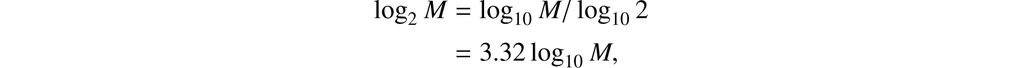

我们所说的通信系统是指图 12.1中示意性指示的类型的系统。它主要由五个部分组成：By a communication system we will mean a system of the type indicated schematically in Figure 12.1. It consists of essentially five parts:

1. 一个*信息源*，产生要传送给接收端的消息或消息序列。消息可以有多种类型：(a) 字母序列，如电报或电传打字系统中的消息；(b) 单个时间函数 *f*(*t*)，如无线电广播或电话中的消息；(c) 时间与其他变量的函数，如黑白电视中的消息——这里可以把消息看作两个空间坐标和时间的函数 *f*(*x, y, t*)，即摄像管靶面上点 (*x, y*) 在时刻 *t* 的光强；(d) 两个或更多时间函数，例如 *f*(*t*)、*g*(*t*)、*h*(*t*)——“三维”声音传输就是这种情况，系统通过多路复用服务于若干独立信道时也如此；(e) 多个多变量函数——在彩色电视中，消息由定义在三维连续域上的三个函数 *f*(*x, y, t*)、*g*(*x, y, t*)、*h*(*x, y, t*) 组成——也可以把这三个函数看作定义在该区域上的一个向量场的分量——类似地，若干黑白电视信源会产生由多个三变量函数组成的“消息”；(f) 也存在各种组合，例如带有配套音频信道的电视。1. An *information source* which produces a message or sequence of messages to be communicated to the receiving terminal. The message may be of various types: (a) A sequence of letters as in a telegraph of teletype system; (b) A single function of time *f*(*t*) as in radio or telephony; (c) A function of time and other variables as in black and white television—here the message may be thought of as a function *f*(*x, y, t*) of two space coordinates and time, the light intensity at point (*x, y*) and time *t* on a pickup tube plate; (d) Two or more functions of time, say *f*(*t*), *g*(*t*), *h*(*t*)—this is the case in “three-dimensional” sound transmission or if the system is intended to service several individual channels in multiplex; (e) Several functions of several variables—in color television the message consists of three functions *f*(*x, y, t*), *g*(*x, y, t*), *h*(*x, y, t*) defined in a three-dimensional continuum—we may also think of these three functions as components of a vector field defined in the region—similarly, several black and white television sources would produce “messages” consisting of a number of functions of three variables; (f) Various combinations also occur, for example in television with an associated audio channel.

2.*发射机*，以某种方式对消息进行操作，产生适合在信道上传输的信号。在电话中，该操作仅包括将声压改变为成比例的电流。在电报中，我们有一个编码操作，它在与消息相对应的通道上产生一系列点、划线和空格。在多路 PCM 系统中，必须对不同的语音函数进行采样、压缩、量化和编码，最后正确地交织以构建信号。声码器系统、电视和频率调制是应用于消息以获得信号的复杂操作的其他示例。2. A *transmitter* which operates on the message in some way to produce a signal suitable for transmission over the channel. In telephony this operation consists merely of changing sound pressure into a proportional electrical current. In telegraphy we have an encoding operation which produces a sequence of dots, dashes and spaces on the channel corresponding to the message. In a multiplex PCM system the different speech functions must be sampled, compressed, quantized and encoded, and finally interleaved properly to construct the signal. Vocoder systems, television and frequency modulation are other examples of complex operations applied to the message to obtain the signal.

3.*信道*只是用于将信号从发射器传输到接收器的介质。它可以是一对电线、一根同轴电缆、一段射频、一束光束等。3. The *channel* is merely the medium used to transmit the signal from transmitter to receiver. It may be a pair of wires, a coaxial cable, a band of radio frequencies, a beam of light, etc.

4.*接收器*通常执行与发送器所执行的操作相反的操作，从信号中重建消息。4. The *receiver* ordinarily performs the inverse operation of that done by the transmitter, reconstructing the message from the signal.

5.*目的地*是消息所针对的人（或事物）。5. The *destination* is the person (or thing) for whom the message is intended.

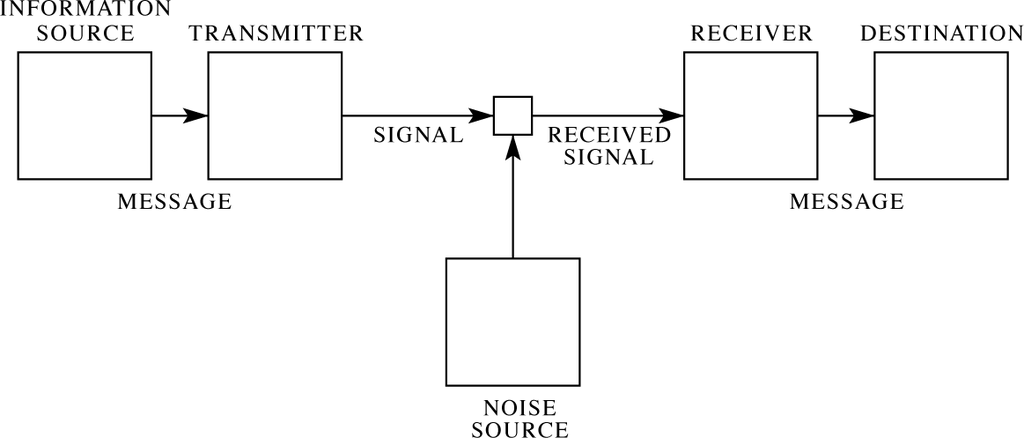

图 12.1： 一般通信系统的示意图。Figure 12.1: Schematic diagram of a general communication system.

我们希望考虑涉及通信系统的某些一般问题。为此，首先必须将涉及的各种元素表示为数学实体，并根据其物理对应物进行适当理想化。我们可以粗略地将通信系统分为三大类：离散型、连续型和混合型。我们所说的离散系统是指消息和信号都是离散符号序列的系统。一个典型的例子是电报，其中消息是字母序列，信号是点、破折号和空格序列。连续系统是一种消息和信号都被视为连续函数的系统，例如广播或电视。混合系统是一种同时出现离散变量和连续变量的系统，例如语音的 PCM 传输。We wish to consider certain general problems involving communication systems. To do this it is first necessary to represent the various elements involved as mathematical entities, suitably idealized from their physical counterparts. We may roughly classify communication systems into three main categories: discrete, continuous and mixed. By a discrete system we will mean one in which both the message and the signal are a sequence of discrete symbols. A typical case is telegraphy where the message is a sequence of letters and the signal a sequence of dots, dashes and spaces. A continuous system is one in which the message and signal are both treated as continuous functions, e.g., radio or television. A mixed system is one in which both discrete and continuous variables appear, e.g., PCM transmission of speech.

我们首先考虑离散情况。该案例不仅在通信理论中具有应用，而且在计算机器理论、电话交换机设计等领域也有应用。此外，离散案例为连续案例和混合案例奠定了基础，连续案例和混合案例将在本文的后半部分进行处理。We first consider the discrete case. This case has applications not only in communication theory, but also in the theory of computing machines, the design of telephone exchanges and other fields. In addition the discrete case forms a foundation for the continuous and mixed cases which will be treated in the second half of the paper.

## **12.1 离散无噪声通道****12.1 The Discrete Noiseless Channel**

电传打字与电报，是传输信息的离散信道的两个简单例子。一般而言，离散信道是这样一种系统：它能把从有限基本符号集 *S*<sub>1</sub>、…、*S*<sub>*n*</sub> 中依次选择而成的序列，从一点传送到另一点。假定每个符号 *S*<sub>*i*</sub> 都有一定的持续时间 *t*<sub>*i*</sub> 秒（不同的 *S*<sub>*i*</sub> 不必相同，例如电报中的点和划）。不要求该系统能传输 *S*<sub>*i*</sub> 的所有可能序列；也许只有某些序列是允许的。这些序列就是该信道可能的信号。例如，在电报中，假定符号为：(1) 点，由线路闭合一个时间单位、再断开一个时间单位构成；(2) 划，由闭合三个时间单位、断开一个时间单位构成；(3) 字母间隔，比如由线路断开三个时间单位构成；(4) 单词间隔，由线路断开六个时间单位构成。我们可以对允许的序列加上一项限制：两个间隔不得相继出现（因为两个字母间隔相邻，就等同于一个单词间隔）。我们现在考虑的问题是，如何衡量这种信道传输信息的容量。Teletype and telegraphy are two simple examples of a discrete channel for transmitting information. Generally, a discrete channel will mean a system whereby a sequence of choices from a finite set of elementary symbols *S*<sub>1</sub>, …, *S*<sub>*n*</sub> can be transmitted from one point to another. Each of the symbols *S*<sub>*i*</sub> is assumed to have a certain duration in time *t*<sub>*i*</sub> seconds (not necessarily the same for different *S*<sub>*i*</sub>, for example the dots and dashes in telegraphy). It is not required that all possible sequences of the *S*<sub>*i*</sub> be capable of transmission on the system; certain sequences only may be allowed. These will be possible signals for the channel. Thus in telegraphy suppose the symbols are: (1) A dot, consisting of line closure for a unit of time and then line open for a unit of time; (2) A dash, consisting of three time units of closure and one unit open; (3) A letter space consisting of, say, three units of line open; (4) A word space of six units of line open. We might place the restriction on allowable sequences that no spaces follow each other (for if two letter spaces are adjacent, it is identical with a word space). The question we now consider is how one can measure the capacity of such a channel to transmit information.

在电传打字的情形中，所有符号持续时间相同，而且 32 个符号的任何序列都被允许，答案很简单。每个符号代表五比特的信息。如果系统每秒传输 *n* 个符号，那么自然可以说，这个信道的容量为每秒 5*n* 比特。这并不意味着电传打字信道总以这个速率传输信息——这是可能达到的最高速率，实际速率是否达到这个最大值，取决于向信道提供信息的信源，后面将会看到这一点。对于符号长度不同且允许的序列受到约束的更一般情形，我们作如下定义：In the teletype case where all symbols are of the same duration, and any sequence of the 32 symbols is allowed the answer is easy. Each symbol represents five bits of information. If the system transmits *n* symbols per second it is natural to say that the channel has a capacity of 5*n* bits per second. This does not mean that the teletype channel will always be transmitting information at this rate—this is the maximum possible rate and whether or not the actual rate reaches this maximum depends on the source of information which feeds the channel, as will appear later. In the more general case with different lengths of symbols and constraints on the allowed sequences, we make the following definition:

*定义：离散通道的容量 C 由下式给出**Definition: The capacity C of a discrete channel is given by*

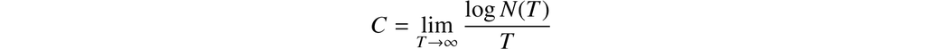

*其中 N* ( *T* )*是持续时间为 T 的允许信号数量*。*where N*(*T*) *is the number of allowed signals of duration T*.

可以对允许的序列施加一种非常一般的限制：设想有若干可能状态 *a*<sub>1</sub>、*a*<sub>2</sub>、…、*a*<sub>*m*</sub>。对于每个状态，只能传输集合 *S*<sub>1</sub>、…、*S*<sub>*n*</sub> 中的某些符号（不同状态对应不同子集）。传输其中一个符号后，状态转变为新状态，新状态既取决于原状态，也取决于所传输的具体符号。电报的情形就是一个简单例子。根据上一个传输的符号是否为空格，有两种状态。如果是空格，那么下一个只能发送点或划，而且状态一定改变；如果不是空格，就可以传输任何符号，发送空格时状态改变，否则保持不变。这些条件可以用图 12.2 所示的线图表示。连接点对应状态，连线表示某一状态下可以发送的符号以及由此产生的状态。附录 1 [编者：已省略] 证明，如果对允许序列的限制条件能够以这种形式描述，那么 *C* 就存在，且可根据以下结果计算：A very general type of restriction which may be placed on allowed sequences is the following: We imagine a number of possible states *a*<sub>1</sub>, *a*<sub>2</sub>, …, *a*<sub>*m*</sub>. For each state only certain symbols from the set *S*<sub>1</sub>, …, *S*<sub>*n*</sub> can be transmitted (different subsets for the different states). When one of these has been transmitted the state changes to a new state depending both on the old state and the particular symbol transmitted. The telegraph case is a simple example of this. There are two states depending on whether or not a space was the last symbol transmitted. If so, then only a dot or a dash can be sent next and the state always changes. If not, any symbol can be transmitted and the state changes if a space is sent, otherwise it remains the same. The conditions can be indicated in a linear graph as shown in Figure 12.2. The junction points correspond to the states and the lines indicate the symbols possible in a state and the resulting state. In Appendix 1 [EDITOR: omitted] it is shown that if the conditions on allowed sequences can be described in this form *C* will exist and can be calculated in accordance with the following result:

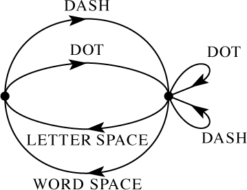

图 12.2： 电报符号约束的图形表示。Figure 12.2: Graphical representation of the constraints on telegraph symbols.

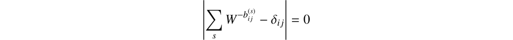

其中，若 *i* = *j*，则 *δ*<sub>*ij*</sub> = 1，否则为零。*where δ*<sub>*ij*</sub> = 1 *if i* = *j and is zero otherwise.*

例如，在电报情况下（图 12.2），行列式是：For example, in the telegraph case (Figure 12.2) the determinant is:

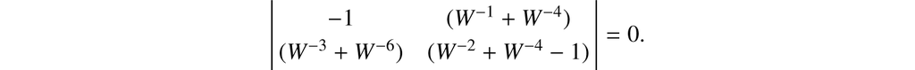

## **12.2 离散信息源****12.2 The Discrete Source of Information**

我们已经看到，在非常一般的条件下，离散通道中可能信号数量的对数随时间线性增加。传输信息的容量可以通过给出该增长率来指定，即指定所使用的特定信号所需的每秒位数。我们现在考虑信息源。如何用数学方法描述信息源，以及给定源每秒产生多少信息（以比特为单位）？争论的要点是，通过使用正确的信息编码，关于源的统计知识对减少信道所需容量的影响。例如，在电报中，要传输的消息由字母序列组成。然而，这些序列并不是完全随机的。一般来说，它们形成句子并具有英语等的统计结构。字母E比Q更频繁地出现，序列TH比XP更频繁地出现，等等。这种结构的存在允许人们通过将消息序列正确地编码成信号序列来节省时间（或信道容量）。在电报中，通过使用最短的通道符号（点）来表示最常见的英文字母 E，已经在一定程度上做到了这一点；而不常见的字母 Q、X、Z 则由较长的点和破折号序列表示。这种想法在某些商业代码中得到了进一步的体现，其中常见的单词和短语由四个或五个字母的代码组表示，从而平均时间节省了相当多。现在使用的标准化问候语和周年纪念电报将其扩展为将一两句话编码为相对较短的数字序列。We have seen that under very general conditions the logarithm of the number of possible signals in a discrete channel increases linearly with time. The capacity to transmit information can be specified by giving this rate of increase, the number of bits per second required to specify the particular signal used. We now consider the information source. How is an information source to be described mathematically, and how much information in bits per second is produced in a given source? The main point at issue is the effect of statistical knowledge about the source in reducing the required capacity of the channel, by the use of proper encoding of the information. In telegraphy, for example, the messages to be transmitted consist of sequences of letters. These sequences, however, are not completely random. In general, they form sentences and have the statistical structure of, say, English. The letter E occurs more frequently than Q, the sequence TH more frequently than XP, etc. The existence of this structure allows one to make a saving in time (or channel capacity) by properly encoding the message sequences into signal sequences. This is already done to a limited extent in telegraphy by using the shortest channel symbol, a dot, for the most common English letter E; while the infrequent letters, Q, X, Z are represented by longer sequences of dots and dashes. This idea is carried still further in certain commercial codes where common words and phrases are represented by four- or five-letter code groups with a considerable saving in average time. The standardized greeting and anniversary telegrams now in use extend this to the point of encoding a sentence or two into a relatively short sequence of numbers.

我们可以将离散源视为一个符号一个符号地生成消息。它将根据某些概率选择连续的符号，通常取决于先前的选择以及所讨论的特定符号。产生由一组概率控制的符号序列的物理系统或系统的数学模型被称为随机过程（例如，参见 Chandrasekhar [1943]）。因此，我们可以考虑用随机过程来表示离散源。相反，任何随机过程产生从有限集合中选择的离散符号序列可以被认为是离散源。这将包括以下情况：We can think of a discrete source as generating the message, symbol by symbol. It will choose successive symbols according to certain probabilities depending, in general, on preceding choices as well as the particular symbols in question. A physical system, or a mathematical model of a system which produces such a sequence of symbols governed by a set of probabilities, is known as a stochastic process (see, for example, Chandrasekhar [1943]). We may consider a discrete source, therefore, to be represented by a stochastic process. Conversely, any stochastic process which produces a discrete sequence of symbols chosen from a finite set may be considered a discrete source. This will include such cases as:

1.自然书面语言，如英语、德语、汉语。1. Natural written languages such as English, German, Chinese.

2. 通过某种量化过程而变得离散的连续信息源。例如，来自 PCM 发射机的量化语音或量化电视信号。2. Continuous information sources that have been rendered discrete by some quantizing process. For example, the quantized speech from a PCM transmitter, or a quantized television signal.

3. 数学案例，我们仅仅抽象地定义一个生成符号序列的随机过程。以下是最后一种来源的示例。3. Mathematical cases where we merely define abstractly a stochastic process which generates a sequence of symbols. The following are examples of this last type of source.

(A) 假设我们有五个字母 A、B、C、D、E，每个字母都有概率被选择。2，连续的选择是独立的。这将导致一个序列，下面是一个典型的例子。(A) Suppose we have five letters A, B, C, D, E which are chosen each with probability.2, successive choices being independent. This would lead to a sequence of which the following is a typical example.

B D C B C E C C C A D C B D D A A E C E E A

A B B D A E E C A C E E B A E E C B C E A D.

这是使用随机数表构建的（Kendall，1939）。This was constructed with the use of a table of random numbers (Kendall, 1939).

(B) 使用相同的五个字母，概率分别为 .4,.1,.2,.2,.1，连续选择独立。来自该来源的典型消息是：(B) Using the same five letters let the probabilities be.4,.1,.2,.2,.1, respectively, with successive choices independent. A typical message from this source is then:

A A A C D C B D C E A A D A D A C E D A

E A D C A B E D A D D C E C A A A A A D.

(C) 如果相继出现的符号并非独立选取，而是其概率取决于前面的字母，就会得到更复杂的结构。在这类情形中，最简单的是一次选择只取决于前一个字母，而不取决于更早的字母。此时，统计结构可以用一组转移概率 *p*<sub>*i*</sub>(*j*) 来描述，即字母 *i* 之后跟着字母 *j* 的概率。下标 *i* 与 *j* 遍历所有可能的符号。另一种等价的结构指定方式，是给出“二联字母”概率 *p*(*i, j*)，即二联字母 *ij* 的相对频率。字母频率 *p*(*i*)（字母 *i* 的概率）、转移概率 *p*<sub>*i*</sub>(*j*) 和二联字母概率 *p*(*i, j*) 之间有如下关系式：(C) A more complicated structure is obtained if successive symbols are not chosen independently but their probabilities depend on preceding letters. In the simplest case of this type a choice depends only on the preceding letter and not on ones before that. The statistical structure can then be described by a set of transition probabilities *p*<sub>*i*</sub>(*j*), the probability that letter *i* is followed by letter *j*. The indices *i* and*j* range over all the possible symbols. A second equivalent way of specifying the structure is to give the “digram” probabilities *p*(*i, j*), i.e., the relative frequency of the digram *ij*. The letter frequencies *p*(*i*) (the probability of letter *i*), the transition probabilities *p*<sub>*i*</sub>(*j*) and the digram probabilities *p*(*i, j*) are related by the following formulas:

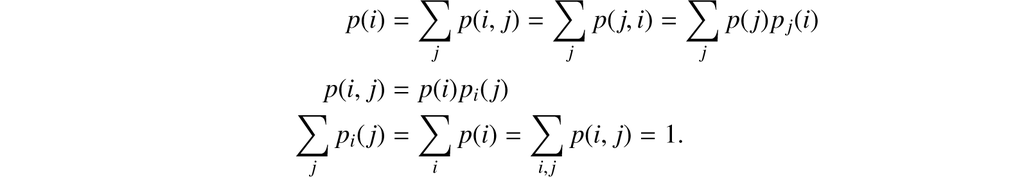

作为一个具体的例子，假设有三个字母 A、B、C 和概率表：As a specific example suppose there are three letters A, B, C with the probability tables:

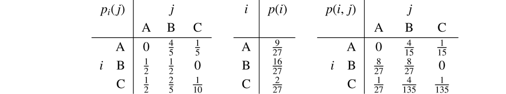

来自该来源的典型消息如下：A typical message from this source is the following:

A B B A B A B A B A B A B A B B B A B B B B B A B A B A B A B A B B B A C A C A B B A B B B B A B B A B A C B B B A B A.

再增加一级复杂性，就要涉及三元组频率，但不再涉及更多。一个字母的选择将取决于前两个字母，而不取决于更早的消息。为此需要一组三元组频率 *p*(*i, j, k*)，或等价地，需要一组转移概率 *p*<sub>*ij*</sub>(*k*)。如此继续，就会依次得到更复杂的随机过程。在一般的 *n* 元组情形中，需要一组 *n* 元组概率 *p*(*i*<sub>1</sub>*, i*<sub>2</sub>*, …, i*<sub>*n*</sub>)，或一组转移概率 *p*<sub>*i*<sub>1</sub>*, i*<sub>2</sub>*, …, i*<sub>*n*−1</sub></sub>(*i*<sub>*n*</sub>)，来确定其统计结构。The next increase in complexity would involve trigram frequencies but no more. The choice of a letter would depend on the preceding two letters but not on the message before that point. A set of trigram frequencies *p*(*i, j, k*) or equivalently a set of transition probabilities *p*<sub>*ij*</sub>(*k*) would be required. Continuing in this way one obtains successively more complicated stochastic processes. In the general *n*-gram case a set of *n*-gram probabilities *p*(*i*<sub>1</sub>*, i*<sub>2</sub>*, …, i*<sub>*n*</sub>) or of transition probabilities *p*<sub>*i*<sub>1</sub>*, i*<sub>2</sub>*, …, i*<sub>*n*−1</sub></sub>(*i*<sub>*n*</sub>) is required to specify the statistical structure.

(D) 还可以定义生成由 *n* 个“词”组成的序列文本的随机过程。假定某种语言有五个字母 A、B、C、D、E，以及 16 个“词”，其相应概率如下：(D) Stochastic processes can also be defined which produce a text consisting of a sequence of *n* “words.” Suppose there are five letters A, B, C, D, E and 16 “words” in the language with associated probabilities:

[output not shown]

假设连续的“单词”是独立选择的并且由空格分隔。典型的消息可能是：Suppose successive “words” are chosen independently and are separated by a space. A typical message might be:

如果所有单词的长度都是有限的，则该过程相当于前一种类型，但描述在单词结构和概率方面可能更简单。我们也可以在这里进行概括，引入单词之间的转移概率等。If all the words are of finite length this process is equivalent to one of the preceding type, but the description may be simpler in terms of the word structure and probabilities. We may also generalize here and introduce transition probabilities between words, etc.

## **12.3 英语的一系列近似值****12.3 The Series of Approximations to English**

为了直观地了解这一系列过程如何接近一种语言，我们构建了近似英语的典型序列，并在下面给出。在所有情况下，我们都假设一个由 27 个符号组成的“字母表”，即 26 个字母和一个空格。To give a visual idea of how this series of processes approaches a language, typical sequences in the approximations to English have been constructed and are given below. In all cases we have assumed a 27-symbol “alphabet,” the 26 letters and a space.

1. 零阶近似（符号独立且等概率）。1. Zero-order approximation (symbols independent and equiprobable).

XFOML RXKHRJFFJUJ ZLPWCFWKCYJ FFJEYVKCQSGHYD QPAAMKBZAACIBZLHJQD.

2. 一阶近似（符号独立但具有英文文本的频率）。2. First-order approximation (symbols independent but with frequencies of English text).

OCRO HLI RGWR NMIELWIS EU LL NBNESEBYA TH EEI ALHENHTTPA OOBTTVA NAH BRL.

3. 二阶近似（英语中的二元结构）。3. Second-order approximation (digram structure as in English).

4. 三阶近似（英语中的三字结构）。4. Third-order approximation (trigram structure as in English).

5. 一阶词近似。与其继续考察四元组、…、*n* 元组结构，不如此时直接转向以词为单位，这样更容易，也更好。这里，各个词独立地选择，但遵循各自应有的频率（Dewey，1923）。5. First-order word approximation. Rather than continue with tetragram, …, *n*-gram structure it is easier and better to jump at this point to word units. Here words are chosen independently but with their appropriate frequencies (Dewey, 1923).

代表和迅速是一个很好的选择，或者可以自然地在这里他的A来了专家格雷来提供线路消息已经是这些。REPRESENTING AND SPEEDILY IS AN GOOD APT OR COME CAN DIFFERENT NATURAL HERE HE THE A IN CAME THE TO OF TO EXPERT GRAY COME TO FURNISHES THE LINE MESSAGE HAD BE THESE.

6.二阶词近似。单词转换概率是正确的，但未包含进一步的结构。6. Second-order word approximation. The word transition probabilities are correct but no further structure is included.

一位英国作家的头部和正面攻击表明，这一点的特征因此是字母的另一种方法，该字母的时间曾经告诉过一个意外的问题。THE HEAD AND IN FRONTAL ATTACK ON AN ENGLISH WRITER THAT THE CHARACTER OF THIS POINT IS THEREFORE ANOTHER METHOD FOR THE LETTERS THAT THE TIME OF WHO EVER TOLD THE PROBLEM FOR AN UNEXPECTED.

在上述每个步骤中，与普通英语文本的相似性都显着增加。请注意，这些样本具有相当良好的结构，大约是其构造中考虑的范围的两倍。因此，在（3）中，统计过程确保了两个字母序列的合理文本，但样本中的四个字母序列通常可以拟合成好的句子。在（6）中，四个或更多单词的序列可以轻松地放入句子中，而无需异常或紧张的结构。十个词的特定顺序“攻击一位英国作家的性格”并不是没有道理的。看来，足够复杂的随机过程将给出离散源的令人满意的表示。The resemblance to ordinary English text increases quite noticeably at each of the above steps. Note that these samples have reasonably good structure out to about twice the range that is taken into account in their construction. Thus in (3) the statistical process insures reasonable text for two-letter sequences, but four-letter sequences from the sample can usually be fitted into good sentences. In (6) sequences of four or more words can easily be placed in sentences without unusual or strained constructions. The particular sequence of ten words “attack on an English writer that the character of this” is not at all unreasonable. It appears then that a sufficiently complex stochastic process will give a satisfactory representation of a discrete source.

前两个样本是通过使用随机数簿和（例如 2）字母频率表来构建的。该方法可能会继续用于（3）、（4）和（5），因为二元词、三元词和词频表可用，但使用了更简单的等效方法。例如，为了构建（3），人们随机打开一本书并随机选择页面上的一个字母。这封信被记录下来。然后将书打开到另一页并阅读，直到遇到这封信。然后记录下一个字母。翻到另一页，搜索第二个字母并记录下一个字母，等等。类似的过程用于(4)、(5)和(6)。如果可以构建进一步的近似值，那将很有趣，但下一阶段涉及的工作量将变得巨大。The first two samples were constructed by the use of a book of random numbers in conjunction with (for example 2) a table of letter frequencies. This method might have been continued for (3), (4) and (5), since digram, trigram and word frequency tables are available, but a simpler equivalent method was used. To construct (3) for example, one opens a book at random and selects a letter at random on the page. This letter is recorded. The book is then opened to another page and one reads until this letter is encountered. The succeeding letter is then recorded. Turning to another page this second letter is searched for and the succeeding letter recorded, etc. A similar process was used for (4), (5) and (6). It would be interesting if further approximations could be constructed, but the labor involved becomes enormous at the next stage.

## **12.4 马尔科夫过程的图形表示****12.4 Graphical Representation of a Markoff Process**

上述类型的随机过程，在数学上称为离散马尔可夫过程，已有大量文献对其进行研究（详细论述见 Frechet [1938]）。一般情形可以描述如下：系统存在有限个可能的“状态”：*S*<sub>1</sub>、*S*<sub>2</sub>、…、*S*<sub>*n*</sub>。此外，还有一组转移概率 *p*<sub>*i*</sub>(*j*)，即系统处于状态 *S*<sub>*i*</sub> 时，下一步进入状态 *S*<sub>*j*</sub> 的概率。要把这个马尔可夫过程变成信息源，只需假定从一个状态转移到另一个状态时，都会产生一个字母。这些状态将对应于此前字母的“残余影响”。Stochastic processes of the type described above are known mathematically as discrete Markoff processes and have been extensively studied in the literature (for a detailed treatment, see Frechet [1938]). The general case can be described as follows: There exist a finite number of possible “states” of a system; *S*<sub>1</sub>, *S*<sub>2</sub>, …, *S*<sub>*n*</sub>. In addition there is a set of transition probabilities, *p*<sub>*i*</sub>(*j*), the probability that if the system is in state *S*<sub>*i*</sub> it will next go to state *S*<sub>*j*</sub>. To make this Markoff process into an information source we need only assume that a letter is produced for each transition from one state to another. The states will correspond to the “residue of influence” from preceding letters.

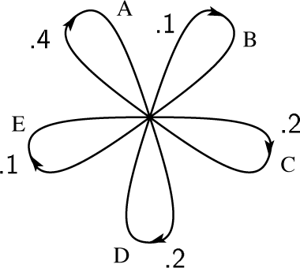

图 12.3： 与示例 B 中的源相对应的图表。Figure 12.3: A graph corresponding to the source in example B.

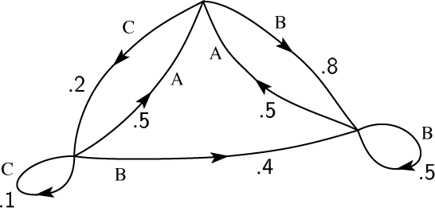

图 12.4： 与示例 C 中的源相对应的图表。Figure 12.4: A graph corresponding to the source in example C.

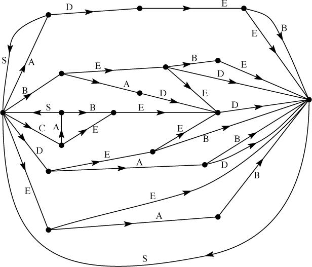

图 12.5： 与示例 D 中的源相对应的图表。Figure 12.5: A graph corresponding to the source in example D.

## **12.6 选择、不确定性和熵****12.6 Choice, Uncertainty, and Entropy**

我们将离散信息源表示为马尔可夫过程。我们能否定义一个量来衡量，在某种意义上，这样的过程“产生”了多少信息，或者更好的是，信息产生的速度是多少？We have represented a discrete information source as a Markoff process. Can we define a quantity which will measure, in some sense, how much information is “produced” by such a process, or better, at what rate information is produced?

假设我们有一组可能事件，其发生概率为*p*<sub>1</sub> , *p*<sub>2</sub> , … , *p*<sub>*n*</sub>。这些概率是已知的，但这就是我们所知道的关于哪个事件将会发生的全部。我们能否找到一个衡量标准来衡量事件的选择涉及多少“选择”，或者我们对结果的不确定性有多大？Suppose we have a set of possible events whose probabilities of occurrence are *p*<sub>1</sub>, *p*<sub>2</sub>, …, *p*<sub>*n*</sub>. These probabilities are known but that is all we know concerning which event will occur. Can we find a measure of how much “choice” is involved in the selection of the event or of how uncertain we are of the outcome?

如果存在这样的测度，例如*H* ( *p*<sub>1</sub>*, p* <sub>2</sub>*, … , p* <sub>*n*</sub> )，则要求其具有以下属性是合理的：If there is such a measure, say *H*(*p*<sub>1</sub>*, p*<sub>2</sub>*, …, p*<sub>*n*</sub>), it is reasonable to require of it the following properties:

1. *H* 应当是各 *p*<sub>*i*</sub> 的连续函数。1. *H* should be continuous in the *p*<sub>*i*</sub>.

3. 如果把一次选择分解为先后两次选择，原来的 *H* 应当等于这两次选择各自的 *H* 值的加权和。图 12.6 说明了它的含义。左侧有三种可能情况

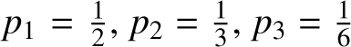

。右侧先在两种可能情况之间选择，每种情况的概率均为 ；如果第二种情况发生，就再按概率 作一次选择。最终结果的概率与先前相同。在这个特例中，我们要求3. If a choice be broken down into two successive choices, the original *H* should be the weighted sum of the individual values of *H*. The meaning of this is illustrated in Figure 12.6. At the left we have three possibilities

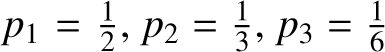

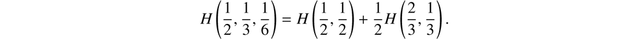

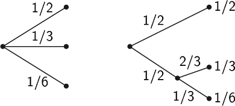

图 12.6： 对三种可能性的选择进行分解。Figure 12.6: Decomposition of a choice from three possibilities.

在附录2[编辑：省略]中，建立了以下结果：In Appendix 2 [EDITOR: omitted], the following result is established:

*定理2：满足上述三个假设的唯一H的形式为：**Theorem 2: The only H satisfying the three above assumptions is of the form:*

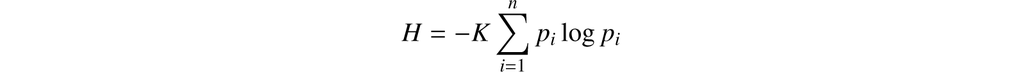

*其中 K 是正常数。**where K is a positive constant.*

这个定理以及证明它所需的假设对于本理论来说并不是必需的。给出它主要是为了给我们后来的一些定义提供一定的合理性。然而，这些定义的真正合理性在于它们的含义。This theorem, and the assumptions required for its proof, are in no way necessary for the present theory. It is given chiefly to lend a certain plausibility to some of our later definitions. The real justification of these definitions, however, will reside in their implications.

形如 *H* = −∑ *p*<sub>*i*</sub> log *p*<sub>*i*</sub> 的量（常数 *K* 仅相当于计量单位的选择），在信息论中起着核心作用，用于度量信息、选择和不确定性。可以认出，*H* 的形式就是统计力学某些表述中所定义的熵的形式，其中 *p*<sub>*i*</sub> 是系统处于相空间第 *i* 个胞元中的概率。例如，此时 *H* 就是玻尔兹曼著名的 *H* 定理中的 *H*。我们把 *H* = −∑ *p*<sub>*i*</sub> log *p*<sub>*i*</sub> 称为概率集 *p*<sub>1</sub>、…、*p*<sub>*n*</sub> 的熵。如果 *x* 是一个随机变量，我们用 *H*(*x*) 表示它的熵；因此，*x* 不是函数的自变量，而是某个数的标签，例如用来将它与随机变量 *y* 的熵 *H*(*y*) 区分开。Quantities of the form *H* = −∑ *p*<sub>*i*</sub> log *p*<sub>*i*</sub> (the constant *K* merely amounts to a choice of a unit of measure) play a central role in information theory as measures of information, choice and uncertainty. The form of *H* will be recognized as that of entropy as defined in certain formulations of statistical mechanics where *p*<sub>*i*</sub> is the probability of a system being in cell *i* of its phase space. *H* is then, for example, the *H* in Boltzmann’s famous *H* theorem. We shall call *H* = −∑ *p*<sub>*i*</sub> log *p*<sub>*i*</sub> the entropy of the set of probabilities *p*<sub>1</sub>, …, *p*<sub>*n*</sub>. If *x* is a chance variable we will write *H*(*x*) for its entropy; thus *x* is not an argument of a function but a label for a number, to differentiate it from *H*(*y*) say, the entropy of the chance variable *y*.

在图 12.7中绘制为*p*的函数。is plotted in Figure 12.7 as a function of *p*.

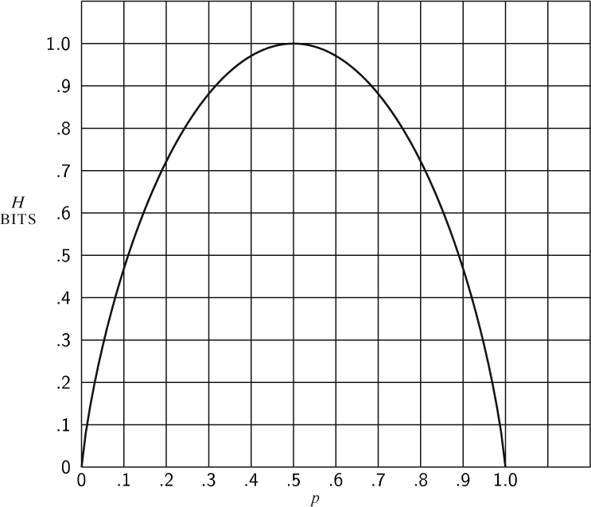

图 12.7：概率为 *p*和 (1 − *p* )的两种可能性情况下的熵。Figure 12.7: Entropy in the case of two possibilities with probabilities *p* and (1 − *p*).

数量*H*有许多有趣的属性，进一步证实它是选择或信息的合理度量。The quantity *H* has a number of interesting properties which further substantiate it as a reasonable measure of choice or information.

1. *H* = 0 当且仅当所有*p*<sub>*i*</sub>除一个为零外，该 p i 的值为 1。因此，只有当我们确定结果时，*H*才会消失。否则*H*为正。1. *H* = 0 if and only if all the *p*<sub>*i*</sub> but one are zero, this one having the value unity. Thus only when we are certain of the outcome does *H* vanish. Otherwise *H* is positive.

3. 假设所讨论的两个事件为 *x* 和 *y*，第一个有 *m* 种可能情况，第二个有 *n* 种。令 *p*(*i, j*) 表示第一个事件出现 *i*、第二个事件出现 *j* 的联合发生概率。联合事件的熵为3. Suppose there are two events, *x* and *y*, in question with *m* possibilities for the first and *n* for the second. Let *p*(*i, j*) be the probability of the joint occurrence of *i* for the first and *j* for the second. The entropy of the joint event is

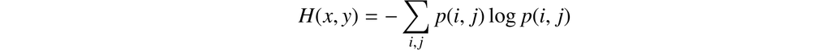

尽管while

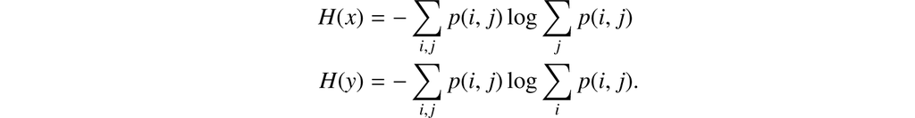

很容易证明*H* ( *x, y* ) ≤ *H* ( *x* ) + *H* ( *y* )，只有当事件是独立的时才相等（即*p* ( *i, j* ) = *p* ( *i* ) *p* ( *j* )）。联合事件的不确定性小于或等于单个事件的不确定性之和。It is easily shown that *H*(*x, y*) ≤ *H*(*x*) + *H*(*y*), with equality only if the events are independent (i.e., *p*(*i, j*) = *p*(*i*)*p*(*j*)). The uncertainty of a joint event is less than or equal to the sum of the individual uncertainties.

4. 概率*p*<sub>1</sub> , *p*<sub>2</sub> , … , *p*<sub>*n*</sub>的任何朝向均衡的变化都会增加*H*。因此，如果*p*<sub>1</sub> *< p* <sub>2</sub>并且我们增加*p*<sub>1</sub>，同时减少*p*<sub>2</sub>等量，使得*p*<sub>1</sub>和*p*<sub>2</sub>更接近相等，则*H*增加。更一般地，如果我们对形式的*p*<sub>*i*</sub>执行任何“平均”操作4. Any change toward equalization of the probabilities *p*<sub>1</sub>, *p*<sub>2</sub>, …, *p*<sub>*n*</sub> increases *H*. Thus if *p*<sub>1</sub> *< p*<sub>2</sub> and we increase *p*<sub>1</sub>, decreasing *p*<sub>2</sub> an equal amount so that *p*<sub>1</sub> and *p*<sub>2</sub> are more nearly equal, then *H* increases. More generally, if we perform any “averaging” operation on the *p*<sub>*i*</sub> of the form

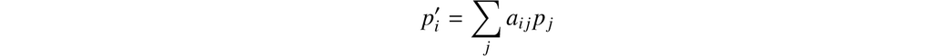

其中

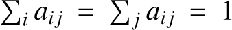

，并且所有*a*<sub>*ij*</sub> ≥ 0，则*H*增加（除非在特殊情况下，此变换相当于*p*<sub>*j*</sub>的排列，而*H*当然保持不变）。where

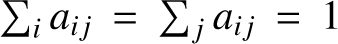

, and all *a*<sub>*ij*</sub> ≥ 0, then *H* increases (except in the special case where this transformation amounts to no more than a permutation of the *p*<sub>*j*</sub> with *H* of course remaining the same).

5. 假定像第 3 点那样，有两个不一定相互独立的随机事件 *x* 和 *y*。对于 *x* 可取的任何特定值 *i*，都有一个条件概率 *p*<sub>*i*</sub>(*j*)，表示 *y* 取值 *j* 的概率。它由下式给出5. Suppose there are two chance events *x* and *y* as in 3, not necessarily independent. For any particular value *i* that *x* can assume there is a conditional probability *p*<sub>*i*</sub>(*j*) that *y* has the value *j*. This is given by

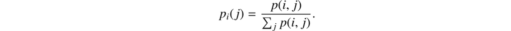

我们把 *y* 的*条件熵* *H*<sub>*x*</sub>(*y*) 定义为：对 *x* 的每个值所对应的 *y* 的熵，按该特定 *x* 出现的概率加权所得的平均值。即We define the *conditional entropy* of *y*, *H*<sub>*x*</sub>(*y*) as the average of the entropy of *y* for each value of *x*, weighted according to the probability of getting that particular *x*. That is

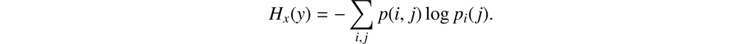

这个量度量的是：已知 *x* 时，我们对 *y* 平均有多大程度的不确定。代入 *p*<sub>*i*</sub>(*j*) 的值，得到This quantity measures how uncertain we are of *y* on the average when we know *x*. Substituting the value of *p*<sub>*i*</sub>(*j*) we obtain

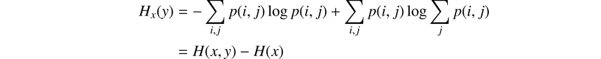

或者，*H*(*x, y*) = *H*(*x*) + *H*<sub>*x*</sub>(*y*)。联合事件 *x*、*y* 的不确定性（或熵），等于 *x* 的不确定性，加上已知 *x* 时 *y* 的不确定性。or *H*(*x, y*) = *H*(*x*) + *H*<sub>*x*</sub>(*y*). The uncertainty (or entropy) of the joint event *x*, *y* is the uncertainty of *x* plus the uncertainty of *y* when *x* is known.

6. 由第 3 点和第 5 点，有 *H*(*x*) + *H*(*y*) ≥ *H*(*x, y*) = *H*(*x*) + *H*<sub>*x*</sub>(*y*)。因此，*H*(*y*) ≥ *H*<sub>*x*</sub>(*y*)。知道 *x* 绝不会增加 *y* 的不确定性。除非 *x* 和 *y* 是相互独立的事件，否则不确定性就会减小；若两者独立，则保持不变。6. From 3 and 5 we have *H*(*x*) + *H*(*y*) ≥ *H*(*x, y*) = *H*(*x*) + *H*<sub>*x*</sub>(*y*). Hence *H*(*y*) ≥ *H*<sub>*x*</sub>(*y*). The uncertainty of *y* is never increased by knowledge of *x*. It will be decreased unless *x* and *y* are independent events, in which case it is not changed.

## **12.7 信息源的熵****12.7 The Entropy of an Information Source**

考虑上述有限状态类型的离散信源。对于每个可能状态 *i*，都会有一组概率 *p*<sub>*i*</sub>(*j*)，对应产生各种可能符号 *j* 的概率。因此，每个状态都有一个熵 *H*<sub>*i*</sub>。信源的熵将定义为这些*H*<sub>*i*</sub> 按相应状态出现的概率加权所得的平均值：Consider a discrete source of the finite state type considered above. For each possible state *i* there will be a set of probabilities *p*<sub>*i*</sub>(*j*) of producing the various possible symbols *j*. Thus there is an entropy *H*<sub>*i*</sub> for each state. The entropy of the source will be defined as the average of these *H*<sub>*i*</sub> weighted in accordance with the probability of occurrence of the states in question:

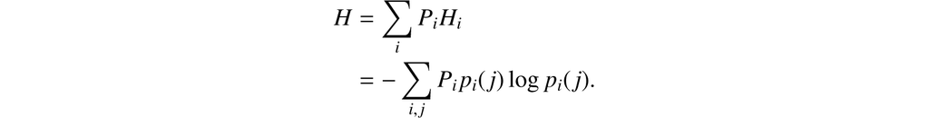

如果相继的符号彼此独立，那么 *H* 就是 −∑ *p*<sub>*i*</sub> log *p*<sub>*i*</sub>，其中 *p*<sub>*i*</sub> 是符号 *i* 的概率。假设在这种情形下考虑一条由 *N* 个符号组成的长消息。它将以很高的概率包含约 *p*<sub>1</sub>*N* 个第一种符号、*p*<sub>2</sub>*N* 个第二种符号，等等。因此，这一特定消息的概率大致为If successive symbols are independent then *H* is simply −∑ *p*<sub>*i*</sub> log *p*<sub>*i*</sub> where *p*<sub>*i*</sub> is the probability of symbol *i*. Suppose in this case we consider a long message of *N* symbols. It will contain with high probability about *p*<sub>1</sub>*N* occurrences of the first symbol, *p*<sub>2</sub>*N* occurrences of the second, etc. Hence the probability of this particular message will be roughly

[figure not shown]

或者or

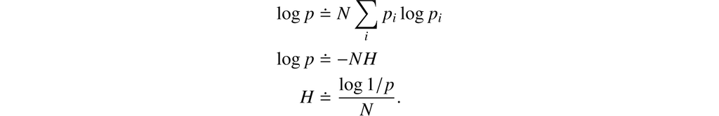

因此，*H* 近似等于一个典型长序列的概率倒数的对数，再除以该序列中的符号数。相同结果对任何信源都成立。…*H* is thus approximately the logarithm of the reciprocal probability of a typical long sequence divided by the number of symbols in the sequence. The same result holds for any source. …

1. 经诺基亚贝尔实验室许可，转载自 Shannon (1948)。Reprinted from Shannon (1948), with permission from Nokia Bell Labs.

# **13**

# 检错码与纠错码（1950）**Error Detecting and Error Correcting Codes (1950)**

## **汉明****R. W. Hamming**

今天，我们认为理所当然的是：把一个数存入计算机内存，随后再读出来，读出的数就与存入的数相同。如果存储的是 *π* 的值，那么程序每次使用这个值时，它都会是 3.14159，绝不会是 3.24159 或 3.14158。同样，意在访问内存位置 2468 的程序，绝不会转而访问位置 2478。当然，计算机会由于程序错误、短路和错误的输入数据而出现故障。但比特本身却可靠无误，即使它们是从地球另一端或深空探测器传来的，即使存储和传送它们的物理介质是连续的、不完美的，并且受统计物理定律支配。当数据确实发生错乱时，计算机通常会告诉我们。We take it for granted today that if a number is stored in computer memory and then retrieved, the number that comes out of memory is the same as the number that went in. If the value of *π* is stored, then when a program uses that value it will be 3.14159 every time, never 3.24159 or 3.14158. Similarly, no program meant to access memory location 2468 will ever access location 2478 instead. Computers malfunction, to be sure, because of programming errors, short circuits, and bad input data. But the bits themselves are reliably correct, even if transmitted halfway around the world or from a probe in deep space, and even though the physical stuff in which they are stored and moved is continuous, imperfect, and subject to the laws of statistical physics. When data does become garbled, our computers tend to tell us so.

情况并非总是如此。It was not always so.

由于早期机械计算设备的继电器和齿轮非常不可靠，因此其中一些设备使用奇偶校验码来检测何时出现错误。例如，如果有四个数据位，第五位将是其他四个数据位的 mod 2 和，即，如果四个数据位中有偶数个 1，则为 0；如果有奇数个数据位，则为 1。四个数据位中的1。Because the relays and gears of early mechanical calculating equipment were so unreliable, some of those devices used parity codes to detect when a bit was in error. If there were four data bits, for example, a fifth bit would be the mod 2 sum of the other four, that is, 0 if there were an even number of 1s among the four data bits and 1 if there were an odd number of 1s among the four data bits.

理查德·哈明 (Richard Hamming，1915-1998) 与约翰·冯·诺依曼 (John von Neumann) 一起参与曼哈顿计划，然后于 1946 年作为数学家加入贝尔电话实验室。在那里，他与克劳德·香农 (Claude Shannon) 共用一间办公室，并开始将他在洛斯阿拉莫斯获得的计算经验与新兴的信息论科学。图灵奖随附的传记描述了 1947 年发生的事情，使他开辟了一个全新的领域。Richard Hamming (1915–1998) worked with John von Neumann on the Manhattan Project before joining Bell Telephone Labs as a mathematician in 1946. There he shared an office with Claude Shannon and began to marry the computing experience he had gained at Los Alamos with the emerging science of information theory. The biography accompanying his Turing Award describes what happened in 1947 that caused him to open up an entirely new field.

一个星期五，在贝尔实验室工作时，他设置了他们的预计算机计算机来解决一个复杂的问题，并期望在下周一开始工作时得到结果。但当他周一到达时，他发现计算初期就出现了错误，基于继电器的计算器无法继续进行。（美国计算机学会，1968）One Friday, while working for Bell Laboratories, he set their pre-computer calculating machines to solving a complex problem and expected the result to be waiting for him when he began work on the following Monday. But when he arrived on Monday, he found that an error had occurred early on in the calculations and the relay-based calculators had been unable to proceed. (ACM, 1968)

奇偶校验失败，整个计算就停止了。汉明通过培训一位读过布尔思维*定律的*数学家，意识到如果计算机能够找出错误，那么计算机也可能能够找出错误在哪里，并纠正它。因此诞生了纠错码的想法，在这种情况下四位数据还需要三位。（事实上，本卷第 92 页的“初稿”EDVAC 报告已经指出，虽然硬件错误是不可避免的，但有些错误可能会自动纠正。）A parity check had failed and the entire calculation simply stopped. Hamming, by training a mathematician who had appreciatively read Boole’s *Laws of Thought*, realized that if a computer could figure out that there was a mistake, a computer might also be able to figure out where the mistake was, and correct it. Thus was born the idea of an error correcting code, which in the case of a four-bit datum requires three more bits. (In fact, the “First Draft” EDVAC report, page 92 of this volume, had already observed that while hardware errors were inevitable, some might be corrected automatically.)

在这篇论文中，汉明先构造了一个特定的单错纠正码，然后建立了一般理论。他把两个比特向量之间的距离定义为它们取值不同的位置的数量；这一度量如今通称为*汉明距离*。两个不会因一位错误而彼此混淆的比特向量，相互之间的距离至少为 2。因此，寻找一种像简单奇偶校验码那样能识别一位错误的 *n* 位码，等价于在 {0, 1}<sup>*n*</sup> 中寻找一组称为码字的点，其中任意两点之间的距离都不小于 2。如果码字之间的最小距离为 3，这个码就能纠正单比特错误，因为任何比特向量都至多只能与一个码字相距 1。这样，设计编码就成为在 {0, 1}<sup>*n*</sup> 中填装互不重叠的球面（与某个给定点距离相同的各点）的问题。In this paper Hamming first improvises a specific single-error-correcting code and then establishes a general theory. He defines the distance between two bit vectors as the number of positions in which they differ, a measure now universally known as the *Hamming distance*. Two bit vectors that cannot be confused with one another by a one-bit error are at distance at least 2 from each other. So finding an *n*-bit code, like a simple parity code, that identifies one-bit errors is equivalent to finding a set of points in {0, 1}<sup>*n*</sup>, called codewords, in which no two points have distance less than 2 between them. If the minimum distance between codewords is 3, the code can correct single-bit errors, since any bit vector can be at distance 1 from only one codeword. Designing codes thus becomes a problem of packing non-overlapping spheres (points of constant distance from a given point) in {0, 1}<sup>*n*</sup>.

汉明的论文发表后，该领域爆发了。现代存储设备中位的物理尺寸很小，但数量却很大，因此位级别的错误是不可避免的。如今，计算机通过基于汉明最初开发的方法在微观层面包含精心设计的冗余（用户不可见）来实现宏观完美。The field exploded after the publication of Hamming’s paper. The physical size of bits in modern storage devices is so small, and their number so large, that errors at the bit level are inevitable. Computers achieve macroscopic perfection today by including carefully designed redundancy at the microscopic level, invisible to users, by methods built on those Hamming first developed.

理查德·汉明 (Richard Hamming) 对通信理论做出了许多其他贡献，并于 1976 年转向学术界。直到 82 岁去世前几个月，他一直是改进数学教学的支持者。Richard Hamming made many other contributions to communications theory, and in 1976 transitioned to academia. He was a proponent of improved teaching of mathematics until months before his death at the age of 82.

## **13.1 简介****13.1 Introduction**

作者出于对大型计算机的考虑而进行了本文的研究，其中必须执行大量操作，而最终结果不会出现任何错误。大规模“正确做事”的问题本质上并不是什么新鲜事。例如，在电话中心局中，执行大量操作，同时导致错误号码的错误得到很好的控制，尽管这些错误尚未完全消除。这在一定程度上是通过使用自检电路来实现的。偶尔逃过例行检查的故障仍然会被客户发现，如果持续存在，将导致客户投诉。而如果它是暂时的，它只会偶尔产生错误的数字。与此同时，中央办公室的其余部分运转良好。另一方面，在数字计算机中，单个故障通常意味着完全故障，从某种意义上说，如果检测到故障，则在定位并纠正故障之前无法进行更多计算，而如果它逃脱了检测，则所有故障都无效。机器的后续操作。换句话说，在电话中心局中有许多并行路径，这些路径或多或少是彼此独立；在数字机器中，通常有一条长路径，在获得答案之前多次经过同一台设备。THE author was led to the study given in this paper from a consideration of large scale computing machines in which a large number of operations must be performed without a single error in the end result. This problem of “doing things right” on a large scale is not essentially new; in a telephone central office, for example, a very large number of operations are performed while the errors leading to wrong numbers are kept well under control, though they have not been completely eliminated. This has been achieved, in part, through the use of self-checking circuits. The occasional failure that escapes routine checking is still detected by the customer and will, if it persists, result in customer complaint. While if it is transient it will produce only occasional wrong numbers. At the same time the rest of the central office functions satisfactorily. In a digital computer, on the other hand, a single failure usually means the complete failure, in the sense that if it is detected no more computing can be done until the failure is located and corrected, while if it escapes detection then it invalidates all subsequent operations of the machine. Put in other words, in a telephone central office there are a number of parallel paths which are more or less independent of each other; in a digital machine there is usually a single long path which passes through the same piece of equipment many, many times before the answer is obtained.

在将信息从一个地方传输到另一个地方时，数字机器使用代码，这些代码只是附加了含义或值的符号集。旨在检测孤立错误的代码示例有很多；其中包括高度发达的五分之二代码，广泛用于公共控制交换系统和贝尔中继计算机（Alt，1948a，b），用于无线电报的五分之三代码（Sparks和Kreer，1947年，特别是第 417 页），以及电报末尾发送的字数统计。In transmitting information from one place to another digital machines use codes which are simply sets of symbols to which meanings or values are attached. Examples of codes which were designed to detect isolated errors are numerous; among them are the highly developed 2 out of 5 codes used extensively in common control switching systems and in the Bell Relay Computers (Alt, 1948a,b), the 3 out of 5 code used for radio telegraphy (Sparks and Kreer, 1947, especially page 417), and the word count sent at the end of telegrams.

在某些情况下，自我检查是不够的。例如，在贝尔电话实验室为阿伯丁试验场建造的 5 型中继计算机中，早期的观察表明，两台计算机的 8900 个继电器中，每天约有 2 到 3 个继电器故障，相当于大约每 2 台计算机中就有 1 次故障。 300万次中继操作。自检功能意味着这些故障不会引入未检测到的错误。由于机器在夜间和周末无人值守的情况下运行。然而，这些错误意味着计算经常会停止，尽管机器经常会遇到新问题。目前的趋势是数字计算机的电子速度，其中基本元件的每次操作比继电器更可靠。然而，孤立故障的发生，即使被发现，也可能严重干扰此类机器的正常使用。因此，似乎需要检查错误检测之外的下一步，即错误纠正。In some situations self checking is not enough. For example, in the Model 5 Relay Computers built by Bell Telephone Laboratories for the Aberdeen Proving Grounds, observations in the early period indicated about two or three relay failures per day in the 8900 relays of the two computers, representing about one failure per two to three million relay operations. The self-checking feature meant that these failures did not introduce undetected errors. Since the machines were run on an unattended basis over nights and week-ends. However, the errors meant that frequently the computations came to a halt although often the machines took up new problems. The present trend is toward electronic speeds in digital computers where the basic elements are somewhat more reliable per operation than relays. However, the incidence of isolated failures, even when detected, may seriously interfere with the normal use of such machines. Thus it appears desirable to examine the next step beyond error detection, namely error correction.

我们假设传输设备以 0 和 1 序列的二进制形式处理信息。做出这种假设既是为了数学上的方便，也是因为二进制系统是表示在多种通信形式中使用的开路和闭路继电器、触发器电路、点和划线以及穿孔磁带的自然形式。因此，每个代码符号将由 0 和 1 的序列表示。We shall assume that the transmitting equipment handles information in the binary form of a sequence of 0s and 1s. This assumption is made both for mathematical convenience and because the binary system is the natural form for representing the open and closed relays, flip-flop circuits, dots and dashes, and perforated tapes that are used in many forms of communication. Thus each code symbol will be represented by a sequence of 0s and 1s.

就信息传输而言，这用于衡量代码的效率，并且是这里详细讨论的问题的唯一方面。冗余可以说降低了发送信息的有效信道容量。This serves to measure the efficiency of the code as far as the transmission of information is concerned, and is the only aspect of the problem discussed in any detail here. The redundancy may be said to lower the effective channel capacity for sending information.

纠错的需求直到最近才变得重要，但人们对此事的经济学知之甚少。显然，在这样的代码中将存在用于编码和纠错的额外设备以及上述降低的有效信道容量。由于这些考虑，这些代码的应用可能预计仅在极端条件下首先发生。一些典型的情况似乎是：The need for error correction having assumed importance only recently, very little is known about the economics of the matter. It is clear that in such codes there will be extra equipment for encoding and correcting errors as well as the lowered effective channel capacity referred to above. Because of these considerations applications of these codes may be expected to occur first only under extreme conditions. Some typical situations seem to be:

A。使用最少的备用设备长时间无人值守运行。a. unattended operation over long periods of time with the minimum of standby equipment.

b. 非常庞大且紧密关联的系统，其中一个故障就会导致整个装置瘫痪。b. extremely large and tightly interrelated systems where a single failure incapacitates the entire installation.

C。在存在噪声的情况下发送信号，而降低噪声对信号的影响是不可能或不经济的。c. signaling in the presence of noise where it is either impossible or uneconomical to reduce the effect of the noise on the signal.

这些情况发生得越来越频繁。前两种情况对于大型数字计算机尤其如此，而第三种情况则发生在“干扰”情况下。These situations are occurring more and more often. The first two are particularly true of large scale digital computing machines, while the third occurs, among other places, in “jamming” situations.

本文给出了最有可能首先应用的情况下设计检错和纠错码的原则。可以通过应用众所周知的技术来设计用于实现这些原理的电路，但是这里不讨论这个问题。本文的第一部分展示了如何在以下情况下构造特殊的最小冗余码：The principles for designing error detecting and correcting codes in the cases most likely to be applied first are given in this paper. Circuits for implementing these principles may be designed by the application of well-known techniques, but the problem is not discussed here. Part I of the paper shows how to construct special minimum redundancy codes in the following cases:

A。单个错误检测代码a. single error detecting codes

b. 单一纠错码b. single error correcting codes

C。单纠错加双检错码。c. single error correcting plus double error detecting codes.

第二部分讨论了此类代码的一般理论，并证明在假设下第一部分的代码是“最好的”可能。Part II discusses the general theory of such codes and proves that under the assumptions made the codes of Part I are the “best” possible.

第一部分：特殊代码PART I: SPECIAL CODES